# VSE Simulation — standalone notebook

```python
joint_results["Ideal"] = {k: v for k, v in results.items() if k[0] in COMPARE_LABELS}
joint_ce_results["Ideal"] = {k: v for k, v in ce_results.items() if k[0] in COMPARE_LABELS}
# "Ideal" reuses Section 9's own raw per-election values (ideal_raw_vse), captured by that
# section's run_vse_simulation call via the same raw_vse_sink mechanism -- not re-simulated here.
joint_raw_vse_by_scenario["Ideal"] = {k: v for k, v in ideal_raw_vse.items() if k[0] in COMPARE_LABELS}
# Same reuse for the betrayal/Coma diagnostics -- "Ideal" comes from Section 9's own
# betrayal_targets/coma_targets sinks (ideal_betrayal_sink/ideal_coma_sink), not re-simulated here.
joint_betrayal_by_scenario["Ideal"] = ideal_betrayal_sink
joint_coma_by_scenario["Ideal"] = ideal_coma_sink
joint_primary_cost_by_scenario["Ideal"] = ideal_primary_cost_sink
# No real "Ideal" run collected this new metric (Section 9 predates it) -- but at
# epistemic_rho=awareness_alpha=fatigue_beta=1.0 every voter's vote trivially matches their true
# favorite (corruption_rate=0 by construction), so synthesize rather than graft.
joint_primary_corruption_by_scenario["Ideal"] = dict(
    n_elections=JOINT_NITER, n_voters=JOINT_NITER * NVOT,
    aligned=JOINT_NITER * NVOT, awareness_caused=0, noise_caused=0,
)
# "Ideal" reuses Section 9's own paired-diff/paired-CE data (ideal_paired_diff/ideal_paired_ce),
# computed there from the SAME _paired_diff_pairs/_paired_ce_pairs this run uses below -- a valid
# WITHIN-scenario paired comparison (same election, same scenario) even though Ideal's electorate
# pool wasn't drawn alongside the other three scenarios' shared _joint_electorate_pool (that
# would only matter for a CROSS-scenario comparison, which nothing here does).
paired_diff_by_scenario["Ideal"] = ideal_paired_diff
paired_ce_by_scenario["Ideal"] = ideal_paired_ce
```

| Method | Ideal | Mild friction | Moderate friction | Heavy friction |
| --- | --- | --- | --- | --- |
| Plurality | 61.6% (+/-2.8) | 68.9% (+/-1.5) | 61.0% (+/-1.5) | 41.2% (+/-1.8) |
| Plurality Top-2 | 83.6% (+/-1.7) | 88.4% (+/-0.8) | 81.7% (+/-0.8) | 72.3% (+/-1.0) |
| Plurality Top-2 (Clear-Eyed) | 83.6% (+/-1.7) | 89.1% (+/-0.7) | 82.7% (+/-0.8) | 74.5% (+/-1.0) |
| RCV (IRV) | 87.9% (+/-1.3) | 74.1% (+/-1.1) | 50.9% (+/-1.6) | 28.7% (+/-2.1) |
| Approval | 89.2% (+/-0.8) | 82.5% (+/-0.7) | 65.9% (+/-1.2) | 43.2% (+/-1.7) |
| Approval Top-2 (Coma) | 95.6% (+/-0.5) | 81.3% (+/-0.8) | 57.0% (+/-1.4) | 31.6% (+/-2.0) |
| Approval Top-2 | 95.6% (+/-0.5) | 91.9% (+/-0.5) | 82.2% (+/-0.8) | 72.8% (+/-1.0) |
| Approval Top-2 (Clear-Eyed) | 95.6% (+/-0.5) | 92.6% (+/-0.5) | 83.5% (+/-0.8) | 75.2% (+/-1.0) |
| STAR | 97.5% (+/-0.3) | 83.3% (+/-0.7) | 65.9% (+/-1.2) | 43.4% (+/-1.7) |
| Score5 | 95.9% (+/-0.4) | 82.0% (+/-0.7) | 65.0% (+/-1.2) | 42.9% (+/-1.7) |
| Score Top-2 (Clear-Eyed) | 98.0% (+/-0.3) | 92.6% (+/-0.4) | 83.5% (+/-0.7) | 75.2% (+/-1.0) |
| Condorcet (Schulze) | 98.6% (+/-0.3) | 76.7% (+/-1.0) | 49.6% (+/-1.7) | 27.9% (+/-2.1) |

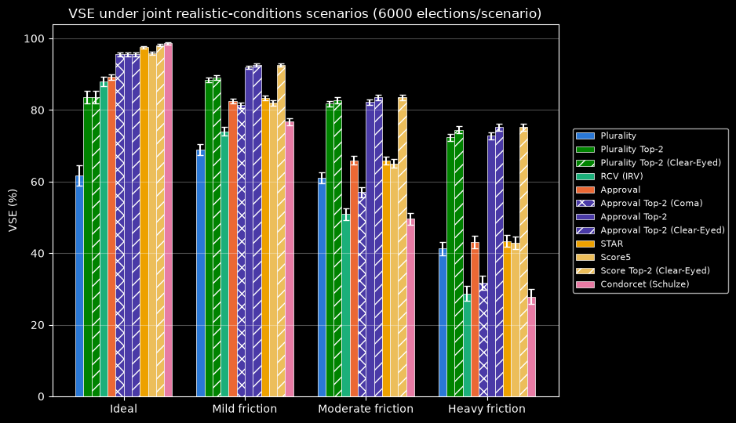

```python
_scenario_names = list(JOINT_SCENARIOS)

def scenario_table_and_plot(method_labels):
    # Table: rows = method, columns = scenario, cell = VSE% (+/-CI)
    _joint_table_lines = ["| Method | " + " | ".join(_scenario_names) + " |",
                        "|---|" + "---|" * len(_scenario_names)]
    for label in method_labels:
        row = [label]
        for name in _scenario_names:
            mean_, ci = joint_results[name][(label, "honBallot")]
            row.append(f"{mean_ * 100:.1f}% (+/-{ci * 100:.1f})")
        _joint_table_lines.append("| " + " | ".join(row) + " |")
    display(Markdown("\n".join(_joint_table_lines)))

    # Grouped bar chart: one group per scenario, one bar per method.
    fig, ax = plt.subplots(figsize=(9.5, 5.5))
    _n_labels = len(method_labels)
    _bar_width = 0.8 / _n_labels
    _x = np.arange(len(_scenario_names))
    for i, label in enumerate(method_labels):
        vses = [joint_results[name][(label, "honBallot")][0] * 100 for name in _scenario_names]
        cis = [joint_results[name][(label, "honBallot")][1] * 100 for name in _scenario_names]
        hatch = "//" if "Clear-Eyed" in label else ("xx" if "Coma" in label else None)
        ax.bar(_x + i * _bar_width, vses, _bar_width, yerr=cis, capsize=3,
            color=METHOD_COLORS[label], hatch=hatch, label=label, edgecolor=FG_COLOR, linewidth=0.5,
            error_kw=dict(ecolor=FG_COLOR))
    ax.set_xticks(_x + _bar_width * (_n_labels - 1) / 2)
    ax.set_xticklabels(_scenario_names)
    ax.set_ylabel("VSE (%)")
    ax.set_title(f"VSE under joint realistic-conditions scenarios ({JOINT_NITER} elections/scenario)")
    ax.legend(fontsize=8, loc="center left", bbox_to_anchor=(1.02, 0.5))
    ax.grid(True, axis="y", alpha=0.3)
    plt.tight_layout()
    plt.show()

scenario_table_and_plot(COMPARE_LABELS)
```

## 17. Specific Method Groups in Joint Scenarios

| Method | Ideal | Mild friction | Moderate friction | Heavy friction |
| --- | --- | --- | --- | --- |
| Plurality | 61.6% (+/-2.8) | 68.9% (+/-1.5) | 61.0% (+/-1.5) | 41.2% (+/-1.8) |
| Plurality Top-2 | 83.6% (+/-1.7) | 88.4% (+/-0.8) | 81.7% (+/-0.8) | 72.3% (+/-1.0) |
| Plurality Top-2 (Clear-Eyed) | 83.6% (+/-1.7) | 89.1% (+/-0.7) | 82.7% (+/-0.8) | 74.5% (+/-1.0) |
| Approval Top-2 (Clear-Eyed) | 95.6% (+/-0.5) | 92.6% (+/-0.5) | 83.5% (+/-0.8) | 75.2% (+/-1.0) |

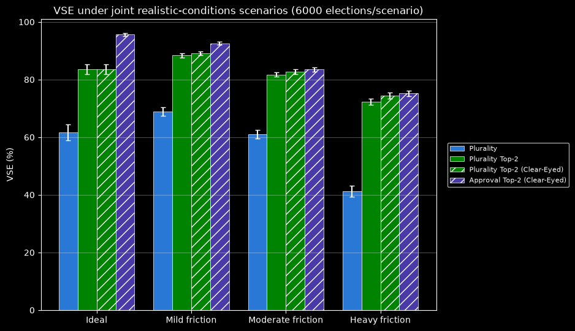

```python
# Plot and table of JUST the plurality-based methods (Plurality, Plurality Top-2, Plurality Top-2 Clear-Eyed) across the joint scenarios
plurality_labels = [l for l in COMPARE_LABELS if "Plurality" in l]
# add clear-eyed AT2 for reference
plurality_labels.append("Approval Top-2 (Clear-Eyed)")
scenario_table_and_plot(plurality_labels)
```

| Method | Ideal | Mild friction | Moderate friction | Heavy friction |
| --- | --- | --- | --- | --- |
| Plurality | 61.6% (+/-2.8) | 68.9% (+/-1.5) | 61.0% (+/-1.5) | 41.2% (+/-1.8) |
| Approval | 89.2% (+/-0.8) | 82.5% (+/-0.7) | 65.9% (+/-1.2) | 43.2% (+/-1.7) |

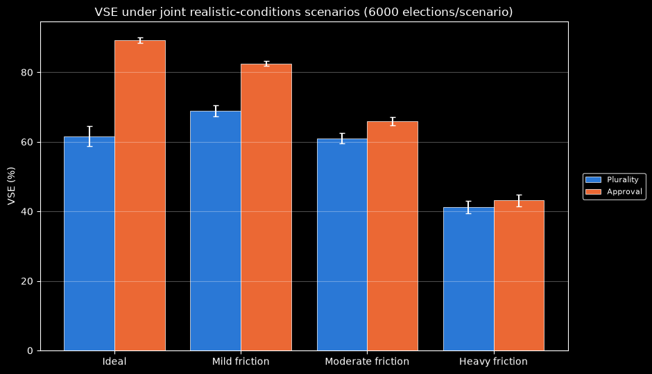

```python
# just single round plurality and approval
simple_labels = ["Plurality", "Approval"]
scenario_table_and_plot(simple_labels)
```

| Method | Ideal | Mild friction | Moderate friction | Heavy friction |
| --- | --- | --- | --- | --- |
| RCV (IRV) | 87.9% (+/-1.3) | 74.1% (+/-1.1) | 50.9% (+/-1.6) | 28.7% (+/-2.1) |
| Condorcet (Schulze) | 98.6% (+/-0.3) | 76.7% (+/-1.0) | 49.6% (+/-1.7) | 27.9% (+/-2.1) |
| Plurality | 61.6% (+/-2.8) | 68.9% (+/-1.5) | 61.0% (+/-1.5) | 41.2% (+/-1.8) |
| STAR | 97.5% (+/-0.3) | 83.3% (+/-0.7) | 65.9% (+/-1.2) | 43.4% (+/-1.7) |
| Approval Top-2 | 95.6% (+/-0.5) | 91.9% (+/-0.5) | 82.2% (+/-0.8) | 72.8% (+/-1.0) |

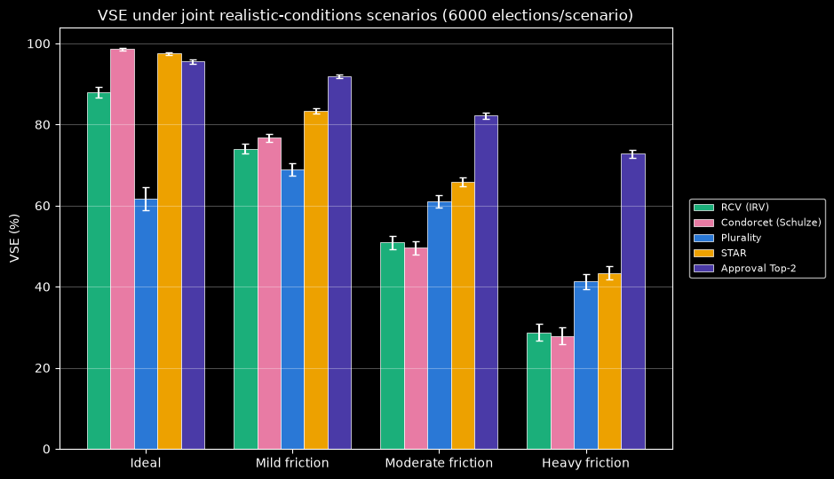

```python
# ranked methods only (RCV, Condorcet) across the joint scenarios
ranked_labels = [l for l in COMPARE_LABELS if l in ("RCV (IRV)", "Condorcet (Schulze)")]
# add for context: approval top-2, plurality, and STAR
ranked_labels.append("Plurality")
ranked_labels.append("STAR")
ranked_labels.append("Approval Top-2")
scenario_table_and_plot(ranked_labels)
```

| Method | Ideal | Mild friction | Moderate friction | Heavy friction |
| --- | --- | --- | --- | --- |
| Plurality | 61.6% (+/-2.8) | 68.9% (+/-1.5) | 61.0% (+/-1.5) | 41.2% (+/-1.8) |
| Approval | 89.2% (+/-0.8) | 82.5% (+/-0.7) | 65.9% (+/-1.2) | 43.2% (+/-1.7) |
| STAR | 97.5% (+/-0.3) | 83.3% (+/-0.7) | 65.9% (+/-1.2) | 43.4% (+/-1.7) |
| Plurality Top-2 | 83.6% (+/-1.7) | 88.4% (+/-0.8) | 81.7% (+/-0.8) | 72.3% (+/-1.0) |
| Approval Top-2 | 95.6% (+/-0.5) | 91.9% (+/-0.5) | 82.2% (+/-0.8) | 72.8% (+/-1.0) |

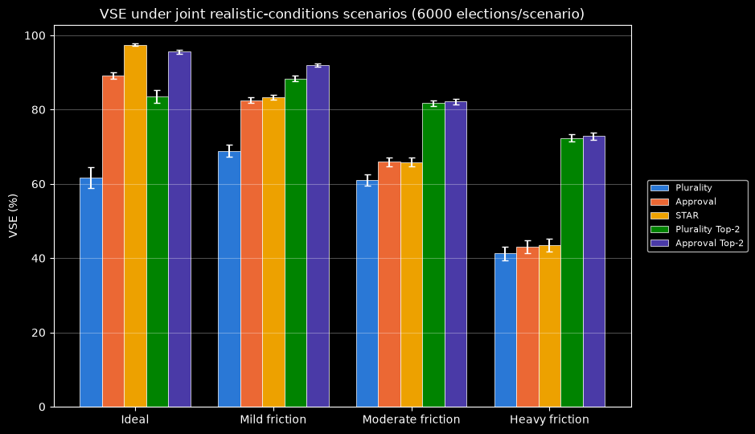

```python
# plurality, approval, star, plus top-2 variants
part_1_systems = ["Plurality", "Approval", "STAR", "Plurality Top-2", "Approval Top-2"]
scenario_table_and_plot(part_1_systems)
```

| Method | Ideal | Mild friction | Moderate friction | Heavy friction |
| --- | --- | --- | --- | --- |
| STAR | 97.5% (+/-0.3) | 83.3% (+/-0.7) | 65.9% (+/-1.2) | 43.4% (+/-1.7) |
| Approval | 89.2% (+/-0.8) | 82.5% (+/-0.7) | 65.9% (+/-1.2) | 43.2% (+/-1.7) |
| Approval Top-2 (Coma) | 95.6% (+/-0.5) | 81.3% (+/-0.8) | 57.0% (+/-1.4) | 31.6% (+/-2.0) |
| Approval Top-2 | 95.6% (+/-0.5) | 91.9% (+/-0.5) | 82.2% (+/-0.8) | 72.8% (+/-1.0) |

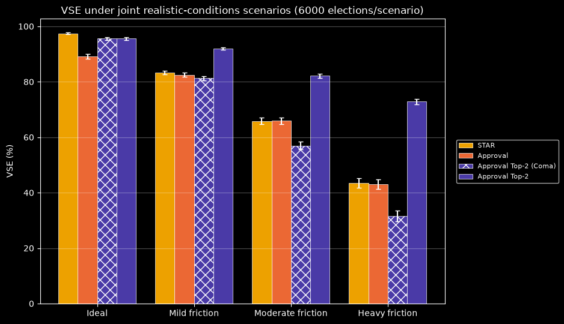

```python
## AT2 Coma vs Approval
coma_single_round_labels = ["STAR", "Approval", "Approval Top-2 (Coma)", "Approval Top-2"]
scenario_table_and_plot(coma_single_round_labels)
```

## 18. Quantifying the swing

For each Approval flavor, its gap to STAR (percentage points) at `Ideal` vs. at `Heavy friction`, and how much that gap moved -- same signed-gap convention as the per-parameter readout above (a positive swing means STAR's lead shrank, possibly past zero).

### Approval/Runoffs vs STAR

```python
from scipy.stats import norm

Z_95 = 1.96
Z_99 = norm.ppf(0.995)  # two-sided 99% CI multiplier, ~2.576

# {table_title: [(row_label, gap_pp, ci95_pp, positive_name, negative_name, spotlight), ...]} --
# every paired-gap "Significant?" row rendered anywhere below registers itself here (see
# _register_significance calls inside display_paired_gap_table and the standalone significance
# loops). positive_name/negative_name name whichever side a positive/negative gap favors (each
# call site already computes this for its own "(X better)" wording -- just passed through here
# too) so Section 27 can say WHICH side looked better, not just whether the gap was significant.
# Section 27 reads this to re-check every one of these already-computed gaps against a stricter
# confidence level -- new cells that register into it are picked up automatically, no separate
# list to keep in sync.
SIGNIFICANCE_LOG = defaultdict(list)

def _register_significance(table_title, row_label, gap_pp, ci95_pp, positive_name, negative_name, spotlight=False):
    """Record one already-displayed paired-gap row (gap and 95% CI half-width, both already in
    percentage points) for Section 27. ci_at_new_z = ci95_pp * (z_new / Z_95) -- a CI's
    half-width scales linearly with z for a fixed standard error, so this needs no new data and
    no re-run, just arithmetic on what's already been computed. positive_name is whichever side
    a positive gap_pp favors, negative_name the other side -- lets Section 27 report e.g. "STAR
    better by 2.3pp" instead of a bare "Yes". spotlight marks a curated set of headline
    comparisons Section 27 highlights on their own, separate from its comprehensive
    not-significant-at-99% table.

    Keyed by (table_title, row_label) and overwrites rather than appends -- re-running a single
    registration cell (without a full Restart & Run All) re-registers the same rows, which would
    otherwise pile up as duplicates every time that cell runs again."""
    _rows = SIGNIFICANCE_LOG[table_title]
    _entry = (row_label, gap_pp, ci95_pp, positive_name, negative_name, spotlight)
    for _i, _existing in enumerate(_rows):
        if _existing[0] == row_label:
            _rows[_i] = _entry
            return
    _rows.append(_entry)

# We try to distinguish between statistical and practical significance
# If we have a CI that does not contain, but the VSE gap is firmly within, say 1%
# then that is not of *practical* significance.
# the following are the labels used in the tables and charts to describe this distinction

TAXONOMY_LABELS = {
    "DECISIVE": "Decisive", # CI is entirely beyond the threshold. There is a clear and practically significant difference between the two methods
    "NARROW_EDGE": "Narrow edge", # CI does not contain 0 but is firmly within the threshold
    "AMBIGUOUS_EDGE": "Ambiguous edge", # CI does not contain 0 but the gap could be outside the threshold
    "INDISTINGUISHABLE": "Indistinguishable", # CI contains 0 but is firmly within the threshold. Even if a direction exists, it is not likely of any practical significance
    "INCONCLUSIVE": "Inconclusive", # CI contains 0 and is potentially outside the threshold. If this is a crucial result, more niters are suggested.
}
# Edit TAXONOMY_LABELS above to change every table's wording at once. Edit GAP_THRESHOLD_PP in
# Section 5 (Parameters) to move the practical-significance bar everywhere at once.

def _classify_gap(gap_pp, ci_pp, threshold_pp=None):
    """5-way practical-significance taxonomy: cross gap-vs-CI (does the CI exclude 0?) with
    CI-vs-band (is the CI entirely inside/outside +/-threshold_pp?)."""
    threshold_pp = GAP_THRESHOLD_PP if threshold_pp is None else threshold_pp
    lo, hi = gap_pp - ci_pp, gap_pp + ci_pp
    contains_zero = lo <= 0 <= hi
    inside_band = (lo >= -threshold_pp) and (hi <= threshold_pp)
    outside_band = (lo > threshold_pp) or (hi < -threshold_pp)
    if not contains_zero:
        return "NARROW_EDGE" if inside_band else ("DECISIVE" if outside_band else "AMBIGUOUS_EDGE")
    return "INDISTINGUISHABLE" if inside_band else "INCONCLUSIVE"

def _verdict_text(gap_pp, ci_pp, positive_name, negative_name, threshold_pp=None):
    """Shared replacement for every hand-rolled "Significant?" string in this notebook --
    returns (bucket, display_text). positive_name is whichever side a positive gap_pp favors,
    same convention as _register_significance."""
    bucket = _classify_gap(gap_pp, ci_pp, threshold_pp)
    label = TAXONOMY_LABELS[bucket]
    if bucket in ("DECISIVE", "NARROW_EDGE", "AMBIGUOUS_EDGE"):
        better = positive_name if gap_pp > 0 else negative_name
        return bucket, f"{label} ({better} better)"
    return bucket, label
```

```python
_joint_quant_lines = []
_focus_labels = ("Approval", "Approval Top-2 (Coma)", "Approval Top-2", "Approval Top-2 (Clear-Eyed)", "Plurality Top-2", "Plurality Top-2 (Clear-Eyed)", "Plurality")

# keep track of method/scenario pairs that have a STAR VSE gap that is statistically indistinguishable from 0 (i.e., the 95% CI contains 0)
contains_zero_pairs = set()
# also keep track of method/scenario pairs where STAR beats the method, and where the method beats STAR
STAR_wins_pairs = set()
STAR_loses_pairs = set()

# Single unified loop over every scenario (including Ideal, now that paired_diff_by_scenario has
# a real "Ideal" entry -- see Section 9/16's merge step) instead of a hand-split Ideal-block +
# per-non-ideal-scenario block.
for scenario in _scenario_names:
    if _joint_quant_lines:
        _joint_quant_lines.append("")
    _joint_quant_lines.extend([
        f"#### {scenario}: Approval-flavor gaps vs STAR (honest ballots)",
        "",
        "| Method | VSE (%) | STAR VSE (%) | Gap vs STAR (pp) | 95% CI (paired, pp) | Significant? |",
        "|---|---|---|---|---|---|",
    ])
    star_vse = joint_results[scenario][("STAR", "honBallot")][0] * 100
    # sort by VSE gap ascending
    sorted_focus_labels = sorted(_focus_labels, key=lambda label: joint_results[scenario][(label, "honBallot")][0] * 100 - star_vse)
    for label in sorted_focus_labels:
        if label not in COMPARE_LABELS:
            continue
        # at Ideal, Coma/Clear-Eyed runoff variants are mathematically identical to their base
        # method (see Section 9's _IDENTICAL_AT_IDEAL aliasing) -- skip the redundant duplicate rows
        if scenario == "Ideal" and ("Coma" in label or "Clear-Eyed" in label):
            continue
        method_vse = joint_results[scenario][(label, "honBallot")][0] * 100
        gap_vs_star = method_vse - star_vse
        _paired_ci = paired_diff_by_scenario[scenario][(label, "STAR")][1] * 100
        _ci_interval_str = f"[{gap_vs_star - _paired_ci:+.1f}, {gap_vs_star + _paired_ci:+.1f}]"
        _register_significance(f"Approval-flavor gaps vs STAR: {scenario}", label, gap_vs_star, _paired_ci,
                                label, "STAR", spotlight=(label in ("Approval Top-2", "Plurality Top-2")))
        _, sig = _verdict_text(gap_vs_star, _paired_ci, label, "STAR")
        if gap_vs_star - _paired_ci <= 0 <= gap_vs_star + _paired_ci:
            contains_zero_pairs.add((label, scenario))
        elif gap_vs_star > 0:
            STAR_loses_pairs.add((label, scenario))
        else:
            STAR_wins_pairs.add((label, scenario))
        _joint_quant_lines.append(
            f"| {label} | {method_vse:.1f} | {star_vse:.1f} | {gap_vs_star:+.1f} | {_ci_interval_str} | {sig} |"
        )
display(Markdown("\n".join(_joint_quant_lines)))
```

Ideal: Approval-flavor gaps vs STAR (honest ballots)

| Method | VSE (%) | STAR VSE (%) | Gap vs STAR (pp) | 95% CI (paired, pp) | Significant? |
| --- | --- | --- | --- | --- | --- |
| Plurality | 61.6 | 97.5 | -35.9 | [-38.7, -33.0] | Decisive (STAR better) |
| Plurality Top-2 | 83.6 | 97.5 | -13.9 | [-15.7, -12.1] | Decisive (STAR better) |
| Approval | 89.2 | 97.5 | -8.3 | [-9.1, -7.5] | Decisive (STAR better) |
| Approval Top-2 | 95.6 | 97.5 | -1.9 | [-2.4, -1.4] | Decisive (STAR better) |

Mild friction: Approval-flavor gaps vs STAR (honest ballots)

| Method | VSE (%) | STAR VSE (%) | Gap vs STAR (pp) | 95% CI (paired, pp) | Significant? |
| --- | --- | --- | --- | --- | --- |
| Plurality | 68.9 | 83.3 | -14.4 | [-15.9, -12.9] | Decisive (STAR better) |
| Approval Top-2 (Coma) | 81.3 | 83.3 | -2.0 | [-2.5, -1.5] | Decisive (STAR better) |
| Approval | 82.5 | 83.3 | -0.8 | [-1.3, -0.3] | Ambiguous edge (STAR better) |
| Plurality Top-2 | 88.4 | 83.3 | +5.1 | [+4.3, +5.9] | Decisive (Plurality Top-2 better) |
| Plurality Top-2 (Clear-Eyed) | 89.1 | 83.3 | +5.8 | [+5.0, +6.6] | Decisive (Plurality Top-2 (Clear-Eyed) better) |
| Approval Top-2 | 91.9 | 83.3 | +8.6 | [+8.0, +9.2] | Decisive (Approval Top-2 better) |
| Approval Top-2 (Clear-Eyed) | 92.6 | 83.3 | +9.3 | [+8.7, +9.9] | Decisive (Approval Top-2 (Clear-Eyed) better) |

Moderate friction: Approval-flavor gaps vs STAR (honest ballots)

| Method | VSE (%) | STAR VSE (%) | Gap vs STAR (pp) | 95% CI (paired, pp) | Significant? |
| --- | --- | --- | --- | --- | --- |
| Approval Top-2 (Coma) | 57.0 | 65.9 | -8.9 | [-9.8, -7.9] | Decisive (STAR better) |
| Plurality | 61.0 | 65.9 | -4.8 | [-5.9, -3.8] | Decisive (STAR better) |
| Approval | 65.9 | 65.9 | +0.1 | [-0.5, +0.6] | Indistinguishable |
| Plurality Top-2 | 81.7 | 65.9 | +15.9 | [+14.9, +16.9] | Decisive (Plurality Top-2 better) |
| Approval Top-2 | 82.2 | 65.9 | +16.3 | [+15.4, +17.3] | Decisive (Approval Top-2 better) |
| Plurality Top-2 (Clear-Eyed) | 82.7 | 65.9 | +16.8 | [+15.8, +17.8] | Decisive (Plurality Top-2 (Clear-Eyed) better) |
| Approval Top-2 (Clear-Eyed) | 83.5 | 65.9 | +17.6 | [+16.6, +18.6] | Decisive (Approval Top-2 (Clear-Eyed) better) |

Heavy friction: Approval-flavor gaps vs STAR (honest ballots)

| Method | VSE (%) | STAR VSE (%) | Gap vs STAR (pp) | 95% CI (paired, pp) | Significant? |
| --- | --- | --- | --- | --- | --- |
| Approval Top-2 (Coma) | 31.6 | 43.4 | -11.8 | [-13.0, -10.5] | Decisive (STAR better) |
| Plurality | 41.2 | 43.4 | -2.2 | [-3.0, -1.4] | Decisive (STAR better) |
| Approval | 43.2 | 43.4 | -0.3 | [-0.8, +0.3] | Indistinguishable |
| Plurality Top-2 | 72.3 | 43.4 | +28.9 | [+27.4, +30.5] | Decisive (Plurality Top-2 better) |
| Approval Top-2 | 72.8 | 43.4 | +29.4 | [+27.9, +30.9] | Decisive (Approval Top-2 better) |
| Plurality Top-2 (Clear-Eyed) | 74.5 | 43.4 | +31.0 | [+29.5, +32.5] | Decisive (Plurality Top-2 (Clear-Eyed) better) |
| Approval Top-2 (Clear-Eyed) | 75.2 | 43.4 | +31.8 | [+30.3, +33.3] | Decisive (Approval Top-2 (Clear-Eyed) better) |

```python
_scenario_order = {name: i for i, name in enumerate(_scenario_names)}

def _scenario_then_label(item):
    # sort by scenario, then VSE gap
    label, scenario = item
    return (_scenario_order.get(scenario, len(_scenario_order)), joint_results[scenario][(label, "honBallot")][0] * 100 - joint_results[scenario][("STAR", "honBallot")][0] * 100)

# first display the method/scenario pairs that have a paired CI where STAR wins
_joint_quant_lines_star_wins = [
    "### Method/scenario pairs where STAR's VSE is significantly higher than the method's (95% CI does NOT contain 0)",
    "",
    "| Method | Scenario | VSE - STAR VSE (pp) | 95% CI (paired, pp) | Significant? |",
    "|---|---|---|---|---|",
]
for label, scenario in sorted(STAR_wins_pairs, key=_scenario_then_label):
    method_vse = joint_results[scenario][(label, "honBallot")][0] * 100
    star_vse = joint_results[scenario][("STAR", "honBallot")][0] * 100
    gap_vs_star = method_vse - star_vse
    if scenario != "Ideal":
        _paired_ci = paired_diff_by_scenario[scenario][(label, "STAR")][1] * 100
    else:
        _paired_ci = ideal_paired_diff[(label, "STAR")][1] * 100
    _ci_interval_str = f"[{gap_vs_star - _paired_ci:+.1f}, {gap_vs_star + _paired_ci:+.1f}]"
    _bucket, sig = _verdict_text(gap_vs_star, _paired_ci, label, "STAR")
    assert gap_vs_star < 0 and _bucket in ("DECISIVE", "NARROW_EDGE", "AMBIGUOUS_EDGE"), (
        f"STAR wins but gap is {gap_vs_star:+.1f} pp (bucket={_bucket})"
    )
    _joint_quant_lines_star_wins.append(
        f"| {label} | {scenario} | {gap_vs_star:+.1f} | {_ci_interval_str} | {sig} |"
    )
display(Markdown("\n".join(_joint_quant_lines_star_wins)))

# display all method/scenario pairs that have a paired CI that includes 0
_joint_quant_lines_with_zero = [
    "### Method/scenario pairs with STAR VSE gap that is statistically indistinguishable from 0 (95% CI contains 0)",
    "",
    "| Method | Scenario | VSE - STAR VSE (pp) | 95% CI (paired, pp) | Significant? |",
    "|---|---|---|---|---|",
]
for label, scenario in sorted(contains_zero_pairs, key=_scenario_then_label):
    method_vse = joint_results[scenario][(label, "honBallot")][0] * 100
    star_vse = joint_results[scenario][("STAR", "honBallot")][0] * 100
    gap_vs_star = method_vse - star_vse
    if scenario != "Ideal":
        _paired_ci = paired_diff_by_scenario[scenario][(label, "STAR")][1] * 100
    else:
        _paired_ci = ideal_paired_diff[(label, "STAR")][1] * 100
    _ci_interval_str = f"[{gap_vs_star - _paired_ci:+.1f}, {gap_vs_star + _paired_ci:+.1f}]"
    _bucket, sig = _verdict_text(gap_vs_star, _paired_ci, label, "STAR")
    assert _bucket in ("INDISTINGUISHABLE", "INCONCLUSIVE"), (
        f"CI does not contain 0 but gap is {gap_vs_star:+.1f} pp "
        f"with CI [{gap_vs_star - _paired_ci:+.1f}, {gap_vs_star + _paired_ci:+.1f}] (bucket={_bucket})"
    )
    _joint_quant_lines_with_zero.append(
        f"| {label} | {scenario} | {gap_vs_star:+.1f} | {_ci_interval_str} | {sig} |"
    )
display(Markdown("\n".join(_joint_quant_lines_with_zero)))

# finally display the method/scenario pairs where STAR loses
_joint_quant_lines_star_loses = [
    "### Method/scenario pairs where STAR's VSE is significantly lower than the method's (95% CI does NOT contain 0)",
    "",
    "| Method | Scenario | VSE - STAR VSE (pp) | 95% CI (paired, pp) | Significant? |",
    "|---|---|---|---|---|",
]
for label, scenario in sorted(STAR_loses_pairs, key=_scenario_then_label):
    method_vse = joint_results[scenario][(label, "honBallot")][0] * 100
    star_vse = joint_results[scenario][("STAR", "honBallot")][0] * 100
    gap_vs_star = method_vse - star_vse
    if scenario != "Ideal":
        _paired_ci = paired_diff_by_scenario[scenario][(label, "STAR")][1] * 100
    else:
        _paired_ci = ideal_paired_diff[(label, "STAR")][1] * 100
    _ci_interval_str = f"[{gap_vs_star - _paired_ci:+.1f}, {gap_vs_star + _paired_ci:+.1f}]"
    _bucket, sig = _verdict_text(gap_vs_star, _paired_ci, label, "STAR")
    assert gap_vs_star > 0 and _bucket in ("DECISIVE", "NARROW_EDGE", "AMBIGUOUS_EDGE"), (
        f"STAR loses but gap is {gap_vs_star:+.1f} pp (bucket={_bucket})"
    )
    _joint_quant_lines_star_loses.append(
        f"| {label} | {scenario} | {gap_vs_star:+.1f} | {_ci_interval_str} | {sig} |"
    )
display(Markdown("\n".join(_joint_quant_lines_star_loses)))
```

Method/scenario pairs where STAR's VSE is significantly higher than the method's (95% CI does NOT contain 0)

| Method | Scenario | VSE - STAR VSE (pp) | 95% CI (paired, pp) | Significant? |
| --- | --- | --- | --- | --- |
| Plurality | Ideal | -35.9 | [-38.7, -33.0] | Decisive (STAR better) |
| Plurality Top-2 | Ideal | -13.9 | [-15.7, -12.1] | Decisive (STAR better) |
| Approval | Ideal | -8.3 | [-9.1, -7.5] | Decisive (STAR better) |
| Approval Top-2 | Ideal | -1.9 | [-2.4, -1.4] | Decisive (STAR better) |
| Plurality | Mild friction | -14.4 | [-15.9, -12.9] | Decisive (STAR better) |
| Approval Top-2 (Coma) | Mild friction | -2.0 | [-2.5, -1.5] | Decisive (STAR better) |
| Approval | Mild friction | -0.8 | [-1.3, -0.3] | Ambiguous edge (STAR better) |
| Approval Top-2 (Coma) | Moderate friction | -8.9 | [-9.8, -7.9] | Decisive (STAR better) |
| Plurality | Moderate friction | -4.8 | [-5.9, -3.8] | Decisive (STAR better) |
| Approval Top-2 (Coma) | Heavy friction | -11.8 | [-13.0, -10.5] | Decisive (STAR better) |
| Plurality | Heavy friction | -2.2 | [-3.0, -1.4] | Decisive (STAR better) |

Method/scenario pairs with STAR VSE gap that is statistically indistinguishable from 0 (95% CI contains 0)

| Method | Scenario | VSE - STAR VSE (pp) | 95% CI (paired, pp) | Significant? |
| --- | --- | --- | --- | --- |
| Approval | Moderate friction | +0.1 | [-0.5, +0.6] | Indistinguishable |
| Approval | Heavy friction | -0.3 | [-0.8, +0.3] | Indistinguishable |

Method/scenario pairs where STAR's VSE is significantly lower than the method's (95% CI does NOT contain 0)

| Method | Scenario | VSE - STAR VSE (pp) | 95% CI (paired, pp) | Significant? |
| --- | --- | --- | --- | --- |
| Plurality Top-2 | Mild friction | +5.1 | [+4.3, +5.9] | Decisive (Plurality Top-2 better) |
| Plurality Top-2 (Clear-Eyed) | Mild friction | +5.8 | [+5.0, +6.6] | Decisive (Plurality Top-2 (Clear-Eyed) better) |
| Approval Top-2 | Mild friction | +8.6 | [+8.0, +9.2] | Decisive (Approval Top-2 better) |
| Approval Top-2 (Clear-Eyed) | Mild friction | +9.3 | [+8.7, +9.9] | Decisive (Approval Top-2 (Clear-Eyed) better) |
| Plurality Top-2 | Moderate friction | +15.9 | [+14.9, +16.9] | Decisive (Plurality Top-2 better) |
| Approval Top-2 | Moderate friction | +16.3 | [+15.4, +17.3] | Decisive (Approval Top-2 better) |
| Plurality Top-2 (Clear-Eyed) | Moderate friction | +16.8 | [+15.8, +17.8] | Decisive (Plurality Top-2 (Clear-Eyed) better) |
| Approval Top-2 (Clear-Eyed) | Moderate friction | +17.6 | [+16.6, +18.6] | Decisive (Approval Top-2 (Clear-Eyed) better) |
| Plurality Top-2 | Heavy friction | +28.9 | [+27.4, +30.5] | Decisive (Plurality Top-2 better) |
| Approval Top-2 | Heavy friction | +29.4 | [+27.9, +30.9] | Decisive (Approval Top-2 better) |
| Plurality Top-2 (Clear-Eyed) | Heavy friction | +31.0 | [+29.5, +32.5] | Decisive (Plurality Top-2 (Clear-Eyed) better) |
| Approval Top-2 (Clear-Eyed) | Heavy friction | +31.8 | [+30.3, +33.3] | Decisive (Approval Top-2 (Clear-Eyed) better) |

```python
def display_paired_gap_table(label, baseline_label, label_short=None, baseline_short=None,
                              label_better_name=None, baseline_better_name=None, title=None,
                              spotlight=False):
    """Display a "paired VSE gap by joint-friction scenario" markdown table for `label` vs
    `baseline_label`, reading off the already-computed `joint_results`/`paired_diff_by_scenario`
    (the main joint-scenario run above) -- no new simulation is run here.

    To add a NEW comparison: add the (label, baseline_label) pair to `_paired_diff_pairs` in the
    main run cell above and re-run it (this is where the actual per-election data gets collected,
    since it has to happen DURING the simulation pass to stay paired), then call this function.

    label_short/baseline_short: optional shorter names for the table header (VSE columns), e.g.
    "AT2"/"PT2" for "Approval Top-2"/"Plurality Top-2"; default to the full label.
    label_better_name/baseline_better_name: optional separate override for the "(X better)" text
    in the Significant? column, in case that should read differently than the column header (e.g.
    a fuller name there than the short header); default to label_short/baseline_short.
    title: optional heading override; defaults to "{label} vs {baseline_label}".
    """
    label_short = label_short or label
    baseline_short = baseline_short or baseline_label
    label_better_name = label_better_name or label_short
    baseline_better_name = baseline_better_name or baseline_short
    title = title or f"{label} vs {baseline_label}"
    missing = [name for name in _scenario_names
               if (label, baseline_label) not in paired_diff_by_scenario.get(name, {})]
    if missing:
        raise KeyError(
            f"({label!r}, {baseline_label!r}) missing from paired_diff_by_scenario for {missing} -- "
            "add this pair to _paired_diff_pairs in the main joint-scenario run cell above and "
            "re-run it before calling display_paired_gap_table for this pair."
        )
    lines = [
        f"#### {title}: paired VSE gap by joint-friction scenario",
        "",
        f"| Scenario | {label_short} VSE (%) | {baseline_short} VSE (%) | Gap vs {baseline_short} (pp) | 95% CI (paired, pp) | Significant? |",
        "|---|---|---|---|---|---|",
    ]
    for name in _scenario_names:
        label_vse = joint_results[name][(label, "honBallot")][0] * 100
        baseline_vse = joint_results[name][(baseline_label, "honBallot")][0] * 100
        gap = label_vse - baseline_vse
        ci = paired_diff_by_scenario[name][(label, baseline_label)][1] * 100
        _register_significance(title, name, gap, ci, label_better_name, baseline_better_name, spotlight)
        _, sig = _verdict_text(gap, ci, label_better_name, baseline_better_name)
        lines.append(f"| {name} | {label_vse:.1f} | {baseline_vse:.1f} | {gap:+.1f} | [{gap-ci:+.1f}, {gap+ci:+.1f}] | {sig} |")
    display(Markdown("\n".join(lines)))
```

### Paired VSE gap: RCV (IRV) vs Condorcet (Schulze)

```python
display_paired_gap_table("RCV (IRV)", "Condorcet (Schulze)", label_short="RCV", baseline_short="Schulze")
```

RCV (IRV) vs Condorcet (Schulze): paired VSE gap by joint-friction scenario

| Scenario | RCV VSE (%) | Schulze VSE (%) | Gap vs Schulze (pp) | 95% CI (paired, pp) | Significant? |
| --- | --- | --- | --- | --- | --- |
| Ideal | 87.9 | 98.6 | -10.7 | [-11.9, -9.5] | Decisive (Schulze better) |
| Mild friction | 74.1 | 76.7 | -2.7 | [-3.4, -2.0] | Decisive (Schulze better) |
| Moderate friction | 50.9 | 49.6 | +1.3 | [+0.8, +1.9] | Ambiguous edge (RCV better) |
| Heavy friction | 28.7 | 27.9 | +0.8 | [+0.3, +1.4] | Ambiguous edge (RCV better) |

### Paired VSE gap: Approval Top-2 vs Plurality Top-2

```python
display_paired_gap_table("Approval Top-2", "Plurality Top-2", label_short="AT2", baseline_short="PT2", spotlight=True)
display_paired_gap_table("Approval Top-2 (Clear-Eyed)", "Plurality Top-2 (Clear-Eyed)", label_short="AT2", baseline_short="PT2", spotlight=True)
```

Approval Top-2 vs Plurality Top-2: paired VSE gap by joint-friction scenario

| Scenario | AT2 VSE (%) | PT2 VSE (%) | Gap vs PT2 (pp) | 95% CI (paired, pp) | Significant? |
| --- | --- | --- | --- | --- | --- |
| Ideal | 95.6 | 83.6 | +12.0 | [+10.1, +13.8] | Decisive (AT2 better) |
| Mild friction | 91.9 | 88.4 | +3.6 | [+2.8, +4.3] | Decisive (AT2 better) |
| Moderate friction | 82.2 | 81.7 | +0.5 | [-0.1, +1.0] | Inconclusive |
| Heavy friction | 72.8 | 72.3 | +0.5 | [-0.1, +1.1] | Inconclusive |

Approval Top-2 (Clear-Eyed) vs Plurality Top-2 (Clear-Eyed): paired VSE gap by joint-friction scenario

| Scenario | AT2 VSE (%) | PT2 VSE (%) | Gap vs PT2 (pp) | 95% CI (paired, pp) | Significant? |
| --- | --- | --- | --- | --- | --- |
| Ideal | 95.6 | 83.6 | +12.0 | [+10.1, +13.8] | Decisive (AT2 better) |
| Mild friction | 92.6 | 89.1 | +3.5 | [+2.8, +4.2] | Decisive (AT2 better) |
| Moderate friction | 83.5 | 82.7 | +0.8 | [+0.2, +1.4] | Ambiguous edge (AT2 better) |
| Heavy friction | 75.2 | 74.5 | +0.8 | [+0.2, +1.4] | Ambiguous edge (AT2 better) |

### Paired VSE gap: Approval vs Plurality

```python
display_paired_gap_table("Approval", "Plurality", spotlight=True)
```

Approval vs Plurality: paired VSE gap by joint-friction scenario

| Scenario | Approval VSE (%) | Plurality VSE (%) | Gap vs Plurality (pp) | 95% CI (paired, pp) | Significant? |
| --- | --- | --- | --- | --- | --- |
| Ideal | 89.2 | 61.6 | +27.5 | [+24.5, +30.6] | Decisive (Approval better) |
| Mild friction | 82.5 | 68.9 | +13.6 | [+12.1, +15.1] | Decisive (Approval better) |
| Moderate friction | 65.9 | 61.0 | +4.9 | [+3.9, +6.0] | Decisive (Approval better) |
| Heavy friction | 43.2 | 41.2 | +1.9 | [+1.1, +2.7] | Decisive (Approval better) |

### Paired VSE Gap: Approval vs Approval Top-2 (Coma)

```python
display_paired_gap_table("Approval Top-2 (Coma)", "Approval", label_short="AT2 (Coma)", baseline_short="Approval")
```

Approval Top-2 (Coma) vs Approval: paired VSE gap by joint-friction scenario

| Scenario | AT2 (Coma) VSE (%) | Approval VSE (%) | Gap vs Approval (pp) | 95% CI (paired, pp) | Significant? |
| --- | --- | --- | --- | --- | --- |
| Ideal | 95.6 | 89.2 | +6.4 | [+5.7, +7.2] | Decisive (AT2 (Coma) better) |
| Mild friction | 81.3 | 82.5 | -1.2 | [-1.8, -0.7] | Ambiguous edge (Approval better) |
| Moderate friction | 57.0 | 65.9 | -8.9 | [-9.9, -8.0] | Decisive (Approval better) |
| Heavy friction | 31.6 | 43.2 | -11.5 | [-12.8, -10.2] | Decisive (Approval better) |

## 19. Condorcet efficiency under the same joint realistic-conditions scenarios

This is the comparison the whole Condorcet-efficiency section was really built for: as noise, unfamiliarity, and ballot fatigue all degrade *together*, does each method's ability to actually elect the true Condorcet winner hold up -- and how does that compare to Schulze, the method literally designed to find it?

| Method | Ideal | Mild friction | Moderate friction | Heavy friction |
| --- | --- | --- | --- | --- |
| Plurality | 44.4% (0.44x Schulze) | 45.2% (1.04x Schulze) | 33.6% (1.19x Schulze) | 24.1% (1.14x Schulze) |
| Plurality Top-2 | 66.2% (0.66x Schulze) | 60.4% (1.39x Schulze) | 48.2% (1.71x Schulze) | 38.5% (1.83x Schulze) |
| Plurality Top-2 (Clear-Eyed) | 66.2% (0.66x Schulze) | 68.7% (1.58x Schulze) | 54.6% (1.93x Schulze) | 44.1% (2.10x Schulze) |
| RCV (IRV) | 64.0% (0.64x Schulze) | 42.4% (0.97x Schulze) | 28.6% (1.01x Schulze) | 21.1% (1.00x Schulze) |
| Approval | 57.8% (0.58x Schulze) | 45.4% (1.04x Schulze) | 33.7% (1.19x Schulze) | 24.0% (1.14x Schulze) |
| Approval Top-2 (Coma) | 82.1% (0.82x Schulze) | 45.1% (1.04x Schulze) | 29.1% (1.03x Schulze) | 21.1% (1.00x Schulze) |
| Approval Top-2 | 82.1% (0.82x Schulze) | 61.1% (1.40x Schulze) | 47.5% (1.68x Schulze) | 38.5% (1.83x Schulze) |
| Approval Top-2 (Clear-Eyed) | 82.1% (0.82x Schulze) | 71.4% (1.64x Schulze) | 54.1% (1.91x Schulze) | 44.2% (2.10x Schulze) |
| STAR | 79.3% (0.79x Schulze) | 47.3% (1.08x Schulze) | 33.7% (1.19x Schulze) | 24.1% (1.15x Schulze) |
| Score5 | 70.9% (0.71x Schulze) | 45.0% (1.03x Schulze) | 33.1% (1.17x Schulze) | 24.0% (1.14x Schulze) |
| Score Top-2 (Clear-Eyed) | 91.4% (0.91x Schulze) | 70.8% (1.63x Schulze) | 53.7% (1.90x Schulze) | 44.0% (2.09x Schulze) |
| Condorcet (Schulze) | 100.0% (1.00x Schulze) | 43.6% (1.00x Schulze) | 28.2% (1.00x Schulze) | 21.0% (1.00x Schulze) |

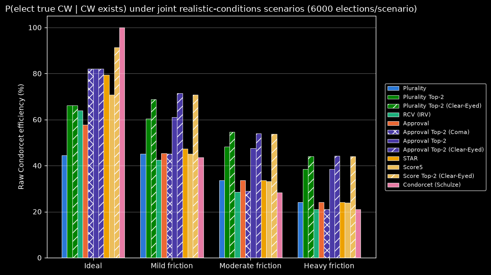

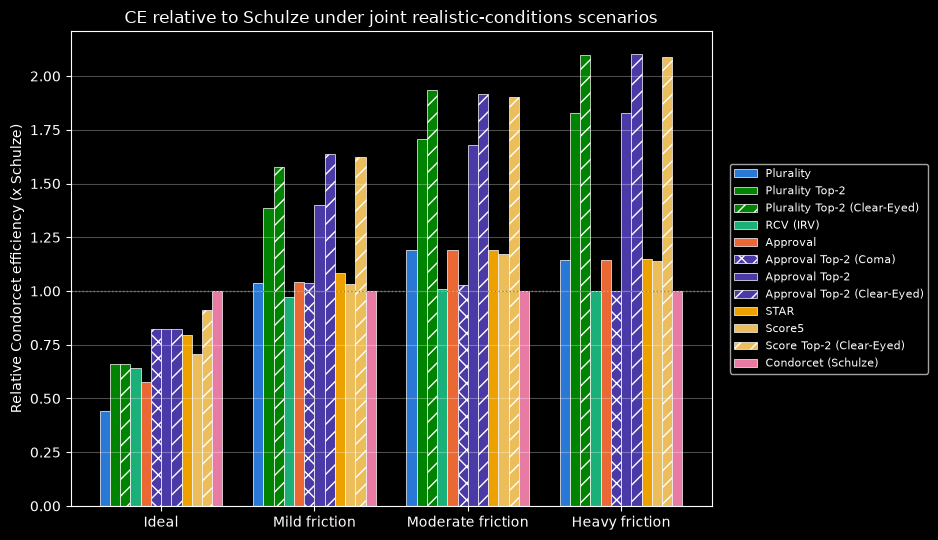

```python
_joint_ce_table_lines = ["| Method | " + " | ".join(_scenario_names) + " |",
                         "|---|" + "---|" * len(_scenario_names)]
for label in COMPARE_LABELS:
    row = [label]
    for name in _scenario_names:
        raw = joint_ce_results[name].get((label, "honBallot"))
        rel = relative_ce(joint_ce_results[name]).get((label, "honBallot"))
        raw_str = "n/a" if raw is None or raw != raw else f"{raw * 100:.1f}%"
        rel_str = "" if rel is None else f" ({rel:.2f}x Schulze)"
        row.append(raw_str + rel_str)
    _joint_ce_table_lines.append("| " + " | ".join(row) + " |")
display(Markdown("\n".join(_joint_ce_table_lines)))

# Grouped bar chart: one group per scenario, one bar per method -- same layout as the VSE
# version above, but raw Condorcet efficiency instead of VSE (no error bars: CE has no CI
# computed here, unlike the VSE accumulator's mean/variance tracking).
fig, ax = plt.subplots(figsize=(9.5, 5.5))
for i, label in enumerate(COMPARE_LABELS):
    ces = [
        (joint_ce_results[name].get((label, "honBallot")) or float("nan")) * 100
        for name in _scenario_names
    ]
    hatch = "//" if "Clear-Eyed" in label else ("xx" if "Coma" in label else None)
    _n_labels = len(COMPARE_LABELS)
    _bar_width = 0.8 / _n_labels
    _x = np.arange(len(_scenario_names))
    ax.bar(_x + i * _bar_width, ces, _bar_width,
           color=METHOD_COLORS[label], hatch=hatch, label=label, edgecolor=FG_COLOR, linewidth=0.5)
ax.set_xticks(_x + _bar_width * (_n_labels - 1) / 2)
ax.set_xticklabels(_scenario_names)
ax.set_ylabel("Raw Condorcet efficiency (%)")
ax.set_title(f"P(elect true CW | CW exists) under joint realistic-conditions scenarios ({JOINT_NITER} elections/scenario)")
ax.legend(fontsize=8, loc="center left", bbox_to_anchor=(1.02, 0.5))
ax.grid(True, axis="y", alpha=0.3)
plt.tight_layout()
plt.show()

# Same layout as the raw-CE chart above, but relative to Schulze's own CE at each scenario --
# computed once here and reused, rather than recomputing relative_ce(...) per method per scenario.
joint_rel_ce_results = {name: relative_ce(joint_ce_results[name]) for name in _scenario_names}

fig, ax = plt.subplots(figsize=(9.5, 5.5))
for i, label in enumerate(COMPARE_LABELS):
    rels = [
        joint_rel_ce_results[name].get((label, "honBallot"), float("nan"))
        for name in _scenario_names
    ]
    hatch = "//" if "Clear-Eyed" in label else ("xx" if "Coma" in label else None)
    ax.bar(_x + i * _bar_width, rels, _bar_width,
           color=METHOD_COLORS[label], hatch=hatch, label=label, edgecolor=FG_COLOR, linewidth=0.5)
ax.axhline(1.0, color="gray", linewidth=1, linestyle=":")  # "same as Schulze"
ax.set_xticks(_x + _bar_width * (_n_labels - 1) / 2)
ax.set_xticklabels(_scenario_names)
ax.set_ylabel("Relative Condorcet efficiency (x Schulze)")
ax.set_title("CE relative to Schulze under joint realistic-conditions scenarios")
ax.legend(fontsize=8, loc="center left", bbox_to_anchor=(1.02, 0.5))
ax.grid(True, axis="y", alpha=0.3)
plt.tight_layout()
plt.show()
```

### Condorcet efficiency: paired gap vs Schulze by joint-friction scenario

```python
_ce_gap_lines = []
for name in _scenario_names:
    _ce_gap_lines.extend([
        f"#### {name}: paired Condorcet-efficiency gap vs Schulze (pp)",
        "",
        "| Method | CE gap vs Schulze (pp) | 95% CI | Significant? |",
        "|---|---|---|---|",
    ])
    # sort the labels by the gap (descending) so that the most positive gaps (methods that beat Schulze) are at the top of the table, and the most negative gaps (methods that lose to Schulze) are at the bottom
    sorted_labels = sorted(COMPARE_LABELS, key=lambda label: paired_ce_by_scenario[name].get((label, "Condorcet (Schulze)"), (0, 0))[0], reverse=True)
    for label in sorted_labels:
        if label == "Condorcet (Schulze)":
            continue
        if ('Coma' in label or 'Clear-Eyed' in label) and name == "Ideal":
            # skip Coma/Clear-Eyed variants at Ideal, since they are mathematically identical to their base method (see Section 9's _IDENTICAL_AT_IDEAL aliasing)
            continue
        gap, ci = paired_ce_by_scenario[name][(label, "Condorcet (Schulze)")]
        gap *= 100
        ci *= 100
        _register_significance(f"CE gap vs Schulze: {name}", label, gap, ci, label, "Condorcet (Schulze)", spotlight=True)
        _, sig = _verdict_text(gap, ci, label, "Condorcet (Schulze)")
        _ce_gap_lines.append(f"| {label} | {gap:+.1f}% | [{gap-ci:+.1f}%, {gap+ci:+.1f}%] | {sig} |")
    _ce_gap_lines.append("")
display(Markdown("\n".join(_ce_gap_lines)))
```

Ideal: paired Condorcet-efficiency gap vs Schulze (pp)

| Method | CE gap vs Schulze (pp) | 95% CI | Significant? |
| --- | --- | --- | --- |
| Approval Top-2 | -17.9% | [-19.6%, -16.2%] | Decisive (Condorcet (Schulze) better) |
| STAR | -20.7% | [-22.4%, -18.9%] | Decisive (Condorcet (Schulze) better) |
| Score5 | -29.1% | [-31.1%, -27.1%] | Decisive (Condorcet (Schulze) better) |
| Plurality Top-2 | -33.8% | [-35.9%, -31.7%] | Decisive (Condorcet (Schulze) better) |
| RCV (IRV) | -36.0% | [-38.1%, -33.9%] | Decisive (Condorcet (Schulze) better) |
| Approval | -42.2% | [-44.4%, -40.0%] | Decisive (Condorcet (Schulze) better) |
| Plurality | -55.6% | [-57.8%, -53.5%] | Decisive (Condorcet (Schulze) better) |

Mild friction: paired Condorcet-efficiency gap vs Schulze (pp)

| Method | CE gap vs Schulze (pp) | 95% CI | Significant? |
| --- | --- | --- | --- |
| Approval Top-2 (Clear-Eyed) | +27.8% | [+26.6%, +29.0%] | Decisive (Approval Top-2 (Clear-Eyed) better) |
| Score Top-2 (Clear-Eyed) | +27.2% | [+26.1%, +28.4%] | Decisive (Score Top-2 (Clear-Eyed) better) |
| Plurality Top-2 (Clear-Eyed) | +25.2% | [+23.9%, +26.4%] | Decisive (Plurality Top-2 (Clear-Eyed) better) |
| Approval Top-2 | +17.5% | [+16.2%, +18.8%] | Decisive (Approval Top-2 better) |
| Plurality Top-2 | +16.8% | [+15.5%, +18.1%] | Decisive (Plurality Top-2 better) |
| STAR | +3.7% | [+3.0%, +4.4%] | Decisive (STAR better) |
| Approval | +1.8% | [+1.0%, +2.7%] | Decisive (Approval better) |
| Plurality | +1.6% | [+0.6%, +2.7%] | Ambiguous edge (Plurality better) |
| Approval Top-2 (Coma) | +1.5% | [+0.8%, +2.3%] | Ambiguous edge (Approval Top-2 (Coma) better) |
| Score5 | +1.5% | [+0.7%, +2.2%] | Ambiguous edge (Score5 better) |
| RCV (IRV) | -1.2% | [-1.7%, -0.7%] | Ambiguous edge (Condorcet (Schulze) better) |

Moderate friction: paired Condorcet-efficiency gap vs Schulze (pp)

| Method | CE gap vs Schulze (pp) | 95% CI | Significant? |
| --- | --- | --- | --- |
| Plurality Top-2 (Clear-Eyed) | +26.4% | [+25.2%, +27.5%] | Decisive (Plurality Top-2 (Clear-Eyed) better) |
| Approval Top-2 (Clear-Eyed) | +25.8% | [+24.7%, +26.9%] | Decisive (Approval Top-2 (Clear-Eyed) better) |
| Score Top-2 (Clear-Eyed) | +25.5% | [+24.3%, +26.6%] | Decisive (Score Top-2 (Clear-Eyed) better) |
| Plurality Top-2 | +19.9% | [+18.7%, +21.1%] | Decisive (Plurality Top-2 better) |
| Approval Top-2 | +19.2% | [+18.0%, +20.4%] | Decisive (Approval Top-2 better) |
| Approval | +5.4% | [+4.8%, +6.1%] | Decisive (Approval better) |
| STAR | +5.4% | [+4.8%, +6.0%] | Decisive (STAR better) |
| Plurality | +5.4% | [+4.7%, +6.1%] | Decisive (Plurality better) |
| Score5 | +4.9% | [+4.3%, +5.5%] | Decisive (Score5 better) |
| Approval Top-2 (Coma) | +0.8% | [+0.3%, +1.3%] | Ambiguous edge (Approval Top-2 (Coma) better) |
| RCV (IRV) | +0.3% | [+0.1%, +0.6%] | Narrow edge (RCV (IRV) better) |

Heavy friction: paired Condorcet-efficiency gap vs Schulze (pp)

| Method | CE gap vs Schulze (pp) | 95% CI | Significant? |
| --- | --- | --- | --- |
| Approval Top-2 (Clear-Eyed) | +23.2% | [+22.1%, +24.3%] | Decisive (Approval Top-2 (Clear-Eyed) better) |
| Plurality Top-2 (Clear-Eyed) | +23.1% | [+22.0%, +24.1%] | Decisive (Plurality Top-2 (Clear-Eyed) better) |
| Score Top-2 (Clear-Eyed) | +22.9% | [+21.9%, +24.0%] | Decisive (Score Top-2 (Clear-Eyed) better) |
| Plurality Top-2 | +17.5% | [+16.3%, +18.6%] | Decisive (Plurality Top-2 better) |
| Approval Top-2 | +17.5% | [+16.3%, +18.6%] | Decisive (Approval Top-2 better) |
| STAR | +3.1% | [+2.7%, +3.6%] | Decisive (STAR better) |
| Plurality | +3.0% | [+2.6%, +3.5%] | Decisive (Plurality better) |
| Approval | +3.0% | [+2.5%, +3.5%] | Decisive (Approval better) |
| Score5 | +2.9% | [+2.5%, +3.4%] | Decisive (Score5 better) |
| RCV (IRV) | +0.0% | [-0.2%, +0.2%] | Indistinguishable |
| Approval Top-2 (Coma) | +0.0% | [-0.3%, +0.4%] | Indistinguishable |

## 20. Method Robustness Rankings

```python
def compute_robustness_rankings(scores_by_method):
    """scores_by_method: {label: [(mean, ci), (mean, ci), ...]} -- one (mean, ci) per axis
    point (a scenario, or a chooser/strategy level), same order/count for every method.

    Four methodologically distinct ways to collapse multi-point performance into one ranking:

    1. Mean across axis -- simplest, most transparent. Can hide a method that's great at one
       axis point and collapses at another, if the average still looks fine.
    2. Worst-case, using each axis point's 95% CI LOWER BOUND (not the raw point estimate) --
       the classic Rawlsian/robust-optimization "floor" framing. Using the lower bound rather
       than the raw min avoids the "min of several noisy estimates is biased downward" trap:
       whichever axis point got unlucky sampling would otherwise look artificially worse.
    3. Average regret vs. the best-performing method AT THAT SAME axis point -- normalizes
       away the fact that some axis points (e.g. Heavy friction) have a lower ceiling for
       EVERYONE, so raw VSE comparisons across axis points conflate "hard scenario" with
       "bad method." Lower is better (0 = always tied the best available option).
    4. Average rank across axis points (Borda-style) -- robust to VSE scores compressing
       together at harder axis points (a real effect under friction), since it only uses
       *ordering* within each axis point, not magnitude. Lower is better (1 = always best).
    """
    labels = list(scores_by_method)
    n_axis = len(next(iter(scores_by_method.values())))
    assert all(len(v) == n_axis for v in scores_by_method.values()), "mismatched axis lengths"

    mean_across = {label: sum(m for m, _ in vals) / n_axis for label, vals in scores_by_method.items()}

    worst_case = {label: min(m - ci for m, ci in vals) for label, vals in scores_by_method.items()}

    best_per_axis = [max(scores_by_method[l][j][0] for l in labels) for j in range(n_axis)]
    avg_regret = {
        label: sum(best_per_axis[j] - scores_by_method[label][j][0] for j in range(n_axis)) / n_axis
        for label in labels
    }

    avg_rank = {label: 0.0 for label in labels}
    for j in range(n_axis):
        order = sorted(labels, key=lambda l: -scores_by_method[l][j][0])
        for rank, label in enumerate(order, start=1):
            avg_rank[label] += rank
    avg_rank = {label: total / n_axis for label, total in avg_rank.items()}

    return {
        "1. Mean VSE across axis (higher better)": sorted(mean_across.items(), key=lambda x: -x[1]),
        "2. Worst-case VSE, CI lower bound (higher better)": sorted(worst_case.items(), key=lambda x: -x[1]),
        "3. Avg. regret vs. best-at-that-point (lower better)": sorted(avg_regret.items(), key=lambda x: x[1]),
        "4. Avg. rank across axis (lower better)": sorted(avg_rank.items(), key=lambda x: x[1]),
    }


def display_rankings(title, rankings, as_percent=True):
    lines = [f"### {title}", ""]
    for metric_name, ranked in rankings.items():
        lines.append(f"**{metric_name}**")
        lines.append("")
        lines.append("| Rank | Method | Score |")
        lines.append("|---|---|---|")
        for i, (label, score) in enumerate(ranked, start=1):
            score_str = f"{score * 100:.1f}%" if not metric_name.startswith("4.") else f"{score:.2f}"
            lines.append(f"| {i} | {label} | {score_str} |")
        lines.append("")
    display(Markdown("\n".join(lines)))

# --- 1. Ideal: VSE range across strategy/chooser levels (Section 9/10's own axis) ---
# exclude clear-eyed/coma from the used labels
ideal_labels = [l for l in COMPARE_LABELS if 'Coma' not in l and 'Clear-Eyed' not in l]
_ideal_scores_by_method = {
    label: [v for (l, c), v in results.items() if l == label]
    for label in ideal_labels
}
display_rankings("Ideal: robustness across strategy levels", _ideal_scores_by_method and
                  compute_robustness_rankings(_ideal_scores_by_method))

other_labels = [l for l in COMPARE_LABELS if 'Score Top' not in l]
# --- 2. Friction only: Mild / Moderate / Heavy (honest ballots) ---
_friction_scenarios = ["Mild friction", "Moderate friction", "Heavy friction"]
_friction_scores_by_method = {
    label: [joint_results[name][(label, "honBallot")] for name in _friction_scenarios]
    for label in other_labels
}
display_rankings("Friction only (Mild/Moderate/Heavy)", compute_robustness_rankings(_friction_scores_by_method))

# --- 3. Holistic: Ideal + Mild + Moderate + Heavy (honest ballots) ---
_all_scenarios = list(JOINT_SCENARIOS)
_holistic_scores_by_method = {
    label: [joint_results[name][(label, "honBallot")] for name in _all_scenarios]
    for label in other_labels
}
display_rankings("Holistic (Ideal + all friction scenarios)", compute_robustness_rankings(_holistic_scores_by_method))
```

Ideal: robustness across strategy levels

**1. Mean VSE across axis (higher better)**

| Rank | Method | Score |
| --- | --- | --- |
| 1 | Approval Top-2 | 95.9% |
| 2 | STAR | 95.0% |
| 3 | Score5 | 93.4% |
| 4 | Condorcet (Schulze) | 92.3% |
| 5 | Approval | 91.0% |
| 6 | Plurality Top-2 | 85.3% |
| 7 | RCV (IRV) | 83.1% |
| 8 | Plurality | 70.3% |

**2. Worst-case VSE, CI lower bound (higher better)**

| Rank | Method | Score |
| --- | --- | --- |
| 1 | Approval Top-2 | 91.6% |
| 2 | STAR | 88.3% |
| 3 | Condorcet (Schulze) | 82.9% |
| 4 | Approval | 82.9% |
| 5 | Score5 | 81.8% |
| 6 | Plurality Top-2 | 81.3% |
| 7 | RCV (IRV) | 74.7% |
| 8 | Plurality | 56.6% |

**3. Avg. regret vs. best-at-that-point (lower better)**

| Rank | Method | Score |
| --- | --- | --- |
| 1 | Approval Top-2 | 0.6% |
| 2 | STAR | 1.5% |
| 3 | Score5 | 3.1% |
| 4 | Condorcet (Schulze) | 4.2% |
| 5 | Approval | 5.5% |
| 6 | Plurality Top-2 | 11.2% |
| 7 | RCV (IRV) | 13.4% |
| 8 | Plurality | 26.2% |

**4. Avg. rank across axis (lower better)**

| Rank | Method | Score |
| --- | --- | --- |
| 1 | Approval Top-2 | 1.88 |
| 2 | STAR | 2.12 |
| 3 | Score5 | 3.25 |
| 4 | Condorcet (Schulze) | 3.75 |
| 5 | Approval | 4.50 |
| 6 | Plurality Top-2 | 6.12 |
| 7 | RCV (IRV) | 6.62 |
| 8 | Plurality | 7.75 |

Friction only (Mild/Moderate/Heavy)

**1. Mean VSE across axis (higher better)**

| Rank | Method | Score |
| --- | --- | --- |
| 1 | Approval Top-2 (Clear-Eyed) | 83.8% |
| 2 | Approval Top-2 | 82.3% |
| 3 | Plurality Top-2 (Clear-Eyed) | 82.1% |
| 4 | Plurality Top-2 | 80.8% |
| 5 | STAR | 64.2% |
| 6 | Approval | 63.9% |
| 7 | Score5 | 63.3% |
| 8 | Plurality | 57.1% |
| 9 | Approval Top-2 (Coma) | 56.7% |
| 10 | Condorcet (Schulze) | 51.4% |
| 11 | RCV (IRV) | 51.2% |

**2. Worst-case VSE, CI lower bound (higher better)**

| Rank | Method | Score |
| --- | --- | --- |
| 1 | Approval Top-2 (Clear-Eyed) | 74.3% |
| 2 | Plurality Top-2 (Clear-Eyed) | 73.4% |
| 3 | Approval Top-2 | 71.9% |
| 4 | Plurality Top-2 | 71.3% |
| 5 | STAR | 41.7% |
| 6 | Approval | 41.4% |
| 7 | Score5 | 41.1% |
| 8 | Plurality | 39.4% |
| 9 | Approval Top-2 (Coma) | 29.7% |
| 10 | RCV (IRV) | 26.6% |
| 11 | Condorcet (Schulze) | 25.8% |

**3. Avg. regret vs. best-at-that-point (lower better)**

| Rank | Method | Score |
| --- | --- | --- |
| 1 | Approval Top-2 (Clear-Eyed) | 0.0% |
| 2 | Approval Top-2 | 1.4% |
| 3 | Plurality Top-2 (Clear-Eyed) | 1.7% |
| 4 | Plurality Top-2 | 2.9% |
| 5 | STAR | 19.6% |
| 6 | Approval | 19.9% |
| 7 | Score5 | 20.5% |
| 8 | Plurality | 26.7% |
| 9 | Approval Top-2 (Coma) | 27.1% |
| 10 | Condorcet (Schulze) | 32.4% |
| 11 | RCV (IRV) | 32.5% |

**4. Avg. rank across axis (lower better)**

| Rank | Method | Score |
| --- | --- | --- |
| 1 | Approval Top-2 (Clear-Eyed) | 1.00 |
| 2 | Plurality Top-2 (Clear-Eyed) | 2.33 |
| 3 | Approval Top-2 | 2.67 |
| 4 | Plurality Top-2 | 4.00 |
| 5 | STAR | 5.33 |
| 6 | Approval | 5.67 |
| 7 | Score5 | 7.00 |
| 8 | Approval Top-2 (Coma) | 8.67 |
| 9 | Plurality | 9.00 |
| 10 | RCV (IRV) | 10.00 |
| 11 | Condorcet (Schulze) | 10.33 |

Holistic (Ideal + all friction scenarios)

**1. Mean VSE across axis (higher better)**

| Rank | Method | Score |
| --- | --- | --- |
| 1 | Approval Top-2 (Clear-Eyed) | 86.7% |
| 2 | Approval Top-2 | 85.6% |
| 3 | Plurality Top-2 (Clear-Eyed) | 82.5% |
| 4 | Plurality Top-2 | 81.5% |
| 5 | STAR | 72.5% |
| 6 | Score5 | 71.4% |
| 7 | Approval | 70.2% |
| 8 | Approval Top-2 (Coma) | 66.4% |
| 9 | Condorcet (Schulze) | 63.2% |
| 10 | RCV (IRV) | 60.4% |
| 11 | Plurality | 58.2% |

**2. Worst-case VSE, CI lower bound (higher better)**

| Rank | Method | Score |
| --- | --- | --- |
| 1 | Approval Top-2 (Clear-Eyed) | 74.3% |
| 2 | Plurality Top-2 (Clear-Eyed) | 73.4% |
| 3 | Approval Top-2 | 71.9% |
| 4 | Plurality Top-2 | 71.3% |
| 5 | STAR | 41.7% |
| 6 | Approval | 41.4% |
| 7 | Score5 | 41.1% |
| 8 | Plurality | 39.4% |
| 9 | Approval Top-2 (Coma) | 29.7% |
| 10 | RCV (IRV) | 26.6% |
| 11 | Condorcet (Schulze) | 25.8% |

**3. Avg. regret vs. best-at-that-point (lower better)**

| Rank | Method | Score |
| --- | --- | --- |
| 1 | Approval Top-2 (Clear-Eyed) | 0.8% |
| 2 | Approval Top-2 | 1.8% |
| 3 | Plurality Top-2 (Clear-Eyed) | 5.0% |
| 4 | Plurality Top-2 | 6.0% |
| 5 | STAR | 15.0% |
| 6 | Score5 | 16.0% |
| 7 | Approval | 17.3% |
| 8 | Approval Top-2 (Coma) | 21.1% |
| 9 | Condorcet (Schulze) | 24.3% |
| 10 | RCV (IRV) | 27.1% |
| 11 | Plurality | 29.3% |

**4. Avg. rank across axis (lower better)**

| Rank | Method | Score |
| --- | --- | --- |
| 1 | Approval Top-2 (Clear-Eyed) | 2.25 |
| 2 | Approval Top-2 | 3.25 |
| 3 | Plurality Top-2 (Clear-Eyed) | 4.25 |
| 4 | STAR | 4.50 |
| 5 | Plurality Top-2 | 5.25 |
| 6 | Approval | 6.00 |
| 7 | Score5 | 6.00 |
| 8 | Approval Top-2 (Coma) | 7.50 |
| 9 | Condorcet (Schulze) | 8.00 |
| 10 | Plurality | 9.50 |
| 11 | RCV (IRV) | 9.50 |

## 21. Runoff epistemic-noise sweep: how much does a cleaner delayed runoff improve Approval Top-2?

`Top2Base` takes a continuous `runoff_rho` instead of a binary Coma toggle -- `runoff_rho=None` reuses the primary's own (possibly noisy) epistemic-noise level for the runoff, but NOT its participation friction (`runoff_awareness_alpha` defaults to `1.0`, full awareness, independently of `runoff_rho`); `runoff_rho=1.0` uses the *true* electorate (Clear-Eyed); and any value in between draws a **fresh, independent** perceived electorate from the *true* electorate at that knowledge level -- never further noise stacked on the primary's own already-noisy perception, since `rho` is defined as correlation with *true* utility.

This section asks: if the primary happens under realistic friction, how much does Approval Top-2's outcome recover as the *runoff's own* information quality improves from "no better than the primary" up to "perfect"? Honest ballots throughout, isolating one question: does a well-informed delayed runoff rescue a poorly-informed primary?

**Fatigue vs. awareness in the runoff -- two different kinds of assumption.** Fatigue is always pinned at 1.0 for the runoff, unconditionally: the fatigue mechanism models giving up partway down a *long* ballot, and 2 named finalists isn't a long ballot to get tired scanning through.

Awareness is a genuinely different, more contestable assumption, and it turns out to matter a lot more than epistemic noise does (see the results below) -- so rather than assert one answer, this section runs the sweep under **two**:

- **Awareness resets to 1.0**: voters become aware of all the finalists by runoff time -- justified by real two-round elections concentrating media coverage and debates on whoever's left, which plausibly restores awareness even for a candidate nobody noticed in a crowded primary. Brackets the Groggy/Clear-Eyed models, so this is the mode computed at full precision below.
- **Awareness carries over from the primary** (the baseline's own `awareness_alpha`, e.g. 0.8 for "Moderate friction"): voters who didn't know a finalist during the primary still don't by the runoff -- the more conservative assumption. Doesn't bracket a named model, so it's computed separately at reduced precision in the secondary section further down instead of doubling this section's main runtime.

Each panel also marks `runoff_rho=None` (an "x") -- the plain registered "Approval Top-2" method (Groggy), which reuses the primary's epistemic-noise level for the runoff. The gap from it to the first swept point isolates how much of the recovery comes from having any dedicated runoff step at all, before epistemic knowledge itself improves.

**Common random numbers:** `sweep_runoff_rho` draws each election's true/primary electorate once and reuses it across every `(method, runoff_rho)` combination for that election, the same paired-comparison principle `run_vse_simulation` already applies across the `METHODS` list -- sharing randomness between the things being compared cancels most of it out of the comparison, and cuts total simulation cost too.

```python
def sweep_runoff_rho(method_factories, runoff_rho_values, primary_params, niter, awareness_modes,
                    electorates=None):
    """method_factories: {label: factory(runoff_rho, runoff_awareness_alpha) -> fresh method instance}.
    primary_params: epistemic_rho/awareness_alpha/fatigue_beta held FIXED for the primary. awareness_modes:
    {mode_name: (rt -> runoff_awareness_alpha)} -- ALL modes evaluated together, sharing the SAME
    primary electorate per election, rather than each mode drawing its own independent batch.
    This extends the paired-comparison (common-random-numbers) design already used for
    methods/runoff_rho to the awareness-mode axis too: the 2 awareness modes for a given baseline
    share identical primary_params (only the runoff differs between them), so there's no reason
    to redraw niter primary electorates per mode when niter total already covers both -- cuts
    primary-electorate draws from niter * len(awareness_modes) down to niter.

    Each election also draws ONE noise sample (draw_noise) that's reused across EVERY swept
    runoff_rho value for that election (via each method instance's _runoff_noise) -- so runoff_rho
    varies only the rho-weighting applied to the SAME underlying misperception, not an unrelated
    fresh draw at every point. This is what makes the runoff_rho axis itself a genuine paired sweep,
    not just the primary electorate.

    electorates: optional shared pool (same convention as sweep_methods/run_joint_scenarios) --
    pass the SAME pool used elsewhere at this baseline (e.g. the kappa sweep below) so
    every sweep at a given baseline compares against identical underlying elections instead of
    each drawing its own independent batch.

    Returns {mode_name: {runoff_rho: {(label, chooser): (mean, ci)}}}.
    """
    sweep_start_time = time.time()
    epistemic_rho = primary_params.get("epistemic_rho", 1.0)
    awareness_alpha = primary_params.get("awareness_alpha", 1.0)
    fatigue_beta = primary_params.get("fatigue_beta", 1.0)
    summary = {mode_name: {rt: defaultdict(lambda: [0, 0.0, 0.0]) for rt in runoff_rho_values}
               for mode_name in awareness_modes}
    for i in range(niter):
        true_electorate = electorates[i] if electorates is not None else MODEL(NVOT, NCAND)
        election_noise = draw_noise(true_electorate)  # shared across every runoff_rho below
        perceived_electorate = make_perceived_electorate(true_electorate, epistemic_rho, noise=election_noise)
        ballot_electorate, _, _ = apply_participation_friction(
            perceived_electorate, true_electorate, awareness_alpha, fatigue_beta
        )  # this sweep's methods (Top2 variants) never feed Irv, so discard genuine_sets/aware_sets
        for mode_name, awareness_for_rt in awareness_modes.items():
            for label, factory in method_factories.items():
                for rt in runoff_rho_values:
                    _method = factory(rt, awareness_for_rt(rt))
                    if rt is not None:
                        # Same z as the primary's own perceived_electorate -- isolates "how does
                        # runoff_rho alone change things" from "what if we'd drawn different noise".
                        _method._runoff_noise = election_noise
                    for row in _method.resultsTable(
                        i, str(MODEL), NCAND, ballot_electorate, CHOOSER_FUNS,
                        media=MEDIA, scoring_voters=true_electorate, perceived_voters=perceived_electorate,
                        honest_only=True,
                    ):
                        acc = summary[mode_name][rt][(label, row["chooser"])]
                        acc[0] += 1
                        acc[1] += row["vse"]
                        acc[2] += row["vse"] ** 2
        if (i + 1) % 100 == 0:
            print(f"{i + 1}/{niter} elections done in {time.time() - sweep_start_time:.1f}s")
    return {mode_name: {rt: reduce_to_mean_ci(dict(summary[mode_name][rt])) for rt in runoff_rho_values}
            for mode_name in awareness_modes}

# Adjust RUNOFF_RHO_SWEEP_NITER for this cell in Section 5 (Parameters).
RUNOFF_BASELINE_NAMES = ["Mild friction", "Moderate friction", "Heavy friction"]  # reuse
# JOINT_SCENARIOS as-is -- Mild included for completeness/consistency with the learn sweep below,
# even though its curve is expected to be the flattest of the three (least friction to recover from).

MILD_BASELINE = JOINT_SCENARIOS["Mild friction"]["epistemic_rho"]
MODERATE_BASELINE = JOINT_SCENARIOS["Moderate friction"]["epistemic_rho"]
HEAVY_BASELINE = JOINT_SCENARIOS["Heavy friction"]["epistemic_rho"]

# Swept across the FULL 0-1 range (not just [own baseline, 1.0]) so the chart shows the real
# shape of the curve, not just its already-high-information tail. Each baseline's own primary
# epistemic_rho is explicitly unioned in as a real grid point (not just a nearby one) -- with the
# paired noise above, the fresh runoff_rho=<baseline> point should land on (or, given independent
# per-election draws, very near) the runoff_rho=None (Groggy) result plotted alongside it: a genuine
# sanity check, not just a visual approximation. A fine linspace(baseline, 1.0, 5) is unioned in
# too, on top of the coarse base grid -- same "add resolution around the values that matter"
# pattern as RUNOFF_KAPPA_VALUES' linspace(0.2, 0.4, 5) below: [baseline, 1.0] is the only range
# that corresponds to an actual runoff-information story for THIS scenario (the runoff can only
# get cleaner than the primary's own noise floor, never noisier), so that's where extra grid
# points pay for themselves.
MILD_RHO_VALUES = np.array(sorted(set(np.linspace(0.0, 1.0, 6)) | set(np.linspace(MILD_BASELINE, 1.0, 5)) | {MILD_BASELINE}))
MODERATE_RHO_VALUES = np.array(sorted(set(np.linspace(0.0, 1.0, 6)) | set(np.linspace(MODERATE_BASELINE, 1.0, 5)) | {MODERATE_BASELINE}))
HEAVY_RHO_VALUES = np.array(sorted(set(np.linspace(0.0, 1.0, 6)) | set(np.linspace(HEAVY_BASELINE, 1.0, 5)) | {HEAVY_BASELINE}))

RUNOFF_RHO_VALUES_BY_BASELINE = {
    "Mild friction": [None] + list(MILD_RHO_VALUES),
    "Moderate friction": [None] + list(MODERATE_RHO_VALUES),
    "Heavy friction": [None] + list(HEAVY_RHO_VALUES),
}
RUNOFF_METHOD_FACTORIES = {
    "Approval Top-2": lambda rt, aw: ApprovalTop2(runoff_rho=rt, runoff_awareness_alpha=aw),
}
# Fatigue is always pinned at 1.0 for the runoff (low-controversy: 2 candidates isn't a long
# ballot to get fatigued by). Awareness is the real, contestable assumption -- run it two
# ways rather than asserting one, so the sensitivity of the whole story to this one modeling
# choice is visible rather than hidden. Each mode is a function of (rt, primary_awareness_alpha),
# so awareness can be pinned or held at the primary's own level. (A third mode used to tie
# awareness to move together with runoff_rho itself -- dropped: now that "chance to learn who the
# finalists are" and "chance to correct a noisy preference" are treated as genuinely separate
# mechanisms, see the kappa sweep below, yoking them to one shared slider no longer makes
# sense as something to test.)
RUNOFF_AWARENESS_MODES = {
    "Awareness resets to 1.0": lambda rt, primary_aw: 1.0,
    "Awareness carries over from primary": lambda rt, primary_aw: primary_aw,
}
# Only "resets to 1.0" runs at full precision below -- it's the mode that brackets the Groggy/
# Clear-Eyed models (see the runoff-t-sweep chart's X markers). "Carries over from primary"
# doesn't bracket any named model, so it's relegated to the lower-precision secondary section
# further down instead of doubling this section's main runtime.
RUNOFF_AWARENESS_MODES_MAIN = {"Awareness resets to 1.0": RUNOFF_AWARENESS_MODES["Awareness resets to 1.0"]}
```

```python
# Adjust RUNOFF_SWEEP_NITER for this cell in Section 5 (Parameters).
RUNOFF_ELECTORATE_POOLS = {
    _baseline: [MODEL(NVOT, NCAND) for _ in range(RUNOFF_SWEEP_NITER)]
    for _baseline in RUNOFF_BASELINE_NAMES
}
```

```python
runoff_sweep_results = {}  # {baseline: {mode_name: {runoff_rho: {(label, chooser): (mean, ci)}}}}
for _baseline in RUNOFF_BASELINE_NAMES:
    _primary_params = JOINT_SCENARIOS[_baseline]
    _primary_aw = _primary_params["awareness_alpha"]
    _awareness_fns = {
        mode_name: (lambda rt, _fn=fn: _fn(rt, _primary_aw))
        for mode_name, fn in RUNOFF_AWARENESS_MODES_MAIN.items()
    }
    print(f"{_baseline}:")
    runoff_sweep_results[_baseline] = sweep_runoff_rho(
        RUNOFF_METHOD_FACTORIES, RUNOFF_RHO_VALUES_BY_BASELINE[_baseline],
        _primary_params, RUNOFF_RHO_SWEEP_NITER, _awareness_fns,
        electorates=RUNOFF_ELECTORATE_POOLS[_baseline],
    )
```

```
Mild friction:
```

```
100/1000 elections done in 5.4s
```

```
200/1000 elections done in 10.4s
```

```
300/1000 elections done in 15.7s
```

```
400/1000 elections done in 20.7s
```

```
500/1000 elections done in 25.8s
```

```
600/1000 elections done in 30.9s
```

```
700/1000 elections done in 36.2s
```

```
800/1000 elections done in 41.4s
```

```
900/1000 elections done in 46.5s
```

```
1000/1000 elections done in 51.6s
Moderate friction:
```

```
100/1000 elections done in 4.7s
```

```
200/1000 elections done in 9.4s
```

```
300/1000 elections done in 14.0s
```

```
400/1000 elections done in 18.6s
```

```
500/1000 elections done in 23.3s
```

```
600/1000 elections done in 28.3s
```

```
700/1000 elections done in 33.1s
```

```
800/1000 elections done in 37.7s
```

```
900/1000 elections done in 42.3s
```

```
1000/1000 elections done in 47.1s
Heavy friction:
```

```
100/1000 elections done in 5.0s
```

```
200/1000 elections done in 10.1s
```

```
300/1000 elections done in 15.1s
```

```
400/1000 elections done in 20.2s
```

```
500/1000 elections done in 25.6s
```

```
600/1000 elections done in 30.6s
```

```
700/1000 elections done in 35.9s
```

```
800/1000 elections done in 40.9s
```

```
900/1000 elections done in 46.0s
```

```
1000/1000 elections done in 51.0s
```

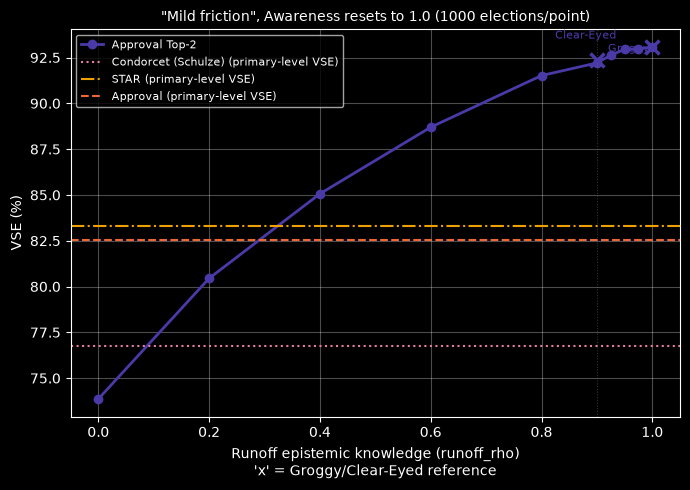

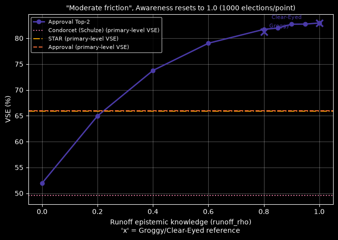

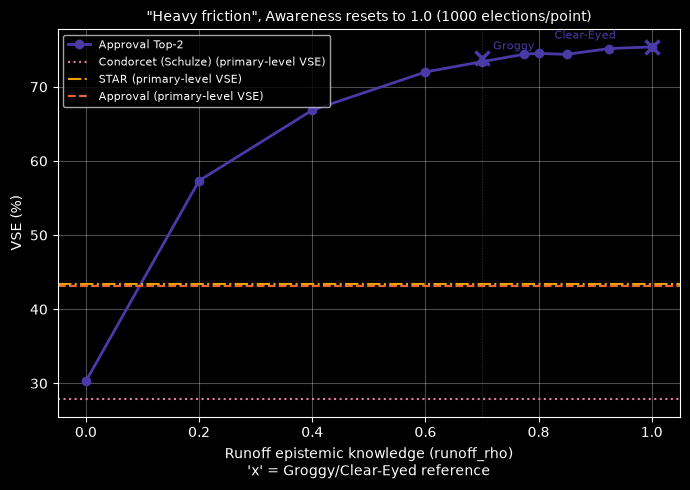

```python
_mode_name = "Awareness resets to 1.0"
for _baseline in RUNOFF_BASELINE_NAMES:
    fig, ax = plt.subplots(figsize=(7, 5))
    results_by_rt = runoff_sweep_results[_baseline][_mode_name]
    rho_numeric = sorted(rt for rt in results_by_rt if rt is not None)
    _baseline_rho = JOINT_SCENARIOS[_baseline]["epistemic_rho"]
    for label in RUNOFF_METHOD_FACTORIES:
        color = METHOD_COLORS[label]
        style = METHOD_LINESTYLES.get(label, "-")
        vses = [results_by_rt[rt][(label, "honBallot")][0] * 100 for rt in rho_numeric]
        ax.plot(rho_numeric, vses, marker="o", markersize=6, linewidth=2, color=color, linestyle=style, label=label)
        # runoff_rho=None (Groggy) plotted AT rho=_baseline_rho, not offset to the side -- with the
        # paired noise in sweep_runoff_rho, a fresh runoff_rho=_baseline_rho draw should land on (or
        # very near) this same point: a real sanity check, not just a visual approximation.
        # runoff_rho=1.0 (the curve's own right endpoint) is EXACTLY Clear-Eyed in this mode
        # (runoff_awareness_alpha=1.0 throughout) -- no separate computation needed.
        none_vse = results_by_rt[None][(label, "honBallot")][0] * 100
        ax.plot([_baseline_rho], [none_vse], marker="x", markersize=10, markeredgewidth=2.5, color=color, zorder=5)
        ax.annotate("Groggy", (_baseline_rho, none_vse), textcoords="offset points", xytext=(8, 6), fontsize=8, color=color)
        ax.plot([rho_numeric[-1]], [vses[-1]], marker="x", markersize=10, markeredgewidth=2.5, color=color, zorder=5)
        ax.annotate("Clear-Eyed", (rho_numeric[-1], vses[-1]), textcoords="offset points", xytext=(-70, 6), fontsize=8, color=color)
    for _ref_label, _ref_style in [("Condorcet (Schulze)", ":"), ("STAR", "-."), ("Approval", "--")]:
        _ref_vse = joint_results[_baseline][(_ref_label, "honBallot")][0] * 100
        ax.axhline(_ref_vse, color=METHOD_COLORS[_ref_label], linewidth=1.5, linestyle=_ref_style,
                   label=f"{_ref_label} (primary-level VSE)")
    ax.axvline(_baseline_rho, color="gray", linewidth=0.75, alpha=0.4, linestyle=":")
    #ax.set_xticks(rho_numeric)
    #ax.set_xticklabels([f"{rho:.2f}" for rho in rho_numeric])
    ax.set_xlabel("Runoff epistemic knowledge (runoff_rho)\n'x' = Groggy/Clear-Eyed reference")
    ax.set_ylabel("VSE (%)")
    ax.set_title(f'"{_baseline}", {_mode_name} ({RUNOFF_RHO_SWEEP_NITER} elections/point)', fontsize=10)
    ax.legend(fontsize=8, loc="best")
    ax.grid(True, alpha=0.3)
    plt.tight_layout()
    plt.show()
```

```python
for _baseline in RUNOFF_BASELINE_NAMES:
    for _mode in runoff_sweep_results[_baseline]:
        display(Markdown(f"#### {_baseline}, {_mode.lower()}: VSE by runoff_rho (honest ballots)"))
        results_by_rt = runoff_sweep_results[_baseline][_mode]
        rho_numeric = sorted(rt for rt in results_by_rt if rt is not None)
        header = ["Method", "None (=primary reused)"] + [f"rho={rho:.2f}" for rho in rho_numeric]
        lines = ["| " + " | ".join(header) + " |", "|" + "---|" * len(header)]
        for label in RUNOFF_METHOD_FACTORIES:
            row = [label]
            none_mean, none_ci = results_by_rt[None][(label, "honBallot")]
            row.append(f"{none_mean * 100:.1f}% (+/-{none_ci * 100:.1f})")
            for rt in rho_numeric:
                mean_, ci = results_by_rt[rt][(label, "honBallot")]
                row.append(f"{mean_ * 100:.1f}% (+/-{ci * 100:.1f})")
            lines.append("| " + " | ".join(row) + " |")
        display(Markdown("\n".join(lines)))
```

Mild friction, awareness resets to 1.0: VSE by runoff_rho (honest ballots)

| Method | None (=primary reused) | rho=0.00 | rho=0.20 | rho=0.40 | rho=0.60 | rho=0.80 | rho=0.90 | rho=0.93 | rho=0.95 | rho=0.97 | rho=1.00 |
| --- | --- | --- | --- | --- | --- | --- | --- | --- | --- | --- | --- |
| Approval Top-2 | 92.4% (+/-1.0) | 73.9% (+/-2.2) | 80.4% (+/-1.9) | 85.1% (+/-1.6) | 88.7% (+/-1.3) | 91.5% (+/-1.1) | 92.2% (+/-1.0) | 92.6% (+/-1.0) | 93.0% (+/-0.9) | 93.0% (+/-1.0) | 93.1% (+/-1.0) |

Moderate friction, awareness resets to 1.0: VSE by runoff_rho (honest ballots)

| Method | None (=primary reused) | rho=0.00 | rho=0.20 | rho=0.40 | rho=0.60 | rho=0.80 | rho=0.85 | rho=0.90 | rho=0.95 | rho=1.00 |
| --- | --- | --- | --- | --- | --- | --- | --- | --- | --- | --- |
| Approval Top-2 | 81.3% (+/-1.9) | 52.0% (+/-3.7) | 65.0% (+/-3.1) | 73.8% (+/-2.5) | 79.0% (+/-2.0) | 81.7% (+/-1.8) | 82.0% (+/-1.9) | 82.7% (+/-1.9) | 82.7% (+/-1.9) | 82.9% (+/-1.9) |

Heavy friction, awareness resets to 1.0: VSE by runoff_rho (honest ballots)

| Method | None (=primary reused) | rho=0.00 | rho=0.20 | rho=0.40 | rho=0.60 | rho=0.70 | rho=0.77 | rho=0.80 | rho=0.85 | rho=0.93 | rho=1.00 |
| --- | --- | --- | --- | --- | --- | --- | --- | --- | --- | --- | --- |
| Approval Top-2 | 73.9% (+/-2.3) | 30.3% (+/-5.0) | 57.3% (+/-3.6) | 66.9% (+/-2.9) | 72.0% (+/-2.5) | 73.4% (+/-2.4) | 74.4% (+/-2.3) | 74.5% (+/-2.3) | 74.4% (+/-2.4) | 75.2% (+/-2.3) | 75.4% (+/-2.3) |

### Isolating awareness alone: a genuine "chance to learn" sweep

The sweep above varies the runoff's epistemic knowledge (`runoff_rho`) under two different assumptions about how much awareness the runoff carries in -- but never holds epistemic knowledge FIXED and varies awareness on its own, in a way that's actually a clean "chance to learn" story. This sweep does that directly, using `Top2Base`'s `runoff_kappa` mode: a voter unaware of a given finalist in the primary gets one independent `Bernoulli(runoff_kappa)` roll to become aware of that specific finalist by runoff day; a voter already aware stays aware, no regression. `runoff_kappa=0.0` is an exact match for the Coma model -- no possible roll can succeed; `runoff_kappa=1.0` is an exact match for the default Groggy model -- every roll is certain to succeed. Everything in between is a genuine, monotonic interpolation: VSE can only move in one direction as `runoff_kappa` rises, unlike the `runoff_awareness_alpha`-driven sweep this replaces, which re-drew awareness fresh at every point.

`runoff_kappa` is swept from `0.0` to `1.0` (same range across all three friction baselines below -- unlike `runoff_rho`, its meaning doesn't depend on the primary's own `AWARENESS_ALPHA`), with `runoff_rho` pinned FIXED at one of two values: `None` (the runoff reuses the primary's own already-noisy information -- no epistemic improvement, only learning) or `1.0` (the runoff has perfect epistemic information regardless of learning). Only the `None` variant runs here at full precision (`RUNOFF_SWEEP_NITER` elections/point) -- it's the one that brackets both the Coma (`p=0`) and Groggy (`p=1`) models. The `runoff_rho=1.0` variant only brackets Clear-Eyed at its `p=1` endpoint, so it's relegated to the secondary, lower-precision section further down instead of doubling this section's runtime. Both reuse the same per-baseline electorate pool (`RUNOFF_ELECTORATE_POOLS`, defined above) the `runoff_rho` sweep already drew, across all three friction baselines. STAR and Schulze are shown as the same fixed reference lines as the sweep above.

```python
def sweep_runoff_learn(method_factories, learn_kappa_values, primary_params, niter,
                        runoff_rho_fixed, electorates=None, paired_baseline=None):
    """Like sweep_runoff_rho, but holds runoff_rho FIXED at runoff_rho_fixed for every point and
    sweeps runoff_kappa instead -- isolates the "chance to learn" axis alone, holding the
    runoff's own epistemic-noise level constant throughout. At each swept point, a voter unaware
    of a given finalist in the primary gets one independent Bernoulli(runoff_kappa) roll to
    become aware of THAT finalist by runoff day (see Top2Base._runoff_electorate's
    runoff_kappa branch above). runoff_kappa=0.0 is an exact match for Coma; runoff_kappa=
    1.0 is an exact match for Groggy -- not approximations. runoff_rho_fixed=None reuses the
    primary's own (possibly noisy) epistemic level for the runoff; runoff_rho_fixed=1.0 gives the
    runoff perfect epistemic information regardless of learning. electorates: optional shared
    pool, same convention as sweep_runoff_rho/sweep_methods.

    paired_baseline: optional (label, method) pair, e.g. ("STAR", METHODS_LOOKUP["STAR"]) --
    evaluated ONCE per election (not once per swept kappa, since STAR's own automatic runoff doesn't
    depend on AT2's runoff_kappa axis at all), on the SAME ballot_electorate/perceived_electorate
    every swept (label, kappa) combination sees that election -- a genuine paired comparison, not an
    independent-samples one (unlike combining this sweep's own CI with a DIFFERENT electorate
    pool's CI, e.g. joint_results). Tracks the baseline's own (mean, ci) too, not just the diff,
    so a caller can display a self-consistent AT2/baseline/gap table computed from one shared set
    of elections. Returns (results_by_kappa, paired_diff_by_kappa, baseline_mean_ci) -- paired_diff_by_kappa
    empty and baseline_mean_ci None when paired_baseline isn't given.

    Returns (results_by_kappa, paired_diff_by_kappa, baseline_mean_ci); results_by_kappa is
    {runoff_kappa: {(label, chooser): (mean, ci)}}.
    """
    sweep_start_time = time.time()
    epistemic_rho = primary_params.get("epistemic_rho", 1.0)
    awareness_alpha = primary_params.get("awareness_alpha", 1.0)
    fatigue_beta = primary_params.get("fatigue_beta", 1.0)
    summary = {kappa: defaultdict(lambda: [0, 0.0, 0.0]) for kappa in learn_kappa_values}
    paired_diff_summary = {kappa: [0, 0.0, 0.0] for kappa in learn_kappa_values}
    baseline_summary = [0, 0.0, 0.0]
    baseline_label, baseline_method = paired_baseline if paired_baseline else (None, None)
    for i in range(niter):
        true_electorate = electorates[i] if electorates is not None else MODEL(NVOT, NCAND)
        perceived_electorate = make_perceived_electorate(true_electorate, epistemic_rho)
        ballot_electorate, _, aware_sets = apply_participation_friction(
            perceived_electorate, true_electorate, awareness_alpha, fatigue_beta
        )  # aware_sets IS needed here (unlike sweep_runoff_rho/the old sweep_runoff_awareness) --
           # runoff_kappa reads self._aware_sets, so it must be threaded through below.
        baseline_vse = None
        if baseline_method is not None:
            baseline_row = next(
                r for r in baseline_method.resultsTable(
                    i, str(MODEL), NCAND, ballot_electorate, [],
                    media=MEDIA, scoring_voters=true_electorate, perceived_voters=perceived_electorate,
                    honest_only=True,
                ) if r["chooser"] == "honBallot"
            )
            baseline_vse = baseline_row["vse"]
            baseline_summary[0] += 1
            baseline_summary[1] += baseline_vse
            baseline_summary[2] += baseline_vse ** 2
        for label, factory in method_factories.items():
            for kappa in learn_kappa_values:
                for row in factory(runoff_rho_fixed, kappa).resultsTable(
                    i, str(MODEL), NCAND, ballot_electorate, CHOOSER_FUNS,
                    media=MEDIA, scoring_voters=true_electorate, perceived_voters=perceived_electorate,
                    aware_sets=aware_sets, honest_only=True,
                ):
                    acc = summary[kappa][(label, row["chooser"])]
                    acc[0] += 1
                    acc[1] += row["vse"]
                    acc[2] += row["vse"] ** 2
                    if baseline_vse is not None and row["chooser"] == "honBallot":
                        dacc = paired_diff_summary[kappa]
                        d = row["vse"] - baseline_vse
                        dacc[0] += 1
                        dacc[1] += d
                        dacc[2] += d ** 2
        if (i + 1) % 100 == 0:
            print(f"{i + 1}/{niter} elections done in {time.time() - sweep_start_time:.1f}s")
    results_by_kappa = {kappa: reduce_to_mean_ci(dict(summary[kappa])) for kappa in learn_kappa_values}
    paired_diff_by_kappa = (
        {kappa: reduce_to_mean_ci({"_": paired_diff_summary[kappa]})["_"] for kappa in learn_kappa_values}
        if paired_baseline else {}
    )
    baseline_mean_ci = reduce_to_mean_ci({"_": baseline_summary})["_"] if paired_baseline else None
    return results_by_kappa, paired_diff_by_kappa, baseline_mean_ci
```

### Sweeping the learn rate

```python
RUNOFF_KAPPA_VALUES = np.array(
    sorted(
        set(np.linspace(0.0, 1.0, 6))
        | set(np.linspace(0.1, 0.3, 7))
        | {0.25}
        | {1 / 3}
    )
)  # adds 0.25/0.3/0.35 between the existing 0.2/0.4 grid points, to narrow down where AT2
    # crosses significantly ahead of STAR (see the paired threshold table below). Same range for
    # all three baselines -- unlike runoff_rho, runoff_kappa's meaning doesn't depend on the
    # primary's own AWARENESS_ALPHA.
RUNOFF_T_FIXED_VARIANTS = {
    "primary's own noise (runoff_rho=None)": None,
    "perfect runoff information (runoff_rho=1.0)": 1.0,
}
# Only "runoff_rho=None" runs at full precision below -- it's the variant that brackets both Coma
# (kappa=0) and Groggy (kappa=1). "runoff_rho=1.0" only brackets Clear-Eyed at its kappa=1 endpoint, so it's
# relegated to the lower-precision secondary section further down instead of doubling this
# section's main runtime.
RUNOFF_T_FIXED_VARIANTS_MAIN = {
    "primary's own noise (runoff_rho=None)": RUNOFF_T_FIXED_VARIANTS["primary's own noise (runoff_rho=None)"],
}
RUNOFF_LEARN_METHOD_FACTORIES = {
    "Approval Top-2": lambda rt, kappa: ApprovalTop2(runoff_rho=rt, runoff_kappa=kappa),
}
```

```python
learn_sweep_results = {}  # {baseline: {variant_name: {kappa: {(label, chooser): (mean, ci)}}}}
learn_sweep_paired_diff = {}  # {baseline: {variant_name: {kappa: (mean, ci)}}} -- AT2 - STAR, paired
learn_sweep_baseline = {}  # {baseline: {variant_name: (mean, ci)}} -- STAR's own VSE, same electorates as AT2
for _baseline in RUNOFF_BASELINE_NAMES:
    learn_sweep_results[_baseline] = {}
    learn_sweep_paired_diff[_baseline] = {}
    learn_sweep_baseline[_baseline] = {}
    for _variant_name, _rt_fixed in RUNOFF_T_FIXED_VARIANTS_MAIN.items():
        print(f"{_baseline}, {_variant_name}:")
        (learn_sweep_results[_baseline][_variant_name],
         learn_sweep_paired_diff[_baseline][_variant_name],
         learn_sweep_baseline[_baseline][_variant_name]) = sweep_runoff_learn(
            RUNOFF_LEARN_METHOD_FACTORIES, RUNOFF_KAPPA_VALUES,
            JOINT_SCENARIOS[_baseline], RUNOFF_SWEEP_NITER, _rt_fixed,
            electorates=RUNOFF_ELECTORATE_POOLS[_baseline],
            paired_baseline=("STAR", METHODS_LOOKUP["STAR"]),
        )
```

```
Mild friction, primary's own noise (runoff_rho=None):
```

```
100/3500 elections done in 2.6s
```

```
200/3500 elections done in 5.1s
```

```
300/3500 elections done in 7.7s
```

```
400/3500 elections done in 10.2s
```

```
500/3500 elections done in 12.7s
```

```
600/3500 elections done in 15.4s
```

```
700/3500 elections done in 18.0s
```

```
800/3500 elections done in 20.6s
```

```
900/3500 elections done in 23.1s
```

```
1000/3500 elections done in 25.6s
```

```
1100/3500 elections done in 28.2s
```

```
1200/3500 elections done in 30.8s
```

```
1300/3500 elections done in 33.3s
```

```
1400/3500 elections done in 35.9s
```

```
1500/3500 elections done in 38.4s
```

```
1600/3500 elections done in 41.1s
```

```
1700/3500 elections done in 43.7s
```

```
1800/3500 elections done in 46.2s
```

```
1900/3500 elections done in 49.1s
```

```
2000/3500 elections done in 51.7s
```

```
2100/3500 elections done in 54.2s
```

```
2200/3500 elections done in 56.8s
```

```
2300/3500 elections done in 59.3s
```

```
2400/3500 elections done in 61.9s
```

```
2500/3500 elections done in 64.4s
```

```
2600/3500 elections done in 66.9s
```

```
2700/3500 elections done in 69.7s
```

```
2800/3500 elections done in 72.2s
```

```
2900/3500 elections done in 74.8s
```

```
3000/3500 elections done in 77.4s
```

```
3100/3500 elections done in 80.1s
```

```
3200/3500 elections done in 82.8s
```

```
3300/3500 elections done in 85.3s
```

```
3400/3500 elections done in 88.0s
```

```
3500/3500 elections done in 90.6s
Moderate friction, primary's own noise (runoff_rho=None):
```

```
100/3500 elections done in 2.7s
```

```
200/3500 elections done in 5.5s
```

```
300/3500 elections done in 8.3s
```

```
400/3500 elections done in 11.1s
```

```
500/3500 elections done in 13.9s
```

```
600/3500 elections done in 16.7s
```

```
700/3500 elections done in 19.5s
```

```
800/3500 elections done in 22.2s
```

```
900/3500 elections done in 25.0s
```

```
1000/3500 elections done in 27.7s
```

```
1100/3500 elections done in 30.5s
```

```
1200/3500 elections done in 33.3s
```

```
1300/3500 elections done in 36.2s
```

```
1400/3500 elections done in 38.9s
```

```
1500/3500 elections done in 41.7s
```

```
1600/3500 elections done in 44.5s
```

```
1700/3500 elections done in 47.3s
```

```
1800/3500 elections done in 50.0s
```

```
1900/3500 elections done in 53.0s
```

```
2000/3500 elections done in 55.9s
```

```
2100/3500 elections done in 58.8s
```

```
2200/3500 elections done in 61.6s
```

```
2300/3500 elections done in 64.7s
```

```
2400/3500 elections done in 67.5s
```

```
2500/3500 elections done in 70.4s
```

```
2600/3500 elections done in 73.2s
```

```
2700/3500 elections done in 76.0s
```

```
2800/3500 elections done in 78.8s
```

```
2900/3500 elections done in 81.6s
```

```
3000/3500 elections done in 84.3s
```

```
3100/3500 elections done in 87.1s
```

```
3200/3500 elections done in 90.0s
```

```
3300/3500 elections done in 92.8s
```

```
3400/3500 elections done in 95.6s
```

```
3500/3500 elections done in 98.9s
Heavy friction, primary's own noise (runoff_rho=None):
```

```
100/3500 elections done in 2.8s
```

```
200/3500 elections done in 5.7s
```

```
300/3500 elections done in 8.5s
```

```
400/3500 elections done in 11.5s
```

```
500/3500 elections done in 14.3s
```

```
600/3500 elections done in 17.2s
```

```
700/3500 elections done in 20.1s
```

```
800/3500 elections done in 22.9s
```

```
900/3500 elections done in 25.7s
```

```
1000/3500 elections done in 28.5s
```

```
1100/3500 elections done in 31.3s
```

```
1200/3500 elections done in 34.2s
```

```
1300/3500 elections done in 37.1s
```

```
1400/3500 elections done in 40.2s
```

```
1500/3500 elections done in 42.7s
```

```
1600/3500 elections done in 44.9s
```

```
1700/3500 elections done in 47.8s
```

```
1800/3500 elections done in 50.6s
```

```
1900/3500 elections done in 53.5s
```

```
2000/3500 elections done in 56.5s
```

```
2100/3500 elections done in 59.3s
```

```
2200/3500 elections done in 62.1s
```

```
2300/3500 elections done in 64.9s
```

```
2400/3500 elections done in 67.7s
```

```
2500/3500 elections done in 70.5s
```

```
2600/3500 elections done in 73.4s
```

```
2700/3500 elections done in 76.3s
```

```
2800/3500 elections done in 79.1s
```

```
2900/3500 elections done in 81.9s
```

```
3000/3500 elections done in 84.8s
```

```
3100/3500 elections done in 87.6s
```

```
3200/3500 elections done in 90.4s
```

```
3300/3500 elections done in 93.4s
```

```
3400/3500 elections done in 96.3s
```

```
3500/3500 elections done in 99.3s
```

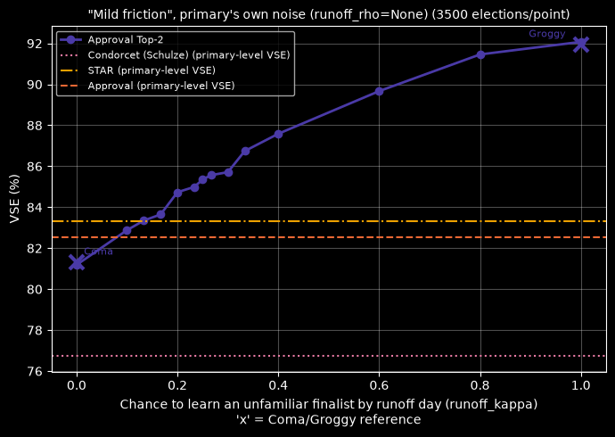

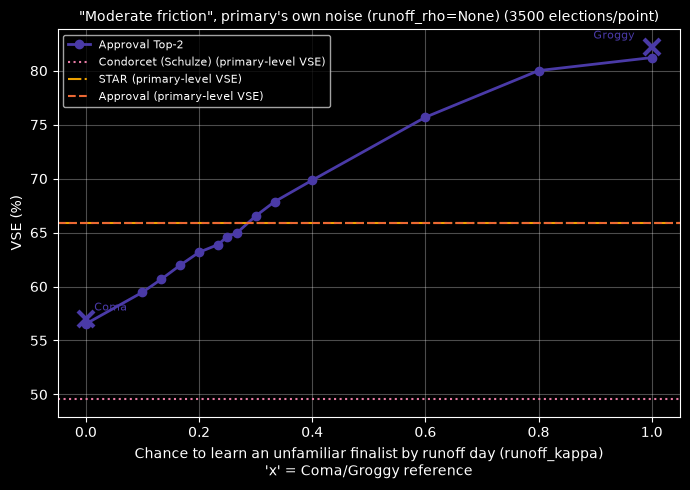

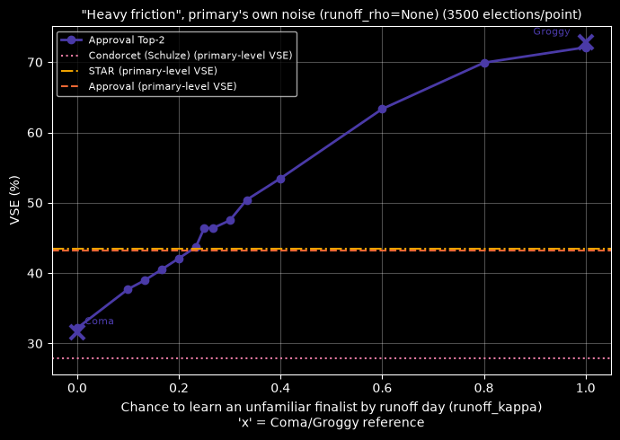

```python
_variant_name = "primary's own noise (runoff_rho=None)"
_rt_fixed = RUNOFF_T_FIXED_VARIANTS[_variant_name]
for _baseline in RUNOFF_BASELINE_NAMES:
    fig, ax = plt.subplots(figsize=(7, 5))
    results_by_kappa = learn_sweep_results[_baseline][_variant_name]
    kappa_values = sorted(results_by_kappa)
    for label in RUNOFF_LEARN_METHOD_FACTORIES:
        color = METHOD_COLORS[label]
        style = METHOD_LINESTYLES.get(label, "-")
        vses = [results_by_kappa[kappa][(label, "honBallot")][0] * 100 for kappa in kappa_values]
        ax.plot(kappa_values, vses, marker="o", markersize=6, linewidth=2, color=color, linestyle=style, label=label)
        # kappa=0 is an EXACT match for "<label> (Coma)"; kappa=1 an EXACT match for plain
        # "<label>" (Groggy, the default) -- see RUNOFF_LEARN_METHOD_FACTORIES above.
        _coma_vse = joint_results[_baseline][(f"{label} (Coma)", "honBallot")][0] * 100
        ax.plot([0], [_coma_vse], marker="x", markersize=12, markeredgewidth=3, color=color, zorder=5)
        ax.annotate("Coma", (0, _coma_vse), textcoords="offset points", xytext=(6, 6), fontsize=8, color=color)
        _groggy_vse = joint_results[_baseline][(label, "honBallot")][0] * 100
        ax.plot([1], [_groggy_vse], marker="x", markersize=12, markeredgewidth=3, color=color, zorder=5)
        ax.annotate("Groggy", (1, _groggy_vse), textcoords="offset points", xytext=(-42, 6), fontsize=8, color=color)
    for _ref_label, _ref_style in [("Condorcet (Schulze)", ":"), ("STAR", "-."), ("Approval", "--")]:
        _ref_vse = joint_results[_baseline][(_ref_label, "honBallot")][0] * 100
        ax.axhline(_ref_vse, color=METHOD_COLORS[_ref_label], linewidth=1.5, linestyle=_ref_style,
                   label=f"{_ref_label} (primary-level VSE)")
    ax.set_xlabel("Chance to learn an unfamiliar finalist by runoff day (runoff_kappa)\n'x' = Coma/Groggy reference")
    ax.set_ylabel("VSE (%)")
    ax.set_title(f'"{_baseline}", {_variant_name} ({RUNOFF_SWEEP_NITER} elections/point)', fontsize=10)
    ax.legend(fontsize=8, loc="best")
    ax.grid(True, alpha=0.3)
    plt.tight_layout()
    plt.show()
```

```python
_variant_name = "primary's own noise (runoff_rho=None)"
display(Markdown("### kappa threshold for AT2 VSE > STAR VSE (95% confidence, paired)\n"))
for _baseline in RUNOFF_BASELINE_NAMES:
    results_by_kappa = learn_sweep_results[_baseline][_variant_name]
    paired_diff_by_kappa = learn_sweep_paired_diff[_baseline][_variant_name]
    star_mean, star_ci = learn_sweep_baseline[_baseline][_variant_name]
    kappa_values = sorted(results_by_kappa)

    lines = [
        f"#### {_baseline}",
        "",
        "| kappa | AT2 VSE (%) | STAR VSE (%) | Gap (pp, paired) | 95% CI (paired, pp) | AT2 > STAR? |",
        "|---|---|---|---|---|---|",
    ]
    threshold_kappa = None
    for kappa in kappa_values:
        at2_mean, _ = results_by_kappa[kappa][("Approval Top-2", "honBallot")]
        gap_mean, ci = paired_diff_by_kappa[kappa]
        gap, ci = gap_mean * 100, ci * 100
        _register_significance(f"kappa threshold: {_baseline}", f"kappa={kappa:.2f}", gap, ci, "Approval Top-2", "STAR", spotlight=True)
        _bucket, sig = _verdict_text(gap, ci, "Approval Top-2", "STAR")
        if gap > 0 and _bucket not in ("INDISTINGUISHABLE", "INCONCLUSIVE") and threshold_kappa is None:
            threshold_kappa = kappa
        lines.append(
            f"| {kappa:.2f} | {at2_mean*100:.1f} | {star_mean*100:.1f} (+/-{star_ci*100:.1f}) | "
            f"{gap:+.1f} | [{gap-ci:+.1f}, {gap+ci:+.1f}] | {sig} |"
        )
    display(Markdown("\n".join(lines)))
    if threshold_kappa is not None:
        display(Markdown(
            f"**-> First kappa where AT2 is significantly better than STAR in {_baseline} (95% CI gap > 0): `kappa ~ {threshold_kappa:.2f}`**\n"
        ))
    else:
        display(Markdown("**-> AT2 does not significantly exceed STAR at any tested kappa value.**\n"))
```

kappa threshold for AT2 VSE > STAR VSE (95% confidence, paired)

Mild friction

| kappa | AT2 VSE (%) | STAR VSE (%) | Gap (pp, paired) | 95% CI (paired, pp) | AT2 > STAR? |
| --- | --- | --- | --- | --- | --- |
| 0.00 | 81.2 | 83.5 (+/-0.9) | -2.3 | [-3.0, -1.6] | Decisive (STAR better) |
| 0.10 | 82.9 | 83.5 (+/-0.9) | -0.6 | [-1.3, +0.1] | Inconclusive |
| 0.13 | 83.4 | 83.5 (+/-0.9) | -0.1 | [-0.8, +0.5] | Indistinguishable |
| 0.17 | 83.6 | 83.5 (+/-0.9) | +0.2 | [-0.5, +0.8] | Indistinguishable |
| 0.20 | 84.7 | 83.5 (+/-0.9) | +1.2 | [+0.6, +1.9] | Ambiguous edge (Approval Top-2 better) |
| 0.23 | 85.0 | 83.5 (+/-0.9) | +1.5 | [+0.8, +2.2] | Ambiguous edge (Approval Top-2 better) |
| 0.25 | 85.4 | 83.5 (+/-0.9) | +1.9 | [+1.2, +2.5] | Decisive (Approval Top-2 better) |
| 0.27 | 85.6 | 83.5 (+/-0.9) | +2.1 | [+1.4, +2.8] | Decisive (Approval Top-2 better) |
| 0.30 | 85.7 | 83.5 (+/-0.9) | +2.2 | [+1.5, +2.9] | Decisive (Approval Top-2 better) |
| 0.33 | 86.7 | 83.5 (+/-0.9) | +3.2 | [+2.6, +3.9] | Decisive (Approval Top-2 better) |
| 0.40 | 87.6 | 83.5 (+/-0.9) | +4.1 | [+3.4, +4.8] | Decisive (Approval Top-2 better) |
| 0.60 | 89.7 | 83.5 (+/-0.9) | +6.2 | [+5.4, +6.9] | Decisive (Approval Top-2 better) |
| 0.80 | 91.5 | 83.5 (+/-0.9) | +8.0 | [+7.2, +8.8] | Decisive (Approval Top-2 better) |
| 1.00 | 92.1 | 83.5 (+/-0.9) | +8.6 | [+7.7, +9.4] | Decisive (Approval Top-2 better) |

**-> First kappa where AT2 is significantly better than STAR in Mild friction (95% CI gap > 0): `kappa ~ 0.20`**

Moderate friction

| kappa | AT2 VSE (%) | STAR VSE (%) | Gap (pp, paired) | 95% CI (paired, pp) | AT2 > STAR? |
| --- | --- | --- | --- | --- | --- |
| 0.00 | 56.5 | 64.5 (+/-1.6) | -8.0 | [-9.1, -6.8] | Decisive (STAR better) |
| 0.10 | 59.5 | 64.5 (+/-1.6) | -5.0 | [-6.1, -3.9] | Decisive (STAR better) |
| 0.13 | 60.7 | 64.5 (+/-1.6) | -3.8 | [-4.9, -2.8] | Decisive (STAR better) |
| 0.17 | 62.0 | 64.5 (+/-1.6) | -2.5 | [-3.6, -1.5] | Decisive (STAR better) |
| 0.20 | 63.2 | 64.5 (+/-1.6) | -1.3 | [-2.4, -0.3] | Ambiguous edge (STAR better) |
| 0.23 | 63.9 | 64.5 (+/-1.6) | -0.6 | [-1.6, +0.4] | Inconclusive |
| 0.25 | 64.6 | 64.5 (+/-1.6) | +0.1 | [-0.9, +1.1] | Inconclusive |
| 0.27 | 65.0 | 64.5 (+/-1.6) | +0.5 | [-0.6, +1.5] | Inconclusive |
| 0.30 | 66.5 | 64.5 (+/-1.6) | +2.0 | [+0.9, +3.1] | Ambiguous edge (Approval Top-2 better) |
| 0.33 | 67.9 | 64.5 (+/-1.6) | +3.3 | [+2.3, +4.4] | Decisive (Approval Top-2 better) |
| 0.40 | 69.9 | 64.5 (+/-1.6) | +5.3 | [+4.2, +6.4] | Decisive (Approval Top-2 better) |
| 0.60 | 75.7 | 64.5 (+/-1.6) | +11.2 | [+9.9, +12.4] | Decisive (Approval Top-2 better) |
| 0.80 | 80.0 | 64.5 (+/-1.6) | +15.5 | [+14.2, +16.8] | Decisive (Approval Top-2 better) |
| 1.00 | 81.2 | 64.5 (+/-1.6) | +16.7 | [+15.3, +18.1] | Decisive (Approval Top-2 better) |

**-> First kappa where AT2 is significantly better than STAR in Moderate friction (95% CI gap > 0): `kappa ~ 0.30`**

Heavy friction

| kappa | AT2 VSE (%) | STAR VSE (%) | Gap (pp, paired) | 95% CI (paired, pp) | AT2 > STAR? |
| --- | --- | --- | --- | --- | --- |
| 0.00 | 32.2 | 44.1 (+/-2.2) | -11.9 | [-13.6, -10.3] | Decisive (STAR better) |
| 0.10 | 37.7 | 44.1 (+/-2.2) | -6.4 | [-7.8, -5.0] | Decisive (STAR better) |
| 0.13 | 39.0 | 44.1 (+/-2.2) | -5.1 | [-6.5, -3.8] | Decisive (STAR better) |
| 0.17 | 40.5 | 44.1 (+/-2.2) | -3.6 | [-5.0, -2.2] | Decisive (STAR better) |
| 0.20 | 42.1 | 44.1 (+/-2.2) | -2.0 | [-3.4, -0.7] | Ambiguous edge (STAR better) |
| 0.23 | 43.7 | 44.1 (+/-2.2) | -0.4 | [-1.8, +0.9] | Inconclusive |
| 0.25 | 46.4 | 44.1 (+/-2.2) | +2.3 | [+1.0, +3.6] | Decisive (Approval Top-2 better) |
| 0.27 | 46.4 | 44.1 (+/-2.2) | +2.3 | [+0.9, +3.6] | Ambiguous edge (Approval Top-2 better) |
| 0.30 | 47.5 | 44.1 (+/-2.2) | +3.4 | [+2.0, +4.7] | Decisive (Approval Top-2 better) |
| 0.33 | 50.4 | 44.1 (+/-2.2) | +6.3 | [+4.9, +7.7] | Decisive (Approval Top-2 better) |
| 0.40 | 53.5 | 44.1 (+/-2.2) | +9.4 | [+7.9, +10.8] | Decisive (Approval Top-2 better) |
| 0.60 | 63.3 | 44.1 (+/-2.2) | +19.2 | [+17.5, +20.9] | Decisive (Approval Top-2 better) |
| 0.80 | 69.9 | 44.1 (+/-2.2) | +25.8 | [+23.9, +27.7] | Decisive (Approval Top-2 better) |
| 1.00 | 72.1 | 44.1 (+/-2.2) | +28.0 | [+26.1, +29.9] | Decisive (Approval Top-2 better) |

**-> First kappa where AT2 is significantly better than STAR in Heavy friction (95% CI gap > 0): `kappa ~ 0.25`**

```python
# Adjust SECONDARY_SWEEP_NITER for this cell in Section 5 (Parameters).
SKIP_CELL = True
if not SKIP_CELL:
    _secondary_awareness_mode = {"Awareness carries over from primary": RUNOFF_AWARENESS_MODES["Awareness carries over from primary"]}
    _secondary_learn_variant = {"perfect runoff information (runoff_rho=1.0)": RUNOFF_T_FIXED_VARIANTS["perfect runoff information (runoff_rho=1.0)"]}

    secondary_runoff_sweep_results = {}  # {baseline: {"Awareness carries over from primary": {runoff_rho: {(label, chooser): (mean, ci)}}}}
    secondary_learn_sweep_results = {}  # {baseline: {"perfect runoff information (runoff_rho=1.0)": {kappa: {(label, chooser): (mean, ci)}}}}
    for _baseline in RUNOFF_BASELINE_NAMES:
        _primary_params = JOINT_SCENARIOS[_baseline]
        _primary_aw = _primary_params["awareness_alpha"]
        _secondary_electorates = RUNOFF_ELECTORATE_POOLS[_baseline][:SECONDARY_SWEEP_NITER]
        _awareness_fns = {
            mode_name: (lambda rt, _fn=fn: _fn(rt, _primary_aw))
            for mode_name, fn in _secondary_awareness_mode.items()
        }
        print(f"{_baseline} (secondary, runoff_rho sweep):")
        secondary_runoff_sweep_results[_baseline] = sweep_runoff_rho(
            RUNOFF_METHOD_FACTORIES, RUNOFF_RHO_VALUES_BY_BASELINE[_baseline],
            _primary_params, SECONDARY_SWEEP_NITER, _awareness_fns,
            electorates=_secondary_electorates,
        )
        secondary_learn_sweep_results[_baseline] = {}
        for _variant_name, _rt_fixed in _secondary_learn_variant.items():
            print(f"{_baseline} (secondary, learn sweep), {_variant_name}:")
            secondary_learn_sweep_results[_baseline][_variant_name], _, _ = sweep_runoff_learn(
                RUNOFF_LEARN_METHOD_FACTORIES, RUNOFF_KAPPA_VALUES,
                _primary_params, SECONDARY_SWEEP_NITER, _rt_fixed,
                electorates=_secondary_electorates,
            )
```

```python
if not SKIP_CELL:
    fig, axes = plt.subplots(2, 2, figsize=(14, 10), sharey=True)

    # Row A: same runoff_rho sweep as the Groggy -> Clear-Eyed chart above, but awareness carries over
    # from the primary instead of resetting to 1.0. Neither endpoint matches a named model here
    # (runoff_awareness_alpha=primary_aw throughout, not 1.0) -- no Groggy/Clear-Eyed anchor to mark.
    _mode_name = "Awareness carries over from primary"
    for col_i, _baseline in enumerate(RUNOFF_BASELINE_NAMES):
        ax = axes[0, col_i]
        results_by_rt = secondary_runoff_sweep_results[_baseline][_mode_name]
        rho_numeric = sorted(rt for rt in results_by_rt if rt is not None)
        _baseline_rho = JOINT_SCENARIOS[_baseline]["epistemic_rho"]
        for label in RUNOFF_METHOD_FACTORIES:
            color = METHOD_COLORS[label]
            style = METHOD_LINESTYLES.get(label, "-")
            vses = [results_by_rt[rt][(label, "honBallot")][0] * 100 for rt in rho_numeric]
            ax.plot(rho_numeric, vses, marker="o", markersize=6, linewidth=2, color=color, linestyle=style, label=label)
        for _ref_label, _ref_style in [("Condorcet (Schulze)", ":"), ("STAR", "-.")]:
            _ref_vse = joint_results[_baseline][(_ref_label, "honBallot")][0] * 100
            ax.axhline(_ref_vse, color=METHOD_COLORS[_ref_label], linewidth=1.5, linestyle=_ref_style,
                    label=f"{_ref_label} (primary-level VSE)")
        ax.axvline(_baseline_rho, color="gray", linewidth=0.75, alpha=0.4, linestyle=":")
        ax.set_xticks(rho_numeric)
        ax.set_xticklabels([f"{rho:.2f}" for rho in rho_numeric])
        ax.set_xlabel("Runoff epistemic knowledge (runoff_rho)")
        ax.set_title(f'"{_baseline}", awareness carries over from primary', fontsize=10)
        ax.grid(True, alpha=0.3)
    axes[0, 0].set_ylabel("VSE (%)")

    # Row B: same runoff_kappa sweep as the Coma -> Groggy chart above, but with runoff_rho fixed at
    # 1.0 (perfect epistemic information) instead of None. Only the kappa=1 endpoint matches a named
    # model (Clear-Eyed) -- there's no independent reference at kappa=0 for this branch.
    _variant_name = "perfect runoff information (runoff_rho=1.0)"
    for col_i, _baseline in enumerate(RUNOFF_BASELINE_NAMES):
        ax = axes[1, col_i]
        results_by_kappa = secondary_learn_sweep_results[_baseline][_variant_name]
        kappa_values = sorted(results_by_kappa)
        for label in RUNOFF_LEARN_METHOD_FACTORIES:
            color = METHOD_COLORS[label]
            style = METHOD_LINESTYLES.get(label, "-")
            vses = [results_by_kappa[kappa][(label, "honBallot")][0] * 100 for kappa in kappa_values]
            ax.plot(kappa_values, vses, marker="o", markersize=6, linewidth=2, color=color, linestyle=style, label=label)
            _clear_eyed_vse = joint_results[_baseline][(f"{label} (Clear-Eyed)", "honBallot")][0] * 100
            ax.plot([1], [_clear_eyed_vse], marker="x", markersize=12, markeredgewidth=3, color=color, zorder=5)
            ax.annotate("Clear-Eyed", (1, _clear_eyed_vse), textcoords="offset points", xytext=(-60, 6), fontsize=8, color=color)
        for _ref_label, _ref_style in [("Condorcet (Schulze)", ":"), ("STAR", "-.")]:
            _ref_vse = joint_results[_baseline][(_ref_label, "honBallot")][0] * 100
            ax.axhline(_ref_vse, color=METHOD_COLORS[_ref_label], linewidth=1.5, linestyle=_ref_style,
                    label=f"{_ref_label} (primary-level VSE)")
        ax.set_xlabel("Chance to learn an unfamiliar finalist by runoff day (runoff_kappa)")
        ax.set_title(f'"{_baseline}", perfect runoff information (runoff_rho=1.0)', fontsize=10)
        ax.grid(True, alpha=0.3)
    axes[1, 0].set_ylabel("VSE (%)")

    handles, labels_ = axes[0, 0].get_legend_handles_labels()
    fig.legend(handles, labels_, loc="lower center", fontsize=9, ncol=3, bbox_to_anchor=(0.5, -0.02))
    fig.suptitle(f"Secondary Section 21 sweeps: variants that don't bracket a single named model ({SECONDARY_SWEEP_NITER} elections/point)")
    plt.tight_layout()
    plt.show()
```

```python
for _baseline in RUNOFF_BASELINE_NAMES:
    for _variant_name in learn_sweep_results[_baseline]:
        display(Markdown(f"#### {_baseline}, runoff learning swept, {_variant_name}: VSE by runoff_kappa (honest ballots)"))
        results_by_kappa = learn_sweep_results[_baseline][_variant_name]
        kappa_values = sorted(results_by_kappa)
        header = ["Method"] + [f"kappa={kappa:.2f}" for kappa in kappa_values]
        lines = ["| " + " | ".join(header) + " |", "|" + "---|" * len(header)]
        for label in RUNOFF_LEARN_METHOD_FACTORIES:
            row = [label]
            for kappa in kappa_values:
                mean_, ci = results_by_kappa[kappa][(label, "honBallot")]
                row.append(f"{mean_ * 100:.1f}% (+/-{ci * 100:.1f})")
            lines.append("| " + " | ".join(row) + " |")
        display(Markdown("\n".join(lines)))
```

Mild friction, runoff learning swept, primary's own noise (runoff_rho=None): VSE by runoff_kappa (honest ballots)

| Method | kappa=0.00 | kappa=0.10 | kappa=0.13 | kappa=0.17 | kappa=0.20 | kappa=0.23 | kappa=0.25 | kappa=0.27 | kappa=0.30 | kappa=0.33 | kappa=0.40 | kappa=0.60 | kappa=0.80 | kappa=1.00 |
| --- | --- | --- | --- | --- | --- | --- | --- | --- | --- | --- | --- | --- | --- | --- |
| Approval Top-2 | 81.2% (+/-1.0) | 82.9% (+/-1.0) | 83.4% (+/-0.9) | 83.6% (+/-0.9) | 84.7% (+/-0.9) | 85.0% (+/-0.9) | 85.4% (+/-0.9) | 85.6% (+/-0.9) | 85.7% (+/-0.9) | 86.7% (+/-0.8) | 87.6% (+/-0.8) | 89.7% (+/-0.7) | 91.5% (+/-0.6) | 92.1% (+/-0.6) |

Moderate friction, runoff learning swept, primary's own noise (runoff_rho=None): VSE by runoff_kappa (honest ballots)

| Method | kappa=0.00 | kappa=0.10 | kappa=0.13 | kappa=0.17 | kappa=0.20 | kappa=0.23 | kappa=0.25 | kappa=0.27 | kappa=0.30 | kappa=0.33 | kappa=0.40 | kappa=0.60 | kappa=0.80 | kappa=1.00 |
| --- | --- | --- | --- | --- | --- | --- | --- | --- | --- | --- | --- | --- | --- | --- |
| Approval Top-2 | 56.5% (+/-1.8) | 59.5% (+/-1.7) | 60.7% (+/-1.7) | 62.0% (+/-1.7) | 63.2% (+/-1.6) | 63.9% (+/-1.6) | 64.6% (+/-1.6) | 65.0% (+/-1.6) | 66.5% (+/-1.5) | 67.9% (+/-1.5) | 69.9% (+/-1.4) | 75.7% (+/-1.3) | 80.0% (+/-1.1) | 81.2% (+/-1.0) |

Heavy friction, runoff learning swept, primary's own noise (runoff_rho=None): VSE by runoff_kappa (honest ballots)

| Method | kappa=0.00 | kappa=0.10 | kappa=0.13 | kappa=0.17 | kappa=0.20 | kappa=0.23 | kappa=0.25 | kappa=0.27 | kappa=0.30 | kappa=0.33 | kappa=0.40 | kappa=0.60 | kappa=0.80 | kappa=1.00 |
| --- | --- | --- | --- | --- | --- | --- | --- | --- | --- | --- | --- | --- | --- | --- |
| Approval Top-2 | 32.2% (+/-2.5) | 37.7% (+/-2.4) | 39.0% (+/-2.3) | 40.5% (+/-2.3) | 42.1% (+/-2.2) | 43.7% (+/-2.2) | 46.4% (+/-2.1) | 46.4% (+/-2.1) | 47.5% (+/-2.1) | 50.4% (+/-2.0) | 53.5% (+/-1.9) | 63.3% (+/-1.6) | 69.9% (+/-1.4) | 72.1% (+/-1.3) |

## 22. STAR vs. plain Score: isolating the runoff step's own effect

`Srv(STAR_TOP_RANK)` ("STAR") and `Score(STAR_TOP_RANK)` ("Score5") share IDENTICAL ballots -- `Srv0to` subclasses `Score0to` and never overrides `honBallot`, so both methods score the exact same 0..5 ratings from the exact same voters (see Section 7's `METHODS` registration and Section 1's `Srv`/`Score` definitions). The ONLY difference between them is STAR's automatic pairwise runoff between the top two. That makes any VSE gap between "STAR" and "Score5" a clean, direct measurement of the runoff step's own net marginal effect.

STAR vs. Score5 by `epistemic_rho`

| Method | epistemic_rho=0.30 | epistemic_rho=0.50 | epistemic_rho=0.70 | epistemic_rho=0.80 | epistemic_rho=0.90 | epistemic_rho=1.00 |
| --- | --- | --- | --- | --- | --- | --- |
| Score5 | 81.4% (+/-1.7) | 90.3% (+/-1.1) | 93.6% (+/-0.9) | 94.9% (+/-0.7) | 96.3% (+/-0.6) | 95.9% (+/-0.4) |
| STAR | 81.2% (+/-1.8) | 89.9% (+/-1.2) | 94.1% (+/-0.8) | 95.4% (+/-0.7) | 96.7% (+/-0.6) | 97.5% (+/-0.3) |

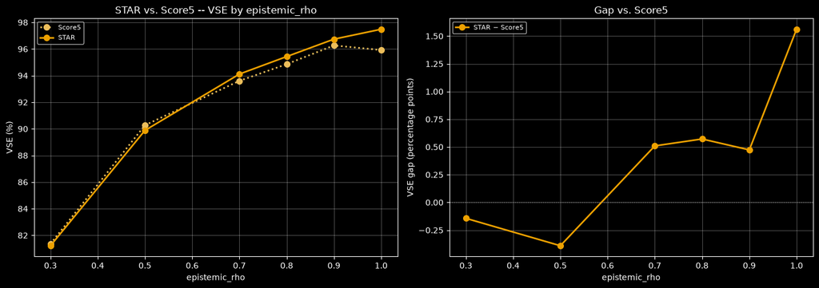

STAR vs. Score5 by `awareness_alpha`

| Method | awareness_alpha=0.30 | awareness_alpha=0.50 | awareness_alpha=0.70 | awareness_alpha=0.80 | awareness_alpha=0.90 | awareness_alpha=1.00 |
| --- | --- | --- | --- | --- | --- | --- |
| Score5 | 1.0% (+/-6.5) | 17.2% (+/-5.8) | 55.3% (+/-3.2) | 67.9% (+/-2.6) | 82.0% (+/-1.6) | 95.9% (+/-0.4) |
| STAR | 1.0% (+/-6.5) | 19.5% (+/-5.7) | 57.5% (+/-3.2) | 70.3% (+/-2.6) | 84.6% (+/-1.6) | 97.5% (+/-0.3) |

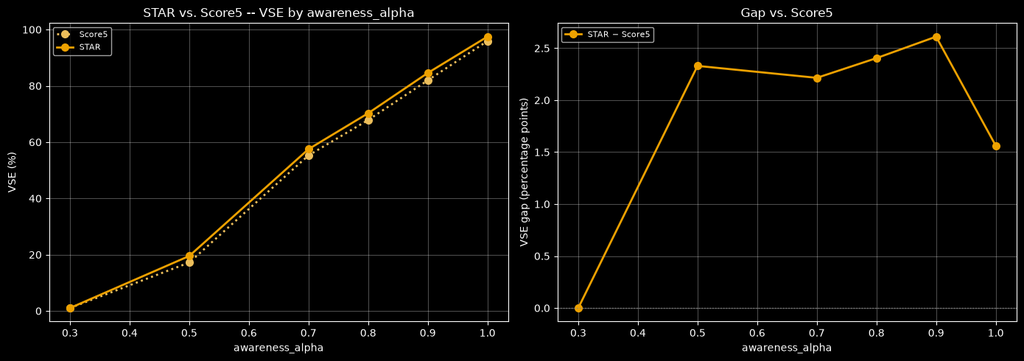

STAR vs. Score5 by `fatigue_beta`

| Method | fatigue_beta=0.30 | fatigue_beta=0.50 | fatigue_beta=0.70 | fatigue_beta=0.80 | fatigue_beta=0.90 | fatigue_beta=1.00 |
| --- | --- | --- | --- | --- | --- | --- |
| Score5 | 66.9% (+/-3.6) | 75.0% (+/-2.9) | 84.7% (+/-2.1) | 90.1% (+/-1.6) | 96.2% (+/-0.7) | 95.9% (+/-0.4) |
| STAR | 67.8% (+/-3.5) | 74.6% (+/-2.9) | 85.6% (+/-2.0) | 90.8% (+/-1.5) | 96.6% (+/-0.7) | 97.5% (+/-0.3) |

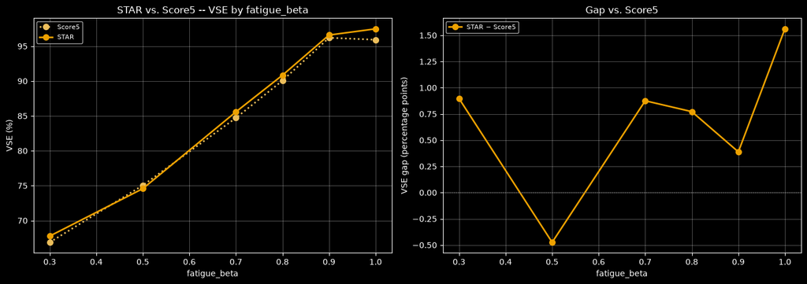

```python
STAR_SCORE_LABELS = ["Score5", "STAR"]

for _param in ["epistemic_rho", "awareness_alpha", "fatigue_beta"]:
    display(Markdown(f"#### STAR vs. Score5 by `{_param}`"))
    comparison_table(compare_by_param[_param], STAR_SCORE_LABELS, _param)
    comparison_chart(compare_by_param[_param], STAR_SCORE_LABELS, _param, baseline_label="Score5",
                      title=f"STAR vs. Score5 -- VSE by {_param}")
```

| Method | Ideal | Mild friction | Moderate friction | Heavy friction |
| --- | --- | --- | --- | --- |
| Score5 | 95.9% (+/-0.4) | 82.0% (+/-0.7) | 65.0% (+/-1.2) | 42.9% (+/-1.7) |
| STAR | 97.5% (+/-0.3) | 83.3% (+/-0.7) | 65.9% (+/-1.2) | 43.4% (+/-1.7) |

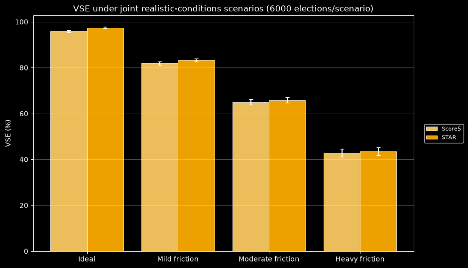

Score5 vs STAR: paired VSE gap by joint-friction scenario

| Scenario | Score VSE (%) | STAR VSE (%) | Gap vs STAR (pp) | 95% CI (paired, pp) | Significant? |
| --- | --- | --- | --- | --- | --- |
| Ideal | 95.9 | 97.5 | -1.6 | [-1.9, -1.2] | Decisive (STAR better) |
| Mild friction | 82.0 | 83.3 | -1.3 | [-1.7, -0.9] | Ambiguous edge (STAR better) |
| Moderate friction | 65.0 | 65.9 | -0.9 | [-1.3, -0.4] | Ambiguous edge (STAR better) |
| Heavy friction | 42.9 | 43.4 | -0.6 | [-1.0, -0.1] | Narrow edge (STAR better) |

```python
# Score5 and STAR
score5_star_labels = ["Score5", "STAR"]
scenario_table_and_plot(score5_star_labels)
display_paired_gap_table("Score5", "STAR", label_short="Score", baseline_short="STAR")
```

```python
_collapse_rows = []
for sweep_param, param_title in [
    ("epistemic_rho", "Epistemic noise"),
    ("awareness_alpha", "Unfamiliarity"),
    ("fatigue_beta", "Ballot fatigue"),
]:
    results_by_value = compare_by_param[sweep_param]
    _values = sorted(results_by_value)
    _ideal_v, _heavy_v = max(_values), 0.7
    _ideal, _heavy = results_by_value[_ideal_v], results_by_value[_heavy_v]
    star_drop = (_ideal[("STAR", "honBallot")][0] - _heavy[("STAR", "honBallot")][0]) * 100
    score5_drop = (_ideal[("Score5", "honBallot")][0] - _heavy[("Score5", "honBallot")][0]) * 100
    _collapse_rows.append((sweep_param, param_title, star_drop, score5_drop, (star_drop + score5_drop) / 2))

_collapse_rows.sort(key=lambda r: -r[4])
_lines = [
    "#### Which friction parameter drives the shared STAR/Score5 collapse most?",
    "",
    "| Rank | Parameter | STAR VSE drop, ideal to heaviest tested friction (pp) | Score5 VSE drop (pp) | Avg drop (pp) |",
    "|---|---|---|---|---|",
]
for i, (param, title, star_drop, score5_drop, avg) in enumerate(_collapse_rows, start=1):
    _lines.append(f"| {i} | {title} (`{param}`) | {star_drop:+.1f} | {score5_drop:+.1f} | {avg:+.1f} |")
display(Markdown("\n".join(_lines)))
```

Which friction parameter drives the shared STAR/Score5 collapse most?

| Rank | Parameter | STAR VSE drop, ideal to heaviest tested friction (pp) | Score5 VSE drop (pp) | Avg drop (pp) |
| --- | --- | --- | --- | --- |
| 1 | Unfamiliarity (`awareness_alpha`) | +40.0 | +40.6 | +40.3 |
| 2 | Ballot fatigue (`fatigue_beta`) | +11.9 | +11.2 | +11.6 |
| 3 | Epistemic noise (`epistemic_rho`) | +3.4 | +2.3 | +2.8 |

## 23. Per-election "runoff betrayal" diagnostic

### Does the runoff help or hurt, relative to no runoff at all?

Before digging into STAR's own automatic-runoff betrayal rate below, a more basic question: for Approval Top-2 and Plurality Top-2, does adding a delayed runoff on top of the base (non-runoff) method actually help, across each of the three runoff-information assumptions? Reads directly off the main joint-scenario run (Section 16) -- `Approval Top-2 (Coma/Groggy/Clear-Eyed)` and `Plurality Top-2 (Groggy/Clear-Eyed)` are each paired against their own family's base method (`Approval`/`Plurality`), same paired-CI/significance convention as every other gap table in this notebook.

```python
def display_paired_gap_matrix(labels, baseline_label, title=None, sort_desc=True):
    """Same layout as Section 19's CE-gap-vs-Schulze tables: one table per _scenario_names
    scenario, every label in `labels` as a row (sorted by gap) vs the SAME baseline_label. Reads
    joint_results/paired_diff_by_scenario (already computed by the main joint-scenario run) -- no
    new simulation. Every (label, baseline_label) pair must already be in _paired_diff_pairs
    (cell defining it, Section 16) with the main run re-executed since."""
    title = title or f"{baseline_label} vs {', '.join(labels)}"
    missing = [
        (name, label) for name in _scenario_names for label in labels
        if (label, baseline_label) not in paired_diff_by_scenario.get(name, {})
    ]
    if missing:
        raise KeyError(
            f"missing pairs in paired_diff_by_scenario: {missing} -- add (label, {baseline_label!r}) "
            "to _paired_diff_pairs and re-run the main joint-scenario cell first."
        )
    lines = [f"### {title}", ""]
    for name in _scenario_names:
        baseline_vse = joint_results[name][(baseline_label, "honBallot")][0] * 100
        sorted_labels = sorted(
            labels, reverse=sort_desc,
            key=lambda l: paired_diff_by_scenario[name][(l, baseline_label)][0],
        )
        lines += [
            f"#### {name}", "",
            f"| Method | {baseline_label} VSE (%) | Method VSE (%) | Gap (pp) | 95% CI | Significant? |",
            "|---|---|---|---|---|---|",
        ]
        for label in sorted_labels:
            if name == "Ideal" and ('Coma' in label or 'Clear-Eyed' in label):
                continue
            label_vse = joint_results[name][(label, "honBallot")][0] * 100
            gap, ci = paired_diff_by_scenario[name][(label, baseline_label)]
            gap *= 100
            ci *= 100
            _register_significance(f"{title}: {name}", label, gap, ci, "runoff", "no runoff")
            _, sig = _verdict_text(gap, ci, "runoff", "no runoff")
            lines.append(f"| {label} | {baseline_vse:.1f} | {label_vse:.1f} | {gap:+.1f} | [{gap-ci:+.1f}, {gap+ci:+.1f}] | {sig} |")
        lines.append("")
    display(Markdown("\n".join(lines)))
```

```python
display_paired_gap_matrix(
    ["Approval Top-2 (Coma)", "Approval Top-2", "Approval Top-2 (Clear-Eyed)"], "Approval",
    title="Does the runoff help or hurt Approval?",
)
display_paired_gap_matrix(
    ["Plurality Top-2", "Plurality Top-2 (Clear-Eyed)"], "Plurality",
    title="Does the runoff help or hurt Plurality?",
)
```

Does the runoff help or hurt Approval?

Ideal

| Method | Approval VSE (%) | Method VSE (%) | Gap (pp) | 95% CI | Significant? |
| --- | --- | --- | --- | --- | --- |
| Approval Top-2 | 89.2 | 95.6 | +6.4 | [+5.7, +7.2] | Decisive (runoff better) |

Mild friction

| Method | Approval VSE (%) | Method VSE (%) | Gap (pp) | 95% CI | Significant? |
| --- | --- | --- | --- | --- | --- |
| Approval Top-2 (Clear-Eyed) | 82.5 | 92.6 | +10.1 | [+9.4, +10.7] | Decisive (runoff better) |
| Approval Top-2 | 82.5 | 91.9 | +9.4 | [+8.8, +10.0] | Decisive (runoff better) |
| Approval Top-2 (Coma) | 82.5 | 81.3 | -1.2 | [-1.8, -0.7] | Ambiguous edge (no runoff better) |

Moderate friction

| Method | Approval VSE (%) | Method VSE (%) | Gap (pp) | 95% CI | Significant? |
| --- | --- | --- | --- | --- | --- |
| Approval Top-2 (Clear-Eyed) | 65.9 | 83.5 | +17.5 | [+16.6, +18.5] | Decisive (runoff better) |
| Approval Top-2 | 65.9 | 82.2 | +16.3 | [+15.3, +17.2] | Decisive (runoff better) |
| Approval Top-2 (Coma) | 65.9 | 57.0 | -8.9 | [-9.9, -8.0] | Decisive (no runoff better) |

Heavy friction

| Method | Approval VSE (%) | Method VSE (%) | Gap (pp) | 95% CI | Significant? |
| --- | --- | --- | --- | --- | --- |
| Approval Top-2 (Clear-Eyed) | 43.2 | 75.2 | +32.1 | [+30.6, +33.6] | Decisive (runoff better) |
| Approval Top-2 | 43.2 | 72.8 | +29.7 | [+28.2, +31.2] | Decisive (runoff better) |
| Approval Top-2 (Coma) | 43.2 | 31.6 | -11.5 | [-12.8, -10.2] | Decisive (no runoff better) |

Does the runoff help or hurt Plurality?

Ideal

| Method | Plurality VSE (%) | Method VSE (%) | Gap (pp) | 95% CI | Significant? |
| --- | --- | --- | --- | --- | --- |
| Plurality Top-2 | 61.6 | 83.6 | +22.0 | [+19.7, +24.3] | Decisive (runoff better) |

Mild friction

| Method | Plurality VSE (%) | Method VSE (%) | Gap (pp) | 95% CI | Significant? |
| --- | --- | --- | --- | --- | --- |
| Plurality Top-2 (Clear-Eyed) | 68.9 | 89.1 | +20.2 | [+18.8, +21.6] | Decisive (runoff better) |
| Plurality Top-2 | 68.9 | 88.4 | +19.5 | [+18.1, +20.9] | Decisive (runoff better) |

Moderate friction

| Method | Plurality VSE (%) | Method VSE (%) | Gap (pp) | 95% CI | Significant? |
| --- | --- | --- | --- | --- | --- |
| Plurality Top-2 (Clear-Eyed) | 61.0 | 82.7 | +21.6 | [+20.4, +22.9] | Decisive (runoff better) |
| Plurality Top-2 | 61.0 | 81.7 | +20.7 | [+19.5, +22.0] | Decisive (runoff better) |

Heavy friction

| Method | Plurality VSE (%) | Method VSE (%) | Gap (pp) | 95% CI | Significant? |
| --- | --- | --- | --- | --- | --- |
| Plurality Top-2 (Clear-Eyed) | 41.2 | 74.5 | +33.2 | [+31.6, +34.8] | Decisive (runoff better) |
| Plurality Top-2 | 41.2 | 72.3 | +31.1 | [+29.5, +32.7] | Decisive (runoff better) |

### Sanity check, then: why does Coma underperform?

The table above shows Coma AT2 scoring *below* plain Approval -- before trusting an explanation for that, a sanity check: Coma, Groggy (the default `Approval Top-2`), and Clear-Eyed all collapse to the exact same code path at zero friction (`epistemic_rho=awareness_alpha=fatigue_beta=1.0` -- `_perceived_voters` equals true utilities and `aware_sets` covers everyone regardless of which runoff mode is active). Their VSE at Ideal must therefore be bit-for-bit identical; a mismatch would mean a real implementation bug, not a friction effect.

```python
_coma_ideal = results[("Approval Top-2 (Coma)", "honBallot")]
_groggy_ideal = results[("Approval Top-2", "honBallot")]
_ce_ideal = results[("Approval Top-2 (Clear-Eyed)", "honBallot")]
_sanity_ok = _coma_ideal == _groggy_ideal == _ce_ideal
display(Markdown(
    f"**Sanity check -- Coma/Groggy/Clear-Eyed AT2 at Ideal (should be identical):** "
    f"Coma={_coma_ideal[0]*100:.4f}%, Groggy={_groggy_ideal[0]*100:.4f}%, "
    f"Clear-Eyed={_ce_ideal[0]*100:.4f}% -- "
    + ("**MATCH** (no implementation bug at this boundary)." if _sanity_ok
       else "**MISMATCH -- this is a real bug, investigate before trusting the decomposition below.**")
))
assert _sanity_ok, "Coma/Groggy/Clear-Eyed AT2 must be identical at Ideal (same code path) -- mismatch means a bug, not friction."
```

**Sanity check -- Coma/Groggy/Clear-Eyed AT2 at Ideal (should be identical):** Coma=95.5905%, Groggy=95.5905%, Clear-Eyed=95.5905% -- **MATCH** (no implementation bug at this boundary).

```python
# Reads the Coma-corruption accumulator folded into the main joint-scenario run above (Section
# 16, betrayal_targets/coma_targets on run_vse_simulation) instead of re-simulating its own
# separate AT2_COMA_NITER-election batch per scenario.
at2_coma_stats_by_scenario = {
    name: reduce_coma_summary(joint_coma_by_scenario[name]["Approval Top-2 (Coma)"])
    for name in JOINT_SCENARIOS
}
star_coma_stats_by_scenario = {
    name: reduce_coma_summary(joint_coma_by_scenario[name]["STAR"])
    for name in JOINT_SCENARIOS
}
at2_primary_cost_stats_by_scenario = {
    name: reduce_primary_cost_summary(joint_primary_cost_by_scenario[name]["Approval Top-2"])
    for name in JOINT_SCENARIOS
}
```

```python
_coma_lines = [
    "#### Coma AT2: why voters end up voting against their own pairwise interest",
    "",
    "| Scenario | Aligned | Awareness-attributable | Noise-unfixable (even if Groggy) |",
    "|---|---|---|---|",
]
for name, stats in at2_coma_stats_by_scenario.items():
    _coma_lines.append(
        f"| {name} | {stats['aligned'] * 100:.1f}% | {stats['awareness_attributable'] * 100:.1f}% | "
        f"{stats['noise_unfixable'] * 100:.1f}% |"
    )
display(Markdown("\n".join(_coma_lines)))

_coma_detail_lines = [
    "#### Coma AT2: detailed breakdown",
    "",
    "| Scenario | Wrong (awareness-fixable) | Wrong (noise-unfixable) | Abstained (awareness-fixable) | Abstained (noise-unfixable) |",
    "|---|---|---|---|---|",
]
for name, stats in at2_coma_stats_by_scenario.items():
    _coma_detail_lines.append(
        f"| {name} | {stats['wrong_awareness_fixable'] * 100:.1f}% | {stats['wrong_noise_unfixable'] * 100:.1f}% | "
        f"{stats['abstained_awareness_fixable'] * 100:.1f}% | {stats['abstained_noise_unfixable'] * 100:.1f}% |"
    )
display(Markdown("\n".join(_coma_detail_lines)))
```

Coma AT2: why voters end up voting against their own pairwise interest

| Scenario | Aligned | Awareness-attributable | Noise-unfixable (even if Groggy) |
| --- | --- | --- | --- |
| Ideal | 100.0% | 0.0% | 0.0% |
| Mild friction | 71.5% | 11.0% | 17.5% |
| Moderate friction | 66.3% | 14.4% | 19.3% |
| Heavy friction | 63.2% | 15.9% | 20.8% |

Coma AT2: detailed breakdown

| Scenario | Wrong (awareness-fixable) | Wrong (noise-unfixable) | Abstained (awareness-fixable) | Abstained (noise-unfixable) |
| --- | --- | --- | --- | --- |
| Ideal | 0.0% | 0.0% | 0.0% | 0.0% |
| Mild friction | 9.9% | 17.2% | 1.1% | 0.3% |
| Moderate friction | 13.0% | 18.8% | 1.4% | 0.5% |
| Heavy friction | 15.2% | 20.5% | 0.7% | 0.3% |

```python
_election_lines = [
    "#### Coma vs Groggy: election-level aggregate-sign accuracy (does the runoff decision match the true preference?)",
    "",
    "| Scenario | Coma correct | Groggy correct | Both correct | Coma-only correct | Groggy-only correct | Both wrong |",
    "|---|---|---|---|---|---|---|",
]
for name, stats in at2_coma_stats_by_scenario.items():
    _election_lines.append(
        f"| {name} | {stats['coma_accuracy_rate'] * 100:.1f}% | {stats['groggy_accuracy_rate'] * 100:.1f}% | "
        f"{stats['both_correct_rate'] * 100:.1f}% | {stats['coma_only_correct_rate'] * 100:.1f}% | "
        f"{stats['groggy_only_correct_rate'] * 100:.1f}% | {stats['both_wrong_rate'] * 100:.1f}% |"
    )
display(Markdown("\n".join(_election_lines)))
display(Markdown(
    "An election's outcome depends on the aggregate runoff decision, not per-voter accuracy. "
    "That is the metric driving the VSE gap. \"Groggy-only correct\" elections are ones where "
    "fixing awareness alone flips the aggregate decision from wrong to right, even though the "
    "per-voter `awareness_attributable` rate above is modest."
))
```

Coma vs Groggy: election-level aggregate-sign accuracy (does the runoff decision match the true preference?)

| Scenario | Coma correct | Groggy correct | Both correct | Coma-only correct | Groggy-only correct | Both wrong |
| --- | --- | --- | --- | --- | --- | --- |
| Ideal | 100.0% | 100.0% | 100.0% | 0.0% | 0.0% | 0.0% |
| Mild friction | 61.3% | 85.0% | 54.0% | 7.3% | 31.0% | 7.7% |
| Moderate friction | 52.2% | 86.8% | 45.2% | 7.0% | 41.6% | 6.2% |
| Heavy friction | 46.7% | 86.2% | 39.5% | 7.2% | 46.7% | 6.6% |

An election's outcome depends on the aggregate runoff decision, not per-voter accuracy. That is the metric driving the VSE gap. "Groggy-only correct" elections are ones where fixing awareness alone flips the aggregate decision from wrong to right, even though the per-voter `awareness_attributable` rate above is modest.

```python
def _at2_runoff_cost_table(stats_by_key, key_header, key_fmt=str):
    """Same partition as _betrayal_breakdown_table above, but for Approval Top-2's own runoff
    variants instead of STAR: "true" (the honest reference) is Approval Top-2 (Clear-Eyed)'s own
    decision -- true_upset's sign already IS that decision, since Clear-Eyed's runoff electorate
    is the true electorate itself (see Top2Base._runoff_electorate). Groggy and Coma each get
    their own bad-flip/silent-lock-in split against that same reference; "Coma vs Groggy" is a
    single net cost, not bucketed -- there is no one "primary's raw leader" once both sides are
    corrupted relative to true, only relative to each other."""
    header = [key_header, "Groggy: bad flip (pp)", "Groggy: silent lock-in (pp)",
              "Coma: bad flip (pp)", "Coma: silent lock-in (pp)", "Coma vs Groggy (pp)"]
    lines = ["| " + " | ".join(header) + " |", "|" + "---|" * len(header)]
    for key, stats in stats_by_key.items():
        lines.append("| " + " | ".join([
            key_fmt(key),
            f"{stats['groggy_bad_flip_vse_cost'] * 100:+.2f}",
            f"{stats['groggy_silent_lockin_vse_cost'] * 100:+.2f}",
            f"{stats['coma_bad_flip_vse_cost'] * 100:+.2f}",
            f"{stats['coma_silent_lockin_vse_cost'] * 100:+.2f}",
            f"{stats['coma_vs_groggy_vse_cost'] * 100:+.2f}",
        ]) + " |")
    display(Markdown("\n".join(lines)))


def _primary_noise_cost_table(stats_by_key, key_header, key_fmt=str):
    """How much Approval Top-2 (Groggy) loses from primary-stage noise alone: compares the real
    (noisy-primary) Groggy winner against a counterfactual Groggy winner between the finalists an
    honest primary would have picked instead, holding the runoff's own information level (Groggy)
    fixed. finalist_set_changed_rate is a companion diagnostic, not part of the cost sum: how
    often primary noise alone swapped who even reached the runoff."""
    header = [key_header, "Primary-noise VSE cost (pp)", "Finalist set changed"]
    lines = ["| " + " | ".join(header) + " |", "|" + "---|" * len(header)]
    for key, stats in stats_by_key.items():
        lines.append("| " + " | ".join([
            key_fmt(key),
            f"{stats['primary_noise_vse_cost'] * 100:+.2f}",
            f"{stats['finalist_set_changed_rate'] * 100:.1f}%",
        ]) + " |")
    display(Markdown("\n".join(lines)))
```

```python
display(Markdown(
    "#### Approval Top-2's own runoff-noise VSE cost: Groggy and Coma vs. Clear-Eyed\n\n"
    "Same fixed two finalists as the accuracy table above. \"True\" is Approval Top-2 "
    "(Clear-Eyed)'s own decision, not a re-simulation -- Clear-Eyed's runoff electorate is the "
    "true electorate itself. Coma vs. Groggy is a single net cost, not bucketed: once both "
    "sides are corrupted relative to true, there is no one primary leader to flip away from or "
    "lock in on."
))
_at2_runoff_cost_table(at2_coma_stats_by_scenario, "Scenario")
```

Approval Top-2's own runoff-noise VSE cost: Groggy and Coma vs. Clear-Eyed

Same fixed two finalists as the accuracy table above. "True" is Approval Top-2 (Clear-Eyed)'s own decision, not a re-simulation -- Clear-Eyed's runoff electorate is the true electorate itself. Coma vs. Groggy is a single net cost, not bucketed: once both sides are corrupted relative to true, there is no one primary leader to flip away from or lock in on.

| Scenario | Groggy: bad flip (pp) | Groggy: silent lock-in (pp) | Coma: bad flip (pp) | Coma: silent lock-in (pp) | Coma vs Groggy (pp) |
| --- | --- | --- | --- | --- | --- |
| Ideal | +0.00 | +0.00 | +0.00 | +0.00 | +0.00 |
| Mild friction | +0.35 | +0.30 | +3.01 | +7.17 | +9.53 |
| Moderate friction | +0.68 | +0.57 | +9.42 | +15.40 | +23.56 |
| Heavy friction | +1.20 | +0.95 | +13.08 | +28.93 | +39.86 |

```python
display(Markdown(
    "#### How much does primary noise alone cost Approval Top-2?\n\n"
    "Holds the runoff information level fixed at Groggy. Compares the real (noisy-primary) "
    "Groggy winner against a counterfactual Groggy winner between the finalists an honest "
    "primary would have picked instead -- isolating the primary tally's own noise from the "
    "runoff's information level."
))
_primary_noise_cost_table(at2_primary_cost_stats_by_scenario, "Scenario")
```

How much does primary noise alone cost Approval Top-2?

Holds the runoff information level fixed at Groggy. Compares the real (noisy-primary) Groggy winner against a counterfactual Groggy winner between the finalists an honest primary would have picked instead -- isolating the primary tally's own noise from the runoff's information level.

| Scenario | Primary-noise VSE cost (pp) | Finalist set changed |
| --- | --- | --- |
| Ideal | +0.00 | 0.0% |
| Mild friction | +1.73 | 63.4% |
| Moderate friction | +9.63 | 81.3% |
| Heavy friction | +17.96 | 87.9% |

```python
# Reads the betrayal/flip accumulator folded into the main joint-scenario run above (Section 16,
# betrayal_targets on run_vse_simulation) instead of re-simulating its own separate
# BETRAYAL_NITER-election batch per scenario -- same JOINT_NITER-election precision as every
# other joint-scenario number in this notebook.
betrayal_by_scenario = {
    name: reduce_betrayal_summary(joint_betrayal_by_scenario[name]["STAR"])
    for name in JOINT_SCENARIOS
}
```

```python
# Reads the betrayal accumulator folded into Section 13's epistemic_rho sweep (see cell 53) --
# reuses SWEEP_VALUES directly (Section 5) rather than its own copy, since that's what
# actually populated epistemic_rho_betrayal_by_value; not re-simulated here.
betrayal_by_epistemic_rho = {
    rho: reduce_betrayal_summary(epistemic_rho_betrayal_by_value[rho]["STAR"])
    for rho in SWEEP_VALUES
}
```

### STAR Betrayal Rate

**This measures something different from Section 22, not the same thing on a different scale.** Section 22 asks whether STAR's runoff changes the winner away from Score5's raw top-score pick at all -- it rarely does, so that aggregate gap is a wash. This section asks a broader question: independent of whether the runoff visibly changes anything, does the pairwise decision it actually makes for this specific pair of finalists agree with what the SAME voters' honest, uncorrupted preferences would have decided? That also catches cases where the runoff keeps Score5's raw pick, but that shared pick is itself wrong relative to honest preferences -- and it turns out to be violated far more often than the runoff visibly flips anything, as the flip-rate section below shows.

`voter_corruption_rate` is the more granular signal: among individual voters with a genuine (nonzero) honest preference between the two finalists, how often does their ACTUAL (noisy/ friction-affected) ballot disagree in sign with it. `betrayal_rate` aggregates this to the level of the runoff DECISION itself: among elections where both the actual and honest signals are decisive, how often does STAR's automatic runoff produce the OPPOSITE outcome from what a perfectly-informed, delayed runoff would have produced for that same pair.

The table reports three VSE numbers on the same 0-100(ish) scale as everywhere else in this notebook: **VSE (STAR's actual runoff)** is STAR's already-known aggregate VSE at that scenario; **VSE (honest/delayed-perfect runoff)** is the counterfactual if this specific runoff pair had always used honest preferences instead; and **VSE (AT2 Clear-Eyed runoff)** is "Approval Top-2 (Clear-Eyed)"'s own aggregate VSE at the same scenario -- a real method combining a coarser Approval primary with a perfect delayed runoff, for direct comparison.

This diagnostic (folded into `run_vse_simulation`'s `betrayal_targets` accumulator -- Section 8) compares the pairwise upset sign from actual (noisy/friction-affected) ballots against the SAME sign computed from HONEST ballots on the TRUE electorate -- both cast the same way (same `honBallot` floor-to-`0..topRank` discretization), rather than against raw continuous utilities, so a small honest margin that floors to a tie doesn't get counted as noise's fault.

```python
def _betrayal_table(stats_by_key, key_header, star_vse_lookup, at2_vse_lookup, key_fmt=str):
    """star_vse_lookup(key) -> STAR's own already-computed honest-ballot VSE (a 0..1 fraction) at
    this scenario/epistemic_rho value, pulled from Sections 13/16 data -- not recomputed here. The
    "honest/delayed-perfect runoff" column is derived as actual + population_vse_cost, so the two
    VSE columns are guaranteed to differ by exactly the "VSE gap" column.

    at2_vse_lookup(key) -> "Approval Top-2 (Clear-Eyed)"'s already-computed honest-ballot
    VSE (a 0..1 fraction) at the SAME scenario/epistemic_rho value, also pulled from Sections 13/16
    data (COMPARE_LABELS/METHODS_NO_COMA already include it -- no new simulation). Placed next
    to STAR's own two VSE columns so a coarse (Approval) vs. fine-grained (0..5 Score) noisy
    primary ballot can be compared directly once BOTH have a perfect delayed runoff available to
    correct their pick -- STAR's "honest/delayed-perfect" column IS exactly that comparison for
    the Score primary, restricted to the decisive runoff pairs."""
    header = [key_header, "Betrayal rate", "Voter corruption rate",
              "VSE (STAR's actual runoff)", "VSE (honest/delayed-perfect runoff)",
              "VSE (AT2 Clear-Eyed runoff)"]
    lines = ["| " + " | ".join(header) + " |", "|" + "---|" * len(header)]
    for key, stats in stats_by_key.items():
        n_dec = stats["n_decisive"]
        actual_vse = star_vse_lookup(key) * 100
        gap = stats["population_vse_cost"] * 100 if n_dec else 0.0
        honest_vse = actual_vse + gap
        at2_vse = at2_vse_lookup(key) * 100
        at2_star_gap = at2_vse - actual_vse
        lines.append("| " + " | ".join([
            key_fmt(key),
            f"{stats['betrayal_rate'] * 100:.1f}%" if n_dec else "n/a",
            f"{stats['voter_corruption_rate'] * 100:.2f}%",
            f"{actual_vse:.1f}%",
            f"{honest_vse:.1f}% ({gap:+.1f} pts over actual)" if n_dec else "n/a",
            #f"{gap:+.1f} pts" if n_dec else "n/a",
            f"{at2_vse:.1f}% ({at2_star_gap:+.1f} pts over STAR)" if n_dec else "n/a",
        ]) + " |")
    display(Markdown("\n".join(lines)))
```

```python
display(Markdown("#### Runoff betrayal rate by joint-friction scenario"))
_betrayal_table(betrayal_by_scenario, "Scenario",
                 star_vse_lookup=lambda name: joint_results[name][("STAR", "honBallot")][0],
                 at2_vse_lookup=lambda name: joint_results[name][("Approval Top-2 (Clear-Eyed)", "honBallot")][0])
```

Runoff betrayal rate by joint-friction scenario

| Scenario | Betrayal rate | Voter corruption rate | VSE (STAR's actual runoff) | VSE (honest/delayed-perfect runoff) | VSE (AT2 Clear-Eyed runoff) |
| --- | --- | --- | --- | --- | --- |
| Ideal | 0.0% | 0.00% | 97.5% | 97.5% (+0.0 pts over actual) | 95.6% (-1.9 pts over STAR) |
| Mild friction | 34.2% | 35.46% | 83.3% | 91.2% (+7.8 pts over actual) | 92.6% (+9.3 pts over STAR) |
| Moderate friction | 37.5% | 45.09% | 65.9% | 81.0% (+15.2 pts over actual) | 83.5% (+17.6 pts over STAR) |
| Heavy friction | 44.8% | 49.09% | 43.4% | 71.4% (+28.0 pts over actual) | 75.2% (+31.8 pts over STAR) |

```python
_star_coma_lines = [
    "#### STAR: why the automatic runoff ends up voting against voters' own pairwise interest",
    "",
    "| Scenario | Aligned | Awareness-attributable | Noise-unfixable (even if fully aware) |",
    "|---|---|---|---|",
]
for name, stats in star_coma_stats_by_scenario.items():
    _star_coma_lines.append(
        f"| {name} | {stats['aligned'] * 100:.1f}% | {stats['awareness_attributable'] * 100:.1f}% | "
        f"{stats['noise_unfixable'] * 100:.1f}% |"
    )
display(Markdown("\n".join(_star_coma_lines)))

_star_coma_detail_lines = [
    "#### STAR: detailed breakdown",
    "",
    "| Scenario | Wrong (awareness-fixable) | Wrong (noise-unfixable) | Abstained (awareness-fixable) | Abstained (noise-unfixable) |",
    "|---|---|---|---|---|",
]
for name, stats in star_coma_stats_by_scenario.items():
    _star_coma_detail_lines.append(
        f"| {name} | {stats['wrong_awareness_fixable'] * 100:.1f}% | {stats['wrong_noise_unfixable'] * 100:.1f}% | "
        f"{stats['abstained_awareness_fixable'] * 100:.1f}% | {stats['abstained_noise_unfixable'] * 100:.1f}% |"
    )
display(Markdown("\n".join(_star_coma_detail_lines)))

_star_vs_aware_lines = [
    "#### STAR's actual automatic runoff vs a fully-aware counterfactual: election-level aggregate-sign accuracy",
    "",
    "| Scenario | STAR (actual) correct | Fully-aware counterfactual correct | Both correct | STAR-only correct | Counterfactual-only correct | Both wrong |",
    "|---|---|---|---|---|---|---|",
]
for name, stats in star_coma_stats_by_scenario.items():
    _star_vs_aware_lines.append(
        f"| {name} | {stats['coma_accuracy_rate'] * 100:.1f}% | {stats['groggy_accuracy_rate'] * 100:.1f}% | "
        f"{stats['both_correct_rate'] * 100:.1f}% | {stats['coma_only_correct_rate'] * 100:.1f}% | "
        f"{stats['groggy_only_correct_rate'] * 100:.1f}% | {stats['both_wrong_rate'] * 100:.1f}% |"
    )
display(Markdown("\n".join(_star_vs_aware_lines)))
display(Markdown(
    "An election's outcome depends on the aggregate runoff decision, not per-voter accuracy. "
    "\"Counterfactual-only correct\" elections are ones where removing unawareness and fatigue "
    "alone, holding epistemic noise fixed, flips the automatic runoff's aggregate decision from "
    "wrong to right, even though the per-voter `awareness_attributable` rate above is modest."
))
```

STAR: why the automatic runoff ends up voting against voters' own pairwise interest

| Scenario | Aligned | Awareness-attributable | Noise-unfixable (even if fully aware) |
| --- | --- | --- | --- |
| Ideal | 100.0% | 0.0% | 0.0% |
| Mild friction | 72.3% | 10.7% | 17.1% |
| Moderate friction | 66.6% | 14.3% | 19.1% |
| Heavy friction | 63.4% | 15.8% | 20.8% |

STAR: detailed breakdown

| Scenario | Wrong (awareness-fixable) | Wrong (noise-unfixable) | Abstained (awareness-fixable) | Abstained (noise-unfixable) |
| --- | --- | --- | --- | --- |
| Ideal | 0.0% | 0.0% | 0.0% | 0.0% |
| Mild friction | 9.7% | 16.8% | 1.0% | 0.2% |
| Moderate friction | 13.0% | 18.7% | 1.3% | 0.4% |
| Heavy friction | 15.1% | 20.5% | 0.7% | 0.3% |

STAR's actual automatic runoff vs a fully-aware counterfactual: election-level aggregate-sign accuracy

| Scenario | STAR (actual) correct | Fully-aware counterfactual correct | Both correct | STAR-only correct | Counterfactual-only correct | Both wrong |
| --- | --- | --- | --- | --- | --- | --- |
| Ideal | 100.0% | 100.0% | 100.0% | 0.0% | 0.0% | 0.0% |
| Mild friction | 62.1% | 85.8% | 55.0% | 7.1% | 30.8% | 7.1% |
| Moderate friction | 52.5% | 86.9% | 45.5% | 6.9% | 41.4% | 6.1% |
| Heavy friction | 47.2% | 86.2% | 39.9% | 7.2% | 46.3% | 6.5% |

An election's outcome depends on the aggregate runoff decision, not per-voter accuracy. "Counterfactual-only correct" elections are ones where removing unawareness and fatigue alone, holding epistemic noise fixed, flips the automatic runoff's aggregate decision from wrong to right, even though the per-voter `awareness_attributable` rate above is modest.

### Paired VSE gap: Score Top-2 (Clear-Eyed) vs Approval Top-2 (Clear-Eyed)

"Score Top-2 (Clear-Eyed)" (Section 6) is now a real registered method -- a Score(STAR_TOP_RANK) primary with an idealized/delayed clear-eyed runoff, the Top2Base analogue of "Approval Top-2 (Clear-Eyed)" but with STAR's finer 0..5 ballot instead of Approval's 0/1 ballot. It rides the same `_joint_electorate_pool` simulation pass as every other `COMPARE_LABELS` method (Section 16), so this reads directly off `paired_diff_by_scenario` -- no separate re-simulation, unlike the old bespoke "theoretical SCORE Top-2" computation this replaces. Directly answers whether a coarse (Approval) ballot is actually more effective than a fine-grained (0..5 Score) ballot once both get an idealized/delayed runoff to correct their pick.

```python
display_paired_gap_table("Score Top-2 (Clear-Eyed)", "Approval Top-2 (Clear-Eyed)", label_short="Score Top-2", baseline_short="AT2", spotlight=True)
```

Score Top-2 (Clear-Eyed) vs Approval Top-2 (Clear-Eyed): paired VSE gap by joint-friction scenario

| Scenario | Score Top-2 VSE (%) | AT2 VSE (%) | Gap vs AT2 (pp) | 95% CI (paired, pp) | Significant? |
| --- | --- | --- | --- | --- | --- |
| Ideal | 98.0 | 95.6 | +2.4 | [+2.0, +2.9] | Decisive (Score Top-2 better) |
| Mild friction | 92.6 | 92.6 | +0.0 | [-0.2, +0.3] | Indistinguishable |
| Moderate friction | 83.5 | 83.5 | +0.1 | [-0.3, +0.4] | Indistinguishable |
| Heavy friction | 75.2 | 75.2 | -0.1 | [-0.4, +0.2] | Indistinguishable |

```python
display_paired_gap_table("Score Top-2 (Clear-Eyed)", "STAR", label_short="Score Top-2", baseline_short="STAR")
```

Score Top-2 (Clear-Eyed) vs STAR: paired VSE gap by joint-friction scenario

| Scenario | Score Top-2 VSE (%) | STAR VSE (%) | Gap vs STAR (pp) | 95% CI (paired, pp) | Significant? |
| --- | --- | --- | --- | --- | --- |
| Ideal | 98.0 | 97.5 | +0.5 | [+0.3, +0.7] | Narrow edge (Score Top-2 better) |
| Mild friction | 92.6 | 83.3 | +9.3 | [+8.7, +9.9] | Decisive (Score Top-2 better) |
| Moderate friction | 83.5 | 65.9 | +17.7 | [+16.7, +18.6] | Decisive (Score Top-2 better) |
| Heavy friction | 75.2 | 43.4 | +31.7 | [+30.3, +33.2] | Decisive (Score Top-2 better) |

```python
def display_paired_gap_by_sweep_value(label, baseline_label, sweep_param, results_by_value, paired_diff_by_value,
                                       label_short=None, baseline_short=None, title=None):
    """Same table shape as display_paired_gap_table (Section 18), but keyed by a swept parameter
    value instead of a joint-friction scenario name -- reads sweep_results_by_param/
    sweep_paired_diff_by_param (Section 13) rather than joint_results/paired_diff_by_scenario."""
    label_short = label_short or label
    baseline_short = baseline_short or baseline_label
    title = title or f"{label} vs {baseline_label}"
    values = sorted(results_by_value)
    lines = [
        f"#### {title}: paired VSE gap by `{sweep_param}`",
        "",
        f"| {sweep_param} | {label_short} VSE (%) | {baseline_short} VSE (%) | Gap vs {baseline_short} (pp) | 95% CI (paired, pp) | Significant? |",
        "|---|---|---|---|---|---|",
    ]
    for v in values:
        label_vse = results_by_value[v][(label, "honBallot")][0] * 100
        baseline_vse = results_by_value[v][(baseline_label, "honBallot")][0] * 100
        gap = label_vse - baseline_vse
        ci = paired_diff_by_value[v][(label, baseline_label)][1] * 100
        _register_significance(title, f"{sweep_param}={v:.2f}", gap, ci, label_short, baseline_short)
        _, sig = _verdict_text(gap, ci, label_short, baseline_short)
        lines.append(f"| {v:.2f} | {label_vse:.1f} | {baseline_vse:.1f} | {gap:+.1f} | [{gap-ci:+.1f}, {gap+ci:+.1f}] | {sig} |")
    display(Markdown("\n".join(lines)))
```

```python
for sweep_param, param_title in [
    ("epistemic_rho", "Epistemic noise"),
    ("awareness_alpha", "Unfamiliarity"),
    ("fatigue_beta", "Ballot fatigue"),
]:
    display_paired_gap_by_sweep_value(
        "Score Top-2 (Clear-Eyed)", "STAR", sweep_param,
        sweep_results_by_param[sweep_param], sweep_paired_diff_by_param[sweep_param],
        label_short="Score Top-2", baseline_short="STAR",
        title=f"Score Top-2 (Clear-Eyed) vs STAR ({param_title})",
    )
```

Score Top-2 (Clear-Eyed) vs STAR (Epistemic noise): paired VSE gap by `epistemic_rho`

| epistemic_rho | Score Top-2 VSE (%) | STAR VSE (%) | Gap vs STAR (pp) | 95% CI (paired, pp) | Significant? |
| --- | --- | --- | --- | --- | --- |
| 0.30 | 92.7 | 81.2 | +11.5 | [+10.0, +13.1] | Decisive (Score Top-2 better) |
| 0.50 | 95.9 | 89.9 | +6.0 | [+4.9, +7.0] | Decisive (Score Top-2 better) |
| 0.70 | 97.4 | 94.1 | +3.2 | [+2.5, +4.0] | Decisive (Score Top-2 better) |
| 0.80 | 97.6 | 95.4 | +2.1 | [+1.5, +2.8] | Decisive (Score Top-2 better) |
| 0.90 | 97.8 | 96.7 | +1.1 | [+0.6, +1.6] | Ambiguous edge (Score Top-2 better) |
| 1.00 | 98.0 | 97.5 | +0.5 | [+0.3, +0.7] | Narrow edge (Score Top-2 better) |

Score Top-2 (Clear-Eyed) vs STAR (Unfamiliarity): paired VSE gap by `awareness_alpha`

| awareness_alpha | Score Top-2 VSE (%) | STAR VSE (%) | Gap vs STAR (pp) | 95% CI (paired, pp) | Significant? |
| --- | --- | --- | --- | --- | --- |
| 0.30 | 66.6 | 1.0 | +65.6 | [+59.5, +71.6] | Decisive (Score Top-2 better) |
| 0.50 | 69.8 | 19.5 | +50.3 | [+45.2, +55.4] | Decisive (Score Top-2 better) |
| 0.70 | 78.1 | 57.5 | +20.6 | [+17.9, +23.3] | Decisive (Score Top-2 better) |
| 0.80 | 85.1 | 70.3 | +14.8 | [+12.8, +16.9] | Decisive (Score Top-2 better) |
| 0.90 | 93.1 | 84.6 | +8.5 | [+7.1, +9.9] | Decisive (Score Top-2 better) |
| 1.00 | 98.0 | 97.5 | +0.5 | [+0.3, +0.7] | Narrow edge (Score Top-2 better) |

Score Top-2 (Clear-Eyed) vs STAR (Ballot fatigue): paired VSE gap by `fatigue_beta`

| fatigue_beta | Score Top-2 VSE (%) | STAR VSE (%) | Gap vs STAR (pp) | 95% CI (paired, pp) | Significant? |
| --- | --- | --- | --- | --- | --- |
| 0.30 | 87.9 | 67.8 | +20.2 | [+17.3, +23.1] | Decisive (Score Top-2 better) |
| 0.50 | 92.0 | 74.6 | +17.5 | [+14.9, +20.0] | Decisive (Score Top-2 better) |
| 0.70 | 94.4 | 85.6 | +8.8 | [+7.2, +10.4] | Decisive (Score Top-2 better) |
| 0.80 | 96.5 | 90.8 | +5.7 | [+4.5, +6.9] | Decisive (Score Top-2 better) |
| 0.90 | 98.2 | 96.6 | +1.6 | [+1.0, +2.1] | Decisive (Score Top-2 better) |
| 1.00 | 98.0 | 97.5 | +0.5 | [+0.3, +0.7] | Narrow edge (Score Top-2 better) |

```python
_gap_rows = []
for sweep_param, param_title in [
    ("epistemic_rho", "Epistemic noise"),
    ("awareness_alpha", "Unfamiliarity"),
    ("fatigue_beta", "Ballot fatigue"),
]:
    _by_value = sweep_results_by_param[sweep_param]
    star_heavy = _by_value[0.7][("STAR", "honBallot")][0] * 100
    ce_heavy = _by_value[0.7][("Score Top-2 (Clear-Eyed)", "honBallot")][0] * 100
    _gap_rows.append((sweep_param, param_title, ce_heavy - star_heavy))

_gap_rows.sort(key=lambda r: -abs(r[2]))
_lines = [
    "#### Which parameter drives the STAR vs. Score Top-2 (Clear-Eyed) gap most?",
    "",
    "| Rank | Parameter | Gap at heaviest tested friction (Score Top-2 CE minus STAR, pp) |",
    "|---|---|---|",
]
for i, (param, title, gap) in enumerate(_gap_rows, start=1):
    _lines.append(f"| {i} | {title} (`{param}`) | {gap:+.1f} |")
display(Markdown("\n".join(_lines)))
```

Which parameter drives the STAR vs. Score Top-2 (Clear-Eyed) gap most?

| Rank | Parameter | Gap at heaviest tested friction (Score Top-2 CE minus STAR, pp) |
| --- | --- | --- |
| 1 | Unfamiliarity (`awareness_alpha`) | +20.6 |
| 2 | Ballot fatigue (`fatigue_beta`) | +8.8 |
| 3 | Epistemic noise (`epistemic_rho`) | +3.2 |

```python
display(Markdown("#### Runoff betrayal rate by `epistemic_rho` alone (`awareness_alpha=fatigue_beta=1.0`)"))
_betrayal_table(betrayal_by_epistemic_rho, "epistemic_rho",
                 star_vse_lookup=lambda rho: sweep_results_by_param["epistemic_rho"][rho][("STAR", "honBallot")][0],
                 at2_vse_lookup=lambda rho: sweep_results_by_param["epistemic_rho"][rho][("Approval Top-2 (Clear-Eyed)", "honBallot")][0],
                 key_fmt=lambda rho: f"{rho:.2f}")
```

Runoff betrayal rate by `epistemic_rho` alone (`awareness_alpha=fatigue_beta=1.0`)

| epistemic_rho | Betrayal rate | Voter corruption rate | VSE (STAR's actual runoff) | VSE (honest/delayed-perfect runoff) | VSE (AT2 Clear-Eyed runoff) |
| --- | --- | --- | --- | --- | --- |
| 0.30 | 40.6% | 49.15% | 81.2% | 91.8% (+10.6 pts over actual) | 91.7% (+10.5 pts over STAR) |
| 0.50 | 34.9% | 43.96% | 89.9% | 94.9% (+5.0 pts over actual) | 95.6% (+5.7 pts over STAR) |
| 0.70 | 28.3% | 37.27% | 94.1% | 96.6% (+2.5 pts over actual) | 97.2% (+3.1 pts over STAR) |
| 0.80 | 25.1% | 33.50% | 95.4% | 96.7% (+1.3 pts over actual) | 97.3% (+1.8 pts over STAR) |
| 0.90 | 18.2% | 26.63% | 96.7% | 97.2% (+0.4 pts over actual) | 97.2% (+0.5 pts over STAR) |
| 1.00 | 0.0% | 0.00% | 97.5% | 97.5% (+0.0 pts over actual) | 95.6% (-1.9 pts over STAR) |

### Why does a near-zero aggregate gap coexist with a much higher betrayal rate? The flip rate.

```python
# Flip stats are bucketed from the exact same noisy/honest upset signs the betrayal diagnostic
# above already computed, in the same run_vse_simulation pass -- reduce_betrayal_summary returns
# both sets of fields together, so this is literally the same reduced dict, not a new computation.
flip_by_scenario = betrayal_by_scenario
```

```python
_flip_lines = ["#### Runoff flip rate by joint-friction scenario",
               "",
                "| Scenario | Flip rate (of all elections) | Good flips | Bad flips (betrayals) | Honest-tied |",
               "|---|---|---|---|---|"]
for name, stats in flip_by_scenario.items():
    _flip_lines.append(
        f"| {name} | {stats['flip_rate'] * 100:.1f}% ({stats['n_flips']}/{stats['n_elections']}) | "
        f"{stats['good_flip_rate'] * 100:.1f}% | "
        f"{stats['bad_flip_rate'] * 100:.1f}% | "
        f"{stats['n_honest_tied_flips']} |"
    )
display(Markdown("\n".join(_flip_lines)))
```

Runoff flip rate by joint-friction scenario

| Scenario | Flip rate (of all elections) | Good flips | Bad flips (betrayals) | Honest-tied |
| --- | --- | --- | --- | --- |
| Ideal | 11.2% (225/2000) | 100.0% | 0.0% | 0 |
| Mild friction | 8.7% (521/6000) | 69.1% | 29.8% | 6 |
| Moderate friction | 4.2% (251/6000) | 62.5% | 37.1% | 1 |
| Heavy friction | 1.0% (62/6000) | 67.7% | 32.3% | 0 |

```python
def _betrayal_breakdown_table(stats_by_key, key_header, key_fmt=str):
    """Exhaustive partition of every election into: aligned (no flip, honestly correct), bad flip
    (flip, honestly wrong), silent lock-in (no flip, honestly WRONG -- "garbage in, garbage out"),
    good flip (flip, honestly correct), and other (a small residual: exact noisy ties, plus
    elections with no clear honest preference between the two finalists). The five share columns
    sum to 100% per row. The two cost columns sum to the same population_vse_cost already shown
    in the betrayal table earlier in this section."""
    header = [key_header, "Aligned", "Bad flip (betrayal)", "Silent lock-in (betrayal)",
              "Good flip", "Other", "VSE cost: bad flips (pp)", "VSE cost: silent lock-in (pp)"]
    lines = ["| " + " | ".join(header) + " |", "|" + "---|" * len(header)]
    for key, stats in stats_by_key.items():
        lines.append("| " + " | ".join([
            key_fmt(key),
            f"{stats['aligned_share'] * 100:.1f}%",
            f"{stats['bad_flip_share'] * 100:.1f}%",
            f"{stats['silent_lockin_share'] * 100:.1f}%",
            f"{stats['good_flip_share'] * 100:.1f}%",
            f"{stats['other_share'] * 100:.1f}%",
            f"{stats['bad_flip_vse_cost'] * 100:+.2f}",
            f"{stats['silent_lockin_vse_cost'] * 100:+.2f}",
        ]) + " |")
    display(Markdown("\n".join(lines)))
```

```python
display(Markdown(
    "#### Garbage in, garbage out? Splitting betrayals into active bad flips vs. silent lock-in\n\n"
    "\"Bad flip\" is the runoff actively overturning the noisy primary's leader in the wrong "
    "direction. \"Silent lock-in\" is the runoff doing nothing: the noisy primary's leader is "
    "confirmed by default, but that leader was already the honestly-wrong choice. The automatic "
    "runoff has no independent source of information, so a primary corrupted by "
    "epistemic_rho/awareness_alpha/fatigue_beta gets rubber-stamped rather than corrected. The "
    "runoff itself rarely breaks something that wasn't already broken."
))
_betrayal_breakdown_table(betrayal_by_scenario, "Scenario")
```

Garbage in, garbage out? Splitting betrayals into active bad flips vs. silent lock-in

"Bad flip" is the runoff actively overturning the noisy primary's leader in the wrong direction. "Silent lock-in" is the runoff doing nothing: the noisy primary's leader is confirmed by default, but that leader was already the honestly-wrong choice. The automatic runoff has no independent source of information, so a primary corrupted by epistemic_rho/awareness_alpha/fatigue_beta gets rubber-stamped rather than corrected. The runoff itself rarely breaks something that wasn't already broken.

| Scenario | Aligned | Bad flip (betrayal) | Silent lock-in (betrayal) | Good flip | Other | VSE cost: bad flips (pp) | VSE cost: silent lock-in (pp) |
| --- | --- | --- | --- | --- | --- | --- | --- |
| Ideal | 85.7% | 0.0% | 0.0% | 11.2% | 3.0% | +0.00 | +0.00 |
| Mild friction | 56.7% | 2.6% | 29.9% | 6.0% | 4.8% | +0.78 | +7.07 |
| Moderate friction | 57.2% | 1.6% | 34.4% | 2.6% | 4.2% | +0.98 | +14.17 |
| Heavy friction | 53.0% | 0.3% | 43.3% | 0.7% | 2.7% | +0.49 | +27.52 |

```python
display(Markdown("#### Betrayal breakdown by `epistemic_rho` alone (`awareness_alpha=fatigue_beta=1.0`)"))
_betrayal_breakdown_table(betrayal_by_epistemic_rho, "epistemic_rho", key_fmt=lambda rho: f"{rho:.2f}")
```

Betrayal breakdown by `epistemic_rho` alone (`awareness_alpha=fatigue_beta=1.0`)

| epistemic_rho | Aligned | Bad flip (betrayal) | Silent lock-in (betrayal) | Good flip | Other | VSE cost: bad flips (pp) | VSE cost: silent lock-in (pp) |
| --- | --- | --- | --- | --- | --- | --- | --- |
| 0.30 | 47.3% | 8.4% | 29.8% | 8.6% | 5.9% | +2.92 | +7.68 |
| 0.50 | 53.4% | 6.7% | 25.5% | 6.7% | 7.7% | +1.49 | +3.49 |
| 0.70 | 60.8% | 5.9% | 20.5% | 6.0% | 6.8% | +0.91 | +1.56 |
| 0.80 | 63.7% | 4.4% | 19.0% | 6.2% | 6.7% | +0.32 | +0.98 |
| 0.90 | 69.7% | 3.7% | 13.4% | 6.9% | 6.3% | +0.11 | +0.32 |
| 1.00 | 85.7% | 0.0% | 0.0% | 11.2% | 3.0% | +0.00 | +0.00 |

```python
# Reuses SWEEP_VALUES directly (Section 5) rather than its own copy -- see 9b7c68d0 above.
betrayal_by_awareness_alpha = {a: reduce_betrayal_summary(awareness_alpha_betrayal_by_value[a]["STAR"]) for a in SWEEP_VALUES}
betrayal_by_fatigue_beta = {b: reduce_betrayal_summary(fatigue_beta_betrayal_by_value[b]["STAR"]) for b in SWEEP_VALUES}

display(Markdown("#### Betrayal breakdown by `awareness_alpha` alone (`epistemic_rho=fatigue_beta=1.0`)"))
_betrayal_breakdown_table(betrayal_by_awareness_alpha, "awareness_alpha", key_fmt=lambda a: f"{a:.2f}")

display(Markdown("#### Betrayal breakdown by `fatigue_beta` alone (`epistemic_rho=awareness_alpha=1.0`)"))
_betrayal_breakdown_table(betrayal_by_fatigue_beta, "fatigue_beta", key_fmt=lambda b: f"{b:.2f}")
```

Betrayal breakdown by `awareness_alpha` alone (`epistemic_rho=fatigue_beta=1.0`)

| awareness_alpha | Aligned | Bad flip (betrayal) | Silent lock-in (betrayal) | Good flip | Other | VSE cost: bad flips (pp) | VSE cost: silent lock-in (pp) |
| --- | --- | --- | --- | --- | --- | --- | --- |
| 0.30 | 44.2% | 0.0% | 54.5% | 0.0% | 1.3% | +0.00 | +67.41 |
| 0.50 | 44.4% | 0.0% | 51.8% | 1.5% | 2.3% | +0.00 | +44.96 |
| 0.70 | 52.2% | 1.1% | 38.9% | 5.2% | 2.6% | +0.88 | +18.90 |
| 0.80 | 54.5% | 1.5% | 33.8% | 7.1% | 3.1% | +0.93 | +12.02 |
| 0.90 | 54.9% | 2.2% | 27.8% | 11.5% | 3.6% | +0.90 | +5.93 |
| 1.00 | 85.7% | 0.0% | 0.0% | 11.2% | 3.0% | +0.00 | +0.00 |

Betrayal breakdown by `fatigue_beta` alone (`epistemic_rho=awareness_alpha=1.0`)

| fatigue_beta | Aligned | Bad flip (betrayal) | Silent lock-in (betrayal) | Good flip | Other | VSE cost: bad flips (pp) | VSE cost: silent lock-in (pp) |
| --- | --- | --- | --- | --- | --- | --- | --- |
| 0.30 | 59.1% | 0.7% | 34.0% | 1.1% | 5.1% | +0.31 | +14.25 |
| 0.50 | 58.3% | 2.1% | 32.5% | 2.1% | 5.0% | +1.23 | +11.35 |
| 0.70 | 60.7% | 3.2% | 26.7% | 5.3% | 4.1% | +1.01 | +4.87 |
| 0.80 | 62.9% | 2.7% | 22.2% | 7.5% | 4.7% | +0.86 | +2.74 |
| 0.90 | 70.1% | 3.3% | 10.7% | 10.9% | 5.0% | +0.43 | +0.14 |
| 1.00 | 85.7% | 0.0% | 0.0% | 11.2% | 3.0% | +0.00 | +0.00 |

```python
# Invariant checks -- see reduce_betrayal_summary's docstring. A failure here means a bug in the
# silent-lock-in split, not a property of the data.
for _acc_source in [betrayal_by_scenario, betrayal_by_epistemic_rho, betrayal_by_awareness_alpha, betrayal_by_fatigue_beta]:
    for _key, _stats in _acc_source.items():
        assert _stats["n_betrayals"] == _stats["n_bad_flips"] + _stats["n_silent_lockin"], (_acc_source, _key)
        _share_sum = (_stats["aligned_share"] + _stats["silent_lockin_share"] + _stats["bad_flip_share"]
                      + _stats["good_flip_share"] + _stats["other_share"])
        assert math.isclose(_share_sum, 1.0, abs_tol=1e-9), (_acc_source, _key, _share_sum)
        if _stats["n_decisive"]:
            _cost_sum = _stats["bad_flip_vse_cost"] + _stats["silent_lockin_vse_cost"]
            assert math.isclose(_cost_sum, _stats["population_vse_cost"], abs_tol=1e-9), (_acc_source, _key, _cost_sum, _stats["population_vse_cost"])
print("Invariant checks passed: n_betrayals == n_bad_flips + n_silent_lockin, the five shares "
      "sum to 1.0, and the VSE-cost split sums to population_vse_cost, for every scenario/value.")

# AT2 runoff-noise / primary-noise cost invariants (NEW): at "Ideal" (no noise, no friction),
# Groggy/Coma/true must all agree exactly -- cell 130's own sanity check already verifies
# this via raw VSE -- so every new cost field here must be exactly zero at that scenario.
_at2_cost_keys = ["groggy_bad_flip_vse_cost", "groggy_silent_lockin_vse_cost",
                  "coma_bad_flip_vse_cost", "coma_silent_lockin_vse_cost", "coma_vs_groggy_vse_cost"]
for _acc_source in [at2_coma_stats_by_scenario, star_coma_stats_by_scenario]:
    for _key in _at2_cost_keys:
        assert _acc_source["Ideal"][_key] == 0.0, (_acc_source["Ideal"], _key)
assert at2_primary_cost_stats_by_scenario["Ideal"]["primary_noise_vse_cost"] == 0.0
assert at2_primary_cost_stats_by_scenario["Ideal"]["finalist_set_changed_rate"] == 0.0
print("AT2 cost invariants passed: Groggy/Coma/true runoff-noise costs and primary-noise cost "
      "are all exactly zero at the Ideal scenario, matching cell 130's own Coma/Groggy/Clear-Eyed "
      "VSE sanity check at that same boundary.")
```

```
Invariant checks passed: n_betrayals == n_bad_flips + n_silent_lockin, the five shares sum to 1.0, and the VSE-cost split sums to population_vse_cost, for every scenario/value.
AT2 cost invariants passed: Groggy/Coma/true runoff-noise costs and primary-noise cost are all exactly zero at the Ideal scenario, matching cell 130's own Coma/Groggy/Clear-Eyed VSE sanity check at that same boundary.
```

## 24. Diagnosing the Plurality Bump

1. **Which parameter actually corrupts the primary vote most.** For every voter, every election: is their vote (`favorite_known` -- the max-perceived-utility candidate among their *aware* set) their true favorite? If not, would full awareness alone have fixed it (their perception was fine, they just didn't know about their favorite), or would even full awareness not have been enough (their own perceived-utility noise misranks their favorite)? This is the single-round, N-way generalization of the existing Coma diagnostic's `wrong_awareness_fixable`/ `wrong_noise_unfixable` pairwise split.
2. **A paired, per-election Ideal-vs-friction comparison** for Plurality/Plurality Top-2/Plurality Top-2 (Clear-Eyed), made possible because the joint scenarios already share one true-electorate pool (`_joint_electorate_pool`) -- and because Ideal itself draws zero randomness at `epistemic_rho=awareness_alpha=fatigue_beta=1.0`, a small dedicated run on that same pool gives a properly index-aligned Ideal point to pair against, rather than reusing Section 9's differently-sized, differently-sourced baseline run.

```python
def _corruption_by_param_table(sink_by_value, param_name):
    lines = [
        f"#### Primary-vote corruption by `{param_name}`",
        "",
        f"| `{param_name}` | Aligned | Awareness-caused | Noise-caused | Total corruption |",
        "|---|---|---|---|---|",
    ]
    for value in SWEEP_VALUES:
        r = reduce_primary_corruption_summary(sink_by_value[value])
        lines.append(
            f"| {value:.2f} | {r['aligned_rate']*100:.1f}% | {r['awareness_caused_rate']*100:.1f}% | "
            f"{r['noise_caused_rate']*100:.1f}% | {r['corruption_rate']*100:.1f}% |"
        )
    display(Markdown("\n".join(lines)))


for _param in ["epistemic_rho", "awareness_alpha", "fatigue_beta"]:
    _corruption_by_param_table(primary_corruption_by_value_by_param[_param], _param)
```

Primary-vote corruption by `epistemic_rho`

| `epistemic_rho` | Aligned | Awareness-caused | Noise-caused | Total corruption |
| --- | --- | --- | --- | --- |
| 0.30 | 27.9% | 0.0% | 72.1% | 72.1% |
| 0.50 | 37.2% | 0.0% | 62.8% | 62.8% |
| 0.70 | 48.6% | 0.0% | 51.4% | 51.4% |
| 0.80 | 56.2% | 0.0% | 43.8% | 43.8% |
| 0.90 | 66.0% | 0.0% | 34.0% | 34.0% |
| 1.00 | 100.0% | 0.0% | 0.0% | 0.0% |

Primary-vote corruption by `awareness_alpha`

| `awareness_alpha` | Aligned | Awareness-caused | Noise-caused | Total corruption |
| --- | --- | --- | --- | --- |
| 0.30 | 23.4% | 76.6% | 0.0% | 76.6% |
| 0.50 | 33.0% | 67.0% | 0.0% | 67.0% |
| 0.70 | 48.7% | 51.3% | 0.0% | 51.3% |
| 0.80 | 61.4% | 38.6% | 0.0% | 38.6% |
| 0.90 | 78.3% | 21.7% | 0.0% | 21.7% |
| 1.00 | 100.0% | 0.0% | 0.0% | 0.0% |

Primary-vote corruption by `fatigue_beta`

| `fatigue_beta` | Aligned | Awareness-caused | Noise-caused | Total corruption |
| --- | --- | --- | --- | --- |
| 0.30 | 100.0% | 0.0% | 0.0% | 0.0% |
| 0.50 | 100.0% | 0.0% | 0.0% | 0.0% |
| 0.70 | 100.0% | 0.0% | 0.0% | 0.0% |
| 0.80 | 100.0% | 0.0% | 0.0% | 0.0% |
| 0.90 | 100.0% | 0.0% | 0.0% | 0.0% |
| 1.00 | 100.0% | 0.0% | 0.0% | 0.0% |

```python
_heaviest = min(v for v in SWEEP_VALUES if v != 1.0)  # heaviest tested friction
_ranking = sorted(
    ["epistemic_rho", "awareness_alpha", "fatigue_beta"],
    key=lambda p: reduce_primary_corruption_summary(primary_corruption_by_value_by_param[p][_heaviest])["corruption_rate"],
    reverse=True,
)
_lines = [
    f"#### Which parameter corrupts the primary vote most, at `{_heaviest:.2f}` (heaviest tested friction)?",
    "",
    "| Rank | Parameter | Corruption rate | Awareness-caused | Noise-caused |",
    "|---|---|---|---|---|",
]
for _i, _p in enumerate(_ranking, 1):
    _r = reduce_primary_corruption_summary(primary_corruption_by_value_by_param[_p][_heaviest])
    _lines.append(
        f"| {_i} | `{_p}` | {_r['corruption_rate']*100:.1f}% | {_r['awareness_caused_rate']*100:.1f}% | "
        f"{_r['noise_caused_rate']*100:.1f}% |"
    )
display(Markdown("\n".join(_lines)))
```

Which parameter corrupts the primary vote most, at `0.30` (heaviest tested friction)?

| Rank | Parameter | Corruption rate | Awareness-caused | Noise-caused |
| --- | --- | --- | --- | --- |
| 1 | `awareness_alpha` | 76.6% | 76.6% | 0.0% |
| 2 | `epistemic_rho` | 72.1% | 0.0% | 72.1% |
| 3 | `fatigue_beta` | 0.0% | 0.0% | 0.0% |

```python
_lines = [
    "#### Primary-vote corruption by joint-friction scenario",
    "",
    "| Scenario | Aligned | Awareness-caused | Noise-caused | Total corruption |",
    "|---|---|---|---|---|",
]
for _name in ["Ideal", "Mild friction", "Moderate friction", "Heavy friction"]:
    _r = reduce_primary_corruption_summary(joint_primary_corruption_by_scenario[_name])
    _lines.append(
        f"| {_name} | {_r['aligned_rate']*100:.1f}% | {_r['awareness_caused_rate']*100:.1f}% | "
        f"{_r['noise_caused_rate']*100:.1f}% | {_r['corruption_rate']*100:.1f}% |"
    )
display(Markdown("\n".join(_lines)))
```

Primary-vote corruption by joint-friction scenario

| Scenario | Aligned | Awareness-caused | Noise-caused | Total corruption |
| --- | --- | --- | --- | --- |
| Ideal | 100.0% | 0.0% | 0.0% | 0.0% |
| Mild friction | 56.0% | 14.3% | 29.7% | 44.0% |
| Moderate friction | 41.8% | 21.6% | 36.6% | 58.2% |
| Heavy friction | 33.0% | 24.7% | 42.2% | 67.0% |

```python
for _sink_by_value in primary_corruption_by_value_by_param.values():
    for _acc in _sink_by_value.values():
        assert _acc["aligned"] + _acc["awareness_caused"] + _acc["noise_caused"] == _acc["n_voters"], (
            "primary_corruption accumulator invariant broken (sweep)"
        )
for _acc in joint_primary_corruption_by_scenario.values():
    assert _acc["aligned"] + _acc["awareness_caused"] + _acc["noise_caused"] == _acc["n_voters"], (
        "primary_corruption accumulator invariant broken (joint scenario)"
    )
print("Invariant check passed: aligned + awareness_caused + noise_caused == n_voters, "
      "for every swept parameter value and every joint scenario.")
```

```
Invariant check passed: aligned + awareness_caused + noise_caused == n_voters, for every swept parameter value and every joint scenario.
```

```python
_plurality_family = ["Plurality", "Plurality Top-2", "Plurality Top-2 (Clear-Eyed)"]
_ideal_raw_vse_sink = defaultdict(list)
run_vse_simulation(
    MODEL, [(label, METHODS_LOOKUP[label]) for label in _plurality_family],
    NVOT, NCAND, JOINT_NITER, CHOOSER_FUNS, MEDIA,
    electorates=_joint_electorate_pool, honest_only=True, raw_vse_sink=_ideal_raw_vse_sink,
)
print("Ideal-only Plurality-family run (for paired Ideal-vs-friction comparison) done.")
```

```
Simulated 100/6000 elections in 0.5s
```

```
Simulated 200/6000 elections in 0.9s
```

```
Simulated 300/6000 elections in 1.4s
```

```
Simulated 400/6000 elections in 1.9s
```

```
Simulated 500/6000 elections in 2.3s
```

```
Simulated 600/6000 elections in 2.8s
```

```
Simulated 700/6000 elections in 3.2s
```

```
Simulated 800/6000 elections in 3.7s
```

```
Simulated 900/6000 elections in 4.1s
```

```
Simulated 1000/6000 elections in 4.6s
```

```
Simulated 1100/6000 elections in 5.1s
```

```
Simulated 1200/6000 elections in 5.5s
```

```
Simulated 1300/6000 elections in 6.0s
```

```
Simulated 1400/6000 elections in 6.4s
```

```
Simulated 1500/6000 elections in 6.9s
```

```
Simulated 1600/6000 elections in 7.4s
```

```
Simulated 1700/6000 elections in 7.8s
```

```
Simulated 1800/6000 elections in 8.4s
```

```
Simulated 1900/6000 elections in 9.0s
```

```
Simulated 2000/6000 elections in 9.4s
```

```
Simulated 2100/6000 elections in 9.9s
```

```
Simulated 2200/6000 elections in 10.4s
```

```
Simulated 2300/6000 elections in 10.8s
```

```
Simulated 2400/6000 elections in 11.3s
```

```
Simulated 2500/6000 elections in 11.8s
```

```
Simulated 2600/6000 elections in 12.2s
```

```
Simulated 2700/6000 elections in 12.7s
```

```
Simulated 2800/6000 elections in 13.2s
```

```
Simulated 2900/6000 elections in 13.6s
```

```
Simulated 3000/6000 elections in 14.1s
```

```
Simulated 3100/6000 elections in 14.5s
```

```
Simulated 3200/6000 elections in 15.0s
```

```
Simulated 3300/6000 elections in 15.5s
```

```
Simulated 3400/6000 elections in 15.9s
```

```
Simulated 3500/6000 elections in 16.4s
```

```
Simulated 3600/6000 elections in 16.8s
```

```
Simulated 3700/6000 elections in 17.3s
```

```
Simulated 3800/6000 elections in 17.8s
```

```
Simulated 3900/6000 elections in 18.2s
```

```
Simulated 4000/6000 elections in 18.7s
```

```
Simulated 4100/6000 elections in 19.1s
```

```
Simulated 4200/6000 elections in 19.8s
```

```
Simulated 4300/6000 elections in 20.2s
```

```
Simulated 4400/6000 elections in 20.7s
```

```
Simulated 4500/6000 elections in 21.1s
```

```
Simulated 4600/6000 elections in 21.6s
```

```
Simulated 4700/6000 elections in 22.0s
```

```
Simulated 4800/6000 elections in 22.5s
```

```
Simulated 4900/6000 elections in 23.0s
```

```
Simulated 5000/6000 elections in 23.4s
```

```
Simulated 5100/6000 elections in 23.9s
```

```
Simulated 5200/6000 elections in 24.4s
```

```
Simulated 5300/6000 elections in 24.8s
```

```
Simulated 5400/6000 elections in 25.3s
```

```
Simulated 5500/6000 elections in 25.7s
```

```
Simulated 5600/6000 elections in 26.2s
```

```
Simulated 5700/6000 elections in 26.7s
```

```
Simulated 5800/6000 elections in 27.1s
```

```
Simulated 5900/6000 elections in 27.6s
```

```
Simulated 6000/6000 elections in 28.1s
Simulation done in 28.1s
Ideal-only Plurality-family run (for paired Ideal-vs-friction comparison) done.
```

```python
_lines = [
    "#### Plurality family: per-election VSE change, Ideal to friction (paired, same elections)",
    "",
    "| Method | Scenario | Improved | Worsened | Unchanged | Mean delta (pp) | 95% CI |",
    "|---|---|---|---|---|---|---|",
]
for _label in _plurality_family:
    _ideal_list = _ideal_raw_vse_sink[(_label, "honBallot")]
    for _scenario in ["Mild friction", "Moderate friction", "Heavy friction"]:
        _friction_list = joint_raw_vse_by_scenario[_scenario][(_label, "honBallot")]
        assert len(_ideal_list) == len(_friction_list), (
            f"{_label}/{_scenario}: Ideal list has {len(_ideal_list)} elections, "
            f"friction list has {len(_friction_list)} -- pools have drifted out of sync"
        )
        _deltas = [f - i for i, f in zip(_ideal_list, _friction_list)]
        _n = len(_deltas)
        _improved = sum(1 for d in _deltas if d > 1e-12)
        _worsened = sum(1 for d in _deltas if d < -1e-12)
        _unchanged = _n - _improved - _worsened
        _mean_delta = sum(_deltas) / _n * 100
        _var = sum((d * 100 - _mean_delta) ** 2 for d in _deltas) / (_n - 1) if _n > 1 else 0.0
        _ci = 1.96 * (_var / _n) ** 0.5
        _lines.append(
            f"| {_label} | {_scenario} | {_improved/_n*100:.1f}% | {_worsened/_n*100:.1f}% | "
            f"{_unchanged/_n*100:.1f}% | {_mean_delta:+.2f} | [{_mean_delta-_ci:+.2f}, {_mean_delta+_ci:+.2f}] |"
        )
display(Markdown("\n".join(_lines)))
```

Plurality family: per-election VSE change, Ideal to friction (paired, same elections)

| Method | Scenario | Improved | Worsened | Unchanged | Mean delta (pp) | 95% CI |
| --- | --- | --- | --- | --- | --- | --- |
| Plurality | Mild friction | 26.3% | 20.8% | 53.0% | +7.25 | [+5.59, +8.92] |
| Plurality | Moderate friction | 30.2% | 38.1% | 31.7% | -0.64 | [-2.59, +1.30] |
| Plurality | Heavy friction | 26.8% | 50.5% | 22.8% | -20.42 | [-22.74, -18.11] |
| Plurality Top-2 | Mild friction | 20.8% | 20.3% | 58.9% | +4.76 | [+3.74, +5.77] |
| Plurality Top-2 | Moderate friction | 21.4% | 35.4% | 43.2% | -1.90 | [-3.09, -0.72] |
| Plurality Top-2 | Heavy friction | 20.1% | 45.6% | 34.3% | -11.31 | [-12.71, -9.91] |
| Plurality Top-2 (Clear-Eyed) | Mild friction | 20.8% | 15.3% | 63.9% | +5.21 | [+4.25, +6.16] |
| Plurality Top-2 (Clear-Eyed) | Moderate friction | 22.1% | 31.2% | 46.7% | -1.22 | [-2.39, -0.06] |
| Plurality Top-2 (Clear-Eyed) | Heavy friction | 21.6% | 41.4% | 37.0% | -9.43 | [-10.81, -8.05] |

## 25. AT2 vs PT2 as a function of candidates

```python
def sweep_ncand(labels, ncand_values, niter, friction_params=None, electorates_by_ncand=None,
                 paired_diff_pairs=None):
    """Run niter elections per value of ncand, holding friction fixed.

    friction_params defaults to Ideal if omitted.
    electorates_by_ncand: optional {ncand: [true_electorates...]} pool for CRN reuse.
    paired_diff_pairs: optional list of (label, baseline_label) pairs -- see run_vse_simulation's
      own docstring; passed straight through so callers get a genuine paired VSE-gap CI (not an
      approximated one) at every ncand value, same convention as Section 16.
    Returns (results_by_ncand, ce_by_ncand, paired_diff_by_ncand).
    """
    start_time = time.time()
    methods_subset = [(label, METHODS_LOOKUP[label]) for label in labels]
    kwargs = dict(epistemic_rho=1.0, awareness_alpha=1.0, fatigue_beta=1.0)
    kwargs.update(friction_params or {})
    required_labels = {"Approval Top-2", "Plurality Top-2"}
    missing_labels = sorted(required_labels - set(labels))
    if missing_labels:
        raise ValueError(
            "AT2 vs PT2 paired-gap CI needs both labels present. "
            f"Missing: {', '.join(missing_labels)}"
        )

    # Keep friction args strict so typos don't silently pass through.
    valid_friction_keys = {"epistemic_rho", "awareness_alpha", "fatigue_beta"}
    extra_keys = set((friction_params or {}).keys()) - valid_friction_keys
    if extra_keys:
        raise ValueError(f"Unknown friction_params keys: {sorted(extra_keys)}")
    results_by_ncand = {}
    ce_by_ncand = {}
    paired_diff_by_ncand = {}

    for ncand in ncand_values:
        start_time_ncand = time.time()
        electorates = None if electorates_by_ncand is None else electorates_by_ncand[ncand]
        summary, ce_raw, paired_diff_raw, _paired_ce_raw = run_vse_simulation(
            MODEL,
            methods_subset,
            NVOT,
            ncand,
            niter,
            CHOOSER_FUNS,
            MEDIA,
            electorates=electorates,
            paired_diff_pairs=paired_diff_pairs,
            honest_only=True,
            **kwargs,
        )
        results_by_ncand[ncand] = reduce_to_mean_ci(summary)
        ce_by_ncand[ncand] = reduce_to_ce(ce_raw, results_by_ncand[ncand].keys())
        paired_diff_by_ncand[ncand] = reduce_to_mean_ci(paired_diff_raw)
        print(f"ncand={ncand} done in {time.time() - start_time_ncand:.1f}s (total elapsed: {time.time() - start_time:.1f}s)")

    return results_by_ncand, ce_by_ncand, paired_diff_by_ncand


def run_ncand_under_joint_scenarios(
    labels,
    ncand_values,
    niter,
    scenarios=None,
    use_common_random_numbers=True,
    paired_diff_pairs=None,
):
    """Run sweep_ncand across all joint friction scenarios.

    Returns:
      results_by_scenario: {scenario_name: {ncand: {(label, chooser): (mean, ci)}}}
      ce_by_scenario:      {scenario_name: {ncand: {(label, chooser): raw_ce}}}
      paired_diff_by_scenario: {scenario_name: {ncand: {(label, baseline_label): (mean, ci)}}}
    """
    scenarios = JOINT_SCENARIOS if scenarios is None else scenarios

    electorates_by_ncand = None
    if use_common_random_numbers:
        electorates_by_ncand = {
            ncand: [MODEL(NVOT, ncand) for _ in range(niter)]
            for ncand in ncand_values
        }

    results_by_scenario = {}
    ce_by_scenario = {}
    paired_diff_by_scenario = {}

    for scenario_name, params in scenarios.items():
        print(f"{scenario_name}:")
        r_ncand, ce_ncand, paired_diff_ncand = sweep_ncand(
            labels,
            ncand_values,
            niter,
            friction_params=params,
            electorates_by_ncand=electorates_by_ncand,
            paired_diff_pairs=paired_diff_pairs,
        )
        results_by_scenario[scenario_name] = r_ncand
        ce_by_scenario[scenario_name] = ce_ncand
        paired_diff_by_scenario[scenario_name] = paired_diff_ncand

    return results_by_scenario, ce_by_scenario, paired_diff_by_scenario

NCAND_SWEEP_LABELS = ["Approval Top-2", "Plurality Top-2"]
# Adjust NCAND_SWEEP_NITER for this cell in Section 5 (Parameters).
NCAND_VALUES = [3, 5, 6, 8, 10, 15]
```

```python
results_by_scenario_ncand, ce_by_scenario_ncand, paired_diff_by_scenario_ncand = run_ncand_under_joint_scenarios(
    NCAND_SWEEP_LABELS,
    NCAND_VALUES,
    NCAND_SWEEP_NITER,
    paired_diff_pairs=[("Approval Top-2", "Plurality Top-2")],
)
```

```
Ideal:
Simulated 100/1200 elections in 0.2s
```

```
Simulated 200/1200 elections in 0.5s
Simulated 300/1200 elections in 0.7s
```

```
Simulated 400/1200 elections in 0.9s
Simulated 500/1200 elections in 1.0s
```

```
Simulated 600/1200 elections in 1.3s
Simulated 700/1200 elections in 1.4s
```

```
Simulated 800/1200 elections in 1.6s
Simulated 900/1200 elections in 1.8s
```

```
Simulated 1000/1200 elections in 2.0s
Simulated 1100/1200 elections in 2.2s
```

```
Simulated 1200/1200 elections in 2.5s
Simulation done in 2.5s
ncand=3 done in 2.5s (total elapsed: 2.5s)
```

```
Simulated 100/1200 elections in 0.4s
```

```
Simulated 200/1200 elections in 0.6s
Simulated 300/1200 elections in 0.9s
```

```
Simulated 400/1200 elections in 1.3s
```

```
Simulated 500/1200 elections in 1.6s
```

```
Simulated 600/1200 elections in 1.9s
```

```
Simulated 700/1200 elections in 2.2s
```

```
Simulated 800/1200 elections in 2.5s
Simulated 900/1200 elections in 2.8s
```

```
Simulated 1000/1200 elections in 3.1s
```

```
Simulated 1100/1200 elections in 3.4s
```

```
Simulated 1200/1200 elections in 3.7s
Simulation done in 3.7s
ncand=5 done in 3.7s (total elapsed: 6.1s)
```

```
Simulated 100/1200 elections in 0.4s
```

```
Simulated 200/1200 elections in 0.7s
```

```
Simulated 300/1200 elections in 1.1s
```

```
Simulated 400/1200 elections in 1.5s
```

```
Simulated 500/1200 elections in 1.8s
```

```
Simulated 600/1200 elections in 2.2s
```

```
Simulated 700/1200 elections in 2.6s
```

```
Simulated 800/1200 elections in 2.9s
```

```
Simulated 900/1200 elections in 3.3s
```

```
Simulated 1000/1200 elections in 3.7s
```

```
Simulated 1100/1200 elections in 4.1s
```

```
Simulated 1200/1200 elections in 4.5s
Simulation done in 4.5s
ncand=6 done in 4.5s (total elapsed: 10.7s)
```

```
Simulated 100/1200 elections in 0.5s
```

```
Simulated 200/1200 elections in 1.2s
```

```
Simulated 300/1200 elections in 1.7s
```

```
Simulated 400/1200 elections in 2.3s
```

```
Simulated 500/1200 elections in 2.8s
```

```
Simulated 600/1200 elections in 3.3s
```

```
Simulated 700/1200 elections in 3.9s
```

```
Simulated 800/1200 elections in 4.4s
```

```
Simulated 900/1200 elections in 4.9s
```

```
Simulated 1000/1200 elections in 5.5s
```

```
Simulated 1100/1200 elections in 6.0s
```

```
Simulated 1200/1200 elections in 6.5s
Simulation done in 6.5s
ncand=8 done in 6.5s (total elapsed: 17.2s)
```

```
Simulated 100/1200 elections in 0.7s
```

```
Simulated 200/1200 elections in 1.5s
```

```
Simulated 300/1200 elections in 2.3s
```

```
Simulated 400/1200 elections in 3.0s
```

```
Simulated 500/1200 elections in 3.7s
```

```
Simulated 600/1200 elections in 4.5s
```

```
Simulated 700/1200 elections in 5.4s
```

```
Simulated 800/1200 elections in 6.1s
```

```
Simulated 900/1200 elections in 6.9s
```

```
Simulated 1000/1200 elections in 7.8s
```

```
Simulated 1100/1200 elections in 8.6s
```

```
Simulated 1200/1200 elections in 9.4s
Simulation done in 9.4s
ncand=10 done in 9.4s (total elapsed: 26.6s)
```

```
Simulated 100/1200 elections in 1.5s
```

```
Simulated 200/1200 elections in 2.9s
```

```
Simulated 300/1200 elections in 4.4s
```

```
Simulated 400/1200 elections in 6.0s
```

```
Simulated 500/1200 elections in 7.4s
```

```
Simulated 600/1200 elections in 8.9s
```

```
Simulated 700/1200 elections in 10.3s
```

```
Simulated 800/1200 elections in 11.9s
```

```
Simulated 900/1200 elections in 13.4s
```

```
Simulated 1000/1200 elections in 14.9s
```

```
Simulated 1100/1200 elections in 16.4s
```

```
Simulated 1200/1200 elections in 17.8s
Simulation done in 17.8s
ncand=15 done in 17.8s (total elapsed: 44.4s)
Mild friction:
```

```
Simulated 100/1200 elections in 0.7s
```

```
Simulated 200/1200 elections in 1.4s
```

```
Simulated 300/1200 elections in 2.3s
```

```
Simulated 400/1200 elections in 3.0s
```

```
Simulated 500/1200 elections in 3.7s
```

```
Simulated 600/1200 elections in 4.4s
```

```
Simulated 700/1200 elections in 5.1s
```

```
Simulated 800/1200 elections in 5.8s
```

```
Simulated 900/1200 elections in 6.5s
```

```
Simulated 1000/1200 elections in 7.1s
```

```
Simulated 1100/1200 elections in 7.8s
```

```
Simulated 1200/1200 elections in 8.5s
Simulation done in 8.5s
ncand=3 done in 8.5s (total elapsed: 8.5s)
```

```
Simulated 100/1200 elections in 0.9s
```

```
Simulated 200/1200 elections in 1.8s
```

```
Simulated 300/1200 elections in 2.7s
```

```
Simulated 400/1200 elections in 3.6s
```

```
Simulated 500/1200 elections in 4.5s
```

```
Simulated 600/1200 elections in 5.4s
```

```
Simulated 700/1200 elections in 6.3s
```

```
Simulated 800/1200 elections in 7.2s
```

```
Simulated 900/1200 elections in 8.2s
```

```
Simulated 1000/1200 elections in 9.2s
```

```
Simulated 1100/1200 elections in 10.1s
```

```
Simulated 1200/1200 elections in 11.0s
Simulation done in 11.0s
ncand=5 done in 11.0s (total elapsed: 19.5s)
```

```
Simulated 100/1200 elections in 1.1s
```

```
Simulated 200/1200 elections in 2.1s
```

```
Simulated 300/1200 elections in 3.1s
```

```
Simulated 400/1200 elections in 4.1s
```

```
Simulated 500/1200 elections in 5.1s
```

```
Simulated 600/1200 elections in 6.2s
```

```
Simulated 700/1200 elections in 7.2s
```

```
Simulated 800/1200 elections in 8.2s
```

```
Simulated 900/1200 elections in 9.3s
```

```
Simulated 1000/1200 elections in 10.3s
```

```
Simulated 1100/1200 elections in 11.3s
```

```
Simulated 1200/1200 elections in 12.4s
Simulation done in 12.4s
ncand=6 done in 12.4s (total elapsed: 31.9s)
```

```
Simulated 100/1200 elections in 1.3s
```

```
Simulated 200/1200 elections in 2.6s
```

```
Simulated 300/1200 elections in 3.8s
```

```
Simulated 400/1200 elections in 5.1s
```

```
Simulated 500/1200 elections in 6.5s
```

```
Simulated 600/1200 elections in 7.8s
```

```
Simulated 700/1200 elections in 9.0s
```

```
Simulated 800/1200 elections in 10.3s
```

```
Simulated 900/1200 elections in 11.5s
```

```
Simulated 1000/1200 elections in 12.8s
```

```
Simulated 1100/1200 elections in 14.1s
```

```
Simulated 1200/1200 elections in 15.4s
Simulation done in 15.4s
ncand=8 done in 15.4s (total elapsed: 47.3s)
```

```
Simulated 100/1200 elections in 1.7s
```

```
Simulated 200/1200 elections in 3.3s
```

```
Simulated 300/1200 elections in 5.0s
```

```
Simulated 400/1200 elections in 6.5s
```

```
Simulated 500/1200 elections in 8.1s
```

```
Simulated 600/1200 elections in 9.9s
```

```
Simulated 700/1200 elections in 11.5s
```

```
Simulated 800/1200 elections in 13.1s
```

```
Simulated 900/1200 elections in 14.7s
```

```
Simulated 1000/1200 elections in 16.3s
```

```
Simulated 1100/1200 elections in 18.0s
```

```
Simulated 1200/1200 elections in 19.6s
Simulation done in 19.6s
ncand=10 done in 19.6s (total elapsed: 66.9s)
```

```
Simulated 100/1200 elections in 2.5s
```

```
Simulated 200/1200 elections in 5.0s
```

```
Simulated 300/1200 elections in 7.4s
```

```
Simulated 400/1200 elections in 9.9s
```

```
Simulated 500/1200 elections in 12.4s
```

```
Simulated 600/1200 elections in 15.0s
```

```
Simulated 700/1200 elections in 17.5s
```

```
Simulated 800/1200 elections in 20.0s
```

```
Simulated 900/1200 elections in 22.4s
```

```
Simulated 1000/1200 elections in 24.8s
```

```
Simulated 1100/1200 elections in 27.3s
```

```
Simulated 1200/1200 elections in 29.8s
Simulation done in 29.8s
ncand=15 done in 29.8s (total elapsed: 96.7s)
Moderate friction:
```

```
Simulated 100/1200 elections in 0.7s
```

```
Simulated 200/1200 elections in 1.4s
```

```
Simulated 300/1200 elections in 2.0s
```

```
Simulated 400/1200 elections in 2.7s
```

```
Simulated 500/1200 elections in 3.6s
```

```
Simulated 600/1200 elections in 4.3s
```

```
Simulated 700/1200 elections in 5.0s
```

```
Simulated 800/1200 elections in 5.7s
```

```
Simulated 900/1200 elections in 6.4s
```

```
Simulated 1000/1200 elections in 7.1s
```

```
Simulated 1100/1200 elections in 7.8s
```

```
Simulated 1200/1200 elections in 8.5s
Simulation done in 8.5s
ncand=3 done in 8.5s (total elapsed: 8.5s)
```

```
Simulated 100/1200 elections in 0.9s
```

```
Simulated 200/1200 elections in 1.8s
```

```
Simulated 300/1200 elections in 2.7s
```

```
Simulated 400/1200 elections in 3.7s
```

```
Simulated 500/1200 elections in 4.6s
```

```
Simulated 600/1200 elections in 5.6s
```

```
Simulated 700/1200 elections in 6.5s
```

```
Simulated 800/1200 elections in 7.5s
```

```
Simulated 900/1200 elections in 8.4s
```

```
Simulated 1000/1200 elections in 9.3s
```

```
Simulated 1100/1200 elections in 10.3s
```

```
Simulated 1200/1200 elections in 11.2s
Simulation done in 11.2s
ncand=5 done in 11.2s (total elapsed: 19.7s)
```

```
Simulated 100/1200 elections in 1.1s
```

```
Simulated 200/1200 elections in 2.1s
```

```
Simulated 300/1200 elections in 3.1s
```

```
Simulated 400/1200 elections in 4.1s
```

```
Simulated 500/1200 elections in 5.2s
```

```
Simulated 600/1200 elections in 6.2s
```

```
Simulated 700/1200 elections in 7.2s
```

```
Simulated 800/1200 elections in 8.2s
```

```
Simulated 900/1200 elections in 9.2s
```

```
Simulated 1000/1200 elections in 10.2s
```

```
Simulated 1100/1200 elections in 11.3s
```

```
Simulated 1200/1200 elections in 12.4s
Simulation done in 12.4s
ncand=6 done in 12.4s (total elapsed: 32.1s)
```

```
Simulated 100/1200 elections in 1.3s
```

```
Simulated 200/1200 elections in 2.5s
```

```
Simulated 300/1200 elections in 3.8s
```

```
Simulated 400/1200 elections in 5.1s
```

```
Simulated 500/1200 elections in 6.4s
```

```
Simulated 600/1200 elections in 7.7s
```

```
Simulated 700/1200 elections in 8.9s
```

```
Simulated 800/1200 elections in 10.2s
```

```
Simulated 900/1200 elections in 11.5s
```

```
Simulated 1000/1200 elections in 12.7s
```

```
Simulated 1100/1200 elections in 14.0s
```

```
Simulated 1200/1200 elections in 15.4s
Simulation done in 15.4s
ncand=8 done in 15.4s (total elapsed: 47.5s)
```

```
Simulated 100/1200 elections in 1.6s
```

```
Simulated 200/1200 elections in 3.2s
```

```
Simulated 300/1200 elections in 4.8s
```

```
Simulated 400/1200 elections in 6.3s
```

```
Simulated 500/1200 elections in 7.9s
```

```
Simulated 600/1200 elections in 9.5s
```

```
Simulated 700/1200 elections in 11.0s
```

```
Simulated 800/1200 elections in 12.6s
```

```
Simulated 900/1200 elections in 14.2s
```

```
Simulated 1000/1200 elections in 15.8s
```

```
Simulated 1100/1200 elections in 17.5s
```

```
Simulated 1200/1200 elections in 19.3s
Simulation done in 19.3s
ncand=10 done in 19.3s (total elapsed: 66.8s)
```

```
Simulated 100/1200 elections in 2.5s
```

```
Simulated 200/1200 elections in 5.0s
```

```
Simulated 300/1200 elections in 7.4s
```

```
Simulated 400/1200 elections in 9.9s
```

```
Simulated 500/1200 elections in 12.6s
```

```
Simulated 600/1200 elections in 15.1s
```

```
Simulated 700/1200 elections in 17.5s
```

```
Simulated 800/1200 elections in 19.9s
```

```
Simulated 900/1200 elections in 22.4s
```

```
Simulated 1000/1200 elections in 24.8s
```

```
Simulated 1100/1200 elections in 27.2s
```

```
Simulated 1200/1200 elections in 29.7s
Simulation done in 29.7s
ncand=15 done in 29.7s (total elapsed: 96.4s)
Heavy friction:
```

```
Simulated 100/1200 elections in 0.8s
```

```
Simulated 200/1200 elections in 1.5s
```

```
Simulated 300/1200 elections in 2.2s
```

```
Simulated 400/1200 elections in 2.9s
```

```
Simulated 500/1200 elections in 3.6s
```

```
Simulated 600/1200 elections in 4.3s
```

```
Simulated 700/1200 elections in 5.0s
```

```
Simulated 800/1200 elections in 5.6s
```

```
Simulated 900/1200 elections in 6.3s
```

```
Simulated 1000/1200 elections in 7.0s
```

```
Simulated 1100/1200 elections in 7.7s
```

```
Simulated 1200/1200 elections in 8.3s
Simulation done in 8.3s
ncand=3 done in 8.3s (total elapsed: 8.3s)
```

```
Simulated 100/1200 elections in 0.9s
```

```
Simulated 200/1200 elections in 1.8s
```

```
Simulated 300/1200 elections in 2.7s
```

```
Simulated 400/1200 elections in 3.6s
```

```
Simulated 500/1200 elections in 4.5s
```

```
Simulated 600/1200 elections in 5.4s
```

```
Simulated 700/1200 elections in 6.4s
```

```
Simulated 800/1200 elections in 7.3s
```

```
Simulated 900/1200 elections in 8.3s
```

```
Simulated 1000/1200 elections in 9.2s
```

```
Simulated 1100/1200 elections in 10.1s
```

```
Simulated 1200/1200 elections in 11.0s
Simulation done in 11.0s
ncand=5 done in 11.0s (total elapsed: 19.4s)
```

```
Simulated 100/1200 elections in 1.0s
```

```
Simulated 200/1200 elections in 2.0s
```

```
Simulated 300/1200 elections in 3.1s
```

```
Simulated 400/1200 elections in 4.0s
```

```
Simulated 500/1200 elections in 5.1s
```

```
Simulated 600/1200 elections in 6.1s
```

```
Simulated 700/1200 elections in 7.1s
```

```
Simulated 800/1200 elections in 8.1s
```

```
Simulated 900/1200 elections in 9.1s
```

```
Simulated 1000/1200 elections in 10.1s
```

```
Simulated 1100/1200 elections in 11.3s
```

```
Simulated 1200/1200 elections in 12.4s
Simulation done in 12.4s
ncand=6 done in 12.4s (total elapsed: 31.7s)
```

```
Simulated 100/1200 elections in 1.3s
```

```
Simulated 200/1200 elections in 2.5s
```

```
Simulated 300/1200 elections in 3.8s
```

```
Simulated 400/1200 elections in 5.0s
```

```
Simulated 500/1200 elections in 6.3s
```

```
Simulated 600/1200 elections in 7.6s
```

```
Simulated 700/1200 elections in 8.8s
```

```
Simulated 800/1200 elections in 10.1s
```

```
Simulated 900/1200 elections in 11.4s
```

```
Simulated 1000/1200 elections in 12.7s
```

```
Simulated 1100/1200 elections in 14.0s
```

```
Simulated 1200/1200 elections in 15.3s
Simulation done in 15.3s
ncand=8 done in 15.3s (total elapsed: 47.0s)
```

```
Simulated 100/1200 elections in 1.5s
```

```
Simulated 200/1200 elections in 3.1s
```

```
Simulated 300/1200 elections in 4.6s
```

```
Simulated 400/1200 elections in 6.1s
```

```
Simulated 500/1200 elections in 7.7s
```

```
Simulated 600/1200 elections in 9.4s
```

```
Simulated 700/1200 elections in 11.3s
```

```
Simulated 800/1200 elections in 13.3s
```

```
Simulated 900/1200 elections in 15.1s
```

```
Simulated 1000/1200 elections in 16.8s
```

```
Simulated 1100/1200 elections in 18.3s
```

```
Simulated 1200/1200 elections in 20.0s
Simulation done in 20.0s
ncand=10 done in 20.0s (total elapsed: 67.1s)
```

```
Simulated 100/1200 elections in 2.5s
```

```
Simulated 200/1200 elections in 4.9s
```

```
Simulated 300/1200 elections in 7.3s
```

```
Simulated 400/1200 elections in 9.7s
```

```
Simulated 500/1200 elections in 12.3s
```

```
Simulated 600/1200 elections in 14.7s
```

```
Simulated 700/1200 elections in 17.1s
```

```
Simulated 800/1200 elections in 19.5s
```

```
Simulated 900/1200 elections in 21.9s
```

```
Simulated 1000/1200 elections in 24.4s
```

```
Simulated 1100/1200 elections in 26.9s
```

```
Simulated 1200/1200 elections in 29.3s
Simulation done in 29.3s
ncand=15 done in 29.3s (total elapsed: 96.4s)
```

Ideal: VSE by candidate count (NCAND)

| ncand | Approval Top-2 VSE (%) | Plurality Top-2 VSE (%) | Gap (pp) |
| --- | --- | --- | --- |
| 3 | 96.7% (+/-1.1) | 90.7% (+/-1.8) | +6.0 |
| 5 | 96.4% (+/-0.6) | 83.9% (+/-2.2) | +12.5 |
| 6 | 96.1% (+/-0.6) | 84.8% (+/-2.1) | +11.3 |
| 8 | 94.1% (+/-0.8) | 80.8% (+/-2.4) | +13.3 |
| 10 | 92.6% (+/-0.9) | 79.2% (+/-2.3) | +13.4 |
| 15 | 89.8% (+/-1.0) | 74.9% (+/-2.3) | +14.9 |

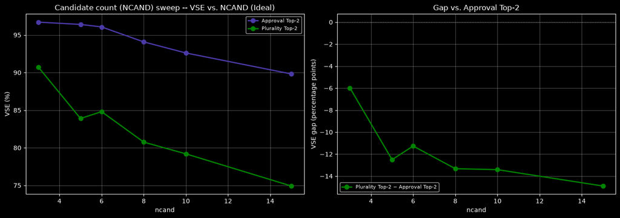

Mild friction: VSE by candidate count (NCAND)

| ncand | Approval Top-2 VSE (%) | Plurality Top-2 VSE (%) | Gap (pp) |
| --- | --- | --- | --- |
| 3 | 95.1% (+/-1.3) | 91.6% (+/-1.7) | +3.5 |
| 5 | 93.6% (+/-0.9) | 88.9% (+/-1.7) | +4.8 |
| 6 | 91.8% (+/-1.0) | 88.0% (+/-1.5) | +3.9 |
| 8 | 88.7% (+/-1.1) | 85.3% (+/-1.7) | +3.4 |
| 10 | 87.5% (+/-1.0) | 83.6% (+/-1.9) | +3.9 |
| 15 | 84.4% (+/-1.2) | 80.1% (+/-1.9) | +4.4 |

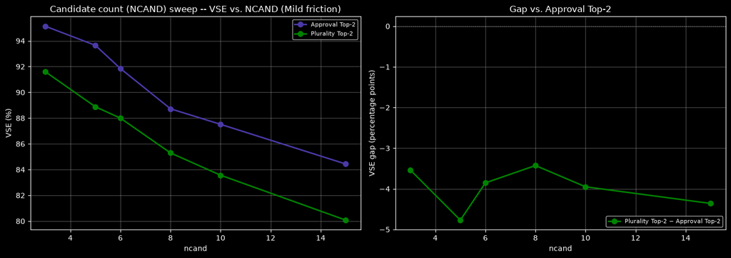

Moderate friction: VSE by candidate count (NCAND)

| ncand | Approval Top-2 VSE (%) | Plurality Top-2 VSE (%) | Gap (pp) |
| --- | --- | --- | --- |
| 3 | 92.2% (+/-1.5) | 90.3% (+/-1.8) | +1.9 |
| 5 | 84.3% (+/-1.7) | 84.6% (+/-1.7) | -0.3 |
| 6 | 82.1% (+/-1.8) | 82.7% (+/-1.7) | -0.7 |
| 8 | 77.8% (+/-2.0) | 78.3% (+/-1.9) | -0.5 |
| 10 | 77.5% (+/-1.8) | 77.4% (+/-1.8) | +0.1 |
| 15 | 76.2% (+/-1.7) | 75.4% (+/-1.8) | +0.8 |

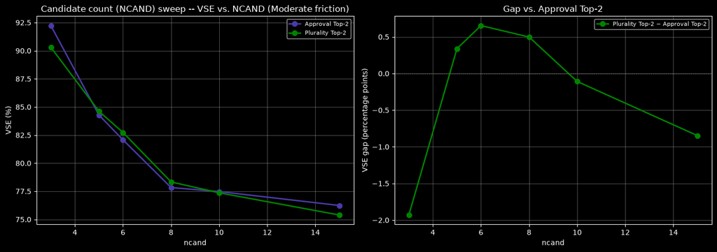

Heavy friction: VSE by candidate count (NCAND)

| ncand | Approval Top-2 VSE (%) | Plurality Top-2 VSE (%) | Gap (pp) |
| --- | --- | --- | --- |
| 3 | 83.9% (+/-2.3) | 83.0% (+/-2.4) | +0.9 |
| 5 | 74.2% (+/-2.4) | 73.1% (+/-2.4) | +1.1 |
| 6 | 72.9% (+/-2.3) | 73.1% (+/-2.2) | -0.2 |
| 8 | 69.5% (+/-2.3) | 69.0% (+/-2.4) | +0.5 |
| 10 | 69.8% (+/-2.1) | 69.5% (+/-2.1) | +0.3 |
| 15 | 66.9% (+/-2.2) | 66.9% (+/-2.3) | +0.0 |

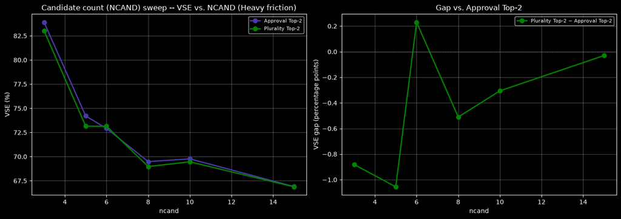

```python
def candidate_comparison_table(results_by_ncand, labels, ncand_key):
    """Display a Markdown table comparing VSE by candidate count (NCAND) for the given labels.

    results_by_ncand: {ncand: {(label, chooser): (mean, ci)}}
    labels: list of method labels to include in the table
    ncand_key: string label for the candidate count column
    """
    header = [ncand_key] + [f"{label} VSE (%)" for label in labels] + ["Gap (pp)"]
    lines = ["| " + " | ".join(header) + " |", "|" + "---|" * len(header)]
    for ncand in sorted(results_by_ncand):
        row = [str(ncand)]
        for label in labels:
            mean_, ci = results_by_ncand[ncand][(label, "honBallot")]
            row.append(f"{mean_ * 100:.1f}% (+/-{ci * 100:.1f})")
        if len(labels) == 2:
            gap = (results_by_ncand[ncand][(labels[0], "honBallot")][0] -
                   results_by_ncand[ncand][(labels[1], "honBallot")][0]) * 100
            row.append(f"{gap:+.1f}")
        lines.append("| " + " | ".join(row) + " |")
    display(Markdown("\n".join(lines)))

for scenario_name, ncand_results in results_by_scenario_ncand.items():
    plot_title = f"Candidate count (NCAND) sweep -- VSE vs. NCAND ({scenario_name})"
    display(Markdown(f"#### {scenario_name}: VSE by candidate count (NCAND)"))
    candidate_comparison_table(ncand_results, NCAND_SWEEP_LABELS, "ncand")
    comparison_chart(ncand_results, NCAND_SWEEP_LABELS, "ncand",
                  baseline_label="Approval Top-2", title=plot_title)
```

```python
# Per-scenario NCAND tables: AT2 vs PT2 with a genuine paired 95% CI on the VSE gap. Both methods
# already run on the SAME per-election data (electorates_by_ncand is shared), and the gap itself
# is now accumulated per election via run_vse_simulation's paired_diff_pairs -- not approximated
# afterward from the two methods' independent CIs the way this cell used to. Gap is (AT2 - PT2),
# in percentage points, matching Section 18's convention.

for scenario_name, ncand_results in results_by_scenario_ncand.items():
    lines = [
        f"#### {scenario_name}",
        "",
        "| NCAND | AT2 VSE | PT2 VSE | Gap (AT2 - PT2, pp) | 95% CI (paired, pp) | Significant? |",
        "|---:|---:|---:|---:|---:|---:|",
    ]

    for ncand in sorted(ncand_results):
        pt2_mean, _ = ncand_results[ncand][("Plurality Top-2", "honBallot")]
        at2_mean, _ = ncand_results[ncand][("Approval Top-2", "honBallot")]

        gap_pp = (at2_mean - pt2_mean) * 100
        gap_ci_pp = paired_diff_by_scenario_ncand[scenario_name][ncand][("Approval Top-2", "Plurality Top-2")][1] * 100
        _register_significance(f"AT2 vs PT2 by candidate count: {scenario_name}", f"NCAND={ncand}", gap_pp, gap_ci_pp, "Approval Top-2", "Plurality Top-2", spotlight=True)
        _, sig = _verdict_text(gap_pp, gap_ci_pp, "Approval Top-2", "Plurality Top-2")
        lo = gap_pp - gap_ci_pp
        hi = gap_pp + gap_ci_pp
        lines.append(
            f"| {ncand} | {at2_mean * 100:.2f}% | {pt2_mean * 100:.2f}% | {gap_pp:+.2f} | [{lo:+.2f}, {hi:+.2f}] | {sig} |"
        )

    display(Markdown("\n".join(lines)))
```

Ideal

| NCAND | AT2 VSE | PT2 VSE | Gap (AT2 - PT2, pp) | 95% CI (paired, pp) | Significant? |
| --- | --- | --- | --- | --- | --- |
| 3 | 96.71% | 90.73% | +5.98 | [+4.48, +7.47] | Decisive (Approval Top-2 better) |
| 5 | 96.40% | 83.90% | +12.50 | [+10.22, +14.78] | Decisive (Approval Top-2 better) |
| 6 | 96.07% | 84.81% | +11.26 | [+9.10, +13.43] | Decisive (Approval Top-2 better) |
| 8 | 94.08% | 80.75% | +13.32 | [+10.76, +15.89] | Decisive (Approval Top-2 better) |
| 10 | 92.61% | 79.19% | +13.41 | [+10.95, +15.87] | Decisive (Approval Top-2 better) |
| 15 | 89.82% | 74.92% | +14.90 | [+12.39, +17.41] | Decisive (Approval Top-2 better) |

Mild friction

| NCAND | AT2 VSE | PT2 VSE | Gap (AT2 - PT2, pp) | 95% CI (paired, pp) | Significant? |
| --- | --- | --- | --- | --- | --- |
| 3 | 95.14% | 91.60% | +3.54 | [+2.14, +4.93] | Decisive (Approval Top-2 better) |
| 5 | 93.65% | 88.88% | +4.77 | [+3.14, +6.39] | Decisive (Approval Top-2 better) |
| 6 | 91.85% | 88.00% | +3.85 | [+2.37, +5.34] | Decisive (Approval Top-2 better) |
| 8 | 88.72% | 85.30% | +3.43 | [+1.84, +5.02] | Decisive (Approval Top-2 better) |
| 10 | 87.52% | 83.57% | +3.95 | [+2.08, +5.82] | Decisive (Approval Top-2 better) |
| 15 | 84.44% | 80.08% | +4.36 | [+2.54, +6.18] | Decisive (Approval Top-2 better) |

Moderate friction

| NCAND | AT2 VSE | PT2 VSE | Gap (AT2 - PT2, pp) | 95% CI (paired, pp) | Significant? |
| --- | --- | --- | --- | --- | --- |
| 3 | 92.23% | 90.30% | +1.93 | [+0.48, +3.38] | Ambiguous edge (Approval Top-2 better) |
| 5 | 84.28% | 84.62% | -0.34 | [-1.51, +0.84] | Inconclusive |
| 6 | 82.08% | 82.73% | -0.65 | [-1.85, +0.55] | Inconclusive |
| 8 | 77.84% | 78.33% | -0.50 | [-1.83, +0.83] | Inconclusive |
| 10 | 77.47% | 77.37% | +0.11 | [-1.28, +1.49] | Inconclusive |
| 15 | 76.24% | 75.39% | +0.85 | [-0.21, +1.91] | Inconclusive |

Heavy friction

| NCAND | AT2 VSE | PT2 VSE | Gap (AT2 - PT2, pp) | 95% CI (paired, pp) | Significant? |
| --- | --- | --- | --- | --- | --- |
| 3 | 83.90% | 83.02% | +0.88 | [-0.22, +1.98] | Inconclusive |
| 5 | 74.20% | 73.15% | +1.06 | [-0.03, +2.14] | Inconclusive |
| 6 | 72.91% | 73.14% | -0.23 | [-1.47, +1.01] | Inconclusive |
| 8 | 69.48% | 68.97% | +0.51 | [-0.42, +1.44] | Inconclusive |
| 10 | 69.77% | 69.46% | +0.31 | [-0.80, +1.41] | Inconclusive |
| 15 | 66.90% | 66.87% | +0.03 | [-0.70, +0.76] | Indistinguishable |

## 26. Per-election VSE spread: what's behind the average

Every VSE number reported above is a mean over hundreds of individual elections, each contributing exactly one value of `(u(winner) - mean(u(c))) / (max(u(c)) - mean(u(c)))`. A bar chart with a 95% CI whisker summarizes that distribution but doesn't show its shape. This section histograms the per-election values directly -- honest ballots only, for the six methods that matter most to the Approval-vs-STAR-vs-Schulze comparisons above (STAR, Approval, Approval Top-2, Plurality, Plurality Top-2, Condorcet (Schulze)) -- across the same four joint-friction scenarios as Section 16, with a dashed line at the mean already reported there.

No new simulation: `ideal_raw_vse` (Section 9) and `joint_raw_vse_by_scenario` (Section 16, via `run_vse_simulation`'s `raw_vse_sink`) capture every election's `vse` value as it's computed, instead of only the running sums `reduce_to_mean_ci` needs -- so the dashed mean line below is computed from, and therefore matches exactly, the number already shown in Section 16's table and bar chart for that method and scenario.

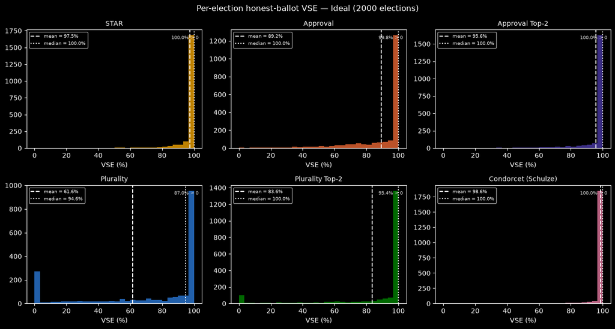

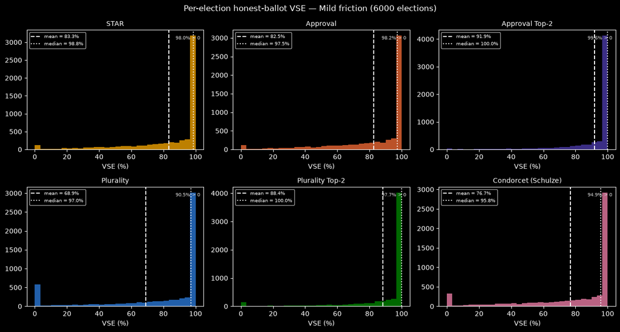

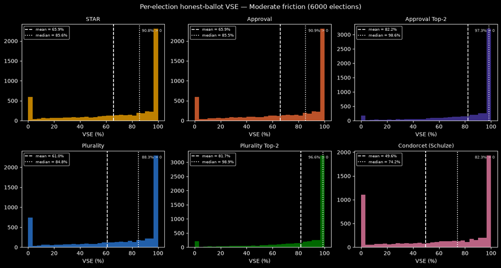

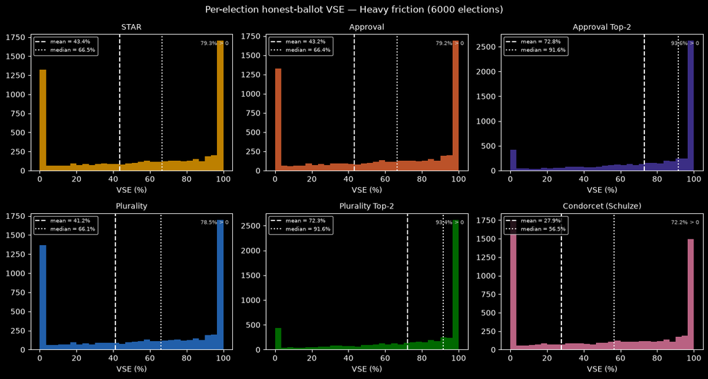

```python
HIST_LABELS = ["STAR", "Approval", "Approval Top-2", "Plurality", "Plurality Top-2", "Condorcet (Schulze)"]
_scenario_names = list(JOINT_SCENARIOS)  # Ideal, Mild friction, Moderate friction, Heavy friction

CLAMP_NEGATIVE_VALUES = True  # True: collapse every VSE < 0 into the single leftmost bucket (at
                               # 0%) instead of stretching the x-axis to fit an absurdly long,
                               # sparse negative tail that hides the shape of the real (mostly
                               # positive) distribution. Flip to False to see the true unclamped
                               # tail, with an x=0 reference line instead.

# Shared x-range per method (pooled across all 4 scenarios) so the four separate figures below
# are visually comparable panel-to-panel for a given method -- the whole point is spotting
# whether Ideal is tighter than Heavy friction, which a per-figure autoscaled axis would hide.
_hist_range = {}
for _label in HIST_LABELS:
    _all_vals = [v for _name in _scenario_names for v in joint_raw_vse_by_scenario[_name][(_label, "honBallot")]]
    _lo = 0.0 if CLAMP_NEGATIVE_VALUES else min(_all_vals)
    _hist_range[_label] = (_lo, max(_all_vals))

for _name in _scenario_names:
    fig, axes = plt.subplots(2, 3, figsize=(13, 7))
    for ax, _label in zip(axes.flat, HIST_LABELS):
        raw_vals = joint_raw_vse_by_scenario[_name][(_label, "honBallot")]
        frac_positive = np.mean([v > 0 for v in raw_vals]) * 100
        vals = [(max(v, 0.0) if CLAMP_NEGATIVE_VALUES else v) * 100 for v in raw_vals]
        mean_, _ci = joint_results[_name][(_label, "honBallot")]
        median_ = np.median(raw_vals)
        lo, hi = _hist_range[_label]
        ax.hist(vals, bins=30, range=(lo * 100, hi * 100), color=METHOD_COLORS[_label], alpha=0.8)
        ax.axvline(mean_ * 100, color=FG_COLOR, ls="--", lw=1.5, label=f"mean = {mean_ * 100:.1f}%")
        ax.axvline(median_ * 100, color=FG_COLOR, ls=":", lw=1.5, label=f"median = {median_ * 100:.1f}%")
        if not CLAMP_NEGATIVE_VALUES:
            ax.axvline(0, color="red", ls="-", lw=1, alpha=0.6, label="0%")
        ax.set_title(_label, fontsize=10)
        ax.set_xlabel("VSE (%)")
        ax.legend(fontsize=7, loc="upper left")
        ax.text(0.98, 0.95, f"{frac_positive:.1f}% > 0", transform=ax.transAxes, fontsize=7,
                 ha="right", va="top", color=MUTED_COLOR)
    fig.suptitle(f"Per-election honest-ballot VSE \u2014 {_name} ({JOINT_NITER if _name != 'Ideal' else NITER} elections)")
    plt.tight_layout()
    plt.show()
```

```python
## Check if the mode of all of these histograms is at 100%
# Check histogram modes allowing either scale:
# - raw fraction scale (mode ~= 1.0)
# - percent scale (mode ~= 100.0)
_mode_check_lines = [
    "| Scenario | Method | Inferred scale | Mode (raw) | Mode (%) | Count at mode | N | Mode is 1.0/100%? |",
    "|---|---|---|---:|---:|---:|---:|---|",
]

_mode_failures = []

for _name in _scenario_names:
    for _label in HIST_LABELS:
        _vals = np.asarray(joint_raw_vse_by_scenario[_name][(_label, "honBallot")], dtype=float)
        _vals = _vals[np.isfinite(_vals)]
        if _vals.size == 0:
            _mode_failures.append((_name, _label, "empty"))
            _mode_check_lines.append(f"| {_name} | {_label} | n/a | n/a | n/a | 0 | 0 | No |")
            continue

        # Empirical mode on raw values.
        _raw_rounded = np.round(_vals, 6)
        _raw_uniq, _raw_counts = np.unique(_raw_rounded, return_counts=True)
        _mode_raw = float(_raw_uniq[np.argmax(_raw_counts)])
        _mode_count = int(_raw_counts.max())

        # Convert to percent for display/comparison.
        _mode_pct = _mode_raw * 100.0

        # Infer likely storage scale for readability only.
        _scale = "percent-like" if np.nanmax(np.abs(_vals)) > 2 else "fraction-like"

        # Accept either canonical representation.
        _ok = np.isclose(_mode_raw, 1.0, atol=1e-6) or np.isclose(_mode_pct, 100.0, atol=1e-4)
        if not _ok:
            _mode_failures.append((_name, _label, _mode_raw, _mode_pct, _mode_count, len(_vals)))

        _mode_check_lines.append(
            f"| {_name} | {_label} | {_scale} | {_mode_raw:.6g} | {_mode_pct:.6g} | {_mode_count} | {len(_vals)} | {'Yes' if _ok else 'No'} |"
        )

display(Markdown("\n".join(_mode_check_lines)))

if _mode_failures:
    raise AssertionError(
        "Mode is neither 1.0 nor 100% for: "
        + ", ".join(
            f"{s}/{m} (raw={r:.6g}, pct={p:.6g})"
            for s, m, r, p, *_ in _mode_failures
            if len(_) >= 0
        )
    )

## Check if any systems have negative values occur more often than 1.0 or 100%. This is actually possible
for _name in _scenario_names:
    for _label in HIST_LABELS:
        _vals = np.asarray(joint_raw_vse_by_scenario[_name][(_label, "honBallot")], dtype=float)
        _vals = _vals[np.isfinite(_vals)]
        if _vals.size == 0:
            continue

        _neg_count = np.sum(_vals < 0)
        _neg_frac = _neg_count / len(_vals)
        hundred_pct_count = np.sum(np.isclose(_vals, 1.0, atol=1e-6) | np.isclose(_vals, 100.0, atol=1e-4))
        if _neg_frac > hundred_pct_count / len(_vals):
            print(f"{_name}/{_label} has more negative values ({_neg_count}/{len(_vals)} = {_neg_frac:.4f}) than count of 1.0/100% values ({hundred_pct_count}/{len(_vals)} = {hundred_pct_count/len(_vals):.4f})")
```

| Scenario | Method | Inferred scale | Mode (raw) | Mode (%) | Count at mode | N | Mode is 1.0/100%? |
| --- | --- | --- | --- | --- | --- | --- | --- |
| Ideal | STAR | fraction-like | 1 | 100 | 1571 | 2000 | Yes |
| Ideal | Approval | fraction-like | 1 | 100 | 1159 | 2000 | Yes |
| Ideal | Approval Top-2 | fraction-like | 1 | 100 | 1530 | 2000 | Yes |
| Ideal | Plurality | percent-like | 1 | 100 | 877 | 2000 | Yes |
| Ideal | Plurality Top-2 | percent-like | 1 | 100 | 1260 | 2000 | Yes |
| Ideal | Condorcet (Schulze) | fraction-like | 1 | 100 | 1782 | 2000 | Yes |
| Mild friction | STAR | percent-like | 1 | 100 | 2862 | 6000 | Yes |
| Mild friction | Approval | percent-like | 1 | 100 | 2741 | 6000 | Yes |
| Mild friction | Approval Top-2 | fraction-like | 1 | 100 | 3733 | 6000 | Yes |
| Mild friction | Plurality | percent-like | 1 | 100 | 2733 | 6000 | Yes |
| Mild friction | Plurality Top-2 | percent-like | 1 | 100 | 3677 | 6000 | Yes |
| Mild friction | Condorcet (Schulze) | percent-like | 1 | 100 | 2618 | 6000 | Yes |
| Moderate friction | STAR | percent-like | 1 | 100 | 1994 | 6000 | Yes |
| Moderate friction | Approval | percent-like | 1 | 100 | 2000 | 6000 | Yes |
| Moderate friction | Approval Top-2 | fraction-like | 1 | 100 | 2823 | 6000 | Yes |
| Moderate friction | Plurality | percent-like | 1 | 100 | 2001 | 6000 | Yes |
| Moderate friction | Plurality Top-2 | fraction-like | 1 | 100 | 2865 | 6000 | Yes |
| Moderate friction | Condorcet (Schulze) | percent-like | 1 | 100 | 1670 | 6000 | Yes |
| Heavy friction | STAR | percent-like | 1 | 100 | 1449 | 6000 | Yes |
| Heavy friction | Approval | percent-like | 1 | 100 | 1438 | 6000 | Yes |
| Heavy friction | Approval Top-2 | fraction-like | 1 | 100 | 2291 | 6000 | Yes |
| Heavy friction | Plurality | percent-like | 1 | 100 | 1446 | 6000 | Yes |
| Heavy friction | Plurality Top-2 | percent-like | 1 | 100 | 2286 | 6000 | Yes |
| Heavy friction | Condorcet (Schulze) | percent-like | 1 | 100 | 1269 | 6000 | Yes |

```
Heavy friction/Condorcet (Schulze) has more negative values (1669/6000 = 0.2782) than count of 1.0/100% values (1269/6000 = 0.2115)
```

## 27. Results Under a 99% Confidence Bar

Every paired-gap "Significant?" verdict earlier in this notebook uses a 95% CI (`Z_95 = 1.96`). This section re-checks those same gaps against a stricter 99% CI (`Z_99 ~= 2.576`). A CI's half-width scales linearly with z for a fixed standard error, so this is arithmetic on the stored 95% half-widths (`SIGNIFICANCE_LOG`, populated as each table above renders), not a re-run of anything.

**Run this after a full Restart & Run All, not standalone.** Same caveat as the Claims Dashboard below: this section only reads globals computed earlier in the notebook.

```python
_PART2_TABLE_KEYWORDS = ("Schulze", "Condorcet", "CE gap")

_not_sig_bullets = []
for _table_title, _rows in SIGNIFICANCE_LOG.items():
    if any(_kw in _table_title for _kw in _PART2_TABLE_KEYWORDS):
        continue
    for _row_label, _gap, _ci95, _pos_name, _neg_name, _spotlight in _rows:
        _ci99 = _ci95 * (Z_99 / Z_95)
        _bucket_95, _ = _verdict_text(_gap, _ci95, _pos_name, _neg_name)
        _bucket_99, _ = _verdict_text(_gap, _ci99, _pos_name, _neg_name)
        _sig_95 = _bucket_95 not in ("INDISTINGUISHABLE", "INCONCLUSIVE")
        _sig_99 = _bucket_99 not in ("INDISTINGUISHABLE", "INCONCLUSIVE")
        if _sig_95 and not _sig_99:
            _better, _worse = (_pos_name, _neg_name) if _gap > 0 else (_neg_name, _pos_name)
            _not_sig_bullets.append(
                f"- **{_table_title} / {_row_label}**: at 95% confidence, **{_better}** appeared "
                f"better than **{_worse}** by {abs(_gap):.1f}pp ({TAXONOMY_LABELS[_bucket_95]}, 95% CI "
                f"[{_gap-_ci95:+.1f}, {_gap+_ci95:+.1f}]). At 99% confidence that edge is no "
                f"longer significant ({TAXONOMY_LABELS[_bucket_99]}, 99% CI "
                f"[{_gap-_ci99:+.1f}, {_gap+_ci99:+.1f}], which contains 0)."
            )
display(Markdown(f"### {len(_not_sig_bullets)} result(s) lose significance at 99% confidence\n"))
if _not_sig_bullets:
    display(Markdown("\n".join(_not_sig_bullets)))
else:
    display(Markdown("None. Every 95%-significant result in this post's scope also holds at 99%."))
```

2 result(s) lose significance at 99% confidence

- **kappa threshold: Moderate friction / kappa=0.20**: at 95% confidence, **STAR** appeared better than **Approval Top-2** by 1.3pp (Ambiguous edge, 95% CI [-2.4, -0.3]). At 99% confidence that edge is no longer significant (Inconclusive, 99% CI [-2.7, +0.1], which contains 0).

- **Score5 vs STAR / Heavy friction**: at 95% confidence, **STAR** appeared better than **Score** by 0.6pp (Narrow edge, 95% CI [-1.0, -0.1]). At 99% confidence that edge is no longer significant (Inconclusive, 99% CI [-1.1, +0.0], which contains 0).

```python
_PART2_TABLE_KEYWORDS = ("Schulze", "Condorcet", "CE gap")

display(Markdown("### Spotlight: does each headline claim hold up at 99% confidence?\n"))
for _table_title, _rows in SIGNIFICANCE_LOG.items():
    if any(_kw in _table_title for _kw in _PART2_TABLE_KEYWORDS):
        continue
    _spotlight_rows = [r for r in _rows if r[5]]
    if not _spotlight_rows:
        continue
    _lines = [
        f"#### {_table_title}",
        "",
        "| Row | Gap (pp) | 95% verdict | 99% verdict |",
        "|---|---|---|---|",
    ]
    for _row_label, _gap, _ci95, _pos_name, _neg_name, _ in _spotlight_rows:
        _ci99 = _ci95 * (Z_99 / Z_95)
        _bucket_95, _verdict_95 = _verdict_text(_gap, _ci95, _pos_name, _neg_name)
        _bucket_99, _verdict_99 = _verdict_text(_gap, _ci99, _pos_name, _neg_name)
        if _bucket_95 != _bucket_99:
            _verdict_99 = f"**{_verdict_99}**"
        _lines.append(f"| {_row_label} | {_gap:+.1f} | {_verdict_95} | {_verdict_99} |")
    display(Markdown("\n".join(_lines)))
```

Spotlight: does each headline claim hold up at 99% confidence?

Approval-flavor gaps vs STAR: Ideal

| Row | Gap (pp) | 95% verdict | 99% verdict |
| --- | --- | --- | --- |
| Plurality Top-2 | -13.9 | Decisive (STAR better) | Decisive (STAR better) |
| Approval Top-2 | -1.9 | Decisive (STAR better) | Decisive (STAR better) |

Approval-flavor gaps vs STAR: Mild friction

| Row | Gap (pp) | 95% verdict | 99% verdict |
| --- | --- | --- | --- |
| Plurality Top-2 | +5.1 | Decisive (Plurality Top-2 better) | Decisive (Plurality Top-2 better) |
| Approval Top-2 | +8.6 | Decisive (Approval Top-2 better) | Decisive (Approval Top-2 better) |

Approval-flavor gaps vs STAR: Moderate friction

| Row | Gap (pp) | 95% verdict | 99% verdict |
| --- | --- | --- | --- |
| Plurality Top-2 | +15.9 | Decisive (Plurality Top-2 better) | Decisive (Plurality Top-2 better) |
| Approval Top-2 | +16.3 | Decisive (Approval Top-2 better) | Decisive (Approval Top-2 better) |

Approval-flavor gaps vs STAR: Heavy friction

| Row | Gap (pp) | 95% verdict | 99% verdict |
| --- | --- | --- | --- |
| Plurality Top-2 | +28.9 | Decisive (Plurality Top-2 better) | Decisive (Plurality Top-2 better) |
| Approval Top-2 | +29.4 | Decisive (Approval Top-2 better) | Decisive (Approval Top-2 better) |

Approval Top-2 vs Plurality Top-2

| Row | Gap (pp) | 95% verdict | 99% verdict |
| --- | --- | --- | --- |
| Ideal | +12.0 | Decisive (AT2 better) | Decisive (AT2 better) |
| Mild friction | +3.6 | Decisive (AT2 better) | Decisive (AT2 better) |
| Moderate friction | +0.5 | Inconclusive | Inconclusive |
| Heavy friction | +0.5 | Inconclusive | Inconclusive |

Approval Top-2 (Clear-Eyed) vs Plurality Top-2 (Clear-Eyed)

| Row | Gap (pp) | 95% verdict | 99% verdict |
| --- | --- | --- | --- |
| Ideal | +12.0 | Decisive (AT2 better) | Decisive (AT2 better) |
| Mild friction | +3.5 | Decisive (AT2 better) | Decisive (AT2 better) |
| Moderate friction | +0.8 | Ambiguous edge (AT2 better) | Ambiguous edge (AT2 better) |
| Heavy friction | +0.8 | Ambiguous edge (AT2 better) | Ambiguous edge (AT2 better) |

Approval vs Plurality

| Row | Gap (pp) | 95% verdict | 99% verdict |
| --- | --- | --- | --- |
| Ideal | +27.5 | Decisive (Approval better) | Decisive (Approval better) |
| Mild friction | +13.6 | Decisive (Approval better) | Decisive (Approval better) |
| Moderate friction | +4.9 | Decisive (Approval better) | Decisive (Approval better) |
| Heavy friction | +1.9 | Decisive (Approval better) | **Ambiguous edge (Approval better)** |

kappa threshold: Mild friction

| Row | Gap (pp) | 95% verdict | 99% verdict |
| --- | --- | --- | --- |
| kappa=0.00 | -2.3 | Decisive (STAR better) | Decisive (STAR better) |
| kappa=0.10 | -0.6 | Inconclusive | Inconclusive |
| kappa=0.13 | -0.1 | Indistinguishable | **Inconclusive** |
| kappa=0.17 | +0.2 | Indistinguishable | **Inconclusive** |
| kappa=0.20 | +1.2 | Ambiguous edge (Approval Top-2 better) | Ambiguous edge (Approval Top-2 better) |
| kappa=0.23 | +1.5 | Ambiguous edge (Approval Top-2 better) | Ambiguous edge (Approval Top-2 better) |
| kappa=0.25 | +1.9 | Decisive (Approval Top-2 better) | Decisive (Approval Top-2 better) |
| kappa=0.27 | +2.1 | Decisive (Approval Top-2 better) | Decisive (Approval Top-2 better) |
| kappa=0.30 | +2.2 | Decisive (Approval Top-2 better) | Decisive (Approval Top-2 better) |
| kappa=0.33 | +3.2 | Decisive (Approval Top-2 better) | Decisive (Approval Top-2 better) |
| kappa=0.40 | +4.1 | Decisive (Approval Top-2 better) | Decisive (Approval Top-2 better) |
| kappa=0.60 | +6.2 | Decisive (Approval Top-2 better) | Decisive (Approval Top-2 better) |
| kappa=0.80 | +8.0 | Decisive (Approval Top-2 better) | Decisive (Approval Top-2 better) |
| kappa=1.00 | +8.6 | Decisive (Approval Top-2 better) | Decisive (Approval Top-2 better) |

kappa threshold: Moderate friction

| Row | Gap (pp) | 95% verdict | 99% verdict |
| --- | --- | --- | --- |
| kappa=0.00 | -8.0 | Decisive (STAR better) | Decisive (STAR better) |
| kappa=0.10 | -5.0 | Decisive (STAR better) | Decisive (STAR better) |
| kappa=0.13 | -3.8 | Decisive (STAR better) | Decisive (STAR better) |
| kappa=0.17 | -2.5 | Decisive (STAR better) | Decisive (STAR better) |
| kappa=0.20 | -1.3 | Ambiguous edge (STAR better) | **Inconclusive** |
| kappa=0.23 | -0.6 | Inconclusive | Inconclusive |
| kappa=0.25 | +0.1 | Inconclusive | Inconclusive |
| kappa=0.27 | +0.5 | Inconclusive | Inconclusive |
| kappa=0.30 | +2.0 | Ambiguous edge (Approval Top-2 better) | Ambiguous edge (Approval Top-2 better) |
| kappa=0.33 | +3.3 | Decisive (Approval Top-2 better) | Decisive (Approval Top-2 better) |
| kappa=0.40 | +5.3 | Decisive (Approval Top-2 better) | Decisive (Approval Top-2 better) |
| kappa=0.60 | +11.2 | Decisive (Approval Top-2 better) | Decisive (Approval Top-2 better) |
| kappa=0.80 | +15.5 | Decisive (Approval Top-2 better) | Decisive (Approval Top-2 better) |
| kappa=1.00 | +16.7 | Decisive (Approval Top-2 better) | Decisive (Approval Top-2 better) |

kappa threshold: Heavy friction

| Row | Gap (pp) | 95% verdict | 99% verdict |
| --- | --- | --- | --- |
| kappa=0.00 | -11.9 | Decisive (STAR better) | Decisive (STAR better) |
| kappa=0.10 | -6.4 | Decisive (STAR better) | Decisive (STAR better) |
| kappa=0.13 | -5.1 | Decisive (STAR better) | Decisive (STAR better) |
| kappa=0.17 | -3.6 | Decisive (STAR better) | Decisive (STAR better) |
| kappa=0.20 | -2.0 | Ambiguous edge (STAR better) | Ambiguous edge (STAR better) |
| kappa=0.23 | -0.4 | Inconclusive | Inconclusive |
| kappa=0.25 | +2.3 | Decisive (Approval Top-2 better) | **Ambiguous edge (Approval Top-2 better)** |
| kappa=0.27 | +2.3 | Ambiguous edge (Approval Top-2 better) | Ambiguous edge (Approval Top-2 better) |
| kappa=0.30 | +3.4 | Decisive (Approval Top-2 better) | Decisive (Approval Top-2 better) |
| kappa=0.33 | +6.3 | Decisive (Approval Top-2 better) | Decisive (Approval Top-2 better) |
| kappa=0.40 | +9.4 | Decisive (Approval Top-2 better) | Decisive (Approval Top-2 better) |
| kappa=0.60 | +19.2 | Decisive (Approval Top-2 better) | Decisive (Approval Top-2 better) |
| kappa=0.80 | +25.8 | Decisive (Approval Top-2 better) | Decisive (Approval Top-2 better) |
| kappa=1.00 | +28.0 | Decisive (Approval Top-2 better) | Decisive (Approval Top-2 better) |

Score Top-2 (Clear-Eyed) vs Approval Top-2 (Clear-Eyed)

| Row | Gap (pp) | 95% verdict | 99% verdict |
| --- | --- | --- | --- |
| Ideal | +2.4 | Decisive (Score Top-2 better) | Decisive (Score Top-2 better) |
| Mild friction | +0.0 | Indistinguishable | Indistinguishable |
| Moderate friction | +0.1 | Indistinguishable | Indistinguishable |
| Heavy friction | -0.1 | Indistinguishable | Indistinguishable |

AT2 vs PT2 by candidate count: Ideal

| Row | Gap (pp) | 95% verdict | 99% verdict |
| --- | --- | --- | --- |
| NCAND=3 | +6.0 | Decisive (Approval Top-2 better) | Decisive (Approval Top-2 better) |
| NCAND=5 | +12.5 | Decisive (Approval Top-2 better) | Decisive (Approval Top-2 better) |
| NCAND=6 | +11.3 | Decisive (Approval Top-2 better) | Decisive (Approval Top-2 better) |
| NCAND=8 | +13.3 | Decisive (Approval Top-2 better) | Decisive (Approval Top-2 better) |
| NCAND=10 | +13.4 | Decisive (Approval Top-2 better) | Decisive (Approval Top-2 better) |
| NCAND=15 | +14.9 | Decisive (Approval Top-2 better) | Decisive (Approval Top-2 better) |

AT2 vs PT2 by candidate count: Mild friction

| Row | Gap (pp) | 95% verdict | 99% verdict |
| --- | --- | --- | --- |
| NCAND=3 | +3.5 | Decisive (Approval Top-2 better) | Decisive (Approval Top-2 better) |
| NCAND=5 | +4.8 | Decisive (Approval Top-2 better) | Decisive (Approval Top-2 better) |
| NCAND=6 | +3.9 | Decisive (Approval Top-2 better) | Decisive (Approval Top-2 better) |
| NCAND=8 | +3.4 | Decisive (Approval Top-2 better) | Decisive (Approval Top-2 better) |
| NCAND=10 | +3.9 | Decisive (Approval Top-2 better) | Decisive (Approval Top-2 better) |
| NCAND=15 | +4.4 | Decisive (Approval Top-2 better) | Decisive (Approval Top-2 better) |

AT2 vs PT2 by candidate count: Moderate friction

| Row | Gap (pp) | 95% verdict | 99% verdict |
| --- | --- | --- | --- |
| NCAND=3 | +1.9 | Ambiguous edge (Approval Top-2 better) | Ambiguous edge (Approval Top-2 better) |
| NCAND=5 | -0.3 | Inconclusive | Inconclusive |
| NCAND=6 | -0.7 | Inconclusive | Inconclusive |
| NCAND=8 | -0.5 | Inconclusive | Inconclusive |
| NCAND=10 | +0.1 | Inconclusive | Inconclusive |
| NCAND=15 | +0.8 | Inconclusive | Inconclusive |

AT2 vs PT2 by candidate count: Heavy friction

| Row | Gap (pp) | 95% verdict | 99% verdict |
| --- | --- | --- | --- |
| NCAND=3 | +0.9 | Inconclusive | Inconclusive |
| NCAND=5 | +1.1 | Inconclusive | Inconclusive |
| NCAND=6 | -0.2 | Inconclusive | Inconclusive |
| NCAND=8 | +0.5 | Inconclusive | Inconclusive |
| NCAND=10 | +0.3 | Inconclusive | Inconclusive |
| NCAND=15 | +0.0 | Indistinguishable | Indistinguishable |

```python
_PART2_TABLE_KEYWORDS = ("Schulze", "Condorcet", "CE gap")

_not_sig_bullets = []
for _table_title, _rows in SIGNIFICANCE_LOG.items():
    if not any(_kw in _table_title for _kw in _PART2_TABLE_KEYWORDS):
        continue
    for _row_label, _gap, _ci95, _pos_name, _neg_name, _spotlight in _rows:
        _ci99 = _ci95 * (Z_99 / Z_95)
        _bucket_95, _ = _verdict_text(_gap, _ci95, _pos_name, _neg_name)
        _bucket_99, _ = _verdict_text(_gap, _ci99, _pos_name, _neg_name)
        _sig_95 = _bucket_95 not in ("INDISTINGUISHABLE", "INCONCLUSIVE")
        _sig_99 = _bucket_99 not in ("INDISTINGUISHABLE", "INCONCLUSIVE")
        if _sig_95 and not _sig_99:
            _better, _worse = (_pos_name, _neg_name) if _gap > 0 else (_neg_name, _pos_name)
            _not_sig_bullets.append(
                f"- **{_table_title} -- {_row_label}**: at 95% confidence, **{_better}** appeared "
                f"better than **{_worse}** by {abs(_gap):.1f}pp ({TAXONOMY_LABELS[_bucket_95]}, 95% CI "
                f"[{_gap-_ci95:+.1f}, {_gap+_ci95:+.1f}]) -- but at 99% confidence that edge is no "
                f"longer significant ({TAXONOMY_LABELS[_bucket_99]}, 99% CI "
                f"[{_gap-_ci99:+.1f}, {_gap+_ci99:+.1f}], which contains 0)."
            )
display(Markdown(f"### {len(_not_sig_bullets)} result(s) lose significance at 99% confidence\n"))
if _not_sig_bullets:
    display(Markdown("\n".join(_not_sig_bullets)))
else:
    display(Markdown("None -- every 95%-significant result in this post's scope also holds at 99%."))
```

1 result(s) lose significance at 99% confidence

- **CE gap vs Schulze: Moderate friction -- RCV (IRV)**: at 95% confidence, **RCV (IRV)** appeared better than **Condorcet (Schulze)** by 0.3pp (Narrow edge, 95% CI [+0.1, +0.6]) -- but at 99% confidence that edge is no longer significant (Indistinguishable, 99% CI [-0.0, +0.7], which contains 0).

```python
_PART2_TABLE_KEYWORDS = ("Schulze", "Condorcet", "CE gap")

display(Markdown("### Spotlight: does each headline claim hold up at 99% confidence?\n"))
for _table_title, _rows in SIGNIFICANCE_LOG.items():
    if not any(_kw in _table_title for _kw in _PART2_TABLE_KEYWORDS):
        continue
    _spotlight_rows = [r for r in _rows if r[5]]
    if not _spotlight_rows:
        continue
    _lines = [
        f"#### {_table_title}",
        "",
        "| Row | Gap (pp) | 95% verdict | 99% verdict |",
        "|---|---|---|---|",
    ]
    for _row_label, _gap, _ci95, _pos_name, _neg_name, _ in _spotlight_rows:
        _ci99 = _ci95 * (Z_99 / Z_95)
        _bucket_95, _verdict_95 = _verdict_text(_gap, _ci95, _pos_name, _neg_name)
        _bucket_99, _verdict_99 = _verdict_text(_gap, _ci99, _pos_name, _neg_name)
        if _bucket_95 != _bucket_99:
            _verdict_99 = f"**{_verdict_99}**"
        _lines.append(f"| {_row_label} | {_gap:+.1f} | {_verdict_95} | {_verdict_99} |")
    display(Markdown("\n".join(_lines)))
```

Spotlight: does each headline claim hold up at 99% confidence?

CE gap vs Schulze: Ideal

| Row | Gap (pp) | 95% verdict | 99% verdict |
| --- | --- | --- | --- |
| Approval Top-2 | -17.9 | Decisive (Condorcet (Schulze) better) | Decisive (Condorcet (Schulze) better) |
| STAR | -20.7 | Decisive (Condorcet (Schulze) better) | Decisive (Condorcet (Schulze) better) |
| Score5 | -29.1 | Decisive (Condorcet (Schulze) better) | Decisive (Condorcet (Schulze) better) |
| Plurality Top-2 | -33.8 | Decisive (Condorcet (Schulze) better) | Decisive (Condorcet (Schulze) better) |
| RCV (IRV) | -36.0 | Decisive (Condorcet (Schulze) better) | Decisive (Condorcet (Schulze) better) |
| Approval | -42.2 | Decisive (Condorcet (Schulze) better) | Decisive (Condorcet (Schulze) better) |
| Plurality | -55.6 | Decisive (Condorcet (Schulze) better) | Decisive (Condorcet (Schulze) better) |

CE gap vs Schulze: Mild friction

| Row | Gap (pp) | 95% verdict | 99% verdict |
| --- | --- | --- | --- |
| Approval Top-2 (Clear-Eyed) | +27.8 | Decisive (Approval Top-2 (Clear-Eyed) better) | Decisive (Approval Top-2 (Clear-Eyed) better) |
| Score Top-2 (Clear-Eyed) | +27.2 | Decisive (Score Top-2 (Clear-Eyed) better) | Decisive (Score Top-2 (Clear-Eyed) better) |
| Plurality Top-2 (Clear-Eyed) | +25.2 | Decisive (Plurality Top-2 (Clear-Eyed) better) | Decisive (Plurality Top-2 (Clear-Eyed) better) |
| Approval Top-2 | +17.5 | Decisive (Approval Top-2 better) | Decisive (Approval Top-2 better) |
| Plurality Top-2 | +16.8 | Decisive (Plurality Top-2 better) | Decisive (Plurality Top-2 better) |
| STAR | +3.7 | Decisive (STAR better) | Decisive (STAR better) |
| Approval | +1.8 | Decisive (Approval better) | **Ambiguous edge (Approval better)** |
| Plurality | +1.6 | Ambiguous edge (Plurality better) | Ambiguous edge (Plurality better) |
| Approval Top-2 (Coma) | +1.5 | Ambiguous edge (Approval Top-2 (Coma) better) | Ambiguous edge (Approval Top-2 (Coma) better) |
| Score5 | +1.5 | Ambiguous edge (Score5 better) | Ambiguous edge (Score5 better) |
| RCV (IRV) | -1.2 | Ambiguous edge (Condorcet (Schulze) better) | Ambiguous edge (Condorcet (Schulze) better) |

CE gap vs Schulze: Moderate friction

| Row | Gap (pp) | 95% verdict | 99% verdict |
| --- | --- | --- | --- |
| Plurality Top-2 (Clear-Eyed) | +26.4 | Decisive (Plurality Top-2 (Clear-Eyed) better) | Decisive (Plurality Top-2 (Clear-Eyed) better) |
| Approval Top-2 (Clear-Eyed) | +25.8 | Decisive (Approval Top-2 (Clear-Eyed) better) | Decisive (Approval Top-2 (Clear-Eyed) better) |
| Score Top-2 (Clear-Eyed) | +25.5 | Decisive (Score Top-2 (Clear-Eyed) better) | Decisive (Score Top-2 (Clear-Eyed) better) |
| Plurality Top-2 | +19.9 | Decisive (Plurality Top-2 better) | Decisive (Plurality Top-2 better) |
| Approval Top-2 | +19.2 | Decisive (Approval Top-2 better) | Decisive (Approval Top-2 better) |
| Approval | +5.4 | Decisive (Approval better) | Decisive (Approval better) |
| STAR | +5.4 | Decisive (STAR better) | Decisive (STAR better) |
| Plurality | +5.4 | Decisive (Plurality better) | Decisive (Plurality better) |
| Score5 | +4.9 | Decisive (Score5 better) | Decisive (Score5 better) |
| Approval Top-2 (Coma) | +0.8 | Ambiguous edge (Approval Top-2 (Coma) better) | Ambiguous edge (Approval Top-2 (Coma) better) |
| RCV (IRV) | +0.3 | Narrow edge (RCV (IRV) better) | **Indistinguishable** |

CE gap vs Schulze: Heavy friction

| Row | Gap (pp) | 95% verdict | 99% verdict |
| --- | --- | --- | --- |
| Approval Top-2 (Clear-Eyed) | +23.2 | Decisive (Approval Top-2 (Clear-Eyed) better) | Decisive (Approval Top-2 (Clear-Eyed) better) |
| Plurality Top-2 (Clear-Eyed) | +23.1 | Decisive (Plurality Top-2 (Clear-Eyed) better) | Decisive (Plurality Top-2 (Clear-Eyed) better) |
| Score Top-2 (Clear-Eyed) | +22.9 | Decisive (Score Top-2 (Clear-Eyed) better) | Decisive (Score Top-2 (Clear-Eyed) better) |
| Plurality Top-2 | +17.5 | Decisive (Plurality Top-2 better) | Decisive (Plurality Top-2 better) |
| Approval Top-2 | +17.5 | Decisive (Approval Top-2 better) | Decisive (Approval Top-2 better) |
| STAR | +3.1 | Decisive (STAR better) | Decisive (STAR better) |
| Plurality | +3.0 | Decisive (Plurality better) | Decisive (Plurality better) |
| Approval | +3.0 | Decisive (Approval better) | Decisive (Approval better) |
| Score5 | +2.9 | Decisive (Score5 better) | Decisive (Score5 better) |
| RCV (IRV) | +0.0 | Indistinguishable | Indistinguishable |
| Approval Top-2 (Coma) | +0.0 | Indistinguishable | Indistinguishable |

# Claims Dashboard

## Part 1

Every `jupyter_cell_embed` the companion blog post (`_previews/2026-07-24-runoff-accuracy.md`) embeds from this notebook, re-displayed here in one place, in the same order the post reads them. After changing a parameter (`NITER`, a friction value, ...) and re-running, scroll through this one section to see at a glance whether any of the numbers/tables/charts the post relies on have moved -- instead of hunting back through each individual section.

**Run this after a full Restart & Run All, not standalone.** Every cell below only reads globals already computed earlier in the notebook (`joint_results`, `paired_diff_by_scenario`, `betrayal_by_scenario`, `results_by_scenario_ncand`, ...) -- it runs no new simulation of its own.

Each group's code cell below calls `replay("tag-name")` (defined just below), which re-reads this notebook's own saved `.ipynb` file, finds the cell tagged `"tag-name"`, and `exec`s its current source in place -- so it's always the SAME code as the original tagged cell, not a copy that can drift out of sync. Edit the original cell anywhere else in the notebook, save, re-run this section, and the dashboard picks up the change automatically.

```python
# Re-reads this notebook's own saved file, finds the cell(s) tagged `tag`, and execs their
# current source into this kernel's namespace -- see "Part 1" above for why.
import json as _json

_NB_SELF_PATH = "vse_simulation.ipynb"

def replay(tag):
    with open(_NB_SELF_PATH, encoding="utf-8") as f:
        _nb = _json.load(f)
    _matches = [c for c in _nb["cells"] if tag in c.get("metadata", {}).get("tags", [])]
    assert len(_matches) == 1, f"expected exactly 1 cell tagged {tag!r}, found {len(_matches)}"
    _src = "".join(_matches[0]["source"])
    exec(compile(_src, f"<tag:{tag}>", "exec"), globals())
```

### Introduction

```python
replay("evc-vse")
```

| Method | Computed | Honest VSE |
| --- | --- | --- |
| Plurality | 59.62% - 81.07% | 61.63% |
| Plurality Top-2 | 83.01% - 87.10% | 83.61% |
| RCV (IRV) | 76.68% - 87.91% | 87.91% |
| Approval | 83.87% - 95.02% | 89.18% |
| Approval Top-2 | 92.38% - 97.70% | 95.59% |
| STAR | 89.17% - 97.88% | 97.49% |
| Condorcet (Schulze) | 84.05% - 98.60% | 98.60% |

### Other Relevant Methodology

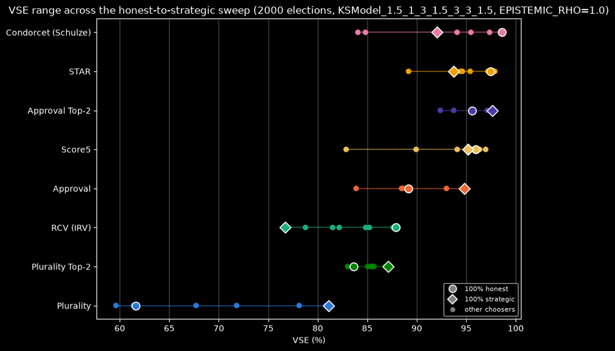

| Method | Computed | Documented |
| --- | --- | --- |
| Condorcet (Schulze) | 84.05% - 98.60% | 86-98% |
| Approval Top-2 | 92.38% - 97.70% | (no documented range on file) |
| STAR | 89.17% - 97.88% | 91-98% |
| Score5 | 82.87% - 96.96% | 84-96% |
| Plurality Top-2 | 83.01% - 87.10% | (no documented range on file) |
| RCV (IRV) | 76.68% - 87.91% | up to 87% |
| Approval | 83.87% - 95.02% | 89-95% |
| Plurality | 59.62% - 81.07% | ~75% |

**Condorcet (Schulze)**

| Chooser | VSE | 95% CI |
| --- | --- | --- |
| 100% honest | 98.60% | +/-0.31 |
| 25% strategic | 97.35% | +/-0.43 |
| 50% strategic | 95.47% | +/-0.56 |
| 75% strategic | 94.07% | +/-0.66 |
| 50% one-sided strategic | 92.03% | +/-0.83 |
| 100% strategic | 92.02% | +/-0.83 |
| smart one-sided strategic | 84.81% | +/-1.18 |
| 100% one-sided strategic | 84.05% | +/-1.18 |
| **range** | 84.05% - 98.60% |  |

**Approval Top-2**

| Chooser | VSE | 95% CI |
| --- | --- | --- |
| 75% strategic | 97.70% | +/-0.38 |
| 100% strategic | 97.63% | +/-0.41 |
| 50% strategic | 97.62% | +/-0.37 |
| 25% strategic | 97.12% | +/-0.41 |
| 50% one-sided strategic | 95.67% | +/-0.52 |
| 100% honest | 95.59% | +/-0.54 |
| smart one-sided strategic | 93.73% | +/-0.67 |
| 100% one-sided strategic | 92.38% | +/-0.74 |
| **range** | 92.38% - 97.70% |  |

**STAR**

| Chooser | VSE | 95% CI |
| --- | --- | --- |
| 25% strategic | 97.88% | +/-0.30 |
| 100% honest | 97.49% | +/-0.35 |
| 50% strategic | 97.18% | +/-0.38 |
| 75% strategic | 95.40% | +/-0.55 |
| 50% one-sided strategic | 94.62% | +/-0.59 |
| smart one-sided strategic | 94.41% | +/-0.60 |
| 100% strategic | 93.73% | +/-0.69 |
| 100% one-sided strategic | 89.17% | +/-0.88 |
| **range** | 89.17% - 97.88% |  |

**Score5**

| Chooser | VSE | 95% CI |
| --- | --- | --- |
| 25% strategic | 96.96% | +/-0.38 |
| 50% strategic | 96.34% | +/-0.46 |
| 100% honest | 95.92% | +/-0.44 |
| 75% strategic | 95.65% | +/-0.54 |
| 100% strategic | 95.18% | +/-0.58 |
| smart one-sided strategic | 94.09% | +/-0.61 |
| 50% one-sided strategic | 89.93% | +/-0.77 |
| 100% one-sided strategic | 82.87% | +/-1.07 |
| **range** | 82.87% - 96.96% |  |

**Plurality Top-2**

| Chooser | VSE | 95% CI |
| --- | --- | --- |
| 100% strategic | 87.10% | +/-1.30 |
| 75% strategic | 86.81% | +/-1.33 |
| 100% one-sided strategic | 85.69% | +/-1.41 |
| 50% strategic | 85.50% | +/-1.52 |
| 25% strategic | 85.38% | +/-1.61 |
| 50% one-sided strategic | 85.05% | +/-1.63 |
| 100% honest | 83.61% | +/-1.75 |
| smart one-sided strategic | 83.01% | +/-1.68 |
| **range** | 83.01% - 87.10% |  |

**RCV (IRV)**

| Chooser | VSE | 95% CI |
| --- | --- | --- |
| 100% honest | 87.91% | +/-1.27 |
| 25% strategic | 87.61% | +/-1.20 |
| 50% one-sided strategic | 85.22% | +/-1.39 |
| smart one-sided strategic | 84.84% | +/-1.41 |
| 50% strategic | 82.17% | +/-1.59 |
| 100% one-sided strategic | 81.50% | +/-1.60 |
| 75% strategic | 78.76% | +/-1.82 |
| 100% strategic | 76.68% | +/-1.96 |
| **range** | 76.68% - 87.91% |  |

**Approval**

| Chooser | VSE | 95% CI |
| --- | --- | --- |
| 75% strategic | 95.02% | +/-0.53 |
| 50% strategic | 94.95% | +/-0.51 |
| 100% strategic | 94.83% | +/-0.59 |
| 25% strategic | 93.00% | +/-0.63 |
| 100% honest | 89.18% | +/-0.85 |
| 50% one-sided strategic | 88.59% | +/-0.85 |
| smart one-sided strategic | 88.47% | +/-0.88 |
| 100% one-sided strategic | 83.87% | +/-1.01 |
| **range** | 83.87% - 95.02% |  |

**Plurality**

| Chooser | VSE | 95% CI |
| --- | --- | --- |
| 100% strategic | 81.07% | +/-1.71 |
| 75% strategic | 80.84% | +/-1.68 |
| 50% strategic | 78.12% | +/-1.84 |
| 25% strategic | 71.80% | +/-2.24 |
| 50% one-sided strategic | 67.71% | +/-2.57 |
| 100% honest | 61.63% | +/-2.81 |
| smart one-sided strategic | 61.37% | +/-2.84 |
| 100% one-sided strategic | 59.62% | +/-3.01 |
| **range** | 59.62% - 81.07% |  |

Probability table for mild friction (alpha=0.9, beta=0.9)

| Prominence rank \ Fatigue position | 0 | 1 | 2 | 3 | 4 | 5 |
| --- | --- | --- | --- | --- | --- | --- |
| 0 | 100.0% | 90.0% | 81.0% | 72.9% | 65.6% | 59.0% |
| 1 | 90.0% | 81.0% | 72.9% | 65.6% | 59.0% | 53.1% |
| 2 | 81.0% | 72.9% | 65.6% | 59.0% | 53.1% | 47.8% |
| 3 | 72.9% | 65.6% | 59.0% | 53.1% | 47.8% | 43.0% |
| 4 | 65.6% | 59.0% | 53.1% | 47.8% | 43.0% | 38.7% |
| 5 | 59.0% | 53.1% | 47.8% | 43.0% | 38.7% | 34.9% |

Probability table for moderate friction (alpha=0.8, beta=0.8)

| Prominence rank \ Fatigue position | 0 | 1 | 2 | 3 | 4 | 5 |
| --- | --- | --- | --- | --- | --- | --- |
| 0 | 100.0% | 80.0% | 64.0% | 51.2% | 41.0% | 32.8% |
| 1 | 80.0% | 64.0% | 51.2% | 41.0% | 32.8% | 26.2% |
| 2 | 64.0% | 51.2% | 41.0% | 32.8% | 26.2% | 21.0% |
| 3 | 51.2% | 41.0% | 32.8% | 26.2% | 21.0% | 16.8% |
| 4 | 41.0% | 32.8% | 26.2% | 21.0% | 16.8% | 13.4% |
| 5 | 32.8% | 26.2% | 21.0% | 16.8% | 13.4% | 10.7% |

Probability table for heavy friction (alpha=0.7, beta=0.7)

| Prominence rank \ Fatigue position | 0 | 1 | 2 | 3 | 4 | 5 |
| --- | --- | --- | --- | --- | --- | --- |
| 0 | 100.0% | 70.0% | 49.0% | 34.3% | 24.0% | 16.8% |
| 1 | 70.0% | 49.0% | 34.3% | 24.0% | 16.8% | 11.8% |
| 2 | 49.0% | 34.3% | 24.0% | 16.8% | 11.8% | 8.2% |
| 3 | 34.3% | 24.0% | 16.8% | 11.8% | 8.2% | 5.8% |
| 4 | 24.0% | 16.8% | 11.8% | 8.2% | 5.8% | 4.0% |
| 5 | 16.8% | 11.8% | 8.2% | 5.8% | 4.0% | 2.8% |

```python
replay("strategy-sweep-chart")
replay("vse-range-baseline")
replay("vse-tables")
replay("friction-table")
```

### Findings: The Approval-STAR Gap

Ideal: Approval-flavor gaps vs STAR (honest ballots)

| Method | VSE (%) | STAR VSE (%) | Gap vs STAR (pp) | 95% CI (paired, pp) | Significant? |
| --- | --- | --- | --- | --- | --- |
| Plurality | 61.6 | 97.5 | -35.9 | [-38.7, -33.0] | Decisive (STAR better) |
| Plurality Top-2 | 83.6 | 97.5 | -13.9 | [-15.7, -12.1] | Decisive (STAR better) |
| Approval | 89.2 | 97.5 | -8.3 | [-9.1, -7.5] | Decisive (STAR better) |
| Approval Top-2 | 95.6 | 97.5 | -1.9 | [-2.4, -1.4] | Decisive (STAR better) |

Mild friction: Approval-flavor gaps vs STAR (honest ballots)

| Method | VSE (%) | STAR VSE (%) | Gap vs STAR (pp) | 95% CI (paired, pp) | Significant? |
| --- | --- | --- | --- | --- | --- |
| Plurality | 68.9 | 83.3 | -14.4 | [-15.9, -12.9] | Decisive (STAR better) |
| Approval Top-2 (Coma) | 81.3 | 83.3 | -2.0 | [-2.5, -1.5] | Decisive (STAR better) |
| Approval | 82.5 | 83.3 | -0.8 | [-1.3, -0.3] | Ambiguous edge (STAR better) |
| Plurality Top-2 | 88.4 | 83.3 | +5.1 | [+4.3, +5.9] | Decisive (Plurality Top-2 better) |
| Plurality Top-2 (Clear-Eyed) | 89.1 | 83.3 | +5.8 | [+5.0, +6.6] | Decisive (Plurality Top-2 (Clear-Eyed) better) |
| Approval Top-2 | 91.9 | 83.3 | +8.6 | [+8.0, +9.2] | Decisive (Approval Top-2 better) |
| Approval Top-2 (Clear-Eyed) | 92.6 | 83.3 | +9.3 | [+8.7, +9.9] | Decisive (Approval Top-2 (Clear-Eyed) better) |

Moderate friction: Approval-flavor gaps vs STAR (honest ballots)

| Method | VSE (%) | STAR VSE (%) | Gap vs STAR (pp) | 95% CI (paired, pp) | Significant? |
| --- | --- | --- | --- | --- | --- |
| Approval Top-2 (Coma) | 57.0 | 65.9 | -8.9 | [-9.8, -7.9] | Decisive (STAR better) |
| Plurality | 61.0 | 65.9 | -4.8 | [-5.9, -3.8] | Decisive (STAR better) |
| Approval | 65.9 | 65.9 | +0.1 | [-0.5, +0.6] | Indistinguishable |
| Plurality Top-2 | 81.7 | 65.9 | +15.9 | [+14.9, +16.9] | Decisive (Plurality Top-2 better) |
| Approval Top-2 | 82.2 | 65.9 | +16.3 | [+15.4, +17.3] | Decisive (Approval Top-2 better) |
| Plurality Top-2 (Clear-Eyed) | 82.7 | 65.9 | +16.8 | [+15.8, +17.8] | Decisive (Plurality Top-2 (Clear-Eyed) better) |
| Approval Top-2 (Clear-Eyed) | 83.5 | 65.9 | +17.6 | [+16.6, +18.6] | Decisive (Approval Top-2 (Clear-Eyed) better) |

Heavy friction: Approval-flavor gaps vs STAR (honest ballots)

| Method | VSE (%) | STAR VSE (%) | Gap vs STAR (pp) | 95% CI (paired, pp) | Significant? |
| --- | --- | --- | --- | --- | --- |
| Approval Top-2 (Coma) | 31.6 | 43.4 | -11.8 | [-13.0, -10.5] | Decisive (STAR better) |
| Plurality | 41.2 | 43.4 | -2.2 | [-3.0, -1.4] | Decisive (STAR better) |
| Approval | 43.2 | 43.4 | -0.3 | [-0.8, +0.3] | Indistinguishable |
| Plurality Top-2 | 72.3 | 43.4 | +28.9 | [+27.4, +30.5] | Decisive (Plurality Top-2 better) |
| Approval Top-2 | 72.8 | 43.4 | +29.4 | [+27.9, +30.9] | Decisive (Approval Top-2 better) |
| Plurality Top-2 (Clear-Eyed) | 74.5 | 43.4 | +31.0 | [+29.5, +32.5] | Decisive (Plurality Top-2 (Clear-Eyed) better) |
| Approval Top-2 (Clear-Eyed) | 75.2 | 43.4 | +31.8 | [+30.3, +33.3] | Decisive (Approval Top-2 (Clear-Eyed) better) |

Method/scenario pairs where STAR's VSE is significantly higher than the method's (95% CI does NOT contain 0)

| Method | Scenario | VSE - STAR VSE (pp) | 95% CI (paired, pp) | Significant? |
| --- | --- | --- | --- | --- |
| Plurality | Ideal | -35.9 | [-38.7, -33.0] | Decisive (STAR better) |
| Plurality Top-2 | Ideal | -13.9 | [-15.7, -12.1] | Decisive (STAR better) |
| Approval | Ideal | -8.3 | [-9.1, -7.5] | Decisive (STAR better) |
| Approval Top-2 | Ideal | -1.9 | [-2.4, -1.4] | Decisive (STAR better) |
| Plurality | Mild friction | -14.4 | [-15.9, -12.9] | Decisive (STAR better) |
| Approval Top-2 (Coma) | Mild friction | -2.0 | [-2.5, -1.5] | Decisive (STAR better) |
| Approval | Mild friction | -0.8 | [-1.3, -0.3] | Ambiguous edge (STAR better) |
| Approval Top-2 (Coma) | Moderate friction | -8.9 | [-9.8, -7.9] | Decisive (STAR better) |
| Plurality | Moderate friction | -4.8 | [-5.9, -3.8] | Decisive (STAR better) |
| Approval Top-2 (Coma) | Heavy friction | -11.8 | [-13.0, -10.5] | Decisive (STAR better) |
| Plurality | Heavy friction | -2.2 | [-3.0, -1.4] | Decisive (STAR better) |

Method/scenario pairs with STAR VSE gap that is statistically indistinguishable from 0 (95% CI contains 0)

| Method | Scenario | VSE - STAR VSE (pp) | 95% CI (paired, pp) | Significant? |
| --- | --- | --- | --- | --- |
| Approval | Moderate friction | +0.1 | [-0.5, +0.6] | Indistinguishable |
| Approval | Heavy friction | -0.3 | [-0.8, +0.3] | Indistinguishable |

Method/scenario pairs where STAR's VSE is significantly lower than the method's (95% CI does NOT contain 0)

| Method | Scenario | VSE - STAR VSE (pp) | 95% CI (paired, pp) | Significant? |
| --- | --- | --- | --- | --- |
| Plurality Top-2 | Mild friction | +5.1 | [+4.3, +5.9] | Decisive (Plurality Top-2 better) |
| Plurality Top-2 (Clear-Eyed) | Mild friction | +5.8 | [+5.0, +6.6] | Decisive (Plurality Top-2 (Clear-Eyed) better) |
| Approval Top-2 | Mild friction | +8.6 | [+8.0, +9.2] | Decisive (Approval Top-2 better) |
| Approval Top-2 (Clear-Eyed) | Mild friction | +9.3 | [+8.7, +9.9] | Decisive (Approval Top-2 (Clear-Eyed) better) |
| Plurality Top-2 | Moderate friction | +15.9 | [+14.9, +16.9] | Decisive (Plurality Top-2 better) |
| Approval Top-2 | Moderate friction | +16.3 | [+15.4, +17.3] | Decisive (Approval Top-2 better) |
| Plurality Top-2 (Clear-Eyed) | Moderate friction | +16.8 | [+15.8, +17.8] | Decisive (Plurality Top-2 (Clear-Eyed) better) |
| Approval Top-2 (Clear-Eyed) | Moderate friction | +17.6 | [+16.6, +18.6] | Decisive (Approval Top-2 (Clear-Eyed) better) |
| Plurality Top-2 | Heavy friction | +28.9 | [+27.4, +30.5] | Decisive (Plurality Top-2 better) |
| Approval Top-2 | Heavy friction | +29.4 | [+27.9, +30.9] | Decisive (Approval Top-2 better) |
| Plurality Top-2 (Clear-Eyed) | Heavy friction | +31.0 | [+29.5, +32.5] | Decisive (Plurality Top-2 (Clear-Eyed) better) |
| Approval Top-2 (Clear-Eyed) | Heavy friction | +31.8 | [+30.3, +33.3] | Decisive (Approval Top-2 (Clear-Eyed) better) |

| Method | Ideal | Mild friction | Moderate friction | Heavy friction |
| --- | --- | --- | --- | --- |
| Plurality | 61.6% (+/-2.8) | 68.9% (+/-1.5) | 61.0% (+/-1.5) | 41.2% (+/-1.8) |
| Plurality Top-2 | 83.6% (+/-1.7) | 88.4% (+/-0.8) | 81.7% (+/-0.8) | 72.3% (+/-1.0) |
| Plurality Top-2 (Clear-Eyed) | 83.6% (+/-1.7) | 89.1% (+/-0.7) | 82.7% (+/-0.8) | 74.5% (+/-1.0) |
| RCV (IRV) | 87.9% (+/-1.3) | 74.1% (+/-1.1) | 50.9% (+/-1.6) | 28.7% (+/-2.1) |
| Approval | 89.2% (+/-0.8) | 82.5% (+/-0.7) | 65.9% (+/-1.2) | 43.2% (+/-1.7) |
| Approval Top-2 (Coma) | 95.6% (+/-0.5) | 81.3% (+/-0.8) | 57.0% (+/-1.4) | 31.6% (+/-2.0) |
| Approval Top-2 | 95.6% (+/-0.5) | 91.9% (+/-0.5) | 82.2% (+/-0.8) | 72.8% (+/-1.0) |
| Approval Top-2 (Clear-Eyed) | 95.6% (+/-0.5) | 92.6% (+/-0.5) | 83.5% (+/-0.8) | 75.2% (+/-1.0) |
| STAR | 97.5% (+/-0.3) | 83.3% (+/-0.7) | 65.9% (+/-1.2) | 43.4% (+/-1.7) |
| Score5 | 95.9% (+/-0.4) | 82.0% (+/-0.7) | 65.0% (+/-1.2) | 42.9% (+/-1.7) |
| Score Top-2 (Clear-Eyed) | 98.0% (+/-0.3) | 92.6% (+/-0.4) | 83.5% (+/-0.7) | 75.2% (+/-1.0) |
| Condorcet (Schulze) | 98.6% (+/-0.3) | 76.7% (+/-1.0) | 49.6% (+/-1.7) | 27.9% (+/-2.1) |

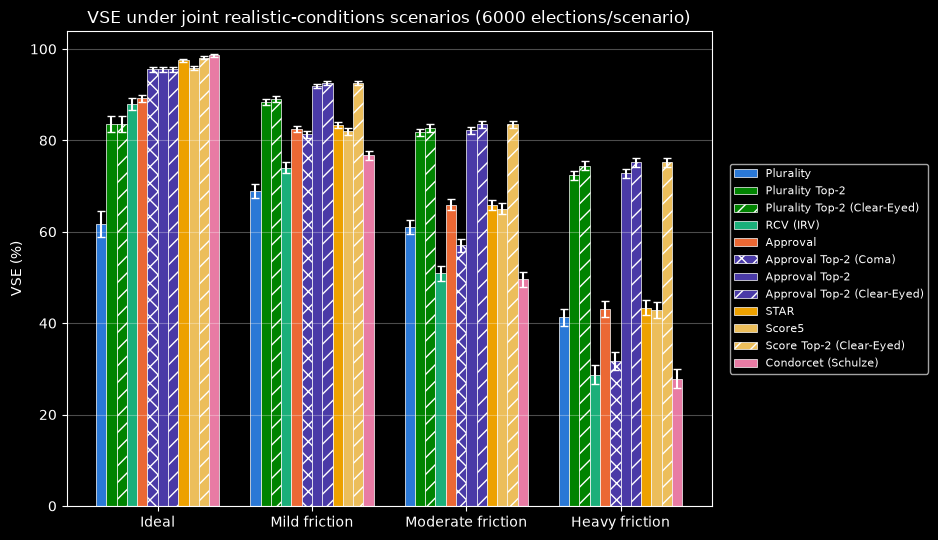

Epistemic noise (EPISTEMIC_RHO)

| Method | epistemic_rho=0.30 | epistemic_rho=0.50 | epistemic_rho=0.70 | epistemic_rho=0.80 | epistemic_rho=0.90 | epistemic_rho=1.00 |
| --- | --- | --- | --- | --- | --- | --- |
| Plurality | 73.7% (+/-2.5) | 76.6% (+/-2.9) | 73.5% (+/-3.7) | 65.7% (+/-4.5) | 61.0% (+/-4.6) | 61.6% (+/-2.8) |
| Plurality Top-2 | 76.2% (+/-2.1) | 85.9% (+/-1.7) | 89.2% (+/-1.6) | 89.0% (+/-1.9) | 87.0% (+/-2.1) | 83.6% (+/-1.7) |
| Plurality Top-2 (Clear-Eyed) | 88.0% (+/-1.5) | 90.7% (+/-1.5) | 91.7% (+/-1.4) | 90.0% (+/-1.9) | 86.9% (+/-2.2) | 83.6% (+/-1.7) |
| RCV (IRV) | 78.0% (+/-2.1) | 88.3% (+/-1.3) | 90.4% (+/-1.3) | 92.2% (+/-1.1) | 91.1% (+/-1.3) | 87.9% (+/-1.3) |
| Approval | 80.0% (+/-1.9) | 89.2% (+/-1.2) | 92.9% (+/-0.9) | 93.9% (+/-0.8) | 93.3% (+/-0.9) | 89.2% (+/-0.8) |
| Approval Top-2 | 79.1% (+/-2.1) | 89.6% (+/-1.2) | 93.6% (+/-0.9) | 95.1% (+/-0.7) | 95.9% (+/-0.7) | 95.6% (+/-0.5) |
| Approval Top-2 (Clear-Eyed) | 91.7% (+/-1.1) | 95.6% (+/-0.7) | 97.2% (+/-0.5) | 97.3% (+/-0.5) | 97.2% (+/-0.6) | 95.6% (+/-0.5) |
| STAR | 81.2% (+/-1.8) | 89.9% (+/-1.2) | 94.1% (+/-0.8) | 95.4% (+/-0.7) | 96.7% (+/-0.6) | 97.5% (+/-0.3) |
| Score5 | 81.4% (+/-1.7) | 90.3% (+/-1.1) | 93.6% (+/-0.9) | 94.9% (+/-0.7) | 96.3% (+/-0.6) | 95.9% (+/-0.4) |
| Score Top-2 (Clear-Eyed) | 92.7% (+/-1.0) | 95.9% (+/-0.8) | 97.4% (+/-0.6) | 97.6% (+/-0.5) | 97.8% (+/-0.5) | 98.0% (+/-0.3) |
| Condorcet (Schulze) | 79.7% (+/-1.9) | 89.6% (+/-1.2) | 93.8% (+/-0.8) | 95.4% (+/-0.7) | 97.0% (+/-0.5) | 98.6% (+/-0.3) |

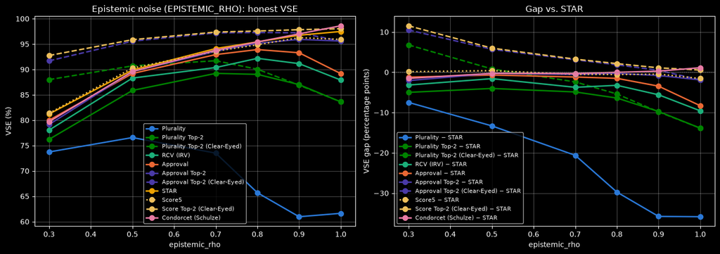

Unfamiliarity (AWARENESS_ALPHA)

| Method | awareness_alpha=0.30 | awareness_alpha=0.50 | awareness_alpha=0.70 | awareness_alpha=0.80 | awareness_alpha=0.90 | awareness_alpha=1.00 |
| --- | --- | --- | --- | --- | --- | --- |
| Plurality | 1.0% (+/-6.5) | 13.5% (+/-6.1) | 49.1% (+/-4.0) | 64.9% (+/-3.3) | 69.7% (+/-3.5) | 61.6% (+/-2.8) |
| Plurality Top-2 | 66.4% (+/-2.9) | 70.0% (+/-2.7) | 77.1% (+/-2.4) | 83.8% (+/-2.0) | 87.6% (+/-1.9) | 83.6% (+/-1.7) |
| RCV (IRV) | 1.0% (+/-6.5) | 6.4% (+/-6.5) | 44.0% (+/-4.1) | 56.0% (+/-3.6) | 76.4% (+/-2.7) | 87.9% (+/-1.3) |
| Approval | 1.0% (+/-6.5) | 17.4% (+/-5.8) | 55.7% (+/-3.2) | 69.7% (+/-2.6) | 82.9% (+/-1.5) | 89.2% (+/-0.8) |
| Approval Top-2 (Coma) | 1.0% (+/-6.5) | 6.7% (+/-6.5) | 47.2% (+/-3.7) | 62.5% (+/-3.0) | 83.4% (+/-1.7) | 95.6% (+/-0.5) |
| Approval Top-2 | 66.5% (+/-2.9) | 69.9% (+/-2.7) | 78.4% (+/-2.2) | 85.8% (+/-1.7) | 93.4% (+/-1.0) | 95.6% (+/-0.5) |
| STAR | 1.0% (+/-6.5) | 19.5% (+/-5.7) | 57.5% (+/-3.2) | 70.3% (+/-2.6) | 84.6% (+/-1.6) | 97.5% (+/-0.3) |
| Score5 | 1.0% (+/-6.5) | 17.2% (+/-5.8) | 55.3% (+/-3.2) | 67.9% (+/-2.6) | 82.0% (+/-1.6) | 95.9% (+/-0.4) |
| Score Top-2 (Clear-Eyed) | 66.6% (+/-2.9) | 69.8% (+/-2.8) | 78.1% (+/-2.2) | 85.1% (+/-1.7) | 93.1% (+/-1.0) | 98.0% (+/-0.3) |
| Condorcet (Schulze) | 1.0% (+/-6.5) | 6.4% (+/-6.5) | 43.5% (+/-4.1) | 58.0% (+/-3.5) | 81.7% (+/-2.0) | 98.6% (+/-0.3) |

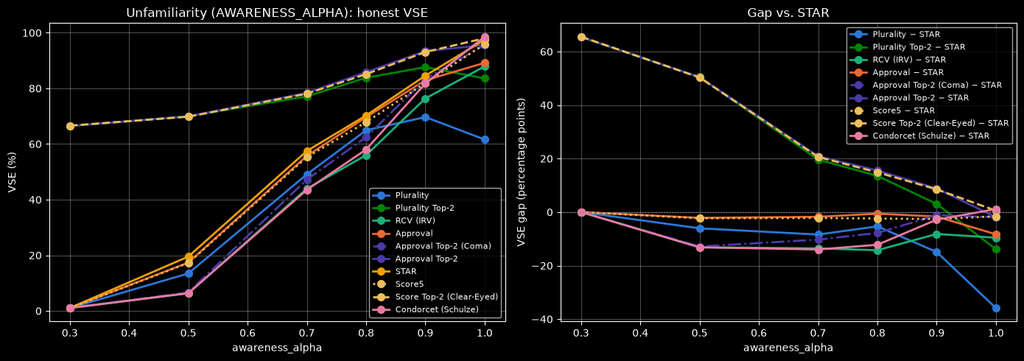

Ballot fatigue (FATIGUE_BETA)

| Method | fatigue_beta=0.30 | fatigue_beta=0.50 | fatigue_beta=0.70 | fatigue_beta=0.80 | fatigue_beta=0.90 | fatigue_beta=1.00 |
| --- | --- | --- | --- | --- | --- | --- |
| Plurality | 61.3% (+/-3.9) | 61.8% (+/-3.9) | 62.3% (+/-3.9) | 62.2% (+/-3.9) | 61.2% (+/-3.9) | 61.6% (+/-2.8) |
| Plurality Top-2 | 85.0% (+/-2.3) | 85.4% (+/-2.3) | 85.0% (+/-2.3) | 85.4% (+/-2.2) | 85.3% (+/-2.3) | 83.6% (+/-1.7) |
| RCV (IRV) | 65.2% (+/-3.7) | 66.3% (+/-3.6) | 76.7% (+/-3.0) | 82.5% (+/-2.3) | 86.8% (+/-2.0) | 87.9% (+/-1.3) |
| Approval | 68.3% (+/-3.5) | 74.1% (+/-3.0) | 85.9% (+/-2.1) | 90.5% (+/-1.6) | 92.6% (+/-1.2) | 89.2% (+/-0.8) |
| Approval Top-2 | 88.5% (+/-2.1) | 91.6% (+/-1.6) | 93.8% (+/-1.6) | 96.9% (+/-0.8) | 97.4% (+/-0.7) | 95.6% (+/-0.5) |
| STAR | 67.8% (+/-3.5) | 74.6% (+/-2.9) | 85.6% (+/-2.0) | 90.8% (+/-1.5) | 96.6% (+/-0.7) | 97.5% (+/-0.3) |
| Score5 | 66.9% (+/-3.6) | 75.0% (+/-2.9) | 84.7% (+/-2.1) | 90.1% (+/-1.6) | 96.2% (+/-0.7) | 95.9% (+/-0.4) |
| Score Top-2 (Clear-Eyed) | 87.9% (+/-2.0) | 92.0% (+/-1.6) | 94.4% (+/-1.3) | 96.5% (+/-0.9) | 98.2% (+/-0.6) | 98.0% (+/-0.3) |
| Condorcet (Schulze) | 63.8% (+/-3.8) | 68.4% (+/-3.4) | 80.2% (+/-2.5) | 86.8% (+/-2.0) | 94.7% (+/-1.1) | 98.6% (+/-0.3) |

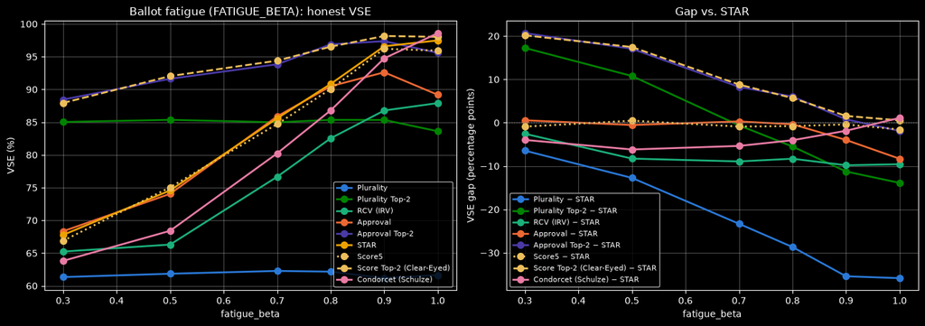

```python
replay("approval-star-gap-scenarios")
replay("star-vse-gap-significant")
replay("vse-joint")
replay("runoff-help-sweep")
```

### Findings: How much does a delayed runoff actually help?

| Method | Ideal | Mild friction | Moderate friction | Heavy friction |
| --- | --- | --- | --- | --- |
| STAR | 97.5% (+/-0.3) | 83.3% (+/-0.7) | 65.9% (+/-1.2) | 43.4% (+/-1.7) |
| Approval | 89.2% (+/-0.8) | 82.5% (+/-0.7) | 65.9% (+/-1.2) | 43.2% (+/-1.7) |
| Approval Top-2 (Coma) | 95.6% (+/-0.5) | 81.3% (+/-0.8) | 57.0% (+/-1.4) | 31.6% (+/-2.0) |
| Approval Top-2 | 95.6% (+/-0.5) | 91.9% (+/-0.5) | 82.2% (+/-0.8) | 72.8% (+/-1.0) |

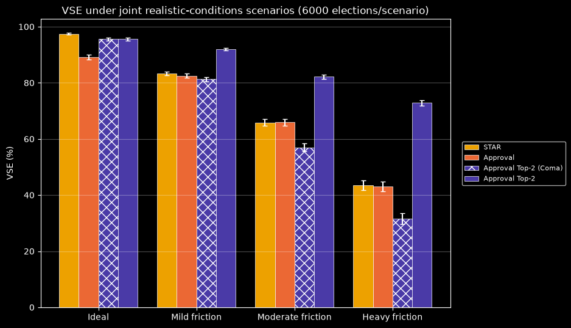

```python
replay("coma-vs-approval")
```

```python
replay("runoff-vs-baseline")
replay("coma-diagnostic")
replay("coma-vs-groggy")
```

Does the runoff help or hurt Approval?

Ideal

| Method | Approval VSE (%) | Method VSE (%) | Gap (pp) | 95% CI | Significant? |
| --- | --- | --- | --- | --- | --- |
| Approval Top-2 | 89.2 | 95.6 | +6.4 | [+5.7, +7.2] | Decisive (runoff better) |

Mild friction

| Method | Approval VSE (%) | Method VSE (%) | Gap (pp) | 95% CI | Significant? |
| --- | --- | --- | --- | --- | --- |
| Approval Top-2 (Clear-Eyed) | 82.5 | 92.6 | +10.1 | [+9.4, +10.7] | Decisive (runoff better) |
| Approval Top-2 | 82.5 | 91.9 | +9.4 | [+8.8, +10.0] | Decisive (runoff better) |
| Approval Top-2 (Coma) | 82.5 | 81.3 | -1.2 | [-1.8, -0.7] | Ambiguous edge (no runoff better) |

Moderate friction

| Method | Approval VSE (%) | Method VSE (%) | Gap (pp) | 95% CI | Significant? |
| --- | --- | --- | --- | --- | --- |
| Approval Top-2 (Clear-Eyed) | 65.9 | 83.5 | +17.5 | [+16.6, +18.5] | Decisive (runoff better) |
| Approval Top-2 | 65.9 | 82.2 | +16.3 | [+15.3, +17.2] | Decisive (runoff better) |
| Approval Top-2 (Coma) | 65.9 | 57.0 | -8.9 | [-9.9, -8.0] | Decisive (no runoff better) |

Heavy friction

| Method | Approval VSE (%) | Method VSE (%) | Gap (pp) | 95% CI | Significant? |
| --- | --- | --- | --- | --- | --- |
| Approval Top-2 (Clear-Eyed) | 43.2 | 75.2 | +32.1 | [+30.6, +33.6] | Decisive (runoff better) |
| Approval Top-2 | 43.2 | 72.8 | +29.7 | [+28.2, +31.2] | Decisive (runoff better) |
| Approval Top-2 (Coma) | 43.2 | 31.6 | -11.5 | [-12.8, -10.2] | Decisive (no runoff better) |

Does the runoff help or hurt Plurality?

Ideal

| Method | Plurality VSE (%) | Method VSE (%) | Gap (pp) | 95% CI | Significant? |
| --- | --- | --- | --- | --- | --- |
| Plurality Top-2 | 61.6 | 83.6 | +22.0 | [+19.7, +24.3] | Decisive (runoff better) |

Mild friction

| Method | Plurality VSE (%) | Method VSE (%) | Gap (pp) | 95% CI | Significant? |
| --- | --- | --- | --- | --- | --- |
| Plurality Top-2 (Clear-Eyed) | 68.9 | 89.1 | +20.2 | [+18.8, +21.6] | Decisive (runoff better) |
| Plurality Top-2 | 68.9 | 88.4 | +19.5 | [+18.1, +20.9] | Decisive (runoff better) |

Moderate friction

| Method | Plurality VSE (%) | Method VSE (%) | Gap (pp) | 95% CI | Significant? |
| --- | --- | --- | --- | --- | --- |
| Plurality Top-2 (Clear-Eyed) | 61.0 | 82.7 | +21.6 | [+20.4, +22.9] | Decisive (runoff better) |
| Plurality Top-2 | 61.0 | 81.7 | +20.7 | [+19.5, +22.0] | Decisive (runoff better) |

Heavy friction

| Method | Plurality VSE (%) | Method VSE (%) | Gap (pp) | 95% CI | Significant? |
| --- | --- | --- | --- | --- | --- |
| Plurality Top-2 (Clear-Eyed) | 41.2 | 74.5 | +33.2 | [+31.6, +34.8] | Decisive (runoff better) |
| Plurality Top-2 | 41.2 | 72.3 | +31.1 | [+29.5, +32.7] | Decisive (runoff better) |

Coma AT2: why voters end up voting against their own pairwise interest

| Scenario | Aligned | Awareness-attributable | Noise-unfixable (even if Groggy) |
| --- | --- | --- | --- |
| Ideal | 100.0% | 0.0% | 0.0% |
| Mild friction | 71.5% | 11.0% | 17.5% |
| Moderate friction | 66.3% | 14.4% | 19.3% |
| Heavy friction | 63.2% | 15.9% | 20.8% |

Coma AT2: detailed breakdown

| Scenario | Wrong (awareness-fixable) | Wrong (noise-unfixable) | Abstained (awareness-fixable) | Abstained (noise-unfixable) |
| --- | --- | --- | --- | --- |
| Ideal | 0.0% | 0.0% | 0.0% | 0.0% |
| Mild friction | 9.9% | 17.2% | 1.1% | 0.3% |
| Moderate friction | 13.0% | 18.8% | 1.4% | 0.5% |
| Heavy friction | 15.2% | 20.5% | 0.7% | 0.3% |

Coma vs Groggy: election-level aggregate-sign accuracy (does the runoff decision match the true preference?)

| Scenario | Coma correct | Groggy correct | Both correct | Coma-only correct | Groggy-only correct | Both wrong |
| --- | --- | --- | --- | --- | --- | --- |
| Ideal | 100.0% | 100.0% | 100.0% | 0.0% | 0.0% | 0.0% |
| Mild friction | 61.3% | 85.0% | 54.0% | 7.3% | 31.0% | 7.7% |
| Moderate friction | 52.2% | 86.8% | 45.2% | 7.0% | 41.6% | 6.2% |
| Heavy friction | 46.7% | 86.2% | 39.5% | 7.2% | 46.7% | 6.6% |

An election's outcome depends on the aggregate runoff decision, not per-voter accuracy. That is the metric driving the VSE gap. "Groggy-only correct" elections are ones where fixing awareness alone flips the aggregate decision from wrong to right, even though the per-voter `awareness_attributable` rate above is modest.

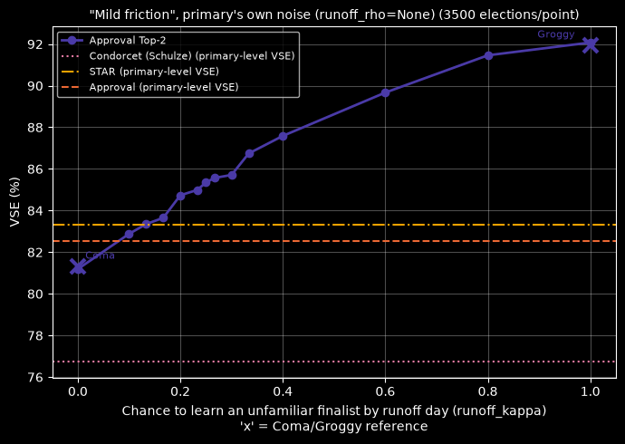

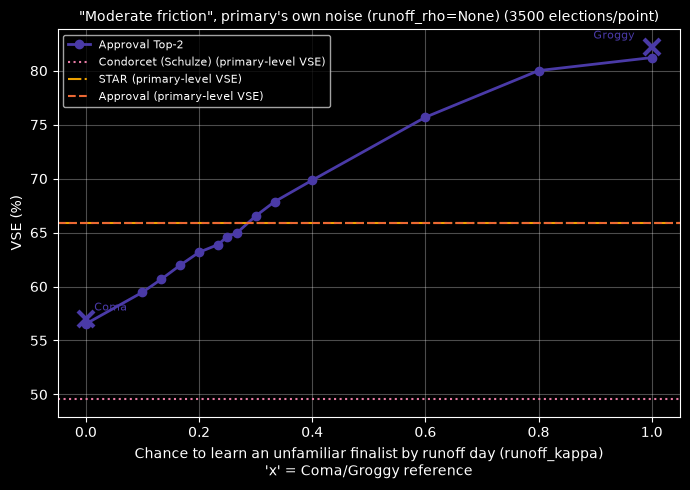

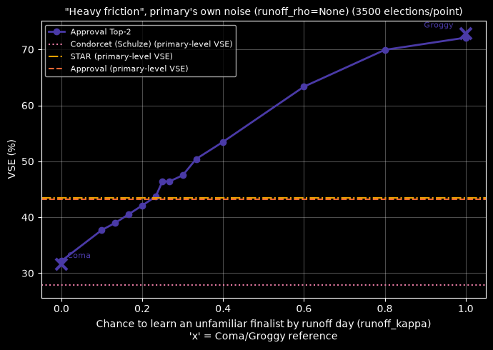

kappa threshold for AT2 VSE > STAR VSE (95% confidence, paired)

Mild friction

| kappa | AT2 VSE (%) | STAR VSE (%) | Gap (pp, paired) | 95% CI (paired, pp) | AT2 > STAR? |
| --- | --- | --- | --- | --- | --- |
| 0.00 | 81.2 | 83.5 (+/-0.9) | -2.3 | [-3.0, -1.6] | Decisive (STAR better) |
| 0.10 | 82.9 | 83.5 (+/-0.9) | -0.6 | [-1.3, +0.1] | Inconclusive |
| 0.13 | 83.4 | 83.5 (+/-0.9) | -0.1 | [-0.8, +0.5] | Indistinguishable |
| 0.17 | 83.6 | 83.5 (+/-0.9) | +0.2 | [-0.5, +0.8] | Indistinguishable |
| 0.20 | 84.7 | 83.5 (+/-0.9) | +1.2 | [+0.6, +1.9] | Ambiguous edge (Approval Top-2 better) |
| 0.23 | 85.0 | 83.5 (+/-0.9) | +1.5 | [+0.8, +2.2] | Ambiguous edge (Approval Top-2 better) |
| 0.25 | 85.4 | 83.5 (+/-0.9) | +1.9 | [+1.2, +2.5] | Decisive (Approval Top-2 better) |
| 0.27 | 85.6 | 83.5 (+/-0.9) | +2.1 | [+1.4, +2.8] | Decisive (Approval Top-2 better) |
| 0.30 | 85.7 | 83.5 (+/-0.9) | +2.2 | [+1.5, +2.9] | Decisive (Approval Top-2 better) |
| 0.33 | 86.7 | 83.5 (+/-0.9) | +3.2 | [+2.6, +3.9] | Decisive (Approval Top-2 better) |
| 0.40 | 87.6 | 83.5 (+/-0.9) | +4.1 | [+3.4, +4.8] | Decisive (Approval Top-2 better) |
| 0.60 | 89.7 | 83.5 (+/-0.9) | +6.2 | [+5.4, +6.9] | Decisive (Approval Top-2 better) |
| 0.80 | 91.5 | 83.5 (+/-0.9) | +8.0 | [+7.2, +8.8] | Decisive (Approval Top-2 better) |
| 1.00 | 92.1 | 83.5 (+/-0.9) | +8.6 | [+7.7, +9.4] | Decisive (Approval Top-2 better) |

**-> First kappa where AT2 is significantly better than STAR in Mild friction (95% CI gap > 0): `kappa ~ 0.20`**

Moderate friction

| kappa | AT2 VSE (%) | STAR VSE (%) | Gap (pp, paired) | 95% CI (paired, pp) | AT2 > STAR? |
| --- | --- | --- | --- | --- | --- |
| 0.00 | 56.5 | 64.5 (+/-1.6) | -8.0 | [-9.1, -6.8] | Decisive (STAR better) |
| 0.10 | 59.5 | 64.5 (+/-1.6) | -5.0 | [-6.1, -3.9] | Decisive (STAR better) |
| 0.13 | 60.7 | 64.5 (+/-1.6) | -3.8 | [-4.9, -2.8] | Decisive (STAR better) |
| 0.17 | 62.0 | 64.5 (+/-1.6) | -2.5 | [-3.6, -1.5] | Decisive (STAR better) |
| 0.20 | 63.2 | 64.5 (+/-1.6) | -1.3 | [-2.4, -0.3] | Ambiguous edge (STAR better) |
| 0.23 | 63.9 | 64.5 (+/-1.6) | -0.6 | [-1.6, +0.4] | Inconclusive |
| 0.25 | 64.6 | 64.5 (+/-1.6) | +0.1 | [-0.9, +1.1] | Inconclusive |
| 0.27 | 65.0 | 64.5 (+/-1.6) | +0.5 | [-0.6, +1.5] | Inconclusive |
| 0.30 | 66.5 | 64.5 (+/-1.6) | +2.0 | [+0.9, +3.1] | Ambiguous edge (Approval Top-2 better) |
| 0.33 | 67.9 | 64.5 (+/-1.6) | +3.3 | [+2.3, +4.4] | Decisive (Approval Top-2 better) |
| 0.40 | 69.9 | 64.5 (+/-1.6) | +5.3 | [+4.2, +6.4] | Decisive (Approval Top-2 better) |
| 0.60 | 75.7 | 64.5 (+/-1.6) | +11.2 | [+9.9, +12.4] | Decisive (Approval Top-2 better) |
| 0.80 | 80.0 | 64.5 (+/-1.6) | +15.5 | [+14.2, +16.8] | Decisive (Approval Top-2 better) |
| 1.00 | 81.2 | 64.5 (+/-1.6) | +16.7 | [+15.3, +18.1] | Decisive (Approval Top-2 better) |

**-> First kappa where AT2 is significantly better than STAR in Moderate friction (95% CI gap > 0): `kappa ~ 0.30`**

Heavy friction

| kappa | AT2 VSE (%) | STAR VSE (%) | Gap (pp, paired) | 95% CI (paired, pp) | AT2 > STAR? |
| --- | --- | --- | --- | --- | --- |
| 0.00 | 32.2 | 44.1 (+/-2.2) | -11.9 | [-13.6, -10.3] | Decisive (STAR better) |
| 0.10 | 37.7 | 44.1 (+/-2.2) | -6.4 | [-7.8, -5.0] | Decisive (STAR better) |
| 0.13 | 39.0 | 44.1 (+/-2.2) | -5.1 | [-6.5, -3.8] | Decisive (STAR better) |
| 0.17 | 40.5 | 44.1 (+/-2.2) | -3.6 | [-5.0, -2.2] | Decisive (STAR better) |
| 0.20 | 42.1 | 44.1 (+/-2.2) | -2.0 | [-3.4, -0.7] | Ambiguous edge (STAR better) |
| 0.23 | 43.7 | 44.1 (+/-2.2) | -0.4 | [-1.8, +0.9] | Inconclusive |
| 0.25 | 46.4 | 44.1 (+/-2.2) | +2.3 | [+1.0, +3.6] | Decisive (Approval Top-2 better) |
| 0.27 | 46.4 | 44.1 (+/-2.2) | +2.3 | [+0.9, +3.6] | Ambiguous edge (Approval Top-2 better) |
| 0.30 | 47.5 | 44.1 (+/-2.2) | +3.4 | [+2.0, +4.7] | Decisive (Approval Top-2 better) |
| 0.33 | 50.4 | 44.1 (+/-2.2) | +6.3 | [+4.9, +7.7] | Decisive (Approval Top-2 better) |
| 0.40 | 53.5 | 44.1 (+/-2.2) | +9.4 | [+7.9, +10.8] | Decisive (Approval Top-2 better) |
| 0.60 | 63.3 | 44.1 (+/-2.2) | +19.2 | [+17.5, +20.9] | Decisive (Approval Top-2 better) |
| 0.80 | 69.9 | 44.1 (+/-2.2) | +25.8 | [+23.9, +27.7] | Decisive (Approval Top-2 better) |
| 1.00 | 72.1 | 44.1 (+/-2.2) | +28.0 | [+26.1, +29.9] | Decisive (Approval Top-2 better) |

**-> First kappa where AT2 is significantly better than STAR in Heavy friction (95% CI gap > 0): `kappa ~ 0.25`**

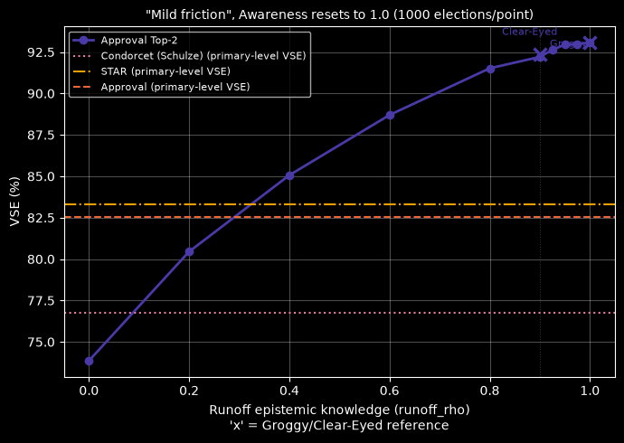

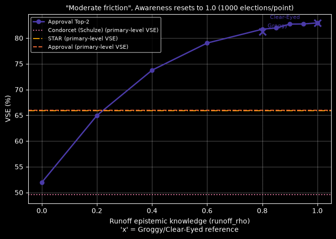

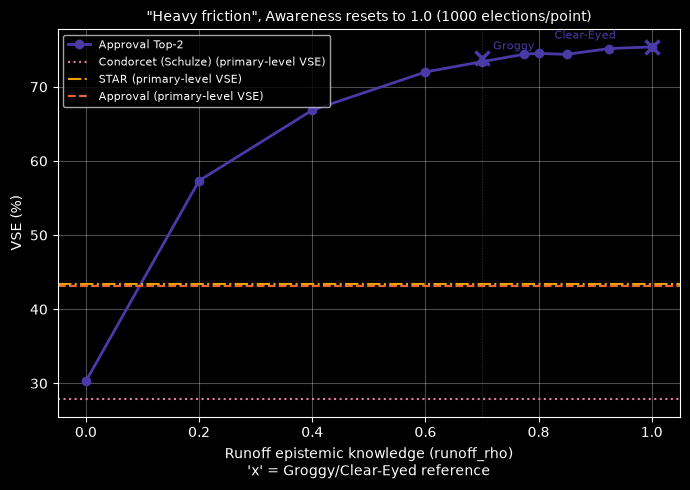

```python
replay("runoff-learn-sweep")
replay("p-learn-ci-table")
replay("runoff-t-sweep")
```

### Findings: STAR Runoff Betrayal

```python
replay("star-betrayal-tables")
replay("scoret2-vs-at2")
```

Runoff betrayal rate by joint-friction scenario

| Scenario | Betrayal rate | Voter corruption rate | VSE (STAR's actual runoff) | VSE (honest/delayed-perfect runoff) | VSE (AT2 Clear-Eyed runoff) |
| --- | --- | --- | --- | --- | --- |
| Ideal | 0.0% | 0.00% | 97.5% | 97.5% (+0.0 pts over actual) | 95.6% (-1.9 pts over STAR) |
| Mild friction | 34.2% | 35.46% | 83.3% | 91.2% (+7.8 pts over actual) | 92.6% (+9.3 pts over STAR) |
| Moderate friction | 37.5% | 45.09% | 65.9% | 81.0% (+15.2 pts over actual) | 83.5% (+17.6 pts over STAR) |
| Heavy friction | 44.8% | 49.09% | 43.4% | 71.4% (+28.0 pts over actual) | 75.2% (+31.8 pts over STAR) |

Score Top-2 (Clear-Eyed) vs Approval Top-2 (Clear-Eyed): paired VSE gap by joint-friction scenario

| Scenario | Score Top-2 VSE (%) | AT2 VSE (%) | Gap vs AT2 (pp) | 95% CI (paired, pp) | Significant? |
| --- | --- | --- | --- | --- | --- |
| Ideal | 98.0 | 95.6 | +2.4 | [+2.0, +2.9] | Decisive (Score Top-2 better) |
| Mild friction | 92.6 | 92.6 | +0.0 | [-0.2, +0.3] | Indistinguishable |
| Moderate friction | 83.5 | 83.5 | +0.1 | [-0.3, +0.4] | Indistinguishable |
| Heavy friction | 75.2 | 75.2 | -0.1 | [-0.4, +0.2] | Indistinguishable |

### Appendix: The Plurality Bump

| Method | Ideal | Mild friction | Moderate friction | Heavy friction |
| --- | --- | --- | --- | --- |
| Plurality | 61.6% (+/-2.8) | 68.9% (+/-1.5) | 61.0% (+/-1.5) | 41.2% (+/-1.8) |
| Plurality Top-2 | 83.6% (+/-1.7) | 88.4% (+/-0.8) | 81.7% (+/-0.8) | 72.3% (+/-1.0) |
| Plurality Top-2 (Clear-Eyed) | 83.6% (+/-1.7) | 89.1% (+/-0.7) | 82.7% (+/-0.8) | 74.5% (+/-1.0) |
| Approval Top-2 (Clear-Eyed) | 95.6% (+/-0.5) | 92.6% (+/-0.5) | 83.5% (+/-0.8) | 75.2% (+/-1.0) |

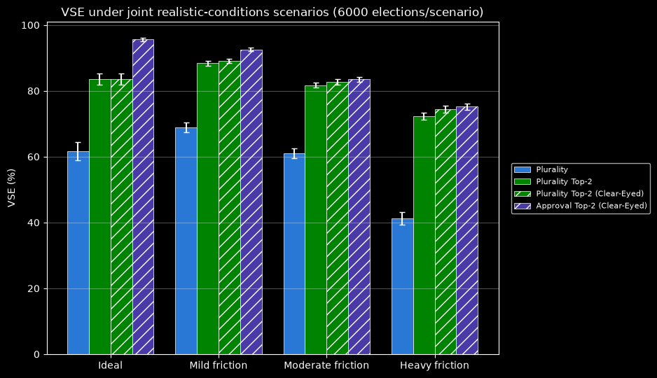

```python
replay("plurality-bump")
```

### Appendix: Approval vs Plurality

| Method | Ideal | Mild friction | Moderate friction | Heavy friction |
| --- | --- | --- | --- | --- |
| Plurality | 61.6% (+/-2.8) | 68.9% (+/-1.5) | 61.0% (+/-1.5) | 41.2% (+/-1.8) |
| Approval | 89.2% (+/-0.8) | 82.5% (+/-0.7) | 65.9% (+/-1.2) | 43.2% (+/-1.7) |

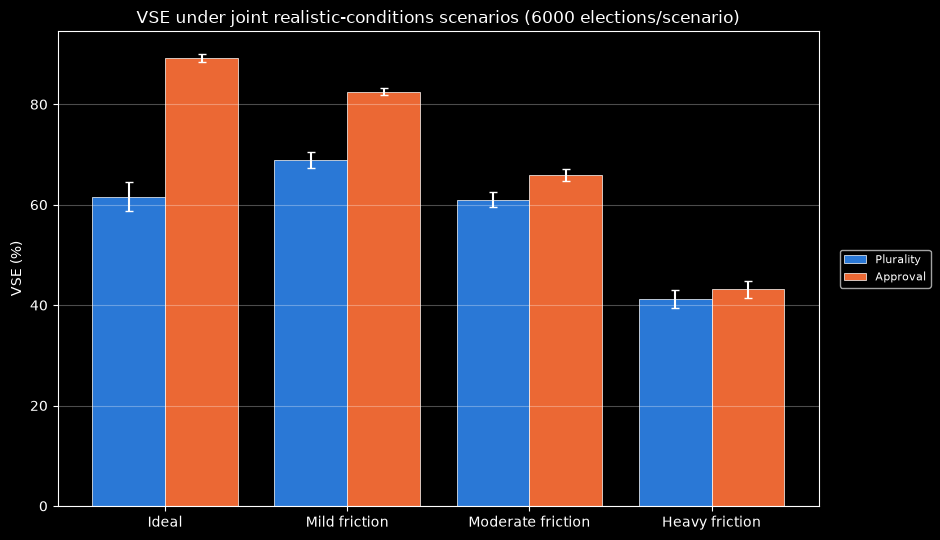

Approval vs Plurality: paired VSE gap by joint-friction scenario

| Scenario | Approval VSE (%) | Plurality VSE (%) | Gap vs Plurality (pp) | 95% CI (paired, pp) | Significant? |
| --- | --- | --- | --- | --- | --- |
| Ideal | 89.2 | 61.6 | +27.5 | [+24.5, +30.6] | Decisive (Approval better) |
| Mild friction | 82.5 | 68.9 | +13.6 | [+12.1, +15.1] | Decisive (Approval better) |
| Moderate friction | 65.9 | 61.0 | +4.9 | [+3.9, +6.0] | Decisive (Approval better) |
| Heavy friction | 43.2 | 41.2 | +1.9 | [+1.1, +2.7] | Decisive (Approval better) |

Approval Top-2 vs Plurality Top-2: paired VSE gap by joint-friction scenario

| Scenario | AT2 VSE (%) | PT2 VSE (%) | Gap vs PT2 (pp) | 95% CI (paired, pp) | Significant? |
| --- | --- | --- | --- | --- | --- |
| Ideal | 95.6 | 83.6 | +12.0 | [+10.1, +13.8] | Decisive (AT2 better) |
| Mild friction | 91.9 | 88.4 | +3.6 | [+2.8, +4.3] | Decisive (AT2 better) |
| Moderate friction | 82.2 | 81.7 | +0.5 | [-0.1, +1.0] | Inconclusive |
| Heavy friction | 72.8 | 72.3 | +0.5 | [-0.1, +1.1] | Inconclusive |

Approval Top-2 (Clear-Eyed) vs Plurality Top-2 (Clear-Eyed): paired VSE gap by joint-friction scenario

| Scenario | AT2 VSE (%) | PT2 VSE (%) | Gap vs PT2 (pp) | 95% CI (paired, pp) | Significant? |
| --- | --- | --- | --- | --- | --- |
| Ideal | 95.6 | 83.6 | +12.0 | [+10.1, +13.8] | Decisive (AT2 better) |
| Mild friction | 92.6 | 89.1 | +3.5 | [+2.8, +4.2] | Decisive (AT2 better) |
| Moderate friction | 83.5 | 82.7 | +0.8 | [+0.2, +1.4] | Ambiguous edge (AT2 better) |
| Heavy friction | 75.2 | 74.5 | +0.8 | [+0.2, +1.4] | Ambiguous edge (AT2 better) |

Ideal: VSE by candidate count (NCAND)

| ncand | Approval Top-2 VSE (%) | Plurality Top-2 VSE (%) | Gap (pp) |
| --- | --- | --- | --- |
| 3 | 96.7% (+/-1.1) | 90.7% (+/-1.8) | +6.0 |
| 5 | 96.4% (+/-0.6) | 83.9% (+/-2.2) | +12.5 |
| 6 | 96.1% (+/-0.6) | 84.8% (+/-2.1) | +11.3 |
| 8 | 94.1% (+/-0.8) | 80.8% (+/-2.4) | +13.3 |
| 10 | 92.6% (+/-0.9) | 79.2% (+/-2.3) | +13.4 |
| 15 | 89.8% (+/-1.0) | 74.9% (+/-2.3) | +14.9 |

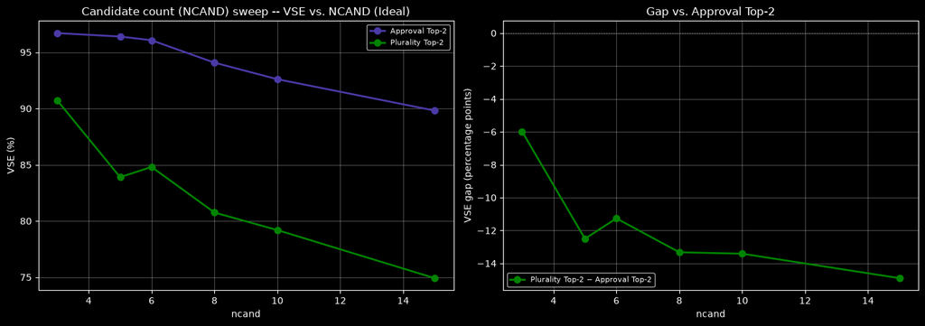

Mild friction: VSE by candidate count (NCAND)

| ncand | Approval Top-2 VSE (%) | Plurality Top-2 VSE (%) | Gap (pp) |
| --- | --- | --- | --- |
| 3 | 95.1% (+/-1.3) | 91.6% (+/-1.7) | +3.5 |
| 5 | 93.6% (+/-0.9) | 88.9% (+/-1.7) | +4.8 |
| 6 | 91.8% (+/-1.0) | 88.0% (+/-1.5) | +3.9 |
| 8 | 88.7% (+/-1.1) | 85.3% (+/-1.7) | +3.4 |
| 10 | 87.5% (+/-1.0) | 83.6% (+/-1.9) | +3.9 |
| 15 | 84.4% (+/-1.2) | 80.1% (+/-1.9) | +4.4 |

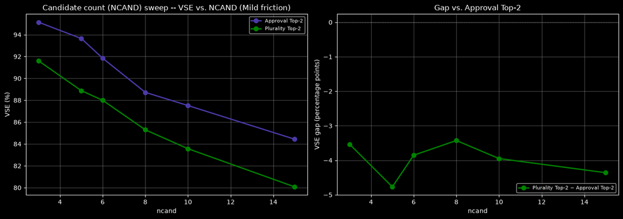

Moderate friction: VSE by candidate count (NCAND)

| ncand | Approval Top-2 VSE (%) | Plurality Top-2 VSE (%) | Gap (pp) |
| --- | --- | --- | --- |
| 3 | 92.2% (+/-1.5) | 90.3% (+/-1.8) | +1.9 |
| 5 | 84.3% (+/-1.7) | 84.6% (+/-1.7) | -0.3 |
| 6 | 82.1% (+/-1.8) | 82.7% (+/-1.7) | -0.7 |
| 8 | 77.8% (+/-2.0) | 78.3% (+/-1.9) | -0.5 |
| 10 | 77.5% (+/-1.8) | 77.4% (+/-1.8) | +0.1 |
| 15 | 76.2% (+/-1.7) | 75.4% (+/-1.8) | +0.8 |

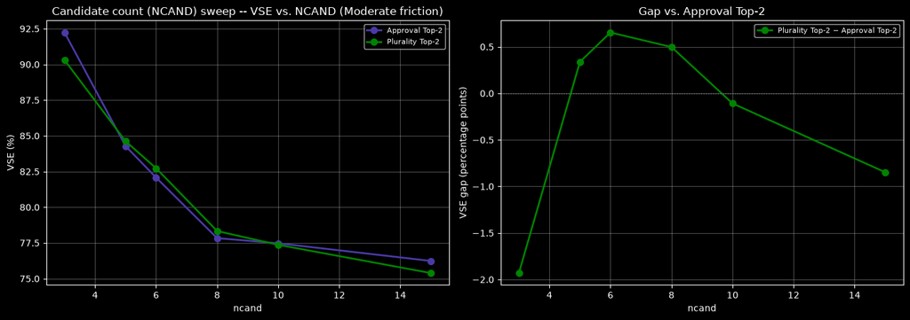

Heavy friction: VSE by candidate count (NCAND)

| ncand | Approval Top-2 VSE (%) | Plurality Top-2 VSE (%) | Gap (pp) |
| --- | --- | --- | --- |
| 3 | 83.9% (+/-2.3) | 83.0% (+/-2.4) | +0.9 |
| 5 | 74.2% (+/-2.4) | 73.1% (+/-2.4) | +1.1 |
| 6 | 72.9% (+/-2.3) | 73.1% (+/-2.2) | -0.2 |
| 8 | 69.5% (+/-2.3) | 69.0% (+/-2.4) | +0.5 |
| 10 | 69.8% (+/-2.1) | 69.5% (+/-2.1) | +0.3 |
| 15 | 66.9% (+/-2.2) | 66.9% (+/-2.3) | +0.0 |

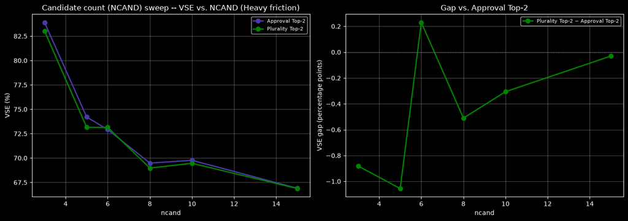

Ideal

| NCAND | AT2 VSE | PT2 VSE | Gap (AT2 - PT2, pp) | 95% CI (paired, pp) | Significant? |
| --- | --- | --- | --- | --- | --- |
| 3 | 96.71% | 90.73% | +5.98 | [+4.48, +7.47] | Decisive (Approval Top-2 better) |
| 5 | 96.40% | 83.90% | +12.50 | [+10.22, +14.78] | Decisive (Approval Top-2 better) |
| 6 | 96.07% | 84.81% | +11.26 | [+9.10, +13.43] | Decisive (Approval Top-2 better) |
| 8 | 94.08% | 80.75% | +13.32 | [+10.76, +15.89] | Decisive (Approval Top-2 better) |
| 10 | 92.61% | 79.19% | +13.41 | [+10.95, +15.87] | Decisive (Approval Top-2 better) |
| 15 | 89.82% | 74.92% | +14.90 | [+12.39, +17.41] | Decisive (Approval Top-2 better) |

Mild friction

| NCAND | AT2 VSE | PT2 VSE | Gap (AT2 - PT2, pp) | 95% CI (paired, pp) | Significant? |
| --- | --- | --- | --- | --- | --- |
| 3 | 95.14% | 91.60% | +3.54 | [+2.14, +4.93] | Decisive (Approval Top-2 better) |
| 5 | 93.65% | 88.88% | +4.77 | [+3.14, +6.39] | Decisive (Approval Top-2 better) |
| 6 | 91.85% | 88.00% | +3.85 | [+2.37, +5.34] | Decisive (Approval Top-2 better) |
| 8 | 88.72% | 85.30% | +3.43 | [+1.84, +5.02] | Decisive (Approval Top-2 better) |
| 10 | 87.52% | 83.57% | +3.95 | [+2.08, +5.82] | Decisive (Approval Top-2 better) |
| 15 | 84.44% | 80.08% | +4.36 | [+2.54, +6.18] | Decisive (Approval Top-2 better) |

Moderate friction

| NCAND | AT2 VSE | PT2 VSE | Gap (AT2 - PT2, pp) | 95% CI (paired, pp) | Significant? |
| --- | --- | --- | --- | --- | --- |
| 3 | 92.23% | 90.30% | +1.93 | [+0.48, +3.38] | Ambiguous edge (Approval Top-2 better) |
| 5 | 84.28% | 84.62% | -0.34 | [-1.51, +0.84] | Inconclusive |
| 6 | 82.08% | 82.73% | -0.65 | [-1.85, +0.55] | Inconclusive |
| 8 | 77.84% | 78.33% | -0.50 | [-1.83, +0.83] | Inconclusive |
| 10 | 77.47% | 77.37% | +0.11 | [-1.28, +1.49] | Inconclusive |
| 15 | 76.24% | 75.39% | +0.85 | [-0.21, +1.91] | Inconclusive |

Heavy friction

| NCAND | AT2 VSE | PT2 VSE | Gap (AT2 - PT2, pp) | 95% CI (paired, pp) | Significant? |
| --- | --- | --- | --- | --- | --- |
| 3 | 83.90% | 83.02% | +0.88 | [-0.22, +1.98] | Inconclusive |
| 5 | 74.20% | 73.15% | +1.06 | [-0.03, +2.14] | Inconclusive |
| 6 | 72.91% | 73.14% | -0.23 | [-1.47, +1.01] | Inconclusive |
| 8 | 69.48% | 68.97% | +0.51 | [-0.42, +1.44] | Inconclusive |
| 10 | 69.77% | 69.46% | +0.31 | [-0.80, +1.41] | Inconclusive |
| 15 | 66.90% | 66.87% | +0.03 | [-0.70, +0.76] | Indistinguishable |

```python
replay("plurality-vs-approval")
replay("plurality-approval-ci")
replay("at2-pt2-ci")
replay("at2-pt2-candidate-sweep")
replay("at2-pt2-candidate-ci")
```

### Appendix: SCORE vs STAR

STAR vs. Score5 by `epistemic_rho`

| Method | epistemic_rho=0.30 | epistemic_rho=0.50 | epistemic_rho=0.70 | epistemic_rho=0.80 | epistemic_rho=0.90 | epistemic_rho=1.00 |
| --- | --- | --- | --- | --- | --- | --- |
| Score5 | 81.4% (+/-1.7) | 90.3% (+/-1.1) | 93.6% (+/-0.9) | 94.9% (+/-0.7) | 96.3% (+/-0.6) | 95.9% (+/-0.4) |
| STAR | 81.2% (+/-1.8) | 89.9% (+/-1.2) | 94.1% (+/-0.8) | 95.4% (+/-0.7) | 96.7% (+/-0.6) | 97.5% (+/-0.3) |

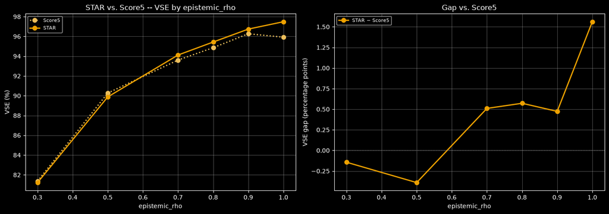

STAR vs. Score5 by `awareness_alpha`

| Method | awareness_alpha=0.30 | awareness_alpha=0.50 | awareness_alpha=0.70 | awareness_alpha=0.80 | awareness_alpha=0.90 | awareness_alpha=1.00 |
| --- | --- | --- | --- | --- | --- | --- |
| Score5 | 1.0% (+/-6.5) | 17.2% (+/-5.8) | 55.3% (+/-3.2) | 67.9% (+/-2.6) | 82.0% (+/-1.6) | 95.9% (+/-0.4) |
| STAR | 1.0% (+/-6.5) | 19.5% (+/-5.7) | 57.5% (+/-3.2) | 70.3% (+/-2.6) | 84.6% (+/-1.6) | 97.5% (+/-0.3) |

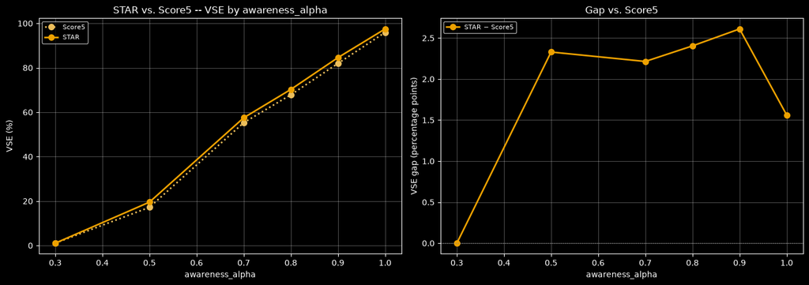

STAR vs. Score5 by `fatigue_beta`

| Method | fatigue_beta=0.30 | fatigue_beta=0.50 | fatigue_beta=0.70 | fatigue_beta=0.80 | fatigue_beta=0.90 | fatigue_beta=1.00 |
| --- | --- | --- | --- | --- | --- | --- |
| Score5 | 66.9% (+/-3.6) | 75.0% (+/-2.9) | 84.7% (+/-2.1) | 90.1% (+/-1.6) | 96.2% (+/-0.7) | 95.9% (+/-0.4) |
| STAR | 67.8% (+/-3.5) | 74.6% (+/-2.9) | 85.6% (+/-2.0) | 90.8% (+/-1.5) | 96.6% (+/-0.7) | 97.5% (+/-0.3) |

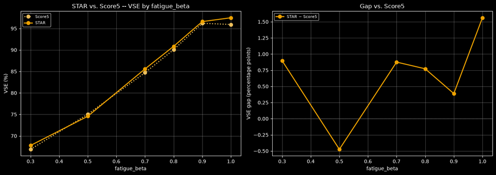

| Method | Ideal | Mild friction | Moderate friction | Heavy friction |
| --- | --- | --- | --- | --- |
| Score5 | 95.9% (+/-0.4) | 82.0% (+/-0.7) | 65.0% (+/-1.2) | 42.9% (+/-1.7) |
| STAR | 97.5% (+/-0.3) | 83.3% (+/-0.7) | 65.9% (+/-1.2) | 43.4% (+/-1.7) |

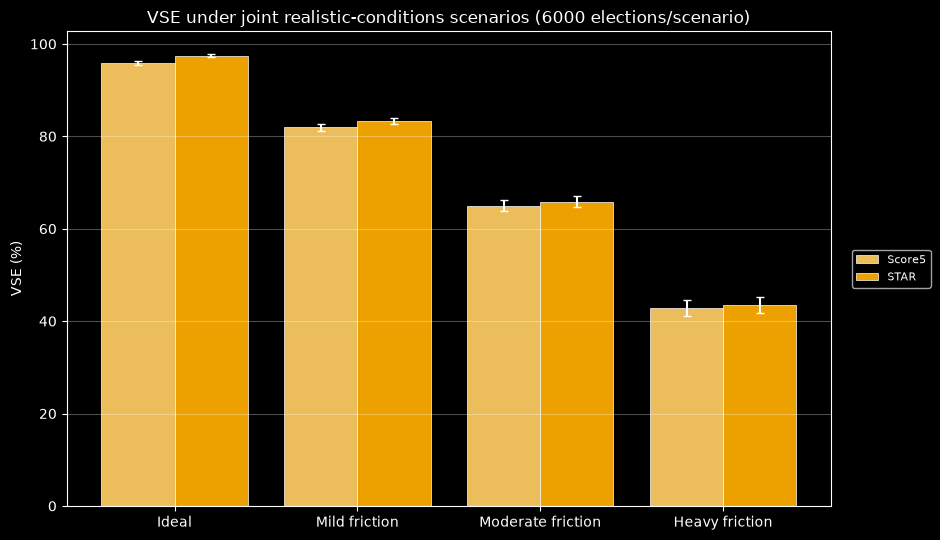

Score5 vs STAR: paired VSE gap by joint-friction scenario

| Scenario | Score VSE (%) | STAR VSE (%) | Gap vs STAR (pp) | 95% CI (paired, pp) | Significant? |
| --- | --- | --- | --- | --- | --- |
| Ideal | 95.9 | 97.5 | -1.6 | [-1.9, -1.2] | Decisive (STAR better) |
| Mild friction | 82.0 | 83.3 | -1.3 | [-1.7, -0.9] | Ambiguous edge (STAR better) |
| Moderate friction | 65.0 | 65.9 | -0.9 | [-1.3, -0.4] | Ambiguous edge (STAR better) |
| Heavy friction | 42.9 | 43.4 | -0.6 | [-1.0, -0.1] | Narrow edge (STAR better) |

```python
replay("score-vs-star")
replay("score-vs-star-scenarios")
```

### Appendix: 99% Confidence Check

```python
replay("not-sig-at-99-part1")
```

2 result(s) lose significance at 99% confidence

- **kappa threshold: Moderate friction / kappa=0.20**: at 95% confidence, **STAR** appeared better than **Approval Top-2** by 1.3pp (Ambiguous edge, 95% CI [-2.4, -0.3]). At 99% confidence that edge is no longer significant (Inconclusive, 99% CI [-2.7, +0.1], which contains 0).

- **Score5 vs STAR / Heavy friction**: at 95% confidence, **STAR** appeared better than **Score** by 0.6pp (Narrow edge, 95% CI [-1.0, -0.1]). At 99% confidence that edge is no longer significant (Inconclusive, 99% CI [-1.1, +0.0], which contains 0).

```python
replay("still-sig-at-99-part1")
```

Spotlight: does each headline claim hold up at 99% confidence?

Approval-flavor gaps vs STAR: Ideal

| Row | Gap (pp) | 95% verdict | 99% verdict |
| --- | --- | --- | --- |
| Plurality Top-2 | -13.9 | Decisive (STAR better) | Decisive (STAR better) |
| Approval Top-2 | -1.9 | Decisive (STAR better) | Decisive (STAR better) |

Approval-flavor gaps vs STAR: Mild friction

| Row | Gap (pp) | 95% verdict | 99% verdict |
| --- | --- | --- | --- |
| Plurality Top-2 | +5.1 | Decisive (Plurality Top-2 better) | Decisive (Plurality Top-2 better) |
| Approval Top-2 | +8.6 | Decisive (Approval Top-2 better) | Decisive (Approval Top-2 better) |

Approval-flavor gaps vs STAR: Moderate friction

| Row | Gap (pp) | 95% verdict | 99% verdict |
| --- | --- | --- | --- |
| Plurality Top-2 | +15.9 | Decisive (Plurality Top-2 better) | Decisive (Plurality Top-2 better) |
| Approval Top-2 | +16.3 | Decisive (Approval Top-2 better) | Decisive (Approval Top-2 better) |

Approval-flavor gaps vs STAR: Heavy friction

| Row | Gap (pp) | 95% verdict | 99% verdict |
| --- | --- | --- | --- |
| Plurality Top-2 | +28.9 | Decisive (Plurality Top-2 better) | Decisive (Plurality Top-2 better) |
| Approval Top-2 | +29.4 | Decisive (Approval Top-2 better) | Decisive (Approval Top-2 better) |

Approval Top-2 vs Plurality Top-2

| Row | Gap (pp) | 95% verdict | 99% verdict |
| --- | --- | --- | --- |
| Ideal | +12.0 | Decisive (AT2 better) | Decisive (AT2 better) |
| Mild friction | +3.6 | Decisive (AT2 better) | Decisive (AT2 better) |
| Moderate friction | +0.5 | Inconclusive | Inconclusive |
| Heavy friction | +0.5 | Inconclusive | Inconclusive |

Approval Top-2 (Clear-Eyed) vs Plurality Top-2 (Clear-Eyed)

| Row | Gap (pp) | 95% verdict | 99% verdict |
| --- | --- | --- | --- |
| Ideal | +12.0 | Decisive (AT2 better) | Decisive (AT2 better) |
| Mild friction | +3.5 | Decisive (AT2 better) | Decisive (AT2 better) |
| Moderate friction | +0.8 | Ambiguous edge (AT2 better) | Ambiguous edge (AT2 better) |
| Heavy friction | +0.8 | Ambiguous edge (AT2 better) | Ambiguous edge (AT2 better) |

Approval vs Plurality

| Row | Gap (pp) | 95% verdict | 99% verdict |
| --- | --- | --- | --- |
| Ideal | +27.5 | Decisive (Approval better) | Decisive (Approval better) |
| Mild friction | +13.6 | Decisive (Approval better) | Decisive (Approval better) |
| Moderate friction | +4.9 | Decisive (Approval better) | Decisive (Approval better) |
| Heavy friction | +1.9 | Decisive (Approval better) | **Ambiguous edge (Approval better)** |

kappa threshold: Mild friction

| Row | Gap (pp) | 95% verdict | 99% verdict |
| --- | --- | --- | --- |
| kappa=0.00 | -2.3 | Decisive (STAR better) | Decisive (STAR better) |
| kappa=0.10 | -0.6 | Inconclusive | Inconclusive |
| kappa=0.13 | -0.1 | Indistinguishable | **Inconclusive** |
| kappa=0.17 | +0.2 | Indistinguishable | **Inconclusive** |
| kappa=0.20 | +1.2 | Ambiguous edge (Approval Top-2 better) | Ambiguous edge (Approval Top-2 better) |
| kappa=0.23 | +1.5 | Ambiguous edge (Approval Top-2 better) | Ambiguous edge (Approval Top-2 better) |
| kappa=0.25 | +1.9 | Decisive (Approval Top-2 better) | Decisive (Approval Top-2 better) |
| kappa=0.27 | +2.1 | Decisive (Approval Top-2 better) | Decisive (Approval Top-2 better) |
| kappa=0.30 | +2.2 | Decisive (Approval Top-2 better) | Decisive (Approval Top-2 better) |
| kappa=0.33 | +3.2 | Decisive (Approval Top-2 better) | Decisive (Approval Top-2 better) |
| kappa=0.40 | +4.1 | Decisive (Approval Top-2 better) | Decisive (Approval Top-2 better) |
| kappa=0.60 | +6.2 | Decisive (Approval Top-2 better) | Decisive (Approval Top-2 better) |
| kappa=0.80 | +8.0 | Decisive (Approval Top-2 better) | Decisive (Approval Top-2 better) |
| kappa=1.00 | +8.6 | Decisive (Approval Top-2 better) | Decisive (Approval Top-2 better) |

kappa threshold: Moderate friction

| Row | Gap (pp) | 95% verdict | 99% verdict |
| --- | --- | --- | --- |
| kappa=0.00 | -8.0 | Decisive (STAR better) | Decisive (STAR better) |
| kappa=0.10 | -5.0 | Decisive (STAR better) | Decisive (STAR better) |
| kappa=0.13 | -3.8 | Decisive (STAR better) | Decisive (STAR better) |
| kappa=0.17 | -2.5 | Decisive (STAR better) | Decisive (STAR better) |
| kappa=0.20 | -1.3 | Ambiguous edge (STAR better) | **Inconclusive** |
| kappa=0.23 | -0.6 | Inconclusive | Inconclusive |
| kappa=0.25 | +0.1 | Inconclusive | Inconclusive |
| kappa=0.27 | +0.5 | Inconclusive | Inconclusive |
| kappa=0.30 | +2.0 | Ambiguous edge (Approval Top-2 better) | Ambiguous edge (Approval Top-2 better) |
| kappa=0.33 | +3.3 | Decisive (Approval Top-2 better) | Decisive (Approval Top-2 better) |
| kappa=0.40 | +5.3 | Decisive (Approval Top-2 better) | Decisive (Approval Top-2 better) |
| kappa=0.60 | +11.2 | Decisive (Approval Top-2 better) | Decisive (Approval Top-2 better) |
| kappa=0.80 | +15.5 | Decisive (Approval Top-2 better) | Decisive (Approval Top-2 better) |
| kappa=1.00 | +16.7 | Decisive (Approval Top-2 better) | Decisive (Approval Top-2 better) |

kappa threshold: Heavy friction

| Row | Gap (pp) | 95% verdict | 99% verdict |
| --- | --- | --- | --- |
| kappa=0.00 | -11.9 | Decisive (STAR better) | Decisive (STAR better) |
| kappa=0.10 | -6.4 | Decisive (STAR better) | Decisive (STAR better) |
| kappa=0.13 | -5.1 | Decisive (STAR better) | Decisive (STAR better) |
| kappa=0.17 | -3.6 | Decisive (STAR better) | Decisive (STAR better) |
| kappa=0.20 | -2.0 | Ambiguous edge (STAR better) | Ambiguous edge (STAR better) |
| kappa=0.23 | -0.4 | Inconclusive | Inconclusive |
| kappa=0.25 | +2.3 | Decisive (Approval Top-2 better) | **Ambiguous edge (Approval Top-2 better)** |
| kappa=0.27 | +2.3 | Ambiguous edge (Approval Top-2 better) | Ambiguous edge (Approval Top-2 better) |
| kappa=0.30 | +3.4 | Decisive (Approval Top-2 better) | Decisive (Approval Top-2 better) |
| kappa=0.33 | +6.3 | Decisive (Approval Top-2 better) | Decisive (Approval Top-2 better) |
| kappa=0.40 | +9.4 | Decisive (Approval Top-2 better) | Decisive (Approval Top-2 better) |
| kappa=0.60 | +19.2 | Decisive (Approval Top-2 better) | Decisive (Approval Top-2 better) |
| kappa=0.80 | +25.8 | Decisive (Approval Top-2 better) | Decisive (Approval Top-2 better) |
| kappa=1.00 | +28.0 | Decisive (Approval Top-2 better) | Decisive (Approval Top-2 better) |

Score Top-2 (Clear-Eyed) vs Approval Top-2 (Clear-Eyed)

| Row | Gap (pp) | 95% verdict | 99% verdict |
| --- | --- | --- | --- |
| Ideal | +2.4 | Decisive (Score Top-2 better) | Decisive (Score Top-2 better) |
| Mild friction | +0.0 | Indistinguishable | Indistinguishable |
| Moderate friction | +0.1 | Indistinguishable | Indistinguishable |
| Heavy friction | -0.1 | Indistinguishable | Indistinguishable |

AT2 vs PT2 by candidate count: Ideal

| Row | Gap (pp) | 95% verdict | 99% verdict |
| --- | --- | --- | --- |
| NCAND=3 | +6.0 | Decisive (Approval Top-2 better) | Decisive (Approval Top-2 better) |
| NCAND=5 | +12.5 | Decisive (Approval Top-2 better) | Decisive (Approval Top-2 better) |
| NCAND=6 | +11.3 | Decisive (Approval Top-2 better) | Decisive (Approval Top-2 better) |
| NCAND=8 | +13.3 | Decisive (Approval Top-2 better) | Decisive (Approval Top-2 better) |
| NCAND=10 | +13.4 | Decisive (Approval Top-2 better) | Decisive (Approval Top-2 better) |
| NCAND=15 | +14.9 | Decisive (Approval Top-2 better) | Decisive (Approval Top-2 better) |

AT2 vs PT2 by candidate count: Mild friction

| Row | Gap (pp) | 95% verdict | 99% verdict |
| --- | --- | --- | --- |
| NCAND=3 | +3.5 | Decisive (Approval Top-2 better) | Decisive (Approval Top-2 better) |
| NCAND=5 | +4.8 | Decisive (Approval Top-2 better) | Decisive (Approval Top-2 better) |
| NCAND=6 | +3.9 | Decisive (Approval Top-2 better) | Decisive (Approval Top-2 better) |
| NCAND=8 | +3.4 | Decisive (Approval Top-2 better) | Decisive (Approval Top-2 better) |
| NCAND=10 | +3.9 | Decisive (Approval Top-2 better) | Decisive (Approval Top-2 better) |
| NCAND=15 | +4.4 | Decisive (Approval Top-2 better) | Decisive (Approval Top-2 better) |

AT2 vs PT2 by candidate count: Moderate friction

| Row | Gap (pp) | 95% verdict | 99% verdict |
| --- | --- | --- | --- |
| NCAND=3 | +1.9 | Ambiguous edge (Approval Top-2 better) | Ambiguous edge (Approval Top-2 better) |
| NCAND=5 | -0.3 | Inconclusive | Inconclusive |
| NCAND=6 | -0.7 | Inconclusive | Inconclusive |
| NCAND=8 | -0.5 | Inconclusive | Inconclusive |
| NCAND=10 | +0.1 | Inconclusive | Inconclusive |
| NCAND=15 | +0.8 | Inconclusive | Inconclusive |

AT2 vs PT2 by candidate count: Heavy friction

| Row | Gap (pp) | 95% verdict | 99% verdict |
| --- | --- | --- | --- |
| NCAND=3 | +0.9 | Inconclusive | Inconclusive |
| NCAND=5 | +1.1 | Inconclusive | Inconclusive |
| NCAND=6 | -0.2 | Inconclusive | Inconclusive |
| NCAND=8 | +0.5 | Inconclusive | Inconclusive |
| NCAND=10 | +0.3 | Inconclusive | Inconclusive |
| NCAND=15 | +0.0 | Indistinguishable | Indistinguishable |

## Part 2

Every `jupyter_cell_embed` the companion blog post's second half (`_previews/2026-08-08-ranked-implosion.md`) embeds from this notebook, re-displayed here in one place, in the same order the post reads them. After changing a parameter (`NITER`, a friction value, ...) and re-running, scroll through this one section to see at a glance whether any of the numbers/tables/charts that post relies on have moved -- instead of hunting back through each individual section.

**Run this after a full Restart & Run All, not standalone.** Every cell below only reads globals already computed earlier in the notebook (`joint_results`, `paired_diff_by_scenario`, `betrayal_by_scenario`, `results_by_scenario_ncand`, ...) -- it runs no new simulation of its own.

Each group's code cell below calls `replay("tag-name")` (defined in Part 1's section above), which re-reads this notebook's own saved `.ipynb` file, finds the cell tagged `"tag-name"`, and `exec`s its current source in place -- so it's always the SAME code as the original tagged cell, not a copy that can drift out of sync.

### The Ranked Methods Implosion

| Method | Ideal | Mild friction | Moderate friction | Heavy friction |
| --- | --- | --- | --- | --- |
| RCV (IRV) | 87.9% (+/-1.3) | 74.1% (+/-1.1) | 50.9% (+/-1.6) | 28.7% (+/-2.1) |
| Condorcet (Schulze) | 98.6% (+/-0.3) | 76.7% (+/-1.0) | 49.6% (+/-1.7) | 27.9% (+/-2.1) |
| Plurality | 61.6% (+/-2.8) | 68.9% (+/-1.5) | 61.0% (+/-1.5) | 41.2% (+/-1.8) |
| STAR | 97.5% (+/-0.3) | 83.3% (+/-0.7) | 65.9% (+/-1.2) | 43.4% (+/-1.7) |
| Approval Top-2 | 95.6% (+/-0.5) | 91.9% (+/-0.5) | 82.2% (+/-0.8) | 72.8% (+/-1.0) |

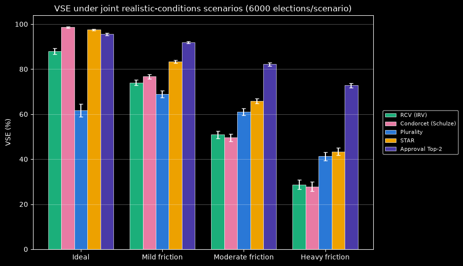

RCV (IRV) vs Condorcet (Schulze): paired VSE gap by joint-friction scenario

| Scenario | RCV VSE (%) | Schulze VSE (%) | Gap vs Schulze (pp) | 95% CI (paired, pp) | Significant? |
| --- | --- | --- | --- | --- | --- |
| Ideal | 87.9 | 98.6 | -10.7 | [-11.9, -9.5] | Decisive (Schulze better) |
| Mild friction | 74.1 | 76.7 | -2.7 | [-3.4, -2.0] | Decisive (Schulze better) |
| Moderate friction | 50.9 | 49.6 | +1.3 | [+0.8, +1.9] | Ambiguous edge (RCV better) |
| Heavy friction | 28.7 | 27.9 | +0.8 | [+0.3, +1.4] | Ambiguous edge (RCV better) |

```python
replay("ranked-implosion")
replay("rcv-schulze-ci")
```

### Condorcet Efficiency

| Method | Raw CE (honest) | Relative to Schulze |
| --- | --- | --- |
| Condorcet (Schulze) | 100.0% | 1.00x |
| Approval Top-2 | 82.1% | 0.82x |
| STAR | 79.3% | 0.79x |
| Score5 | 70.9% | 0.71x |
| Plurality Top-2 | 66.2% | 0.66x |
| RCV (IRV) | 64.0% | 0.64x |
| Approval | 57.8% | 0.58x |
| Plurality | 44.4% | 0.44x |

| Method | Ideal | Mild friction | Moderate friction | Heavy friction |
| --- | --- | --- | --- | --- |
| Plurality | 44.4% (0.44x Schulze) | 45.2% (1.04x Schulze) | 33.6% (1.19x Schulze) | 24.1% (1.14x Schulze) |
| Plurality Top-2 | 66.2% (0.66x Schulze) | 60.4% (1.39x Schulze) | 48.2% (1.71x Schulze) | 38.5% (1.83x Schulze) |
| Plurality Top-2 (Clear-Eyed) | 66.2% (0.66x Schulze) | 68.7% (1.58x Schulze) | 54.6% (1.93x Schulze) | 44.1% (2.10x Schulze) |
| RCV (IRV) | 64.0% (0.64x Schulze) | 42.4% (0.97x Schulze) | 28.6% (1.01x Schulze) | 21.1% (1.00x Schulze) |
| Approval | 57.8% (0.58x Schulze) | 45.4% (1.04x Schulze) | 33.7% (1.19x Schulze) | 24.0% (1.14x Schulze) |
| Approval Top-2 (Coma) | 82.1% (0.82x Schulze) | 45.1% (1.04x Schulze) | 29.1% (1.03x Schulze) | 21.1% (1.00x Schulze) |
| Approval Top-2 | 82.1% (0.82x Schulze) | 61.1% (1.40x Schulze) | 47.5% (1.68x Schulze) | 38.5% (1.83x Schulze) |
| Approval Top-2 (Clear-Eyed) | 82.1% (0.82x Schulze) | 71.4% (1.64x Schulze) | 54.1% (1.91x Schulze) | 44.2% (2.10x Schulze) |
| STAR | 79.3% (0.79x Schulze) | 47.3% (1.08x Schulze) | 33.7% (1.19x Schulze) | 24.1% (1.15x Schulze) |
| Score5 | 70.9% (0.71x Schulze) | 45.0% (1.03x Schulze) | 33.1% (1.17x Schulze) | 24.0% (1.14x Schulze) |
| Score Top-2 (Clear-Eyed) | 91.4% (0.91x Schulze) | 70.8% (1.63x Schulze) | 53.7% (1.90x Schulze) | 44.0% (2.09x Schulze) |
| Condorcet (Schulze) | 100.0% (1.00x Schulze) | 43.6% (1.00x Schulze) | 28.2% (1.00x Schulze) | 21.0% (1.00x Schulze) |

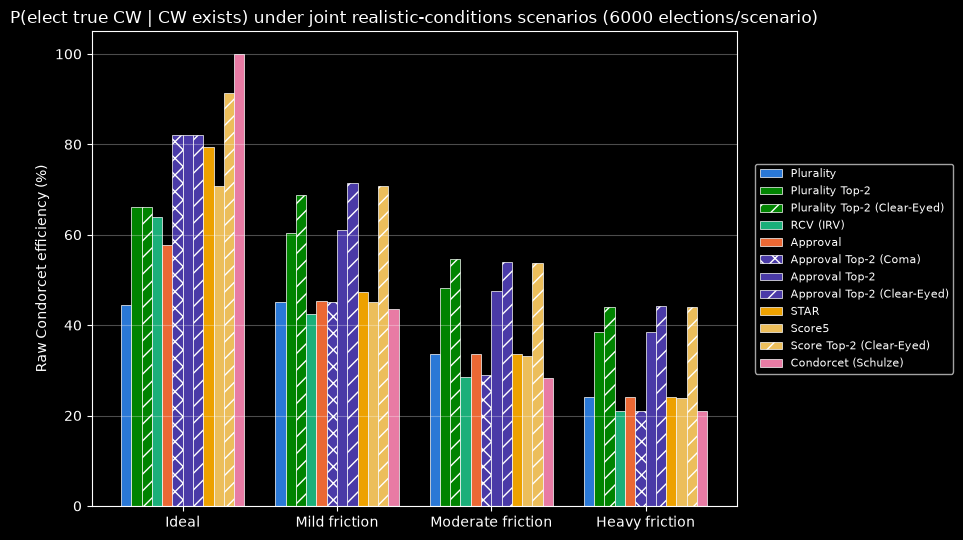

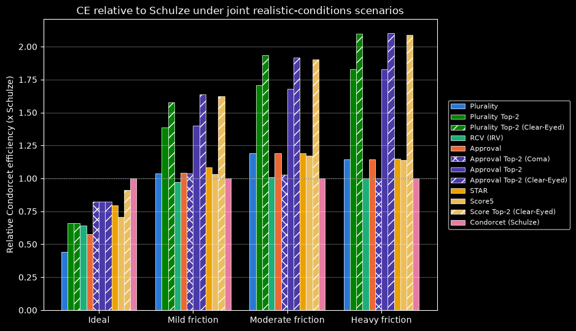

Ideal: paired Condorcet-efficiency gap vs Schulze (pp)

| Method | CE gap vs Schulze (pp) | 95% CI | Significant? |
| --- | --- | --- | --- |
| Approval Top-2 | -17.9% | [-19.6%, -16.2%] | Decisive (Condorcet (Schulze) better) |
| STAR | -20.7% | [-22.4%, -18.9%] | Decisive (Condorcet (Schulze) better) |
| Score5 | -29.1% | [-31.1%, -27.1%] | Decisive (Condorcet (Schulze) better) |
| Plurality Top-2 | -33.8% | [-35.9%, -31.7%] | Decisive (Condorcet (Schulze) better) |
| RCV (IRV) | -36.0% | [-38.1%, -33.9%] | Decisive (Condorcet (Schulze) better) |
| Approval | -42.2% | [-44.4%, -40.0%] | Decisive (Condorcet (Schulze) better) |
| Plurality | -55.6% | [-57.8%, -53.5%] | Decisive (Condorcet (Schulze) better) |

Mild friction: paired Condorcet-efficiency gap vs Schulze (pp)

| Method | CE gap vs Schulze (pp) | 95% CI | Significant? |
| --- | --- | --- | --- |
| Approval Top-2 (Clear-Eyed) | +27.8% | [+26.6%, +29.0%] | Decisive (Approval Top-2 (Clear-Eyed) better) |
| Score Top-2 (Clear-Eyed) | +27.2% | [+26.1%, +28.4%] | Decisive (Score Top-2 (Clear-Eyed) better) |
| Plurality Top-2 (Clear-Eyed) | +25.2% | [+23.9%, +26.4%] | Decisive (Plurality Top-2 (Clear-Eyed) better) |
| Approval Top-2 | +17.5% | [+16.2%, +18.8%] | Decisive (Approval Top-2 better) |
| Plurality Top-2 | +16.8% | [+15.5%, +18.1%] | Decisive (Plurality Top-2 better) |
| STAR | +3.7% | [+3.0%, +4.4%] | Decisive (STAR better) |
| Approval | +1.8% | [+1.0%, +2.7%] | Decisive (Approval better) |
| Plurality | +1.6% | [+0.6%, +2.7%] | Ambiguous edge (Plurality better) |
| Approval Top-2 (Coma) | +1.5% | [+0.8%, +2.3%] | Ambiguous edge (Approval Top-2 (Coma) better) |
| Score5 | +1.5% | [+0.7%, +2.2%] | Ambiguous edge (Score5 better) |
| RCV (IRV) | -1.2% | [-1.7%, -0.7%] | Ambiguous edge (Condorcet (Schulze) better) |

Moderate friction: paired Condorcet-efficiency gap vs Schulze (pp)

| Method | CE gap vs Schulze (pp) | 95% CI | Significant? |
| --- | --- | --- | --- |
| Plurality Top-2 (Clear-Eyed) | +26.4% | [+25.2%, +27.5%] | Decisive (Plurality Top-2 (Clear-Eyed) better) |
| Approval Top-2 (Clear-Eyed) | +25.8% | [+24.7%, +26.9%] | Decisive (Approval Top-2 (Clear-Eyed) better) |
| Score Top-2 (Clear-Eyed) | +25.5% | [+24.3%, +26.6%] | Decisive (Score Top-2 (Clear-Eyed) better) |
| Plurality Top-2 | +19.9% | [+18.7%, +21.1%] | Decisive (Plurality Top-2 better) |
| Approval Top-2 | +19.2% | [+18.0%, +20.4%] | Decisive (Approval Top-2 better) |
| Approval | +5.4% | [+4.8%, +6.1%] | Decisive (Approval better) |
| STAR | +5.4% | [+4.8%, +6.0%] | Decisive (STAR better) |
| Plurality | +5.4% | [+4.7%, +6.1%] | Decisive (Plurality better) |
| Score5 | +4.9% | [+4.3%, +5.5%] | Decisive (Score5 better) |
| Approval Top-2 (Coma) | +0.8% | [+0.3%, +1.3%] | Ambiguous edge (Approval Top-2 (Coma) better) |
| RCV (IRV) | +0.3% | [+0.1%, +0.6%] | Narrow edge (RCV (IRV) better) |

Heavy friction: paired Condorcet-efficiency gap vs Schulze (pp)

| Method | CE gap vs Schulze (pp) | 95% CI | Significant? |
| --- | --- | --- | --- |
| Approval Top-2 (Clear-Eyed) | +23.2% | [+22.1%, +24.3%] | Decisive (Approval Top-2 (Clear-Eyed) better) |
| Plurality Top-2 (Clear-Eyed) | +23.1% | [+22.0%, +24.1%] | Decisive (Plurality Top-2 (Clear-Eyed) better) |
| Score Top-2 (Clear-Eyed) | +22.9% | [+21.9%, +24.0%] | Decisive (Score Top-2 (Clear-Eyed) better) |
| Plurality Top-2 | +17.5% | [+16.3%, +18.6%] | Decisive (Plurality Top-2 better) |
| Approval Top-2 | +17.5% | [+16.3%, +18.6%] | Decisive (Approval Top-2 better) |
| STAR | +3.1% | [+2.7%, +3.6%] | Decisive (STAR better) |
| Plurality | +3.0% | [+2.6%, +3.5%] | Decisive (Plurality better) |
| Approval | +3.0% | [+2.5%, +3.5%] | Decisive (Approval better) |
| Score5 | +2.9% | [+2.5%, +3.4%] | Decisive (Score5 better) |
| RCV (IRV) | +0.0% | [-0.2%, +0.2%] | Indistinguishable |
| Approval Top-2 (Coma) | +0.0% | [-0.3%, +0.4%] | Indistinguishable |

```python
replay("ideal-honest-ce-table")
replay("condorcet-joint")
replay("ce-ci-table")
```

### Robustness Rankings

```python
replay("robustness-rankings")
```

Ideal: robustness across strategy levels

**1. Mean VSE across axis (higher better)**

| Rank | Method | Score |
| --- | --- | --- |
| 1 | Approval Top-2 | 95.9% |
| 2 | STAR | 95.0% |
| 3 | Score5 | 93.4% |
| 4 | Condorcet (Schulze) | 92.3% |
| 5 | Approval | 91.0% |
| 6 | Plurality Top-2 | 85.3% |
| 7 | RCV (IRV) | 83.1% |
| 8 | Plurality | 70.3% |

**2. Worst-case VSE, CI lower bound (higher better)**

| Rank | Method | Score |
| --- | --- | --- |
| 1 | Approval Top-2 | 91.6% |
| 2 | STAR | 88.3% |
| 3 | Condorcet (Schulze) | 82.9% |
| 4 | Approval | 82.9% |
| 5 | Score5 | 81.8% |
| 6 | Plurality Top-2 | 81.3% |
| 7 | RCV (IRV) | 74.7% |
| 8 | Plurality | 56.6% |

**3. Avg. regret vs. best-at-that-point (lower better)**

| Rank | Method | Score |
| --- | --- | --- |
| 1 | Approval Top-2 | 0.6% |
| 2 | STAR | 1.5% |
| 3 | Score5 | 3.1% |
| 4 | Condorcet (Schulze) | 4.2% |
| 5 | Approval | 5.5% |
| 6 | Plurality Top-2 | 11.2% |
| 7 | RCV (IRV) | 13.4% |
| 8 | Plurality | 26.2% |

**4. Avg. rank across axis (lower better)**

| Rank | Method | Score |
| --- | --- | --- |
| 1 | Approval Top-2 | 1.88 |
| 2 | STAR | 2.12 |
| 3 | Score5 | 3.25 |
| 4 | Condorcet (Schulze) | 3.75 |
| 5 | Approval | 4.50 |
| 6 | Plurality Top-2 | 6.12 |
| 7 | RCV (IRV) | 6.62 |
| 8 | Plurality | 7.75 |

Friction only (Mild/Moderate/Heavy)

**1. Mean VSE across axis (higher better)**

| Rank | Method | Score |
| --- | --- | --- |
| 1 | Approval Top-2 (Clear-Eyed) | 83.8% |
| 2 | Approval Top-2 | 82.3% |
| 3 | Plurality Top-2 (Clear-Eyed) | 82.1% |
| 4 | Plurality Top-2 | 80.8% |
| 5 | STAR | 64.2% |
| 6 | Approval | 63.9% |
| 7 | Score5 | 63.3% |
| 8 | Plurality | 57.1% |
| 9 | Approval Top-2 (Coma) | 56.7% |
| 10 | Condorcet (Schulze) | 51.4% |
| 11 | RCV (IRV) | 51.2% |

**2. Worst-case VSE, CI lower bound (higher better)**

| Rank | Method | Score |
| --- | --- | --- |
| 1 | Approval Top-2 (Clear-Eyed) | 74.3% |
| 2 | Plurality Top-2 (Clear-Eyed) | 73.4% |
| 3 | Approval Top-2 | 71.9% |
| 4 | Plurality Top-2 | 71.3% |
| 5 | STAR | 41.7% |
| 6 | Approval | 41.4% |
| 7 | Score5 | 41.1% |
| 8 | Plurality | 39.4% |
| 9 | Approval Top-2 (Coma) | 29.7% |
| 10 | RCV (IRV) | 26.6% |
| 11 | Condorcet (Schulze) | 25.8% |

**3. Avg. regret vs. best-at-that-point (lower better)**

| Rank | Method | Score |
| --- | --- | --- |
| 1 | Approval Top-2 (Clear-Eyed) | 0.0% |
| 2 | Approval Top-2 | 1.4% |
| 3 | Plurality Top-2 (Clear-Eyed) | 1.7% |
| 4 | Plurality Top-2 | 2.9% |
| 5 | STAR | 19.6% |
| 6 | Approval | 19.9% |
| 7 | Score5 | 20.5% |
| 8 | Plurality | 26.7% |
| 9 | Approval Top-2 (Coma) | 27.1% |
| 10 | Condorcet (Schulze) | 32.4% |
| 11 | RCV (IRV) | 32.5% |

**4. Avg. rank across axis (lower better)**

| Rank | Method | Score |
| --- | --- | --- |
| 1 | Approval Top-2 (Clear-Eyed) | 1.00 |
| 2 | Plurality Top-2 (Clear-Eyed) | 2.33 |
| 3 | Approval Top-2 | 2.67 |
| 4 | Plurality Top-2 | 4.00 |
| 5 | STAR | 5.33 |
| 6 | Approval | 5.67 |
| 7 | Score5 | 7.00 |
| 8 | Approval Top-2 (Coma) | 8.67 |
| 9 | Plurality | 9.00 |
| 10 | RCV (IRV) | 10.00 |
| 11 | Condorcet (Schulze) | 10.33 |

Holistic (Ideal + all friction scenarios)

**1. Mean VSE across axis (higher better)**

| Rank | Method | Score |
| --- | --- | --- |
| 1 | Approval Top-2 (Clear-Eyed) | 86.7% |
| 2 | Approval Top-2 | 85.6% |
| 3 | Plurality Top-2 (Clear-Eyed) | 82.5% |
| 4 | Plurality Top-2 | 81.5% |
| 5 | STAR | 72.5% |
| 6 | Score5 | 71.4% |
| 7 | Approval | 70.2% |
| 8 | Approval Top-2 (Coma) | 66.4% |
| 9 | Condorcet (Schulze) | 63.2% |
| 10 | RCV (IRV) | 60.4% |
| 11 | Plurality | 58.2% |

**2. Worst-case VSE, CI lower bound (higher better)**

| Rank | Method | Score |
| --- | --- | --- |
| 1 | Approval Top-2 (Clear-Eyed) | 74.3% |
| 2 | Plurality Top-2 (Clear-Eyed) | 73.4% |
| 3 | Approval Top-2 | 71.9% |
| 4 | Plurality Top-2 | 71.3% |
| 5 | STAR | 41.7% |
| 6 | Approval | 41.4% |
| 7 | Score5 | 41.1% |
| 8 | Plurality | 39.4% |
| 9 | Approval Top-2 (Coma) | 29.7% |
| 10 | RCV (IRV) | 26.6% |
| 11 | Condorcet (Schulze) | 25.8% |

**3. Avg. regret vs. best-at-that-point (lower better)**

| Rank | Method | Score |
| --- | --- | --- |
| 1 | Approval Top-2 (Clear-Eyed) | 0.8% |
| 2 | Approval Top-2 | 1.8% |
| 3 | Plurality Top-2 (Clear-Eyed) | 5.0% |
| 4 | Plurality Top-2 | 6.0% |
| 5 | STAR | 15.0% |
| 6 | Score5 | 16.0% |
| 7 | Approval | 17.3% |
| 8 | Approval Top-2 (Coma) | 21.1% |
| 9 | Condorcet (Schulze) | 24.3% |
| 10 | RCV (IRV) | 27.1% |
| 11 | Plurality | 29.3% |

**4. Avg. rank across axis (lower better)**

| Rank | Method | Score |
| --- | --- | --- |
| 1 | Approval Top-2 (Clear-Eyed) | 2.25 |
| 2 | Approval Top-2 | 3.25 |
| 3 | Plurality Top-2 (Clear-Eyed) | 4.25 |
| 4 | STAR | 4.50 |
| 5 | Plurality Top-2 | 5.25 |
| 6 | Approval | 6.00 |
| 7 | Score5 | 6.00 |
| 8 | Approval Top-2 (Coma) | 7.50 |
| 9 | Condorcet (Schulze) | 8.00 |
| 10 | Plurality | 9.50 |
| 11 | RCV (IRV) | 9.50 |

### The Shape of the Data

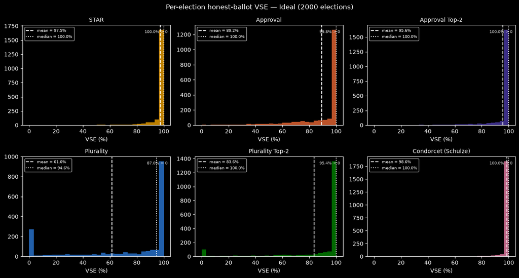

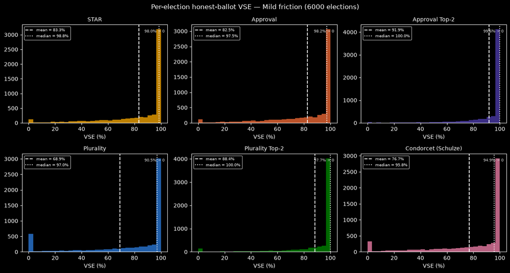

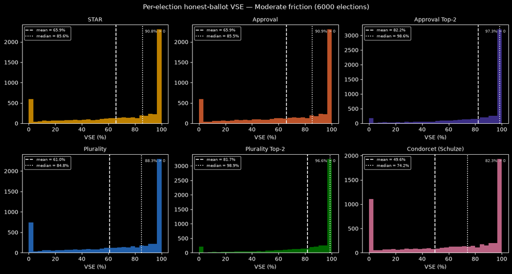

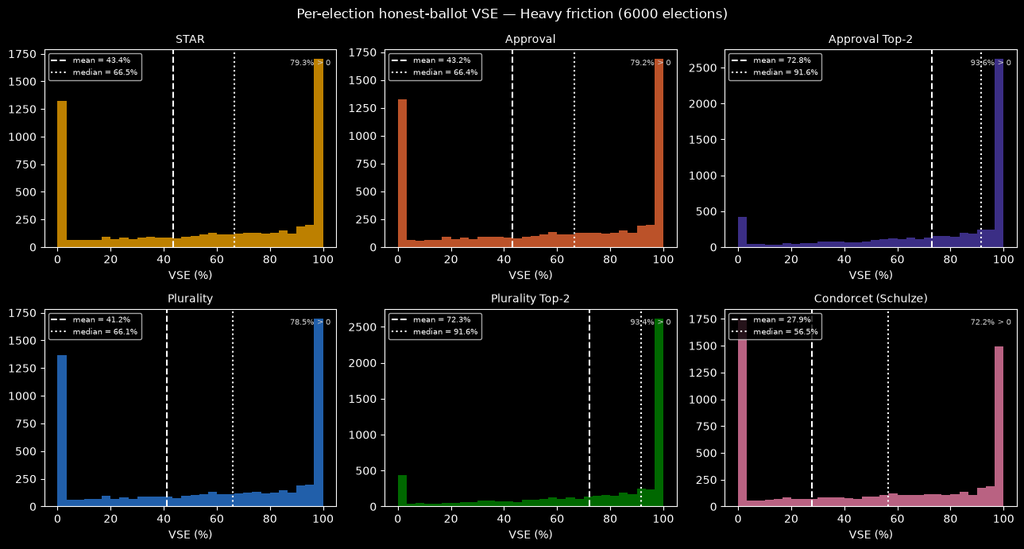

```python
replay("histogram-data")
```

### 99% Confidence Check Part 2

```python
replay("not-sig-at-99-part2")
replay("still-sig-at-99-part2")
```

1 result(s) lose significance at 99% confidence

- **CE gap vs Schulze: Moderate friction -- RCV (IRV)**: at 95% confidence, **RCV (IRV)** appeared better than **Condorcet (Schulze)** by 0.3pp (Narrow edge, 95% CI [+0.1, +0.6]) -- but at 99% confidence that edge is no longer significant (Indistinguishable, 99% CI [-0.0, +0.7], which contains 0).

Spotlight: does each headline claim hold up at 99% confidence?

CE gap vs Schulze: Ideal

| Row | Gap (pp) | 95% verdict | 99% verdict |
| --- | --- | --- | --- |
| Approval Top-2 | -17.9 | Decisive (Condorcet (Schulze) better) | Decisive (Condorcet (Schulze) better) |
| STAR | -20.7 | Decisive (Condorcet (Schulze) better) | Decisive (Condorcet (Schulze) better) |
| Score5 | -29.1 | Decisive (Condorcet (Schulze) better) | Decisive (Condorcet (Schulze) better) |
| Plurality Top-2 | -33.8 | Decisive (Condorcet (Schulze) better) | Decisive (Condorcet (Schulze) better) |
| RCV (IRV) | -36.0 | Decisive (Condorcet (Schulze) better) | Decisive (Condorcet (Schulze) better) |
| Approval | -42.2 | Decisive (Condorcet (Schulze) better) | Decisive (Condorcet (Schulze) better) |
| Plurality | -55.6 | Decisive (Condorcet (Schulze) better) | Decisive (Condorcet (Schulze) better) |

CE gap vs Schulze: Mild friction

| Row | Gap (pp) | 95% verdict | 99% verdict |
| --- | --- | --- | --- |
| Approval Top-2 (Clear-Eyed) | +27.8 | Decisive (Approval Top-2 (Clear-Eyed) better) | Decisive (Approval Top-2 (Clear-Eyed) better) |
| Score Top-2 (Clear-Eyed) | +27.2 | Decisive (Score Top-2 (Clear-Eyed) better) | Decisive (Score Top-2 (Clear-Eyed) better) |
| Plurality Top-2 (Clear-Eyed) | +25.2 | Decisive (Plurality Top-2 (Clear-Eyed) better) | Decisive (Plurality Top-2 (Clear-Eyed) better) |
| Approval Top-2 | +17.5 | Decisive (Approval Top-2 better) | Decisive (Approval Top-2 better) |
| Plurality Top-2 | +16.8 | Decisive (Plurality Top-2 better) | Decisive (Plurality Top-2 better) |
| STAR | +3.7 | Decisive (STAR better) | Decisive (STAR better) |
| Approval | +1.8 | Decisive (Approval better) | **Ambiguous edge (Approval better)** |
| Plurality | +1.6 | Ambiguous edge (Plurality better) | Ambiguous edge (Plurality better) |
| Approval Top-2 (Coma) | +1.5 | Ambiguous edge (Approval Top-2 (Coma) better) | Ambiguous edge (Approval Top-2 (Coma) better) |
| Score5 | +1.5 | Ambiguous edge (Score5 better) | Ambiguous edge (Score5 better) |
| RCV (IRV) | -1.2 | Ambiguous edge (Condorcet (Schulze) better) | Ambiguous edge (Condorcet (Schulze) better) |

CE gap vs Schulze: Moderate friction

| Row | Gap (pp) | 95% verdict | 99% verdict |
| --- | --- | --- | --- |
| Plurality Top-2 (Clear-Eyed) | +26.4 | Decisive (Plurality Top-2 (Clear-Eyed) better) | Decisive (Plurality Top-2 (Clear-Eyed) better) |
| Approval Top-2 (Clear-Eyed) | +25.8 | Decisive (Approval Top-2 (Clear-Eyed) better) | Decisive (Approval Top-2 (Clear-Eyed) better) |
| Score Top-2 (Clear-Eyed) | +25.5 | Decisive (Score Top-2 (Clear-Eyed) better) | Decisive (Score Top-2 (Clear-Eyed) better) |
| Plurality Top-2 | +19.9 | Decisive (Plurality Top-2 better) | Decisive (Plurality Top-2 better) |
| Approval Top-2 | +19.2 | Decisive (Approval Top-2 better) | Decisive (Approval Top-2 better) |
| Approval | +5.4 | Decisive (Approval better) | Decisive (Approval better) |
| STAR | +5.4 | Decisive (STAR better) | Decisive (STAR better) |
| Plurality | +5.4 | Decisive (Plurality better) | Decisive (Plurality better) |
| Score5 | +4.9 | Decisive (Score5 better) | Decisive (Score5 better) |
| Approval Top-2 (Coma) | +0.8 | Ambiguous edge (Approval Top-2 (Coma) better) | Ambiguous edge (Approval Top-2 (Coma) better) |
| RCV (IRV) | +0.3 | Narrow edge (RCV (IRV) better) | **Indistinguishable** |

CE gap vs Schulze: Heavy friction

| Row | Gap (pp) | 95% verdict | 99% verdict |
| --- | --- | --- | --- |
| Approval Top-2 (Clear-Eyed) | +23.2 | Decisive (Approval Top-2 (Clear-Eyed) better) | Decisive (Approval Top-2 (Clear-Eyed) better) |
| Plurality Top-2 (Clear-Eyed) | +23.1 | Decisive (Plurality Top-2 (Clear-Eyed) better) | Decisive (Plurality Top-2 (Clear-Eyed) better) |
| Score Top-2 (Clear-Eyed) | +22.9 | Decisive (Score Top-2 (Clear-Eyed) better) | Decisive (Score Top-2 (Clear-Eyed) better) |
| Plurality Top-2 | +17.5 | Decisive (Plurality Top-2 better) | Decisive (Plurality Top-2 better) |
| Approval Top-2 | +17.5 | Decisive (Approval Top-2 better) | Decisive (Approval Top-2 better) |
| STAR | +3.1 | Decisive (STAR better) | Decisive (STAR better) |
| Plurality | +3.0 | Decisive (Plurality better) | Decisive (Plurality better) |
| Approval | +3.0 | Decisive (Approval better) | Decisive (Approval better) |
| Score5 | +2.9 | Decisive (Score5 better) | Decisive (Score5 better) |
| RCV (IRV) | +0.0 | Indistinguishable | Indistinguishable |
| Approval Top-2 (Coma) | +0.0 | Indistinguishable | Indistinguishable |

## Part 3

to be continued...

# 29. How many more elections would it actually take?

Rows below are the ones the 5-way taxonomy (`_classify_gap`/`TAXONOMY_LABELS`, defined alongside `SIGNIFICANCE_LOG` above) currently calls **Inconclusive** or **Ambiguous edge** -- the only two buckets where more data could plausibly change the story. `Indistinguishable` rows are already known to be small and don't matter; `Decisive`/`Narrow edge` rows already have a resolved direction. (See Section 27 for how these buckets hold up under a stricter 99% bar.)

For each row, this projects the election count needed to reach the *next* tier up, using the same CI-scaling fact Section 27's 99% rescaling relies on: a CI's half-width scales as `1/sqrt(n)` for a fixed underlying variance, so `n_required = n_current * (ci_current / ci_target)^2`.

- **Inconclusive -> Ambiguous edge (or better)**: needs the CI to clear zero, so `ci_target = |gap|`.
- **Ambiguous edge -> Narrow edge or Decisive**: needs the CI to stop straddling `GAP_THRESHOLD_PP`, so `ci_target = |gap - GAP_THRESHOLD_PP|` -- whichever side of the threshold the observed gap already sits on is the only side it can resolve toward.

**This is a projection, not a guarantee.** It assumes the gap and CI this run already shows are close to the true values -- a gap that's mostly noise at the current sample size can make the projection too optimistic, and for a genuinely ~0 true effect the projected n needed is effectively unbounded. Treat it as "if reality looks like what I'm currently seeing, here's the number," not proof you'll actually get there.

Each comparison is also tagged with which `NITER`-style knob actually controls it (`JOINT_NITER`, `RUNOFF_SWEEP_NITER` for the kappa-threshold sweep, `NCAND_SWEEP_NITER` for the candidate-count sweep) via a best-effort keyword match on the comparison's own title -- correct `_NITER_KNOB_KEYWORDS` below if a comparison gets misclassified.

```python
_NITER_KNOB_KEYWORDS = [
    ("kappa threshold", "RUNOFF_SWEEP_NITER", RUNOFF_SWEEP_NITER),
    ("candidate count", "NCAND_SWEEP_NITER", NCAND_SWEEP_NITER),
]
_DEFAULT_NITER_KNOB = ("JOINT_NITER", JOINT_NITER)


def _niter_knob_for(table_title):
    for keyword, name, value in _NITER_KNOB_KEYWORDS:
        if keyword in table_title:
            return name, value
    return _DEFAULT_NITER_KNOB


def _required_n(n_current, ci_current, ci_target):
    if ci_target <= 0 or ci_current <= 0:
        return float("inf")
    return n_current * (ci_current / ci_target) ** 2


def _next_tier_ci_target(bucket, gap):
    if bucket == "INCONCLUSIVE":
        return abs(gap)
    if bucket == "AMBIGUOUS_EDGE":
        return abs(abs(gap) - GAP_THRESHOLD_PP)
    return None


def _fmt_n(n_for, n_current):
    if n_for <= n_current:
        return "already there"
    return "very large" if n_for == float("inf") else f"{n_for:,.0f}"


_chase_rows = {"INCONCLUSIVE": [], "AMBIGUOUS_EDGE": []}
for _table_title, _rows in SIGNIFICANCE_LOG.items():
    _knob_name, _n_current = _niter_knob_for(_table_title)
    for _row_label, _gap, _ci95, _pos_name, _neg_name, _spotlight in _rows:
        _bucket = _classify_gap(_gap, _ci95)
        if _bucket not in _chase_rows:
            continue
        _ci_target = _next_tier_ci_target(_bucket, _gap)
        _n_needed = _required_n(_n_current, _ci95, _ci_target)
        _chase_rows[_bucket].append(
            (_table_title, _row_label, _knob_name, _n_current, _gap, _ci95, _n_needed)
        )

_SECTION_TITLES = {
    "INCONCLUSIVE": "Inconclusive -- need to establish direction",
    "AMBIGUOUS_EDGE": "Ambiguous edge -- need to resolve magnitude",
}
for _bucket in ("INCONCLUSIVE", "AMBIGUOUS_EDGE"):
    _rows_for_bucket = sorted(_chase_rows[_bucket], key=lambda r: r[-1])
    _lines = [
        f"#### {_SECTION_TITLES[_bucket]} ({len(_rows_for_bucket)} rows)",
        "",
        "| Comparison | Row | Knob | Gap (pp) | 95% CI (pp) | Knob n | Projected n for next tier |",
        "|---|---|---|---|---|---|---|",
    ]
    for _table_title, _row_label, _knob_name, _n_current, _gap, _ci95, _n_needed in _rows_for_bucket:
        _lines.append(
            f"| {_table_title} | {_row_label} | `{_knob_name}` | {_gap:+.2f} | "
            f"[{_gap-_ci95:+.2f}, {_gap+_ci95:+.2f}] | {_n_current:,} | {_fmt_n(_n_needed, _n_current)} |"
        )
    if not _rows_for_bucket:
        _lines.append("| *(none currently in this bucket)* | | | | | | |")
    display(Markdown("\n".join(_lines)))
```

Inconclusive -- need to establish direction (17 rows)

| Comparison | Row | Knob | Gap (pp) | 95% CI (pp) | Knob n | Projected n for next tier |
| --- | --- | --- | --- | --- | --- | --- |
| AT2 vs PT2 by candidate count: Heavy friction | NCAND=5 | `NCAND_SWEEP_NITER` | +1.06 | [-0.03, +2.14] | 1,200 | 1,263 |
| AT2 vs PT2 by candidate count: Heavy friction | NCAND=3 | `NCAND_SWEEP_NITER` | +0.88 | [-0.22, +1.98] | 1,200 | 1,860 |
| AT2 vs PT2 by candidate count: Moderate friction | NCAND=15 | `NCAND_SWEEP_NITER` | +0.85 | [-0.21, +1.91] | 1,200 | 1,882 |
| AT2 vs PT2 by candidate count: Heavy friction | NCAND=8 | `NCAND_SWEEP_NITER` | +0.51 | [-0.42, +1.44] | 1,200 | 3,995 |
| AT2 vs PT2 by candidate count: Moderate friction | NCAND=6 | `NCAND_SWEEP_NITER` | -0.65 | [-1.85, +0.55] | 1,200 | 4,036 |
| kappa threshold: Mild friction | kappa=0.10 | `RUNOFF_SWEEP_NITER` | -0.62 | [-1.30, +0.07] | 3,500 | 4,311 |
| Approval Top-2 vs Plurality Top-2 | Heavy friction | `JOINT_NITER` | +0.51 | [-0.05, +1.07] | 6,000 | 7,252 |
| AT2 vs PT2 by candidate count: Moderate friction | NCAND=8 | `NCAND_SWEEP_NITER` | -0.50 | [-1.83, +0.83] | 1,200 | 8,599 |
| kappa threshold: Moderate friction | kappa=0.23 | `RUNOFF_SWEEP_NITER` | -0.63 | [-1.65, +0.39] | 3,500 | 9,128 |
| Approval Top-2 vs Plurality Top-2 | Moderate friction | `JOINT_NITER` | +0.46 | [-0.11, +1.04] | 6,000 | 9,361 |
| AT2 vs PT2 by candidate count: Moderate friction | NCAND=5 | `NCAND_SWEEP_NITER` | -0.34 | [-1.51, +0.84] | 1,200 | 14,457 |
| AT2 vs PT2 by candidate count: Heavy friction | NCAND=10 | `NCAND_SWEEP_NITER` | +0.31 | [-0.80, +1.41] | 1,200 | 15,768 |
| kappa threshold: Moderate friction | kappa=0.27 | `RUNOFF_SWEEP_NITER` | +0.45 | [-0.56, +1.46] | 3,500 | 17,559 |
| kappa threshold: Heavy friction | kappa=0.23 | `RUNOFF_SWEEP_NITER` | -0.42 | [-1.75, +0.91] | 3,500 | 34,503 |
| AT2 vs PT2 by candidate count: Heavy friction | NCAND=6 | `NCAND_SWEEP_NITER` | -0.23 | [-1.47, +1.01] | 1,200 | 34,835 |
| AT2 vs PT2 by candidate count: Moderate friction | NCAND=10 | `NCAND_SWEEP_NITER` | +0.11 | [-1.28, +1.49] | 1,200 | 195,748 |
| kappa threshold: Moderate friction | kappa=0.25 | `RUNOFF_SWEEP_NITER` | +0.12 | [-0.90, +1.14] | 3,500 | 251,184 |

Ambiguous edge -- need to resolve magnitude (22 rows)

| Comparison | Row | Knob | Gap (pp) | 95% CI (pp) | Knob n | Projected n for next tier |
| --- | --- | --- | --- | --- | --- | --- |
| AT2 vs PT2 by candidate count: Moderate friction | NCAND=3 | `NCAND_SWEEP_NITER` | +1.93 | [+0.48, +3.38] | 1,200 | 2,914 |
| kappa threshold: Heavy friction | kappa=0.27 | `RUNOFF_SWEEP_NITER` | +2.26 | [+0.93, +3.59] | 3,500 | 3,911 |
| kappa threshold: Moderate friction | kappa=0.30 | `RUNOFF_SWEEP_NITER` | +2.02 | [+0.93, +3.11] | 3,500 | 3,959 |
| kappa threshold: Mild friction | kappa=0.23 | `RUNOFF_SWEEP_NITER` | +1.50 | [+0.84, +2.15] | 3,500 | 6,146 |
| kappa threshold: Heavy friction | kappa=0.20 | `RUNOFF_SWEEP_NITER` | -2.03 | [-3.39, -0.66] | 3,500 | 6,177 |
| Score5 vs STAR | Mild friction | `JOINT_NITER` | -1.33 | [-1.75, -0.91] | 6,000 | 9,543 |
| CE gap vs Schulze: Mild friction | Approval Top-2 (Coma) | `JOINT_NITER` | +1.54 | [+0.83, +2.26] | 6,000 | 10,309 |
| CE gap vs Schulze: Mild friction | Score5 | `JOINT_NITER` | +1.46 | [+0.71, +2.22] | 6,000 | 16,096 |
| RCV (IRV) vs Condorcet (Schulze) | Moderate friction | `JOINT_NITER` | +1.33 | [+0.77, +1.90] | 6,000 | 17,055 |
| CE gap vs Schulze: Mild friction | Plurality | `JOINT_NITER` | +1.63 | [+0.57, +2.69] | 6,000 | 17,094 |
| Approval-flavor gaps vs STAR: Mild friction | Approval | `JOINT_NITER` | -0.77 | [-1.25, -0.29] | 6,000 | 26,310 |
| kappa threshold: Mild friction | kappa=0.20 | `RUNOFF_SWEEP_NITER` | +1.24 | [+0.56, +1.91] | 3,500 | 28,286 |
| kappa threshold: Moderate friction | kappa=0.20 | `RUNOFF_SWEEP_NITER` | -1.33 | [-2.41, -0.26] | 3,500 | 36,299 |
| Does the runoff help or hurt Approval?: Mild friction | Approval Top-2 (Coma) | `JOINT_NITER` | -1.21 | [-1.76, -0.66] | 6,000 | 41,924 |
| Approval Top-2 (Coma) vs Approval | Mild friction | `JOINT_NITER` | -1.21 | [-1.76, -0.66] | 6,000 | 41,924 |
| CE gap vs Schulze: Mild friction | RCV (IRV) | `JOINT_NITER` | -1.19 | [-1.70, -0.68] | 6,000 | 42,303 |
| Approval Top-2 (Clear-Eyed) vs Plurality Top-2 (Clear-Eyed) | Heavy friction | `JOINT_NITER` | +0.78 | [+0.20, +1.36] | 6,000 | 43,127 |
| CE gap vs Schulze: Moderate friction | Approval Top-2 (Coma) | `JOINT_NITER` | +0.82 | [+0.30, +1.34] | 6,000 | 51,393 |
| RCV (IRV) vs Condorcet (Schulze) | Heavy friction | `JOINT_NITER` | +0.83 | [+0.27, +1.39] | 6,000 | 62,548 |
| Approval Top-2 (Clear-Eyed) vs Plurality Top-2 (Clear-Eyed) | Moderate friction | `JOINT_NITER` | +0.82 | [+0.20, +1.43] | 6,000 | 66,967 |
| Score5 vs STAR | Moderate friction | `JOINT_NITER` | -0.86 | [-1.33, -0.38] | 6,000 | 68,203 |
| Score Top-2 (Clear-Eyed) vs STAR (Epistemic noise) | epistemic_rho=0.90 | `JOINT_NITER` | +1.09 | [+0.57, +1.62] | 6,000 | 181,045 |

# Notebook End

```python
total_notebook_time_end = time.time()
```

```python
print(f"Total notebook execution time: {total_notebook_time_end - total_notebook_time_start:.1f} seconds\nIn minutes: {(total_notebook_time_end - total_notebook_time_start)/60:.1f} minutes")
print(f"Total elections run: {TOTAL_ELECTIONS_RUN}")
```

```
Total notebook execution time: 2417.7 seconds
In minutes: 40.3 minutes
Total elections run: 69800
```